# Main Analyses

One rather weakly regularizing prior for standard deviation parameters is the Exponential(1) prior. Let’s see what that looks like:

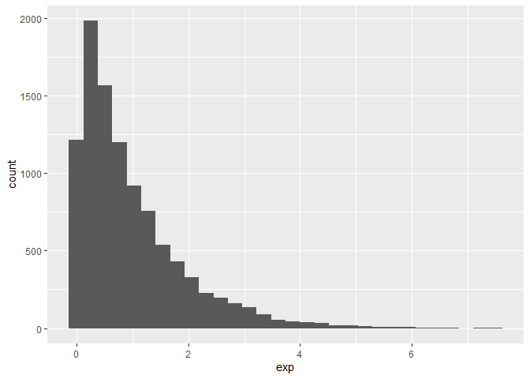

```r
set.seed(1234)
psim <- psim |>
  mutate(exp = rexp(1e4, 1))
ggplot(psim, aes(x = exp)) + geom_histogram()
```

Here, we see that the expected values of the standard deviation around the intercept terms are in the lower end, with the majority of the probable values between 0 and 2. This is still a *very* permissive prior here b/c this is on the log scale. Let’s see if we regularize that more substantially with the exponential(4).

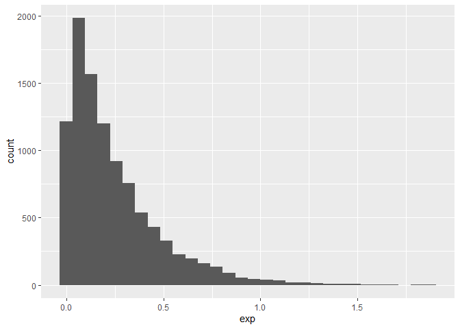

```r
set.seed(1234)
psim <- psim |>
  mutate(exp = rexp(1e4, 4))
ggplot(psim, aes(x = exp)) + geom_histogram()
```

This places the majority of values below 1, but still allows for greater values here. Let’s see what happens if we re-run these models with the more aggressive exponential(4) prior for the standard deviation terms.

```r
like_psych_3 <- brm(bf(CTS_psych_perp_HR ~ 0 + Intercept + (1 | CoupleID),
                     hu ~ 0 + Intercept+ (1 | CoupleID)),
                  prior = c(prior(normal(1, 0.5), class = b, coef = Intercept), # prior on mean (log scale)
                            prior(normal(-1.5, 1), class = b, coef = Intercept, dpar = hu), # prior on odds of being 0 (logit scale)
                            prior(exponential(4), class = sd), # prior on couple variability
                            prior(exponential(1), class = shape) # prior on dispersion
                  ),
                  data = data,
                  family = hurdle_negbinomial(),
                  chains = 4, iter = 2000, warmup = 1000, cores = 4,
                  seed = 1234,
                  file = "fits/like_psych_3",
                  file_refit = "on_change"
                  )
like_psych_min_3 <- brm(bf(CTS_psych_perp_HR_minor ~ 0 + Intercept + (1 | CoupleID),
                     hu ~ 0 + Intercept+ (1 | CoupleID)),
                  prior = c(prior(normal(1, 0.5), class = b, coef = Intercept), # prior on mean (log scale)
                            prior(normal(-1.5, 1), class = b, coef = Intercept, dpar = hu), # prior on odds of being 0 (logit scale)
                            prior(exponential(4), class = sd), # prior on couple variability
                            prior(exponential(1), class = shape) # prior on dispersion
                  ),
                  data = data,
                  family = hurdle_negbinomial(),
                  chains = 4, iter = 2000, warmup = 1000, cores = 4,
                  seed = 1234,
                  file = "fits/like_psych_min_3",
                  file_refit = "on_change"
                  )

like_psych_sev_3 <- brm(bf(CTS_psych_perp_HR_severe ~ 0 + Intercept + (1 | CoupleID),
                     hu ~ 0 + Intercept+ (1 | CoupleID)),
                  prior = c(prior(normal(1, 0.5), class = b, coef = Intercept), # prior on mean (log scale)
                            prior(normal(0, 0.5), class = b, coef = Intercept, dpar = hu), # prior on odds of being 0 (logit scale)
                            prior(exponential(4), class = sd), # prior on couple variability
                            prior(exponential(1), class = shape) # prior on dispersion
                  ),
                  data = data,
                  family = hurdle_negbinomial(),
                  chains = 4, iter = 2000, warmup = 1000, cores = 4,
                  seed = 1234,
                  file = "fits/like_psych_sev_3",
                  file_refit = "on_change"
                  )
like_phys_3 <- brm(bf(CTS_phys_perp_HR ~ 0 + Intercept+ (1 | CoupleID),
                     hu ~ 0 + Intercept+ (1 | CoupleID)),
                  prior = c(prior(normal(0, 0.8), class = b, coef = Intercept), # prior on mean (log scale)
                            prior(normal(1.5, 1), class = b, coef = Intercept, dpar = hu), # prior on odds of being 0 (logit scale)
                            prior(exponential(4), class = sd), # prior on couple variability
                            prior(exponential(1), class = shape) # prior on dispersion
                  ),
                 data = data,
                  family = hurdle_negbinomial(),
                  chains = 4, iter = 2000, warmup = 1000, cores = 4,
                  seed = 1234,
                  file = "fits/like_phys_3",
                  file_refit = "on_change"
                  )
like_sgm_3 <- brm(bf(CTS_sgm_perp_HR ~ 0 + Intercept + (1 | CoupleID),
                   hu ~ 0 + Intercept + (1 | CoupleID)),
                  prior = c(prior(normal(0, 0.8), class = b, coef = Intercept), # prior on mean (log scale)
                            prior(normal(1.5, 1), class = b, coef = Intercept, dpar = hu), # prior on odds of being 0 (logit scale)
                            prior(exponential(4), class = sd), # prior on couple variability
                            prior(exponential(1), class = shape) # prior on dispersion
                  ),
                data = data,
                  family = hurdle_negbinomial(),
                  chains = 4, iter = 2000, warmup = 1000, cores = 4,
                  seed = 1234,
                  file = "fits/like_sgm_3",
                  file_refit = "on_change"
                  )
```

Now let’s summarize & look at the posterior predictive checks for each model. Starting with psychological:

```r
summary(like_psych_3)
```

```
##  Family: hurdle_negbinomial
##   Links: mu = log; shape = identity; hu = logit
## Formula: CTS_psych_perp_HR ~ 0 + Intercept + (1 | CoupleID)
##          hu ~ 0 + Intercept + (1 | CoupleID)
##    Data: data (Number of observations: 164)
##   Draws: 4 chains, each with iter = 2000; warmup = 1000; thin = 1;
##          total post-warmup draws = 4000
##
## Multilevel Hyperparameters:
## ~CoupleID (Number of levels: 82)
##                  Estimate Est.Error l-95% CI u-95% CI Rhat Bulk_ESS Tail_ESS
## sd(Intercept)        1.33      0.13     1.11     1.61 1.00      770     1718
## sd(hu_Intercept)     2.01      0.65     0.78     3.35 1.00      662      539
##
## Regression Coefficients:
##              Estimate Est.Error l-95% CI u-95% CI Rhat Bulk_ESS Tail_ESS
## Intercept        2.27      0.15     1.97     2.56 1.01      652      813
## hu_Intercept    -3.39      0.58    -4.61    -2.35 1.00     1263     1015
##
## Further Distributional Parameters:
##       Estimate Est.Error l-95% CI u-95% CI Rhat Bulk_ESS Tail_ESS
## shape     6.84      1.59     4.15    10.40 1.00     1977     2828
##
## Draws were sampled using sample(hmc). For each parameter, Bulk_ESS
## and Tail_ESS are effective sample size measures, and Rhat is the potential
## scale reduction factor on split chains (at convergence, Rhat = 1).
```

& PPC:

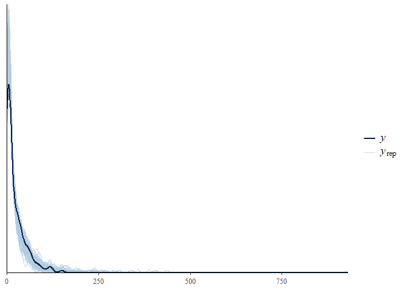

```r
pp_check(like_psych_3, ndraws = 100)
```

Psychological minor:

```r
summary(like_psych_min_3)
```

```
##  Family: hurdle_negbinomial
##   Links: mu = log; shape = identity; hu = logit
## Formula: CTS_psych_perp_HR_minor ~ 0 + Intercept + (1 | CoupleID)
##          hu ~ 0 + Intercept + (1 | CoupleID)
##    Data: data (Number of observations: 168)
##   Draws: 4 chains, each with iter = 2000; warmup = 1000; thin = 1;
##          total post-warmup draws = 4000
##
## Multilevel Hyperparameters:
## ~CoupleID (Number of levels: 84)
##                  Estimate Est.Error l-95% CI u-95% CI Rhat Bulk_ESS Tail_ESS
## sd(Intercept)        1.28      0.12     1.05     1.54 1.01      713     1325
## sd(hu_Intercept)     1.85      0.65     0.56     3.16 1.00      608      349
##
## Regression Coefficients:
##              Estimate Est.Error l-95% CI u-95% CI Rhat Bulk_ESS Tail_ESS
## Intercept        2.16      0.15     1.85     2.45 1.01      471      914
## hu_Intercept    -3.07      0.54    -4.20    -2.09 1.00      918      963
##
## Further Distributional Parameters:
##       Estimate Est.Error l-95% CI u-95% CI Rhat Bulk_ESS Tail_ESS
## shape     7.64      1.82     4.62    11.70 1.00     2111     2287
##
## Draws were sampled using sample(hmc). For each parameter, Bulk_ESS
## and Tail_ESS are effective sample size measures, and Rhat is the potential
## scale reduction factor on split chains (at convergence, Rhat = 1).
```

& PPC:

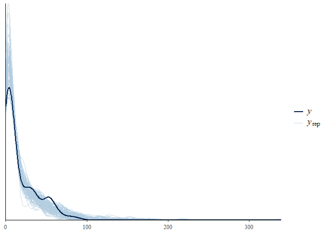

```r
pp_check(like_psych_min_3, ndraws = 100)
```

Psychological severe:

```r
summary(like_psych_sev_3)
```

```
##  Family: hurdle_negbinomial
##   Links: mu = log; shape = identity; hu = logit
## Formula: CTS_psych_perp_HR_severe ~ 0 + Intercept + (1 | CoupleID)
##          hu ~ 0 + Intercept + (1 | CoupleID)
##    Data: data (Number of observations: 164)
##   Draws: 4 chains, each with iter = 2000; warmup = 1000; thin = 1;
##          total post-warmup draws = 4000
##
## Multilevel Hyperparameters:
## ~CoupleID (Number of levels: 82)
##                  Estimate Est.Error l-95% CI u-95% CI Rhat Bulk_ESS Tail_ESS
## sd(Intercept)        1.12      0.20     0.76     1.54 1.00      852     1198
## sd(hu_Intercept)     4.24      1.18     2.43     6.93 1.00     1336     1956
##
## Regression Coefficients:
##              Estimate Est.Error l-95% CI u-95% CI Rhat Bulk_ESS Tail_ESS
## Intercept        1.36      0.21     0.93     1.76 1.01     1378     1881
## hu_Intercept     0.23      0.37    -0.51     0.94 1.00     2251     2880
##
## Further Distributional Parameters:
##       Estimate Est.Error l-95% CI u-95% CI Rhat Bulk_ESS Tail_ESS
## shape     2.51      1.01     0.88     4.88 1.00     1205     1035
##
## Draws were sampled using sample(hmc). For each parameter, Bulk_ESS
## and Tail_ESS are effective sample size measures, and Rhat is the potential
## scale reduction factor on split chains (at convergence, Rhat = 1).
```

& PPC:

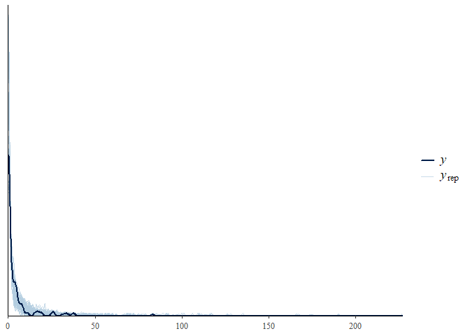

```r
pp_check(like_psych_sev_3, ndraws = 100)
```

Physical:

```r
summary(like_phys_3)
```

```
##  Family: hurdle_negbinomial
##   Links: mu = log; shape = identity; hu = logit
## Formula: CTS_phys_perp_HR ~ 0 + Intercept + (1 | CoupleID)
##          hu ~ 0 + Intercept + (1 | CoupleID)
##    Data: data (Number of observations: 164)
##   Draws: 4 chains, each with iter = 2000; warmup = 1000; thin = 1;
##          total post-warmup draws = 4000
##
## Multilevel Hyperparameters:
## ~CoupleID (Number of levels: 82)
##                  Estimate Est.Error l-95% CI u-95% CI Rhat Bulk_ESS Tail_ESS
## sd(Intercept)        1.66      0.39     0.97     2.48 1.00     1625     1703
## sd(hu_Intercept)     3.57      0.89     2.13     5.61 1.00     2060     2802
##
## Regression Coefficients:
##              Estimate Est.Error l-95% CI u-95% CI Rhat Bulk_ESS Tail_ESS
## Intercept        0.37      0.50    -0.65     1.30 1.00     3081     2920
## hu_Intercept     3.45      0.61     2.34     4.71 1.00     2885     2878
##
## Further Distributional Parameters:
##       Estimate Est.Error l-95% CI u-95% CI Rhat Bulk_ESS Tail_ESS
## shape     1.59      1.16     0.09     4.38 1.00     1102     1166
##
## Draws were sampled using sample(hmc). For each parameter, Bulk_ESS
## and Tail_ESS are effective sample size measures, and Rhat is the potential
## scale reduction factor on split chains (at convergence, Rhat = 1).
```

& PPC:

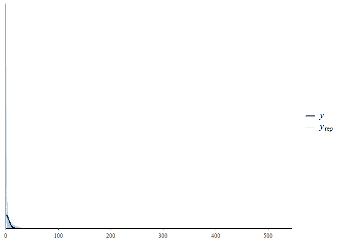

```r
pp_check(like_phys_3, ndraws = 100)
```

SGM-specific:

```r
summary(like_sgm_3, ndraws = 100)
```

```
##  Family: hurdle_negbinomial
##   Links: mu = log; shape = identity; hu = logit
## Formula: CTS_sgm_perp_HR ~ 0 + Intercept + (1 | CoupleID)
##          hu ~ 0 + Intercept + (1 | CoupleID)
##    Data: data (Number of observations: 164)
##   Draws: 4 chains, each with iter = 2000; warmup = 1000; thin = 1;
##          total post-warmup draws = 4000
##
## Multilevel Hyperparameters:
## ~CoupleID (Number of levels: 82)
##                  Estimate Est.Error l-95% CI u-95% CI Rhat Bulk_ESS Tail_ESS
## sd(Intercept)        0.39      0.32     0.01     1.14 1.00      875     2205
## sd(hu_Intercept)     2.29      0.66     1.08     3.70 1.00     1013     1897
##
## Regression Coefficients:
##              Estimate Est.Error l-95% CI u-95% CI Rhat Bulk_ESS Tail_ESS
## Intercept        0.65      0.55    -0.68     1.50 1.00     2517     1904
## hu_Intercept     2.96      0.54     2.00     4.12 1.00     1711     2384
##
## Further Distributional Parameters:
##       Estimate Est.Error l-95% CI u-95% CI Rhat Bulk_ESS Tail_ESS
## shape     0.72      0.83     0.05     3.00 1.00     1110     1983
##
## Draws were sampled using sample(hmc). For each parameter, Bulk_ESS
## and Tail_ESS are effective sample size measures, and Rhat is the potential
## scale reduction factor on split chains (at convergence, Rhat = 1).
```

& PPC:

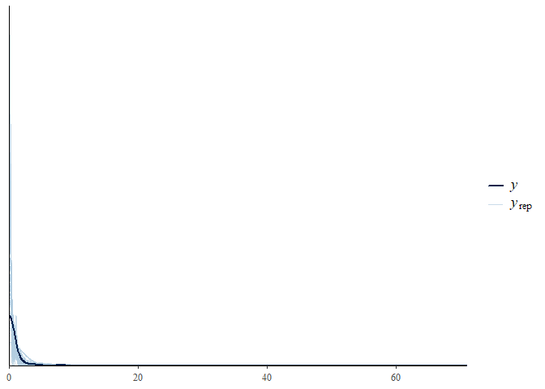

```r
pp_check(like_sgm_3, ndraws = 100)
```

Because of this, I don’t think it makes sense to move forward with modeling physical and SGM-specific IPV frequency b/c it’s going to have limited utility and is going to be asking too much of the data.

So let’s go ahead and re-run those models with binary (0/1) variables for the physical and SGM-specific IPV outcomes. Of note, let’s go back to the normal exponential(1) prior on the intercept variability. It likely doesn’t need to be as aggressive there.

```r
like_phys_3.1 <- brm(bf(CTS_phys_perp_binary ~ 0 + Intercept+ (1 | CoupleID)),
                  prior = c(prior(normal(1.5, 1), class = b, coef = Intercept), # prior on odds of being 0 (logit scale)
                            prior(exponential(1), class = sd) # prior on couple variability
                  ),
                 data = data,
                  family = bernoulli,
                  chains = 4, iter = 2000, warmup = 1000, cores = 4,
                  seed = 1234,
                  file = "fits/like_phys_3.1",
                  file_refit = "on_change"
                  )
like_sgm_3.1 <- brm(bf(CTS_sgm_perp_binary ~ 0 + Intercept + (1 | CoupleID)),
                  prior = c(prior(normal(1.5, 1), class = b, coef = Intercept), # prior on odds of being 0 (logit scale)
                            prior(exponential(1), class = sd) # prior on couple variability
                  ),
                data = data,
                  family = bernoulli,
                  chains = 4, iter = 2000, warmup = 1000, cores = 4,
                  seed = 1234,
                  file = "fits/like_sgm_3.1",
                  file_refit = "on_change"
                  )
```

Let’s look at the output of these.

Physical:

```r
summary(like_phys_3.1)
```

```
##  Family: bernoulli
##   Links: mu = logit
## Formula: CTS_phys_perp_binary ~ 0 + Intercept + (1 | CoupleID)
##    Data: data (Number of observations: 164)
##   Draws: 4 chains, each with iter = 2000; warmup = 1000; thin = 1;
##          total post-warmup draws = 4000
##
## Multilevel Hyperparameters:
## ~CoupleID (Number of levels: 82)
##               Estimate Est.Error l-95% CI u-95% CI Rhat Bulk_ESS Tail_ESS
## sd(Intercept)     2.60      0.71     1.42     4.24 1.00     1782     2294
##
## Regression Coefficients:
##           Estimate Est.Error l-95% CI u-95% CI Rhat Bulk_ESS Tail_ESS
## Intercept    -2.50      0.45    -3.46    -1.69 1.00     4236     3010
##
## Draws were sampled using sample(hmc). For each parameter, Bulk_ESS
## and Tail_ESS are effective sample size measures, and Rhat is the potential
## scale reduction factor on split chains (at convergence, Rhat = 1).
```

& PPC:

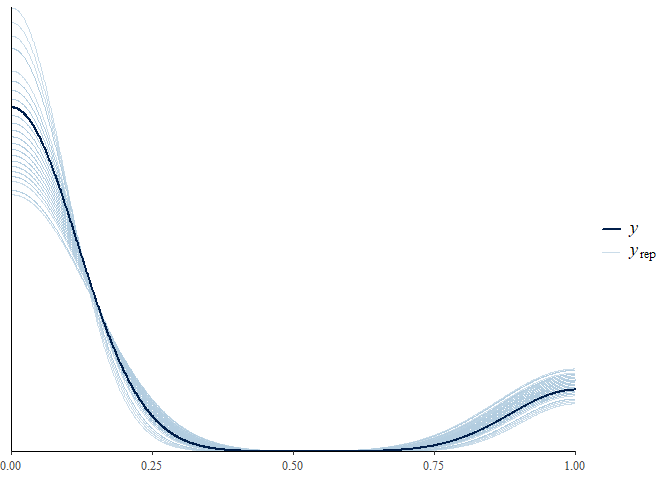

```r
pp_check(like_phys_3.1, ndraws = 100)
```

SGM-specific:

```r
summary(like_sgm_3.1)
```

```
##  Family: bernoulli
##   Links: mu = logit
## Formula: CTS_sgm_perp_binary ~ 0 + Intercept + (1 | CoupleID)
##    Data: data (Number of observations: 164)
##   Draws: 4 chains, each with iter = 2000; warmup = 1000; thin = 1;
##          total post-warmup draws = 4000
##
## Multilevel Hyperparameters:
## ~CoupleID (Number of levels: 82)
##               Estimate Est.Error l-95% CI u-95% CI Rhat Bulk_ESS Tail_ESS
## sd(Intercept)     1.42      0.61     0.22     2.66 1.01      728      876
##
## Regression Coefficients:
##           Estimate Est.Error l-95% CI u-95% CI Rhat Bulk_ESS Tail_ESS
## Intercept    -2.19      0.41    -3.10    -1.51 1.00     1307     1562
##
## Draws were sampled using sample(hmc). For each parameter, Bulk_ESS
## and Tail_ESS are effective sample size measures, and Rhat is the potential
## scale reduction factor on split chains (at convergence, Rhat = 1).
```

& PPC:

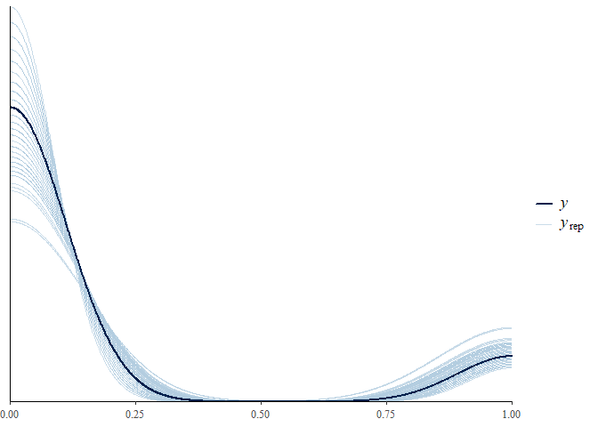

```r
pp_check(like_sgm_3.1, ndraws = 100)
```

Those are MUCH better posterior predictives, so let’s go ahead and work with those models.

Given this decision to use logistic regression for physical and SGM-specific IPV perpetration due to the limited number of couples who perpetrated IPV, I also made the decision to simplify the models for psychological aggression to negative binomial models. This decision is based on making the models more parsimonious and the fact that the *vast* majority of people in this sample perpetrated some psychological aggression, so the hu/zero part of the model is going to be based on only 14 people. This is even less than the amount of people who perpetrated physical or SGM-specific IPV, so it seems appropriate to follow the same logic that the parameter estimates for these portions of the model are going to be based on very limited information. It will also make interpretation easier in line with the physical and SGM-specific forms of perpetration b/c we will not have to switch between occurrence/non-occurrence language here. This is less so the case for severe psychological aggression, though remains true for minor psychological aggression. For consistency and parismony, I decided to still simplify these models to negative binomial models.

### Internalized stigma slope priors

Now that we have our basic, intercept-only model here, let’s figure out some priors for the actor-partner interdependence model.

Small note b/c I’m not sure where else to put this: typically within a MLM for APIMs, you want to set up a compound symmetry correlation structure for the residual variance to allow for possible negative correlations between dyad scores. This is not possible within a GLM framework b/c there is no residual variance term given the different likelihood of the data that is used for these models. Thus, you have to make the assumption that ICCs are positive for the couple. In this study, this is a very fine assumption to make since IPV between partners is typically rather strongly, positively correlated. This may not be the case for other types of constructs though, so that’s just a caveat of these models here.

Ok now back to the priors here. This gets really complicated/tricky because we are working on the log or log odds/logit scale, depending upon the portion of the model that we are estimating here. Here are some additional resources for making sense of this when you inevitably forget what you figured out when coming up with these priors:

- NEGATIVE logit regression coefficient means less likely to happen. 0 logit is 50/50 prob, above 0 is MORE likely to happen
- Conversion between odds, odds ratios, and probabilities can be done here: https://easystats.github.io/effectsize/articles/convert_p_OR_RR.html.

For example, if we have a logit of .04 (i.e., unstandardized regression cofficient), we can convert it to an odds ratio via this:

```r
# logit to odds ratio
inv_logit_scaled(.04)/(1 - inv_logit_scaled(.04))
```

```
## [1] 1.040811
```

Similarly if we need to convert an odds ratio to logit, let’s say we want to convert .95, then we can use this:

```r
# odds ratio to logit
log(.95)
```

```
## [1] -0.05129329
```

If you need some type of annotated output for logistic regression (of MPlus) for looking at how this may have appeared in the Li et al. 2022 paper, you can find that here: https://stats.oarc.ucla.edu/mplus/output/logit-regression/.

SO, with all of that being put there for future you, let’s go ahead and summarize some of the results from the prior literature.

*Li et al. 2022:* * Physical IPV occurrence: actor unstandardized coefficient of -.05 (OR = .95); partner unstandardized coefficient of -.07 (OR = .94) * Psychological IPV occurrence: actor unstandardized coefficient of 1.07 (OR = 2.90); partner unstandardized coefficient of .82 (OR = 2.27) * Psychological IPV frequency: actor unstandardized coefficient of .92, partner unstandardized coefficient of .71

*Do et al. 2021:* Note they say they have standardized regression coefficients but if you do the logit to odds ratio conversion it equals the ORs they report in their tables.

- Physical IPV occurrence: actor coefficient of .19, se = .18 (OR = 1.22, [0.85, 1.72]); partner coefficient of .00, se = .19 (OR = 1.00, [0.69, 1.44])
- Psych IPV occurrence (not severe vs. severe): actor coefficient of -.03, se = .14 (OR = 0.97, [0.74, 1.28]); partner coefficient of .08, se = .14 (OR = 1.08, 0.83, 1.41)

*Badenes-Ribera et al. 2019 meta-analysis:* * Mean r = .15 for any type of IPV (also backed by Kimmes et al. 2019 meta that found r = .14 among sexual minority women and r = .23 among sexual minority men)

That’s all fine and dandy, but can we convert the correlation coefficient to an odds ratio? Turns out we can with the `easystats` package:

```r
d <- r_to_d(0.15)
d_to_oddsratio(d)
```

```
## [1] 1.733889
```

And we can also have it appear on the log scale, which makes it an unstandardized regression coefficient:

```r
d_to_oddsratio(d, log = T)
```

```
## [1] 0.5503667
```

Now that we have all of that background information, let’s go ahead and make some sensible priors out of them.

#### Psych & phys occurrence:

- Li et al. have coefficient of 1.07, whereas Do et al have coefficient of -.03; meta-analysis would suggest inclusion of 0.55 in the range as well (see above conversion for where I got that). We want a distribution that could reflect ALL of these potential values here. A normal(0.5, 0.75) would contain all of these plausible values. It places the most weight on the estimate from the meta-analysis, but still incorporates values consistent with Do and with Li.

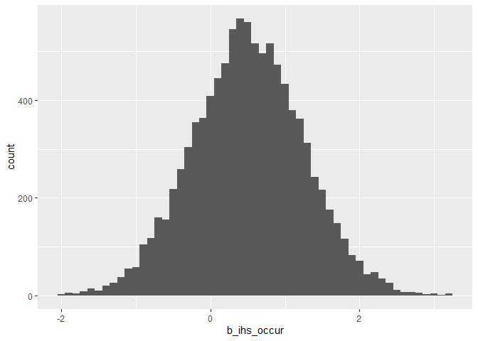

```r
set.seed(1234)
psim <- psim |>
  mutate(b_ihs_occur = rnorm(1e4, mean = 0.5, sd = 0.75))
ggplot(psim, aes(x = b_ihs_occur)) + geom_histogram(binwidth = 0.1)
```

Probability that the coefficient is below 0:

```r
psim |> summarize(sum = sum(ifelse(b_ihs_occur < 0, T, F))/1e4)
```

```
## # A tibble: 1 × 1
##     sum
##   <dbl>
## 1 0.248
```

Probabiliy that the coefficient is above 0.5 (mean from meta-analysis):

```r
psim |> summarize(sum = sum(ifelse(b_ihs_occur > 0.5, T, F))/1e4)
```

```
## # A tibble: 1 × 1
##     sum
##   <dbl>
## 1 0.502
```

#### Psych frequency

Based on Li et al 2022 results, let’s do mean of 0.80 (which is mean of .92 actor and .71 partner). We’ll still allow for significant variability around that so it’s possible to have negative values as well.

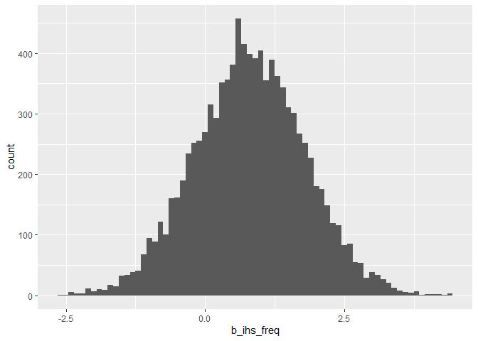

```r
set.seed(1234)
psim <- psim |>
  mutate(b_ihs_freq = rnorm(1e4, mean = 0.8, sd = 1))
ggplot(psim, aes(x = b_ihs_freq)) + geom_histogram(binwidth = 0.1)
```

Proportion of distribution below 0:

```r
psim |> summarize(sum = sum(ifelse(b_ihs_freq < 0, T, F))/1e4)
```

```
## # A tibble: 1 × 1
##     sum
##   <dbl>
## 1 0.209
```

#### SGM-specific

This is the first study to look at internalized stigma and SGM-specific IPV, so let’s keep this prior much more vague. Here’s what we should do for occurrence instead of the more “positive” prior above:

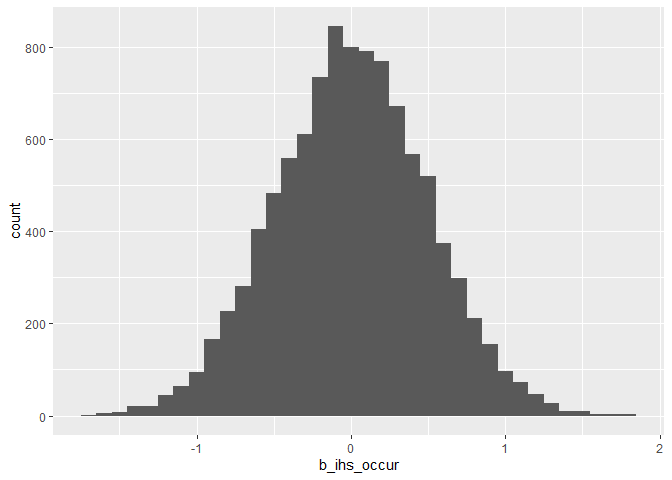

```r
set.seed(1234)
psim <- psim |>
  mutate(b_ihs_occur = rnorm(1e4, mean = 0, sd = 0.5))
ggplot(psim, aes(x = b_ihs_occur)) + geom_histogram(binwidth = 0.1)
```

Basically, it’ll place the mass of probability around 0, and keep the range of possible coefficients reasonable but still letting the data inform the story here.

### Negative affect

Next up is reasoning through priors for negative affect scores. The examples will utilize just one of the negative affect variables (PANAS_disc_neg_actor) with the assumption that priors will be the same throughout all portions of the model (i.e., partner effect for discrimination, actor + partner effects for life stressor discussions). Remember that negative affect and internalized stigma are standardized in these analyses.

#### Internalized stigma & NA

```r
like_na <- brm(PANAS_disc_neg_actor ~ 0 + Intercept + cosy(gr = CoupleID),
              data = data,
              family = gaussian(),
              chains = 4, iter = 2000, warmup = 1000, cores = 4,
              seed = 1234,
              file = "fits/like_na",
              file_refit = "on_change"
)
```

Summarize:

```r
summary(like_na, prob = .89)
```

```
##  Family: gaussian
##   Links: mu = identity; sigma = identity
## Formula: PANAS_disc_neg_actor ~ 0 + Intercept + cosy(gr = CoupleID)
##    Data: data (Number of observations: 162)
##   Draws: 4 chains, each with iter = 2000; warmup = 1000; thin = 1;
##          total post-warmup draws = 4000
##
## Correlation Structures:
##      Estimate Est.Error l-89% CI u-89% CI Rhat Bulk_ESS Tail_ESS
## cosy     0.23      0.10     0.07     0.40 1.01     1569      906
##
## Regression Coefficients:
##           Estimate Est.Error l-89% CI u-89% CI Rhat Bulk_ESS Tail_ESS
## Intercept     0.00      0.09    -0.14     0.14 1.00     2696     2179
##
## Further Distributional Parameters:
##       Estimate Est.Error l-89% CI u-89% CI Rhat Bulk_ESS Tail_ESS
## sigma     1.01      0.06     0.93     1.11 1.00     2855     2262
##
## Draws were sampled using sample(hmc). For each parameter, Bulk_ESS
## and Tail_ESS are effective sample size measures, and Rhat is the potential
## scale reduction factor on split chains (at convergence, Rhat = 1).
```

& PPC:

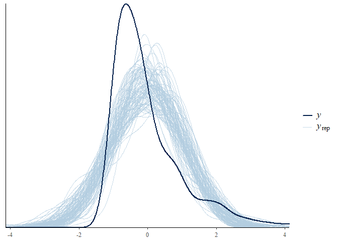

```r
pp_check(like_na, ndraws = 100)
```

Default priors are probably fine here. Note that the observed data has significant skew, which is why the model-implied values are not as cleanly estimated here. That’s ok for now, and this is also how these data are mostly going to be estimated. To keep with convention and to not make these models too wild, we’re going to stick with a Gaussian likelihood for this study rather than introducing the skew_normal distribution into things.

Next, let’s add in the actor & partner effects of internalized stigma with default priors. This is a “proper” actor-partner interdependence model here b/c we are able to specify a compound symmetry correlation structure here.

```r
like_na_1 <- brm(PANAS_disc_neg_actor ~ 0 + Intercept + IHS_mean_actor + IHS_mean_partner + cosy(gr = CoupleID),
              data = data,
              family = gaussian(),
              chains = 4, iter = 2000, warmup = 1000, cores = 4,
              seed = 1234,
              file = "fits/like_na_1",
              file_refit = "on_change"
)
```

Summarize:

```r
summary(like_na_1, prob = .89)
```

```
##  Family: gaussian
##   Links: mu = identity; sigma = identity
## Formula: PANAS_disc_neg_actor ~ 0 + Intercept + IHS_mean_actor + IHS_mean_partner + cosy(gr = CoupleID)
##    Data: data (Number of observations: 162)
##   Draws: 4 chains, each with iter = 2000; warmup = 1000; thin = 1;
##          total post-warmup draws = 4000
##
## Correlation Structures:
##      Estimate Est.Error l-89% CI u-89% CI Rhat Bulk_ESS Tail_ESS
## cosy     0.22      0.10     0.06     0.38 1.00     2418     1309
##
## Regression Coefficients:
##                  Estimate Est.Error l-89% CI u-89% CI Rhat Bulk_ESS Tail_ESS
## Intercept           -0.00      0.09    -0.14     0.13 1.00     4273     2533
## IHS_mean_actor       0.25      0.07     0.14     0.37 1.00     4518     2817
## IHS_mean_partner     0.03      0.08    -0.09     0.16 1.00     3933     2491
##
## Further Distributional Parameters:
##       Estimate Est.Error l-89% CI u-89% CI Rhat Bulk_ESS Tail_ESS
## sigma     0.98      0.06     0.90     1.08 1.00     3717     2768
##
## Draws were sampled using sample(hmc). For each parameter, Bulk_ESS
## and Tail_ESS are effective sample size measures, and Rhat is the potential
## scale reduction factor on split chains (at convergence, Rhat = 1).
```

& PPC:

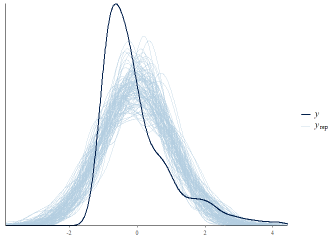

```r
pp_check(like_na_1, ndraws = 100)
```

That’s all pretty good! At least for this specific mediator, we see evidence of a reliably positive actor effect, but not so much for the partner effect. Right now, these models are with the default priors. They’re honestly probably pretty ok here in terms of nothing being too wild or off, but let’s reason through some sensible priors here because it’s quite possible this will matter when we move to the monster of the mediation model.

Let’s get the summary of the default priors here:

```r
prior_summary(like_na_1)
```

```
##                 prior class             coef group resp dpar nlpar lb ub
##                (flat)     b
##                (flat)     b   IHS_mean_actor
##                (flat)     b IHS_mean_partner
##                (flat)     b        Intercept
##                (flat)  cosy                                         0  1
##  student_t(3, 0, 2.5) sigma                                         0
##        source
##       default
##  (vectorized)
##  (vectorized)
##  (vectorized)
##       default
##       default
```

The compound symmetry prior SHOULD be a correlation that allows negative values, but apparently the cosy() terms are bounded to be positive in `brms` by default. There are more details about this issue here: https://github.com/paul-buerkner/brms/issues/878. For the purposes of this study given the size of the model and the relatively sparse data, it’s best to just keep with these defaults. Testing out the implications of this and the programming in Stan is a little beyond my skillset at this point in time, and likely won’t change inference for this study given that we do expect positive correlations for NA here between partners (not negative).

First we have the overall Intercept. This should be close to 0 because we are working with standardized data here. It’s possible it could fluctuate a bit, but it shouldn’t be too wild. A normal(0, 0.25) prior will keep it pretty reasonable.

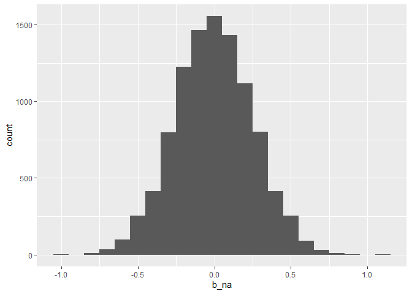

```r
psim <- psim |>
  mutate(b_na = rnorm(1e4, mean = 0, sd = 0.25))
ggplot(psim, aes(x = b_na)) + geom_histogram(binwidth = 0.1)
```

Finally, we have the actor and partner effects of internalized stigma on negative affect. There’s no direct study out there that has tested this, to my knowledge, so we’re going to rely on some broader correlations from prior research. Seager van Dyk et al. (2021) found a .3 correlation between internalized stigma and negative affect in their minority stress induction study, so let’s consider a prior that generally points in a more positive direction but still very well includes 0. Of course, a regression model with more than one parameter in it isn’t technically a correlation coefficient. However, we’re very much in the ballpark here. This prior is also weakly informative enough that the data will probably dominate the posterior.

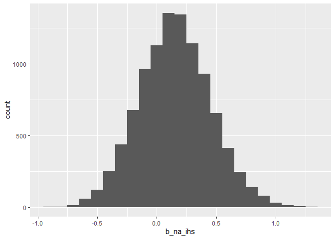

```r
psim <- psim |>
  mutate(b_na_ihs = rnorm(1e4, mean = 0.15, sd = 0.3))
ggplot(psim, aes(x = b_na_ihs)) + geom_histogram(binwidth = 0.1)
```

Proportion below zero:

```r
psim |> summarize(sum = sum(ifelse(b_na_ihs < 0, T, F))/1e4)
```

```
## # A tibble: 1 × 1
##     sum
##   <dbl>
## 1 0.309
```

That seems pretty reasonable! Lots of chances to be near zero or at zero, but still has a more positive slant to it that is reflective of at least one prior study on this topic to inform the direction of effects here.

Because we don’t really know what partner effects of internalized stigma on negative affect would be here, let’s keep that prior a little more agnostic:

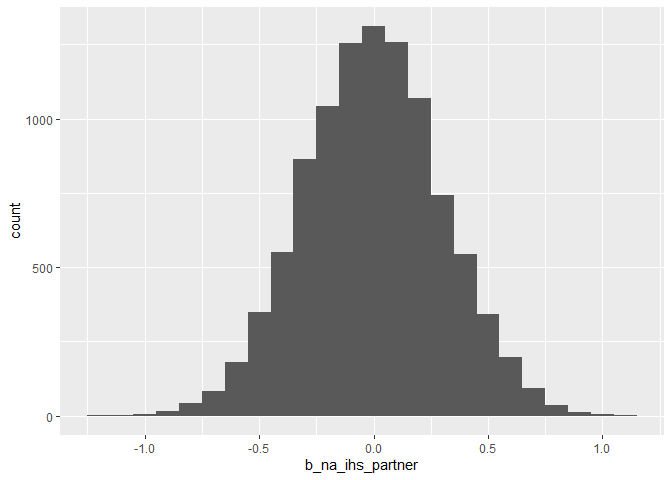

```r
psim <- psim |>
  mutate(b_na_ihs_partner = rnorm(1e4, mean = 0, sd = 0.3))
ggplot(psim, aes(x = b_na_ihs_partner)) + geom_histogram(binwidth = 0.1)
```

Proportion below zero:

```r
psim |> summarize(sum = sum(ifelse(b_na_ihs_partner < 0, T, F))/1e4)
```

```
## # A tibble: 1 × 1
##     sum
##   <dbl>
## 1 0.505
```

Great!

Now with all of these priors in hand, let’s re-run that model. We’ll use the normal Exponential(1) prior for sigma in line with McElreath (2020) as a weakly informative prior for variance estimates.

```r
like_na_2 <- brm(PANAS_disc_neg_actor ~ 0 + Intercept + IHS_mean_actor + IHS_mean_partner + cosy(gr = CoupleID),
              prior = c(prior(normal(0, 0.25), class = b, coef = Intercept),
                        prior(normal(0.15, 0.3), class = b, coef = IHS_mean_actor),
                        prior(normal(0, 0.3), class = b, coef = IHS_mean_partner),
                        prior(exponential(1), class = sigma)),
                 data = data,
              family = gaussian(),
              chains = 4, iter = 2000, warmup = 1000, cores = 4,
              seed = 1234,
              file = "fits/like_na_2",
              file_refit = "on_change"
)
```

Summarize:

```r
summary(like_na_2, prob = .89)
```

```
##  Family: gaussian
##   Links: mu = identity; sigma = identity
## Formula: PANAS_disc_neg_actor ~ 0 + Intercept + IHS_mean_actor + IHS_mean_partner + cosy(gr = CoupleID)
##    Data: data (Number of observations: 162)
##   Draws: 4 chains, each with iter = 2000; warmup = 1000; thin = 1;
##          total post-warmup draws = 4000
##
## Correlation Structures:
##      Estimate Est.Error l-89% CI u-89% CI Rhat Bulk_ESS Tail_ESS
## cosy     0.22      0.10     0.06     0.38 1.00     2971     1573
##
## Regression Coefficients:
##                  Estimate Est.Error l-89% CI u-89% CI Rhat Bulk_ESS Tail_ESS
## Intercept           -0.01      0.08    -0.13     0.12 1.00     5235     2921
## IHS_mean_actor       0.25      0.07     0.13     0.36 1.00     4639     2962
## IHS_mean_partner     0.03      0.07    -0.08     0.15 1.00     4542     2212
##
## Further Distributional Parameters:
##       Estimate Est.Error l-89% CI u-89% CI Rhat Bulk_ESS Tail_ESS
## sigma     0.98      0.06     0.89     1.08 1.00     4546     2938
##
## Draws were sampled using sample(hmc). For each parameter, Bulk_ESS
## and Tail_ESS are effective sample size measures, and Rhat is the potential
## scale reduction factor on split chains (at convergence, Rhat = 1).
```

We see here that the priors had very little influence on these parameter estimates, they’re basically the same as before. However, this can probably help a lot in the bigger models!

#### NA & IPV perpetration

Ok next up in building this out are the actor & partner effects of negative affect on IPV perpetration, which is entered in combination with the actor & partner effects of internalized stigma on IPV perpetration. We’ll have to reason this out separately for psych + physical/SGM perpetration because these are on different scales (log vs. logit).

##### Physical/SGM

Now that we have all of that background information, let’s go ahead and make some sensible priors out of them.

This prior here is similar to the one we used for actor & partner effects for internalized stigma on IPV occurrence. This is based on a mean correlation of .25 from the Birkley & Eckhardt (2015) meta-analysis of emotion issues & IPV perpetration. This corresponds to a Cohen’s d effect size of 0.51, which corresponds to an odds ratio of 2.55. On the logit scale, this would be a coefficient of about 0.94. We’d want this to be included in the regression coefficients.

Let’s verify that with the conversions from `easystats`:

```r
d <- r_to_d(0.25)
d
```

```
## [1] 0.5163978
```

```r
d_to_oddsratio(d)
```

```
## [1] 2.551399
```

And we can also have it appear on the log scale, which makes it an unstandardized regression coefficient:

```r
d_to_oddsratio(d, log = T)
```

```
## [1] 0.936642
```

And then visualize that distribution:

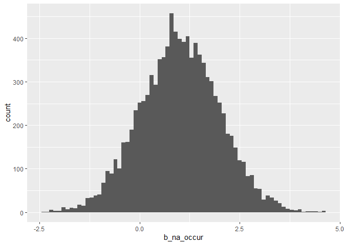

```r
set.seed(1234)
psim <- psim |>
  mutate(b_na_occur = rnorm(1e4, mean = 1, sd = 1))
ggplot(psim, aes(x = b_na_occur)) + geom_histogram(binwidth = 0.1)
```

That seems good enough! It also allows for zero values to come up if they’re present in the data:

```r
psim |> summarize(sum = sum(ifelse(b_na_occur < 0, T, F))/1e4)
```

```
## # A tibble: 1 × 1
##     sum
##   <dbl>
## 1 0.155
```

Of note, this is a little bit of a stronger prior than the one for internalized stigma (though not that dramatic) - I feel more comfortable with this given the body of work linking negative emotions to IPV perpetration is much bigger than the body of work linking internalized stigma to IPV perpetration.

##### Psychological

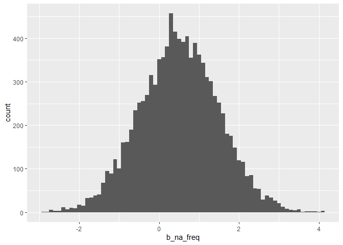

```r
set.seed(1234)
psim <- psim |>
  mutate(b_na_freq = rnorm(1e4, mean = 0.5, sd = 1))
ggplot(psim, aes(x = b_na_freq)) + geom_histogram(binwidth = 0.1)
```

### Covariates

For priors involving covariates, I kept these to be relatively uninformative to let the data tell the story but still keep these parameter estimates within reasonable ranges. For covariates on negative affect scores (CSI, global dyadic coping, discussion order, stressor type, and stressor severity), priors were all normal(0,1) because the outcome was standardized. This is thus a pretty broad prior. For covariates on IPV perpetration (age, relationship length, sexual orientation, gender identity, and race/ethnicity), priors were all normal (0, 0.5).

# Aim 1

Now that we have our priors figured out, let’s go ahead and run those first analyses for aim 1, which is an APIM of internalized stigma (standardized) predicting IPV. First, we’ll run the models with no covariates. Then we’ll run them with. Finally, we’ll do a quick check to see if results are sensitive to our prior specification for both the no covariate and covariate adjusted models.

## No covariates

First, let’s run the models in a group batch here:

```r
aim1_psych <- brm(bf(CTS_psych_perp_HR ~ 0 + Intercept + IHS_mean_actor + IHS_mean_partner + (1 | CoupleID)),
                  prior = c(# prior on mean (log scale)
                            prior(normal(1, 0.5), class = b, coef = Intercept),
                            # priors for frequency
                            prior(normal(0.8, 1), class = b, coef = IHS_mean_actor),
                            prior(normal(0.8, 1), class = b, coef = IHS_mean_partner),
                            # prior on couple variability
                            prior(exponential(1), class = sd),
                            # prior on dispersion parameter
                            prior(exponential(1), class = shape)
                  ),
                  data = data,
                  family = negbinomial(),
                  chains = 4, iter = 3500, warmup = 1000, cores = 4,
                  seed = 1234,
                  control = list(adapt_delta = .99),
                  file = "fits/aim1_psych",
                  file_refit = "on_change"
                  )

aim1_psych_min <- brm(bf(CTS_psych_perp_HR_minor ~ 0 + Intercept + IHS_mean_actor + IHS_mean_partner + (1 | CoupleID)),
                  prior = c(# prior on mean (log scale)
                            prior(normal(1, 0.5), class = b, coef = Intercept),
                            # priors for frequency
                            prior(normal(0.8, 1), class = b, coef = IHS_mean_actor),
                            prior(normal(0.8, 1), class = b, coef = IHS_mean_partner),
                            # prior on couple variability
                            prior(exponential(1), class = sd),
                            # prior on dispersion parameter
                            prior(exponential(1), class = shape)
                  ),
                  data = data,
                  family = negbinomial(),
                  chains = 4, iter = 3500, warmup = 1000, cores = 4,
                  seed = 1234,
                  control = list(adapt_delta = .99),
                  file = "fits/aim1_psych_min",
                  file_refit = "on_change"
                  )
```

[output not shown]

[output cut: 103 more lines]

[output not shown]

```r
aim1_psych_sev <- brm(bf(CTS_psych_perp_HR_severe ~ 0 + Intercept + IHS_mean_actor + IHS_mean_partner + (1 | CoupleID)),
                  prior = c(# prior on mean (log scale) - note same for overall & minor psych aggression
                            prior(normal(1, 0.5), class = b, coef = Intercept),
                            # priors for frequency
                            prior(normal(0.8, 1), class = b, coef = IHS_mean_actor),
                            prior(normal(0.8, 1), class = b, coef = IHS_mean_partner),
                            # prior on couple variability
                            prior(exponential(1), class = sd),
                            # prior on dispersion parameter
                            prior(exponential(1), class = shape)
                  ),
                  data = data,
                  family = negbinomial(),
                  chains = 4, iter = 3500, warmup = 1000, cores = 4,
                  seed = 1234,
                  control = list(adapt_delta = .99),
                  file = "fits/aim1_psych_sev",
                  file_refit = "on_change"
                  )

aim1_phys <- brm(bf(CTS_phys_perp_binary ~ 0 + Intercept + IHS_mean_actor + IHS_mean_partner + (1 | CoupleID)),
                  prior = c(# prior on odds of being 1 (logit scale)
                            prior(normal(1.5, 1), class = b, coef = Intercept),
                            # prior on regression relationship
                            prior(normal(0.5, 0.75), class = b, coef = IHS_mean_actor),
                            prior(normal(0.5, 0.75), class = b, coef = IHS_mean_partner),
                            # prior on couple variability
                            prior(exponential(1), class = sd)
                  ),
                 data = data,
                  family = bernoulli,
                  chains = 4, iter = 2000, warmup = 1000, cores = 4,
                  seed = 1234,
                  file = "fits/aim1_phys",
                  file_refit = "on_change"
                  )

aim1_sgm <- brm(bf(CTS_sgm_perp_binary ~ 0 + Intercept + IHS_mean_actor + IHS_mean_partner + (1 | CoupleID)),
                  prior = c(# prior on odds of being a 1 (logit scale)
                            prior(normal(1.5, 1), class = b, coef = Intercept),
                            # prior on regression relationship
                            prior(normal(0, 0.5), class = b, coef = IHS_mean_actor),
                            prior(normal(0, 0.5), class = b, coef = IHS_mean_partner),
                            # prior on couple variability
                            prior(exponential(1), class = sd)
                  ),
                data = data,
                  family = bernoulli,
                  chains = 4, iter = 2000, warmup = 1000, cores = 4,
                  seed = 1234,
                  file = "fits/aim1_sgm",
                  file_refit = "on_change"
                  )
```

And the sections below are going to parse out those results in a little more detail.

### Psychological

Summarize output:

```r
summary(aim1_psych, prob = .89)
```

```
##  Family: negbinomial
##   Links: mu = log; shape = identity
## Formula: CTS_psych_perp_HR ~ 0 + Intercept + IHS_mean_actor + IHS_mean_partner + (1 | CoupleID)
##    Data: data (Number of observations: 164)
##   Draws: 4 chains, each with iter = 3500; warmup = 1000; thin = 1;
##          total post-warmup draws = 10000
##
## Multilevel Hyperparameters:
## ~CoupleID (Number of levels: 82)
##               Estimate Est.Error l-89% CI u-89% CI Rhat Bulk_ESS Tail_ESS
## sd(Intercept)     1.48      0.14     1.27     1.71 1.00     1935     3120
##
## Regression Coefficients:
##                  Estimate Est.Error l-89% CI u-89% CI Rhat Bulk_ESS Tail_ESS
## Intercept            2.12      0.17     1.85     2.38 1.00     1320     2461
## IHS_mean_actor       0.30      0.12     0.12     0.50 1.00     1573     2643
## IHS_mean_partner     0.24      0.12     0.05     0.43 1.00     1540     2370
##
## Further Distributional Parameters:
##       Estimate Est.Error l-89% CI u-89% CI Rhat Bulk_ESS Tail_ESS
## shape     6.99      1.57     4.76     9.68 1.00     5453     6877
##
## Draws were sampled using sample(hmc). For each parameter, Bulk_ESS
## and Tail_ESS are effective sample size measures, and Rhat is the potential
## scale reduction factor on split chains (at convergence, Rhat = 1).
```

We see here that we have evidence of positive, reliable actor and partner effects of internalized stigma on the frequency of psychological IPV perpetration.

PPC:

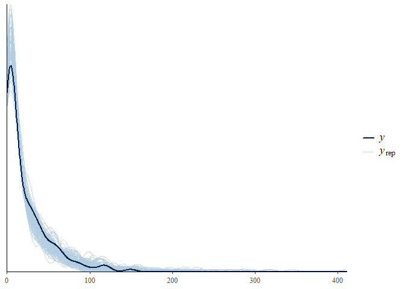

```r
pp_check(aim1_psych, ndraws = 100)
```

We see here that the model does a pretty good job of generating predictiosn that look like our data.

### Psychological - minor

Summarize output:

```r
summary(aim1_psych_min, prob = .89)
```

```
##  Family: negbinomial
##   Links: mu = log; shape = identity
## Formula: CTS_psych_perp_HR_minor ~ 0 + Intercept + IHS_mean_actor + IHS_mean_partner + (1 | CoupleID)
##    Data: data (Number of observations: 168)
##   Draws: 4 chains, each with iter = 3500; warmup = 1000; thin = 1;
##          total post-warmup draws = 10000
##
## Multilevel Hyperparameters:
## ~CoupleID (Number of levels: 84)
##               Estimate Est.Error l-89% CI u-89% CI Rhat Bulk_ESS Tail_ESS
## sd(Intercept)     1.43      0.13     1.22     1.65 1.00     1667     3473
##
## Regression Coefficients:
##                  Estimate Est.Error l-89% CI u-89% CI Rhat Bulk_ESS Tail_ESS
## Intercept            1.96      0.16     1.70     2.21 1.00     1163     2276
## IHS_mean_actor       0.28      0.11     0.11     0.46 1.00     1077     2659
## IHS_mean_partner     0.22      0.11     0.05     0.39 1.00     1081     2497
##
## Further Distributional Parameters:
##       Estimate Est.Error l-89% CI u-89% CI Rhat Bulk_ESS Tail_ESS
## shape     7.34      1.70     4.94    10.25 1.00     5583     6730
##
## Draws were sampled using sample(hmc). For each parameter, Bulk_ESS
## and Tail_ESS are effective sample size measures, and Rhat is the potential
## scale reduction factor on split chains (at convergence, Rhat = 1).
```

We see here that we have evidence of positive, reliable actor and partner effects of internalized stigma on the frequency of psychological IPV perpetration. The results are similar to the overall psych aggression scores.

PPC:

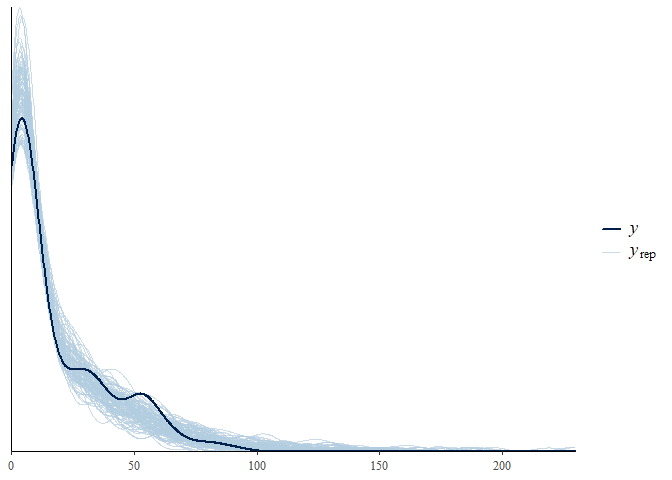

```r
pp_check(aim1_psych_min, ndraws = 100)
```

We see here that the model does a pretty good job of generating predictions that look like our data.

### Psychological - severe

Summarize output:

```r
summary(aim1_psych_sev, prob = .89)
```

```
##  Family: negbinomial
##   Links: mu = log; shape = identity
## Formula: CTS_psych_perp_HR_severe ~ 0 + Intercept + IHS_mean_actor + IHS_mean_partner + (1 | CoupleID)
##    Data: data (Number of observations: 164)
##   Draws: 4 chains, each with iter = 3500; warmup = 1000; thin = 1;
##          total post-warmup draws = 10000
##
## Multilevel Hyperparameters:
## ~CoupleID (Number of levels: 82)
##               Estimate Est.Error l-89% CI u-89% CI Rhat Bulk_ESS Tail_ESS
## sd(Intercept)     2.20      0.28     1.78     2.68 1.00     2319     4354
##
## Regression Coefficients:
##                  Estimate Est.Error l-89% CI u-89% CI Rhat Bulk_ESS Tail_ESS
## Intercept           -0.15      0.25    -0.57     0.25 1.00     2915     4809
## IHS_mean_actor       0.50      0.19     0.21     0.80 1.00     2366     4005
## IHS_mean_partner     0.42      0.19     0.13     0.73 1.00     2404     4366
##
## Further Distributional Parameters:
##       Estimate Est.Error l-89% CI u-89% CI Rhat Bulk_ESS Tail_ESS
## shape     2.54      0.85     1.39     4.05 1.00     5181     5598
##
## Draws were sampled using sample(hmc). For each parameter, Bulk_ESS
## and Tail_ESS are effective sample size measures, and Rhat is the potential
## scale reduction factor on split chains (at convergence, Rhat = 1).
```

We see here that we have evidence of positive, reliable actor and partner effects of internalized stigma on the frequency of psychological IPV perpetration. Results are consistent with the minor & overall psych IPV models, with the exception of the intercept term that is now generally negative and compatible with zero.

PPC:

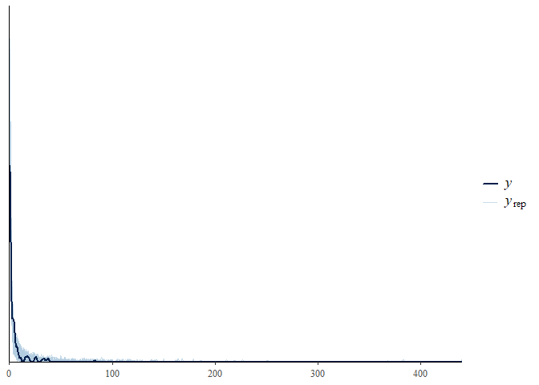

```r
pp_check(aim1_psych_sev, ndraws = 100)
```

We see here that the model generates some predictions that are outside the range of observed data.

### Physical

Summary:

```r
summary(aim1_phys, prob = .89)
```

```
##  Family: bernoulli
##   Links: mu = logit
## Formula: CTS_phys_perp_binary ~ 0 + Intercept + IHS_mean_actor + IHS_mean_partner + (1 | CoupleID)
##    Data: data (Number of observations: 164)
##   Draws: 4 chains, each with iter = 2000; warmup = 1000; thin = 1;
##          total post-warmup draws = 4000
##
## Multilevel Hyperparameters:
## ~CoupleID (Number of levels: 82)
##               Estimate Est.Error l-89% CI u-89% CI Rhat Bulk_ESS Tail_ESS
## sd(Intercept)     2.72      0.70     1.72     3.90 1.00     1965     2441
##
## Regression Coefficients:
##                  Estimate Est.Error l-89% CI u-89% CI Rhat Bulk_ESS Tail_ESS
## Intercept           -2.57      0.46    -3.35    -1.88 1.00     3552     3358
## IHS_mean_actor       0.21      0.32    -0.32     0.74 1.00     4073     3286
## IHS_mean_partner     0.35      0.32    -0.16     0.87 1.00     4080     3138
##
## Draws were sampled using sample(hmc). For each parameter, Bulk_ESS
## and Tail_ESS are effective sample size measures, and Rhat is the potential
## scale reduction factor on split chains (at convergence, Rhat = 1).
```

We see here that there’s an estimated positive effect of actor and partner internalized stigma on the log odds of physical IPV perpetration. However, this effect is pretty variable and not reliably different from zero.

PPC:

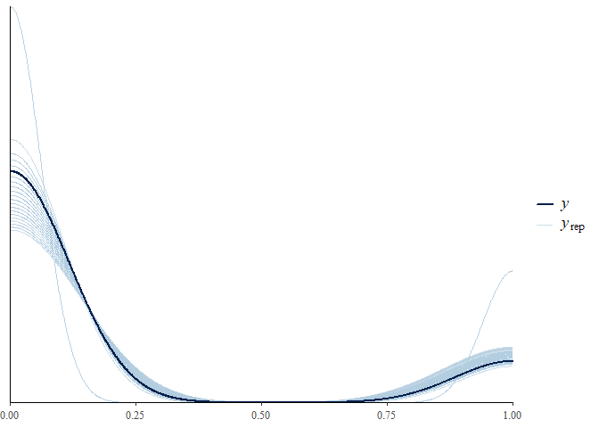

```r
pp_check(aim1_phys, ndraws = 100)
```

We see here that the model does a pretty decent job of predicting probabilities of engaging in physical IPV.

### SGM-specific

Summarize:

```r
summary(aim1_sgm, prob = .89)
```

```
##  Family: bernoulli
##   Links: mu = logit
## Formula: CTS_sgm_perp_binary ~ 0 + Intercept + IHS_mean_actor + IHS_mean_partner + (1 | CoupleID)
##    Data: data (Number of observations: 164)
##   Draws: 4 chains, each with iter = 2000; warmup = 1000; thin = 1;
##          total post-warmup draws = 4000
##
## Multilevel Hyperparameters:
## ~CoupleID (Number of levels: 82)
##               Estimate Est.Error l-89% CI u-89% CI Rhat Bulk_ESS Tail_ESS
## sd(Intercept)     1.16      0.58     0.20     2.07 1.01      816     1152
##
## Regression Coefficients:
##                  Estimate Est.Error l-89% CI u-89% CI Rhat Bulk_ESS Tail_ESS
## Intercept           -2.17      0.36    -2.79    -1.65 1.00     1959     2546
## IHS_mean_actor       0.25      0.22    -0.10     0.59 1.00     4996     3102
## IHS_mean_partner     0.57      0.22     0.23     0.93 1.00     4111     2624
##
## Draws were sampled using sample(hmc). For each parameter, Bulk_ESS
## and Tail_ESS are effective sample size measures, and Rhat is the potential
## scale reduction factor on split chains (at convergence, Rhat = 1).
```

Here we see evidence of a positive, reliable partner internalized stigma effect on log odds of perpetrating SGM-related IPV. There’s an estimated positive effect for actor internalized stigma as well, but this is not reliably different from zero.

PPC:

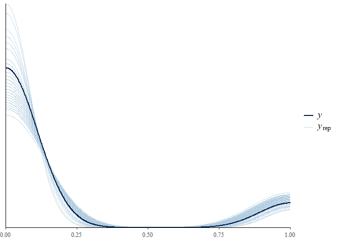

```r
pp_check(aim1_sgm, ndraws = 100)
```

Not a terrible job in predicting probabilities of engaging in aggression.

## Covariates

Now let’s run the models with our chosen covariates to evaluate whether accounting for their potential influence on both internalized stigma and IPV perpetration may change results.

Run all of the models here:

```r
aim1_psych_cov <- brm(bf(CTS_psych_perp_HR ~ 0 + Intercept + IHS_mean_actor + IHS_mean_partner + Age + rel_length_yrs + sxlorx_dich + gender_three + race_dich + (1 | CoupleID)),
                  prior = c(# prior on mean (log scale)
                            prior(normal(1, 0.5), class = b, coef = Intercept),
                            # priors for frequency
                            prior(normal(0.8, 1), class = b, coef = IHS_mean_actor),
                            prior(normal(0.8, 1), class = b, coef = IHS_mean_partner),
                            # priors for covariates
                            prior(normal(0, 0.5), class = b, coef = Age),
                            prior(normal(0, 0.5), class = b, coef = rel_length_yrs),
                            prior(normal(0, 0.5), class = b, coef = sxlorx_dichBiP),
                            prior(normal(0, 0.5), class = b, coef = gender_threeCisman),
                            prior(normal(0, 0.5), class = b, coef = gender_threeGenderdiverse),
                            prior(normal(0, 0.5), class = b, coef = race_dichBIPOC),
                            # prior on couple variability
                            prior(exponential(1), class = sd),
                            # prior on dispersion parameter
                            prior(exponential(1), class = shape)
                  ),
                  data = data,
                  family = negbinomial(),
                  chains = 4, iter = 3500, warmup = 1000, cores = 4,
                  seed = 1234,
                  control = list(adapt_delta = .99),
                  file = "fits/aim1_psych_cov",
                  file_refit = "on_change"
                  )

aim1_psych_cov_min <- brm(bf(CTS_psych_perp_HR_minor ~ 0 + Intercept + IHS_mean_actor + IHS_mean_partner + Age + rel_length_yrs + sxlorx_dich + gender_three + race_dich + (1 | CoupleID)),
                  prior = c(# prior on mean (log scale)
                            prior(normal(1, 0.5), class = b, coef = Intercept),
                            # priors for frequency
                            prior(normal(0.8, 1), class = b, coef = IHS_mean_actor),
                            prior(normal(0.8, 1), class = b, coef = IHS_mean_partner),
                            # priors for covariates
                            prior(normal(0, 0.5), class = b, coef = Age),
                            prior(normal(0, 0.5), class = b, coef = rel_length_yrs),
                            prior(normal(0, 0.5), class = b, coef = sxlorx_dichBiP),
                            prior(normal(0, 0.5), class = b, coef = gender_threeCisman),
                            prior(normal(0, 0.5), class = b, coef = gender_threeGenderdiverse),
                            prior(normal(0, 0.5), class = b, coef = race_dichBIPOC),
                            # prior on couple variability
                            prior(exponential(1), class = sd),
                            # prior on dispersion parameter
                            prior(exponential(1), class = shape)
                  ),
                  data = data,
                  family = negbinomial(),
                  chains = 4, iter = 3500, warmup = 1000, cores = 4,
                  seed = 1234,
                  control = list(adapt_delta = .99),
                  file = "fits/aim1_psych_cov_min",
                  file_refit = "on_change"
                  )

aim1_psych_cov_sev <- brm(bf(CTS_psych_perp_HR_severe ~ 0 + Intercept + IHS_mean_actor + IHS_mean_partner + Age + rel_length_yrs + sxlorx_dich + gender_three + race_dich + (1 | CoupleID)),
                  prior = c(# prior on mean (log scale)
                            prior(normal(1, 0.5), class = b, coef = Intercept),
                            # priors for frequency
                            prior(normal(0.8, 1), class = b, coef = IHS_mean_actor),
                            prior(normal(0.8, 1), class = b, coef = IHS_mean_partner),
                            # priors for covariates
                            prior(normal(0, 0.5), class = b, coef = Age),
                            prior(normal(0, 0.5), class = b, coef = rel_length_yrs),
                            prior(normal(0, 0.5), class = b, coef = sxlorx_dichBiP),
                            prior(normal(0, 0.5), class = b, coef = gender_threeCisman),
                            prior(normal(0, 0.5), class = b, coef = gender_threeGenderdiverse),
                            prior(normal(0, 0.5), class = b, coef = race_dichBIPOC),
                            # prior on couple variability
                            prior(exponential(1), class = sd),
                            # prior on dispersion parameter
                            prior(exponential(1), class = shape)
                  ),
                  data = data,
                  family = negbinomial(),
                  chains = 4, iter = 3500, warmup = 1000, cores = 4,
                  seed = 1234,
                  control = list(adapt_delta = .99),
                  file = "fits/aim1_psych_cov_sev",
                  file_refit = "on_change"
                  )

aim1_phys_cov <- brm(bf(CTS_phys_perp_binary ~ 0 + Intercept + IHS_mean_actor + IHS_mean_partner + Age + rel_length_yrs + sxlorx_dich + gender_three + race_dich + (1 | CoupleID)),
                  prior = c(# prior on odds of being 1 (logit scale)
                            prior(normal(1.5, 1), class = b, coef = Intercept),
                            # prior on regression relationship
                            prior(normal(0.5, 0.75), class = b, coef = IHS_mean_actor),
                            prior(normal(0.5, 0.75), class = b, coef = IHS_mean_partner),
                            # priors for covariates
                            prior(normal(0, 0.5), class = b, coef = Age),
                            prior(normal(0, 0.5), class = b, coef = rel_length_yrs),
                            prior(normal(0, 0.5), class = b, coef = sxlorx_dichBiP),
                            prior(normal(0, 0.5), class = b, coef = gender_threeCisman),
                            prior(normal(0, 0.5), class = b, coef = gender_threeGenderdiverse),
                            prior(normal(0, 0.5), class = b, coef = race_dichBIPOC),
                            # prior on couple variability
                            prior(exponential(1), class = sd)
                  ),
                 data = data,
                  family = bernoulli,
                  chains = 4, iter = 2000, warmup = 1000, cores = 4,
                  seed = 1234,
                  file = "fits/aim1_phys_cov",
                  file_refit = "on_change"
                  )

aim1_sgm_cov <- brm(bf(CTS_sgm_perp_binary ~ 0 + Intercept + IHS_mean_actor + IHS_mean_partner + Age + rel_length_yrs + sxlorx_dich + gender_three + race_dich + (1 | CoupleID)),
                  prior = c(# prior on odds of being a 1 (logit scale)
                            prior(normal(1.5, 1), class = b, coef = Intercept),
                            # prior on regression relationship
                            prior(normal(0, 0.5), class = b, coef = IHS_mean_actor),
                            prior(normal(0, 0.5), class = b, coef = IHS_mean_partner),
                            # priors for covariates
                            prior(normal(0, 0.5), class = b, coef = Age),
                            prior(normal(0, 0.5), class = b, coef = rel_length_yrs),
                            prior(normal(0, 0.5), class = b, coef = sxlorx_dichBiP),
                            prior(normal(0, 0.5), class = b, coef = gender_threeCisman),
                            prior(normal(0, 0.5), class = b, coef = gender_threeGenderdiverse),
                            prior(normal(0, 0.5), class = b, coef = race_dichBIPOC),
                            # prior on couple variability
                            prior(exponential(1), class = sd)
                  ),
                data = data,
                  family = bernoulli,
                  chains = 4, iter = 2000, warmup = 1000, cores = 4,
                  seed = 1234,
                  file = "fits/aim1_sgm_cov",
                  file_refit = "on_change"
                  )
```

Then, as before, we’ll go ahead and inspect the results by each type of IPV.

### Psychological

Summarize:

```r
summary(aim1_psych_cov, prob = .89)
```

```
##  Family: negbinomial
##   Links: mu = log; shape = identity
## Formula: CTS_psych_perp_HR ~ 0 + Intercept + IHS_mean_actor + IHS_mean_partner + Age + rel_length_yrs + sxlorx_dich + gender_three + race_dich + (1 | CoupleID)
##    Data: data (Number of observations: 163)
##   Draws: 4 chains, each with iter = 3500; warmup = 1000; thin = 1;
##          total post-warmup draws = 10000
##
## Multilevel Hyperparameters:
## ~CoupleID (Number of levels: 82)
##               Estimate Est.Error l-89% CI u-89% CI Rhat Bulk_ESS Tail_ESS
## sd(Intercept)     1.46      0.14     1.26     1.70 1.00     1652     3081
##
## Regression Coefficients:
##                           Estimate Est.Error l-89% CI u-89% CI Rhat Bulk_ESS
## Intercept                     2.05      0.20     1.71     2.37 1.00     1608
## IHS_mean_actor                0.29      0.11     0.11     0.47 1.00     1223
## IHS_mean_partner              0.22      0.11     0.04     0.40 1.00     1246
## Age                           0.05      0.11    -0.12     0.23 1.00     2432
## rel_length_yrs                0.26      0.17    -0.01     0.52 1.00     1442
## sxlorx_dichBiP               -0.02      0.14    -0.24     0.20 1.00     4164
## gender_threeCisman            0.12      0.23    -0.25     0.48 1.00     2463
## gender_threeGenderdiverse     0.08      0.16    -0.18     0.33 1.00     4820
## race_dichBIPOC                0.05      0.14    -0.18     0.28 1.00     4733
##                           Tail_ESS
## Intercept                     2797
## IHS_mean_actor                2301
## IHS_mean_partner              2214
## Age                           3967
## rel_length_yrs                2225
## sxlorx_dichBiP                5873
## gender_threeCisman            4745
## gender_threeGenderdiverse     6136
## race_dichBIPOC                6652
##
## Further Distributional Parameters:
##       Estimate Est.Error l-89% CI u-89% CI Rhat Bulk_ESS Tail_ESS
## shape     6.53      1.51     4.38     9.14 1.00     4327     6169
##
## Draws were sampled using sample(hmc). For each parameter, Bulk_ESS
## and Tail_ESS are effective sample size measures, and Rhat is the potential
## scale reduction factor on split chains (at convergence, Rhat = 1).
```

### Psychological - minor

Summarize:

```r
summary(aim1_psych_cov_min, prob = .89)
```

```
##  Family: negbinomial
##   Links: mu = log; shape = identity
## Formula: CTS_psych_perp_HR_minor ~ 0 + Intercept + IHS_mean_actor + IHS_mean_partner + Age + rel_length_yrs + sxlorx_dich + gender_three + race_dich + (1 | CoupleID)
##    Data: data (Number of observations: 167)
##   Draws: 4 chains, each with iter = 3500; warmup = 1000; thin = 1;
##          total post-warmup draws = 10000
##
## Multilevel Hyperparameters:
## ~CoupleID (Number of levels: 84)
##               Estimate Est.Error l-89% CI u-89% CI Rhat Bulk_ESS Tail_ESS
## sd(Intercept)     1.40      0.13     1.20     1.63 1.00     2312     3783
##
## Regression Coefficients:
##                           Estimate Est.Error l-89% CI u-89% CI Rhat Bulk_ESS
## Intercept                     1.95      0.19     1.64     2.26 1.00     2098
## IHS_mean_actor                0.27      0.11     0.10     0.44 1.00     1778
## IHS_mean_partner              0.21      0.11     0.03     0.38 1.00     1791
## Age                           0.04      0.11    -0.12     0.21 1.00     3463
## rel_length_yrs                0.28      0.16     0.03     0.53 1.00     1975
## sxlorx_dichBiP               -0.04      0.14    -0.26     0.20 1.00     6029
## gender_threeCisman            0.08      0.23    -0.27     0.45 1.00     3395
## gender_threeGenderdiverse     0.09      0.16    -0.16     0.34 1.00     6372
## race_dichBIPOC               -0.02      0.14    -0.24     0.21 1.00     6711
##                           Tail_ESS
## Intercept                     3961
## IHS_mean_actor                3591
## IHS_mean_partner              3416
## Age                           5097
## rel_length_yrs                4031
## sxlorx_dichBiP                6618
## gender_threeCisman            4729
## gender_threeGenderdiverse     6837
## race_dichBIPOC                7212
##
## Further Distributional Parameters:
##       Estimate Est.Error l-89% CI u-89% CI Rhat Bulk_ESS Tail_ESS
## shape     6.91      1.67     4.52     9.84 1.00     4765     5656
##
## Draws were sampled using sample(hmc). For each parameter, Bulk_ESS
## and Tail_ESS are effective sample size measures, and Rhat is the potential
## scale reduction factor on split chains (at convergence, Rhat = 1).
```

Generally, covariates were not reliably related to psychological IPV perpetration with the exception of relationship length, which just barely passed over the 0 threshold. We also see that the estimates of the actor & partner effects are pretty similar, though they decrease slightly.

### Psychological - severe

Summarize:

```r
summary(aim1_psych_cov_sev, prob = .89)
```

```
##  Family: negbinomial
##   Links: mu = log; shape = identity
## Formula: CTS_psych_perp_HR_severe ~ 0 + Intercept + IHS_mean_actor + IHS_mean_partner + Age + rel_length_yrs + sxlorx_dich + gender_three + race_dich + (1 | CoupleID)
##    Data: data (Number of observations: 163)
##   Draws: 4 chains, each with iter = 3500; warmup = 1000; thin = 1;
##          total post-warmup draws = 10000
##
## Multilevel Hyperparameters:
## ~CoupleID (Number of levels: 82)
##               Estimate Est.Error l-89% CI u-89% CI Rhat Bulk_ESS Tail_ESS
## sd(Intercept)     2.29      0.30     1.85     2.81 1.00     2209     4867
##
## Regression Coefficients:
##                           Estimate Est.Error l-89% CI u-89% CI Rhat Bulk_ESS
## Intercept                    -0.00      0.31    -0.50     0.49 1.00     3153
## IHS_mean_actor                0.50      0.20     0.19     0.82 1.00     1927
## IHS_mean_partner              0.41      0.20     0.09     0.72 1.00     1923
## Age                           0.05      0.22    -0.29     0.39 1.00     3103
## rel_length_yrs                0.21      0.26    -0.20     0.62 1.00     2525
## sxlorx_dichBiP               -0.26      0.26    -0.68     0.17 1.00     6672
## gender_threeCisman           -0.19      0.36    -0.77     0.38 1.00     5077
## gender_threeGenderdiverse    -0.23      0.29    -0.70     0.24 1.00     7000
## race_dichBIPOC                0.18      0.28    -0.27     0.63 1.00     5993
##                           Tail_ESS
## Intercept                     5314
## IHS_mean_actor                3553
## IHS_mean_partner              3711
## Age                           4874
## rel_length_yrs                3664
## sxlorx_dichBiP                7206
## gender_threeCisman            6708
## gender_threeGenderdiverse     7492
## race_dichBIPOC                6897
##
## Further Distributional Parameters:
##       Estimate Est.Error l-89% CI u-89% CI Rhat Bulk_ESS Tail_ESS
## shape     2.39      0.82     1.30     3.85 1.00     4199     5135
##
## Draws were sampled using sample(hmc). For each parameter, Bulk_ESS
## and Tail_ESS are effective sample size measures, and Rhat is the potential
## scale reduction factor on split chains (at convergence, Rhat = 1).
```

### Physical

Summarize:

```r
summary(aim1_phys_cov, prob = .89)
```

```
##  Family: bernoulli
##   Links: mu = logit
## Formula: CTS_phys_perp_binary ~ 0 + Intercept + IHS_mean_actor + IHS_mean_partner + Age + rel_length_yrs + sxlorx_dich + gender_three + race_dich + (1 | CoupleID)
##    Data: data (Number of observations: 163)
##   Draws: 4 chains, each with iter = 2000; warmup = 1000; thin = 1;
##          total post-warmup draws = 4000
##
## Multilevel Hyperparameters:
## ~CoupleID (Number of levels: 82)
##               Estimate Est.Error l-89% CI u-89% CI Rhat Bulk_ESS Tail_ESS
## sd(Intercept)     2.97      0.75     1.91     4.24 1.00     2026     2508
##
## Regression Coefficients:
##                           Estimate Est.Error l-89% CI u-89% CI Rhat Bulk_ESS
## Intercept                    -2.18      0.54    -3.09    -1.34 1.00     3632
## IHS_mean_actor                0.23      0.34    -0.31     0.77 1.00     3867
## IHS_mean_partner              0.34      0.34    -0.18     0.90 1.00     3556
## Age                          -0.09      0.35    -0.63     0.45 1.00     4590
## rel_length_yrs                0.31      0.35    -0.24     0.85 1.00     3718
## sxlorx_dichBiP               -0.60      0.42    -1.26     0.06 1.00     6023
## gender_threeCisman           -0.07      0.46    -0.81     0.67 1.00     5686
## gender_threeGenderdiverse    -0.34      0.44    -1.06     0.34 1.00     5969
## race_dichBIPOC               -0.35      0.43    -1.04     0.33 1.00     5930
##                           Tail_ESS
## Intercept                     2795
## IHS_mean_actor                2842
## IHS_mean_partner              2850
## Age                           3422
## rel_length_yrs                3233
## sxlorx_dichBiP                3071
## gender_threeCisman            2477
## gender_threeGenderdiverse     2811
## race_dichBIPOC                2783
##
## Draws were sampled using sample(hmc). For each parameter, Bulk_ESS
## and Tail_ESS are effective sample size measures, and Rhat is the potential
## scale reduction factor on split chains (at convergence, Rhat = 1).
```

We see here the covariates aren’t reliably different from 0, and the actor & partner effect estimates don’t really change.

### SGM-specific

Summarize:

```r
summary(aim1_sgm_cov, prob = .89)
```

```
##  Family: bernoulli
##   Links: mu = logit
## Formula: CTS_sgm_perp_binary ~ 0 + Intercept + IHS_mean_actor + IHS_mean_partner + Age + rel_length_yrs + sxlorx_dich + gender_three + race_dich + (1 | CoupleID)
##    Data: data (Number of observations: 163)
##   Draws: 4 chains, each with iter = 2000; warmup = 1000; thin = 1;
##          total post-warmup draws = 4000
##
## Multilevel Hyperparameters:
## ~CoupleID (Number of levels: 82)
##               Estimate Est.Error l-89% CI u-89% CI Rhat Bulk_ESS Tail_ESS
## sd(Intercept)     1.37      0.63     0.28     2.36 1.01      467      575
##
## Regression Coefficients:
##                           Estimate Est.Error l-89% CI u-89% CI Rhat Bulk_ESS
## Intercept                    -2.03      0.45    -2.78    -1.33 1.00     2280
## IHS_mean_actor                0.25      0.24    -0.13     0.64 1.00     4522
## IHS_mean_partner              0.58      0.23     0.22     0.96 1.00     3839
## Age                          -0.07      0.27    -0.51     0.36 1.00     4321
## rel_length_yrs                0.02      0.27    -0.41     0.44 1.00     3993
## sxlorx_dichBiP               -0.26      0.38    -0.86     0.35 1.00     4205
## gender_threeCisman           -0.23      0.40    -0.88     0.41 1.00     4865
## gender_threeGenderdiverse    -0.41      0.41    -1.08     0.24 1.00     5647
## race_dichBIPOC                0.13      0.38    -0.46     0.73 1.00     4959
##                           Tail_ESS
## Intercept                     2822
## IHS_mean_actor                2737
## IHS_mean_partner              3085
## Age                           2787
## rel_length_yrs                3163
## sxlorx_dichBiP                2989
## gender_threeCisman            3216
## gender_threeGenderdiverse     3070
## race_dichBIPOC                2991
##
## Draws were sampled using sample(hmc). For each parameter, Bulk_ESS
## and Tail_ESS are effective sample size measures, and Rhat is the potential
## scale reduction factor on split chains (at convergence, Rhat = 1).
```

Again, not much of a change.

## Sensitivity to priors

Let’s see how sensitive those results are to the priors we set for the actor & partner effects. Let’s first look at the models without covariates.

```r
aim1_psych_1 <- brm(bf(CTS_psych_perp_HR ~ 0 + Intercept + IHS_mean_actor + IHS_mean_partner + (1 | CoupleID)),
                  prior = c(# prior on mean (log scale)
                            prior(normal(1, 0.5), class = b, coef = Intercept),
                            # prior on couple variability
                            prior(exponential(1), class = sd),
                            # prior on dispersion parameter
                            prior(exponential(1), class = shape)
                  ),
                  data = data,
                  family = negbinomial(),
                  chains = 4, iter = 2000, warmup = 1000, cores = 4,
                  seed = 1234,
                  file = "fits/aim1_psych_1",
                  file_refit = "on_change"
                  )

aim1_psych_1_min <- brm(bf(CTS_psych_perp_HR_minor ~ 0 + Intercept + IHS_mean_actor + IHS_mean_partner + (1 | CoupleID)),
                  prior = c(# prior on mean (log scale)
                            prior(normal(1, 0.5), class = b, coef = Intercept),
                            # prior on couple variability
                            prior(exponential(1), class = sd),
                            # prior on dispersion parameter
                            prior(exponential(1), class = shape)
                  ),
                  data = data,
                  family = negbinomial(),
                  chains = 4, iter = 2000, warmup = 1000, cores = 4,
                  seed = 1234,
                  file = "fits/aim1_psych_1_min",
                  file_refit = "on_change"
                  )

aim1_psych_1_sev <- brm(bf(CTS_psych_perp_HR_severe ~ 0 + Intercept + IHS_mean_actor + IHS_mean_partner + (1 | CoupleID)),
                  prior = c(# prior on mean (log scale)
                            prior(normal(1, 0.5), class = b, coef = Intercept),
                            # prior on couple variability
                            prior(exponential(1), class = sd),
                            # prior on dispersion parameter
                            prior(exponential(1), class = shape)
                  ),
                  data = data,
                  family = negbinomial(),
                  chains = 4, iter = 2000, warmup = 1000, cores = 4,
                  seed = 1234,
                  file = "fits/aim1_psych_1_sev",
                  file_refit = "on_change"
                  )

aim1_phys_1 <- brm(bf(CTS_phys_perp_binary ~ 0 + Intercept + IHS_mean_actor + IHS_mean_partner + (1 | CoupleID)),
                  prior = c(# prior on odds of being 1 (logit scale)
                            prior(normal(1.5, 1), class = b, coef = Intercept),
                            # prior on couple variability
                            prior(exponential(1), class = sd)
                  ),
                 data = data,
                  family = bernoulli,
                  chains = 4, iter = 2000, warmup = 1000, cores = 4,
                  seed = 1234,
                  file = "fits/aim1_phys_1",
                  file_refit = "on_change"
                  )

aim1_sgm_1 <- brm(bf(CTS_sgm_perp_binary ~ 0 + Intercept + IHS_mean_actor + IHS_mean_partner + (1 | CoupleID)),
                  prior = c(# prior on odds of being a 1 (logit scale)
                            prior(normal(1.5, 1), class = b, coef = Intercept),
                            # prior on couple variability
                            prior(exponential(1), class = sd)
                  ),
                data = data,
                  family = bernoulli,
                  chains = 4, iter = 2000, warmup = 1000, cores = 4,
                  seed = 1234,
                  file = "fits/aim1_sgm_1",
                  file_refit = "on_change"
                  )
```

Summarize:

```r
summary(aim1_psych_1, prob = .89)
```

```
##  Family: negbinomial
##   Links: mu = log; shape = identity
## Formula: CTS_psych_perp_HR ~ 0 + Intercept + IHS_mean_actor + IHS_mean_partner + (1 | CoupleID)
##    Data: data (Number of observations: 164)
##   Draws: 4 chains, each with iter = 2000; warmup = 1000; thin = 1;
##          total post-warmup draws = 4000
##
## Multilevel Hyperparameters:
## ~CoupleID (Number of levels: 82)
##               Estimate Est.Error l-89% CI u-89% CI Rhat Bulk_ESS Tail_ESS
## sd(Intercept)     1.49      0.14     1.28     1.73 1.01      575     1107
##
## Regression Coefficients:
##                  Estimate Est.Error l-89% CI u-89% CI Rhat Bulk_ESS Tail_ESS
## Intercept            2.10      0.17     1.82     2.36 1.01      357      705
## IHS_mean_actor       0.29      0.12     0.11     0.48 1.01      547     1071
## IHS_mean_partner     0.23      0.12     0.04     0.41 1.01      522      974
##
## Further Distributional Parameters:
##       Estimate Est.Error l-89% CI u-89% CI Rhat Bulk_ESS Tail_ESS
## shape     7.00      1.58     4.80     9.84 1.00     2103     2629
##
## Draws were sampled using sample(hmc). For each parameter, Bulk_ESS
## and Tail_ESS are effective sample size measures, and Rhat is the potential
## scale reduction factor on split chains (at convergence, Rhat = 1).
```

```r
summary(aim1_psych_1_min, prob = .89)
```

```
##  Family: negbinomial
##   Links: mu = log; shape = identity
## Formula: CTS_psych_perp_HR_minor ~ 0 + Intercept + IHS_mean_actor + IHS_mean_partner + (1 | CoupleID)
##    Data: data (Number of observations: 168)
##   Draws: 4 chains, each with iter = 2000; warmup = 1000; thin = 1;
##          total post-warmup draws = 4000
##
## Multilevel Hyperparameters:
## ~CoupleID (Number of levels: 84)
##               Estimate Est.Error l-89% CI u-89% CI Rhat Bulk_ESS Tail_ESS
## sd(Intercept)     1.42      0.13     1.22     1.65 1.01      511      950
##
## Regression Coefficients:
##                  Estimate Est.Error l-89% CI u-89% CI Rhat Bulk_ESS Tail_ESS
## Intercept            1.97      0.16     1.72     2.21 1.01      396      838
## IHS_mean_actor       0.27      0.11     0.09     0.44 1.01      460      828
## IHS_mean_partner     0.20      0.11     0.03     0.37 1.01      445      809
##
## Further Distributional Parameters:
##       Estimate Est.Error l-89% CI u-89% CI Rhat Bulk_ESS Tail_ESS
## shape     7.32      1.74     4.88    10.33 1.00     1847     2469
##
## Draws were sampled using sample(hmc). For each parameter, Bulk_ESS
## and Tail_ESS are effective sample size measures, and Rhat is the potential
## scale reduction factor on split chains (at convergence, Rhat = 1).
```

```r
summary(aim1_psych_1_sev, prob = .89)
```

```
##  Family: negbinomial
##   Links: mu = log; shape = identity
## Formula: CTS_psych_perp_HR_severe ~ 0 + Intercept + IHS_mean_actor + IHS_mean_partner + (1 | CoupleID)
##    Data: data (Number of observations: 164)
##   Draws: 4 chains, each with iter = 2000; warmup = 1000; thin = 1;
##          total post-warmup draws = 4000
##
## Multilevel Hyperparameters:
## ~CoupleID (Number of levels: 82)
##               Estimate Est.Error l-89% CI u-89% CI Rhat Bulk_ESS Tail_ESS
## sd(Intercept)     2.19      0.28     1.79     2.67 1.01      883     1830
##
## Regression Coefficients:
##                  Estimate Est.Error l-89% CI u-89% CI Rhat Bulk_ESS Tail_ESS
## Intercept           -0.13      0.26    -0.54     0.28 1.00     1081     1804
## IHS_mean_actor       0.47      0.19     0.17     0.78 1.01      618     1426
## IHS_mean_partner     0.39      0.19     0.10     0.71 1.01      701     1328
##
## Further Distributional Parameters:
##       Estimate Est.Error l-89% CI u-89% CI Rhat Bulk_ESS Tail_ESS
## shape     2.53      0.85     1.40     4.02 1.00     2023     2579
##
## Draws were sampled using sample(hmc). For each parameter, Bulk_ESS
## and Tail_ESS are effective sample size measures, and Rhat is the potential
## scale reduction factor on split chains (at convergence, Rhat = 1).
```

```r
summary(aim1_phys_1, prob = .89)
```

```
##  Family: bernoulli
##   Links: mu = logit
## Formula: CTS_phys_perp_binary ~ 0 + Intercept + IHS_mean_actor + IHS_mean_partner + (1 | CoupleID)
##    Data: data (Number of observations: 164)
##   Draws: 4 chains, each with iter = 2000; warmup = 1000; thin = 1;
##          total post-warmup draws = 4000
##
## Multilevel Hyperparameters:
## ~CoupleID (Number of levels: 82)
##               Estimate Est.Error l-89% CI u-89% CI Rhat Bulk_ESS Tail_ESS
## sd(Intercept)     2.74      0.73     1.72     3.97 1.00     1940     2179
##
## Regression Coefficients:
##                  Estimate Est.Error l-89% CI u-89% CI Rhat Bulk_ESS Tail_ESS
## Intercept           -2.58      0.46    -3.35    -1.88 1.00     3624     3281
## IHS_mean_actor       0.12      0.37    -0.47     0.70 1.00     3382     2580
## IHS_mean_partner     0.30      0.37    -0.26     0.90 1.00     3035     2663
##
## Draws were sampled using sample(hmc). For each parameter, Bulk_ESS
## and Tail_ESS are effective sample size measures, and Rhat is the potential
## scale reduction factor on split chains (at convergence, Rhat = 1).
```

```r
summary(aim1_sgm_1, prob = .89)
```

```
##  Family: bernoulli
##   Links: mu = logit
## Formula: CTS_sgm_perp_binary ~ 0 + Intercept + IHS_mean_actor + IHS_mean_partner + (1 | CoupleID)
##    Data: data (Number of observations: 164)
##   Draws: 4 chains, each with iter = 2000; warmup = 1000; thin = 1;
##          total post-warmup draws = 4000
##
## Multilevel Hyperparameters:
## ~CoupleID (Number of levels: 82)
##               Estimate Est.Error l-89% CI u-89% CI Rhat Bulk_ESS Tail_ESS
## sd(Intercept)     1.27      0.63     0.23     2.28 1.00      576      966
##
## Regression Coefficients:
##                  Estimate Est.Error l-89% CI u-89% CI Rhat Bulk_ESS Tail_ESS
## Intercept           -2.25      0.40    -2.95    -1.67 1.00     1299     2177
## IHS_mean_actor       0.33      0.26    -0.08     0.75 1.00     2828     2424
## IHS_mean_partner     0.73      0.27     0.32     1.20 1.00     1887     1870
##
## Draws were sampled using sample(hmc). For each parameter, Bulk_ESS
## and Tail_ESS are effective sample size measures, and Rhat is the potential
## scale reduction factor on split chains (at convergence, Rhat = 1).
```

Now let’s look at the models with covariates:

```r
aim1_psych_cov_1 <- brm(bf(CTS_psych_perp_HR ~ 0 + Intercept + IHS_mean_actor + IHS_mean_partner + Age + rel_length_yrs + sxlorx_dich + gender_three + race_dich + (1 | CoupleID)),
                  prior = c(# prior on mean (log scale)
                            prior(normal(1, 0.5), class = b, coef = Intercept),
                            # prior on couple variability
                            prior(exponential(1), class = sd),
                            # prior on dispersion parameter
                            prior(exponential(1), class = shape)
                  ),
                  data = data,
                  family = negbinomial(),
                  chains = 4, iter = 3500, warmup = 1000, cores = 4,
                  seed = 1234,
                  control = list(adapt_delta = .99),
                  file = "fits/aim1_psych_cov_1",
                  file_refit = "on_change"
                  )

aim1_psych_cov_1_min <- brm(bf(CTS_psych_perp_HR_minor ~ 0 + Intercept + IHS_mean_actor + IHS_mean_partner + Age + rel_length_yrs + sxlorx_dich + gender_three + race_dich + (1 | CoupleID)),
                  prior = c(# prior on mean (log scale)
                            prior(normal(1, 0.5), class = b, coef = Intercept),
                            # prior on couple variability
                            prior(exponential(1), class = sd),
                            # prior on dispersion parameter
                            prior(exponential(1), class = shape)
                  ),
                  data = data,
                  family = negbinomial(),
                  chains = 4, iter = 3500, warmup = 1000, cores = 4,
                  seed = 1234,
                  control = list(adapt_delta = .99),
                  file = "fits/aim1_psych_cov_1_min",
                  file_refit = "on_change"
                  )

aim1_psych_cov_1_sev <- brm(bf(CTS_psych_perp_HR_severe ~ 0 + Intercept + IHS_mean_actor + IHS_mean_partner + Age + rel_length_yrs + sxlorx_dich + gender_three + race_dich + (1 | CoupleID)),
                  prior = c(# prior on mean (log scale)
                            prior(normal(1, 0.5), class = b, coef = Intercept),
                            # prior on couple variability
                            prior(exponential(1), class = sd),
                            # prior on dispersion parameter
                            prior(exponential(1), class = shape)
                  ),
                  data = data,
                  family = negbinomial(),
                  chains = 4, iter = 3500, warmup = 1000, cores = 4,
                  seed = 1234,
                  control = list(adapt_delta = .99),
                  file = "fits/aim1_psych_cov_1_sev",
                  file_refit = "on_change"
                  )

aim1_phys_cov_1 <- brm(bf(CTS_phys_perp_binary ~ 0 + Intercept + IHS_mean_actor + IHS_mean_partner + Age + rel_length_yrs + sxlorx_dich + gender_three + race_dich + (1 | CoupleID)),
                  prior = c(# prior on odds of being 1 (logit scale)
                            prior(normal(1.5, 1), class = b, coef = Intercept),
                            # prior on couple variability
                            prior(exponential(1), class = sd)
                  ),
                 data = data,
                  family = bernoulli,
                  chains = 4, iter = 2000, warmup = 1000, cores = 4,
                  seed = 1234,
                  file = "fits/aim1_phys_cov_1",
                  file_refit = "on_change"
                  )

aim1_sgm_cov_1 <- brm(bf(CTS_sgm_perp_binary ~ 0 + Intercept + IHS_mean_actor + IHS_mean_partner + Age + rel_length_yrs + sxlorx_dich + gender_three + race_dich + (1 | CoupleID)),
                  prior = c(# prior on odds of being a 1 (logit scale)
                            prior(normal(1.5, 1), class = b, coef = Intercept),
                            # prior on couple variability
                            prior(exponential(1), class = sd)
                  ),
                data = data,
                  family = bernoulli,
                  chains = 4, iter = 2000, warmup = 1000, cores = 4,
                  seed = 1234,
                  file = "fits/aim1_sgm_cov_1",
                  file_refit = "on_change"
                  )
```

Summary:

```r
summary(aim1_psych_cov_1, prob = .89)
```

```
##  Family: negbinomial
##   Links: mu = log; shape = identity
## Formula: CTS_psych_perp_HR ~ 0 + Intercept + IHS_mean_actor + IHS_mean_partner + Age + rel_length_yrs + sxlorx_dich + gender_three + race_dich + (1 | CoupleID)
##    Data: data (Number of observations: 163)
##   Draws: 4 chains, each with iter = 3500; warmup = 1000; thin = 1;
##          total post-warmup draws = 10000
##
## Multilevel Hyperparameters:
## ~CoupleID (Number of levels: 82)
##               Estimate Est.Error l-89% CI u-89% CI Rhat Bulk_ESS Tail_ESS
## sd(Intercept)     1.47      0.14     1.26     1.71 1.00     1815     3408
##
## Regression Coefficients:
##                           Estimate Est.Error l-89% CI u-89% CI Rhat Bulk_ESS
## Intercept                     2.03      0.21     1.69     2.37 1.00     1790
## IHS_mean_actor                0.27      0.12     0.08     0.47 1.00     1383
## IHS_mean_partner              0.21      0.12     0.01     0.40 1.00     1395
## Age                           0.05      0.12    -0.13     0.24 1.00     2350
## rel_length_yrs                0.30      0.18     0.02     0.58 1.00     1252
## sxlorx_dichBiP               -0.02      0.15    -0.26     0.22 1.00     4488
## gender_threeCisman            0.15      0.26    -0.26     0.57 1.00     2475
## gender_threeGenderdiverse     0.10      0.17    -0.18     0.37 1.00     4786
## race_dichBIPOC                0.06      0.15    -0.18     0.31 1.00     5033
##                           Tail_ESS
## Intercept                     3915
## IHS_mean_actor                2622
## IHS_mean_partner              2926
## Age                           3853
## rel_length_yrs                2313
## sxlorx_dichBiP                5803
## gender_threeCisman            4237
## gender_threeGenderdiverse     6173
## race_dichBIPOC                6230
##
## Further Distributional Parameters:
##       Estimate Est.Error l-89% CI u-89% CI Rhat Bulk_ESS Tail_ESS
## shape     6.45      1.48     4.33     8.93 1.00     4765     6042
##
## Draws were sampled using sample(hmc). For each parameter, Bulk_ESS
## and Tail_ESS are effective sample size measures, and Rhat is the potential
## scale reduction factor on split chains (at convergence, Rhat = 1).
```

```r
summary(aim1_psych_cov_1_min, prob = .89)
```

```
##  Family: negbinomial
##   Links: mu = log; shape = identity
## Formula: CTS_psych_perp_HR_minor ~ 0 + Intercept + IHS_mean_actor + IHS_mean_partner + Age + rel_length_yrs + sxlorx_dich + gender_three + race_dich + (1 | CoupleID)
##    Data: data (Number of observations: 167)
##   Draws: 4 chains, each with iter = 3500; warmup = 1000; thin = 1;
##          total post-warmup draws = 10000
##
## Multilevel Hyperparameters:
## ~CoupleID (Number of levels: 84)
##               Estimate Est.Error l-89% CI u-89% CI Rhat Bulk_ESS Tail_ESS
## sd(Intercept)     1.41      0.14     1.20     1.64 1.00     1558     3346
##
## Regression Coefficients:
##                           Estimate Est.Error l-89% CI u-89% CI Rhat Bulk_ESS
## Intercept                     1.93      0.20     1.61     2.25 1.00     2282
## IHS_mean_actor                0.26      0.11     0.08     0.44 1.00     1355
## IHS_mean_partner              0.19      0.11     0.02     0.38 1.00     1405
## Age                           0.03      0.11    -0.14     0.21 1.00     2973
## rel_length_yrs                0.31      0.18     0.03     0.59 1.00     1217
## sxlorx_dichBiP               -0.05      0.15    -0.28     0.20 1.00     4427
## gender_threeCisman            0.11      0.26    -0.31     0.52 1.00     2288
## gender_threeGenderdiverse     0.11      0.17    -0.16     0.38 1.00     4253
## race_dichBIPOC               -0.01      0.15    -0.25     0.23 1.00     4740
##                           Tail_ESS
## Intercept                     3462
## IHS_mean_actor                2409
## IHS_mean_partner              2373
## Age                           4448
## rel_length_yrs                2599
## sxlorx_dichBiP                6557
## gender_threeCisman            4081
## gender_threeGenderdiverse     6178
## race_dichBIPOC                6329
##
## Further Distributional Parameters:
##       Estimate Est.Error l-89% CI u-89% CI Rhat Bulk_ESS Tail_ESS
## shape     6.86      1.67     4.52     9.77 1.00     4352     5898
##
## Draws were sampled using sample(hmc). For each parameter, Bulk_ESS
## and Tail_ESS are effective sample size measures, and Rhat is the potential
## scale reduction factor on split chains (at convergence, Rhat = 1).
```

```r
summary(aim1_psych_cov_1_sev, prob = .89)
```

```
##  Family: negbinomial
##   Links: mu = log; shape = identity
## Formula: CTS_psych_perp_HR_severe ~ 0 + Intercept + IHS_mean_actor + IHS_mean_partner + Age + rel_length_yrs + sxlorx_dich + gender_three + race_dich + (1 | CoupleID)
##    Data: data (Number of observations: 163)
##   Draws: 4 chains, each with iter = 3500; warmup = 1000; thin = 1;
##          total post-warmup draws = 10000
##
## Multilevel Hyperparameters:
## ~CoupleID (Number of levels: 82)
##               Estimate Est.Error l-89% CI u-89% CI Rhat Bulk_ESS Tail_ESS
## sd(Intercept)     2.36      0.32     1.90     2.90 1.00     2510     4803
##
## Regression Coefficients:
##                           Estimate Est.Error l-89% CI u-89% CI Rhat Bulk_ESS
## Intercept                     0.09      0.34    -0.47     0.63 1.00     5569
## IHS_mean_actor                0.48      0.21     0.15     0.81 1.00     2912
## IHS_mean_partner              0.38      0.21     0.06     0.73 1.00     2939
## Age                           0.03      0.25    -0.36     0.44 1.00     3636
## rel_length_yrs                0.33      0.32    -0.16     0.84 1.00     3110
## sxlorx_dichBiP               -0.38      0.34    -0.92     0.14 1.00     6691
## gender_threeCisman           -0.49      0.53    -1.36     0.35 1.00     3881
## gender_threeGenderdiverse    -0.40      0.39    -1.02     0.21 1.00     6002
## race_dichBIPOC                0.32      0.36    -0.25     0.89 1.00     6082
##                           Tail_ESS
## Intercept                     6950
## IHS_mean_actor                5145
## IHS_mean_partner              4540
## Age                           5717
## rel_length_yrs                4839
## sxlorx_dichBiP                7217
## gender_threeCisman            5436
## gender_threeGenderdiverse     7161
## race_dichBIPOC                7019
##
## Further Distributional Parameters:
##       Estimate Est.Error l-89% CI u-89% CI Rhat Bulk_ESS Tail_ESS
## shape     2.29      0.76     1.28     3.64 1.00     4641     6250
##
## Draws were sampled using sample(hmc). For each parameter, Bulk_ESS
## and Tail_ESS are effective sample size measures, and Rhat is the potential
## scale reduction factor on split chains (at convergence, Rhat = 1).
```

```r
summary(aim1_phys_cov_1, prob = .89)
```

```
##  Family: bernoulli
##   Links: mu = logit
## Formula: CTS_phys_perp_binary ~ 0 + Intercept + IHS_mean_actor + IHS_mean_partner + Age + rel_length_yrs + sxlorx_dich + gender_three + race_dich + (1 | CoupleID)
##    Data: data (Number of observations: 163)
##   Draws: 4 chains, each with iter = 2000; warmup = 1000; thin = 1;
##          total post-warmup draws = 4000
##
## Multilevel Hyperparameters:
## ~CoupleID (Number of levels: 82)
##               Estimate Est.Error l-89% CI u-89% CI Rhat Bulk_ESS Tail_ESS
## sd(Intercept)     6.56      1.97     3.84    10.00 1.00     1310     1888
##
## Regression Coefficients:
##                           Estimate Est.Error l-89% CI u-89% CI Rhat Bulk_ESS
## Intercept                    -0.58      0.87    -1.94     0.89 1.00     2677
## IHS_mean_actor                0.26      0.79    -1.01     1.48 1.00     2008
## IHS_mean_partner              0.50      0.80    -0.74     1.79 1.00     2207
## Age                          -0.92      1.05    -2.71     0.58 1.00     2388
## rel_length_yrs                1.57      1.18    -0.15     3.50 1.00     1865
## sxlorx_dichBiP               -3.32      1.57    -6.00    -1.07 1.00     3414
## gender_threeCisman           -2.80      2.21    -6.59     0.29 1.00     1859
## gender_threeGenderdiverse    -4.06      2.59    -8.84    -0.58 1.00     1736
## race_dichBIPOC               -2.35      1.91    -5.62     0.29 1.00     2779
##                           Tail_ESS
## Intercept                     3042
## IHS_mean_actor                2403
## IHS_mean_partner              2551
## Age                           2212
## rel_length_yrs                2292
## sxlorx_dichBiP                2941
## gender_threeCisman            1565
## gender_threeGenderdiverse     1415
## race_dichBIPOC                2013
##
## Draws were sampled using sample(hmc). For each parameter, Bulk_ESS
## and Tail_ESS are effective sample size measures, and Rhat is the potential
## scale reduction factor on split chains (at convergence, Rhat = 1).
```

```r
summary(aim1_sgm_cov_1, prob = .89)
```

```
##  Family: bernoulli
##   Links: mu = logit
## Formula: CTS_sgm_perp_binary ~ 0 + Intercept + IHS_mean_actor + IHS_mean_partner + Age + rel_length_yrs + sxlorx_dich + gender_three + race_dich + (1 | CoupleID)
##    Data: data (Number of observations: 163)
##   Draws: 4 chains, each with iter = 2000; warmup = 1000; thin = 1;
##          total post-warmup draws = 4000
##
## Multilevel Hyperparameters:
## ~CoupleID (Number of levels: 82)
##               Estimate Est.Error l-89% CI u-89% CI Rhat Bulk_ESS Tail_ESS
## sd(Intercept)     3.57      1.40     1.71     6.05 1.00      850     1354
##
## Regression Coefficients:
##                           Estimate Est.Error l-89% CI u-89% CI Rhat Bulk_ESS
## Intercept                    -1.32      0.75    -2.47    -0.08 1.00     2853
## IHS_mean_actor                0.57      0.54    -0.21     1.47 1.00     2552
## IHS_mean_partner              1.36      0.66     0.54     2.52 1.00     1543
## Age                          -0.39      0.65    -1.48     0.55 1.00     2631
## rel_length_yrs                0.54      0.69    -0.41     1.72 1.00     1942
## sxlorx_dichBiP               -1.58      1.15    -3.52     0.06 1.00     1946
## gender_threeCisman           -3.85      2.42    -8.03    -0.86 1.00     1049
## gender_threeGenderdiverse    -2.77      1.71    -5.80    -0.47 1.00     1735
## race_dichBIPOC                0.91      1.11    -0.71     2.80 1.00     2499
##                           Tail_ESS
## Intercept                     2371
## IHS_mean_actor                1838
## IHS_mean_partner              1392
## Age                           2416
## rel_length_yrs                1757
## sxlorx_dichBiP                2347
## gender_threeCisman            1345
## gender_threeGenderdiverse     1318
## race_dichBIPOC                2201
##
## Draws were sampled using sample(hmc). For each parameter, Bulk_ESS
## and Tail_ESS are effective sample size measures, and Rhat is the potential
## scale reduction factor on split chains (at convergence, Rhat = 1).
```

Ok it looks like our models are not that sensitive to the priors we put on the regression relationships. If anything our priors downwardly bias the estimates there.

## Pulling results for reporting

TO DO: edit this section if needed to pull results for minor/severe

Next we want to pull up the results in a way that makes it easy to report in tables. We’re going to rely on the `tidybayes` package for this.

Let’s do psych IPV:

```r
aim1_draws <- as_draws_df(aim1_psych) |>
  # clean up dataframe
  select(b1_Intercept = b_Intercept,
         b2_Actor_IS = b_IHS_mean_actor,
         b3_Partner_IS = b_IHS_mean_partner) |>
  # exponentiate to get IRR estimate
  mutate(irr1_Intercept = exp(b1_Intercept),
         irr2_Actor_IS = exp(b2_Actor_IS),
         irr3_Partner_IS = exp(b3_Partner_IS))

aim1_draws |>
  pivot_longer(b1_Intercept:irr3_Partner_IS) |>
  group_by(name) |>
  median_qi(value, .width = .89)
```

```
## # A tibble: 6 × 7
##   name            value .lower .upper .width .point .interval
##   <chr>           <dbl>  <dbl>  <dbl>  <dbl> <chr>  <chr>
## 1 b1_Intercept    2.12  1.85    2.38    0.89 median qi
## 2 b2_Actor_IS     0.304 0.117   0.497   0.89 median qi
## 3 b3_Partner_IS   0.239 0.0526  0.431   0.89 median qi
## 4 irr1_Intercept  8.33  6.33   10.8     0.89 median qi
## 5 irr2_Actor_IS   1.36  1.12    1.64    0.89 median qi
## 6 irr3_Partner_IS 1.27  1.05    1.54    0.89 median qi
```

```r
# first, let's get the unstandardized coefficients

unstd_psych_1 <- as_draws_df(aim1_psych) |>
  # isolate just the coefficients of interest
  select(b1_Intercept = b_Intercept,
         b2_Actor_IS = b_IHS_mean_actor,
         b3_Partner_IS = b_IHS_mean_partner) |>
  # put in long format
  pivot_longer(everything()) |>
  group_by(name) |>
  median_qi(value, .width = .89) |>
  # get rid of columns not needed
  select(-.width, -.point, -.interval) |>
  # round values out
  mutate(across(c("value", ".lower", ".upper"), ~ format(round(., 2), nsmall = 2))) |>
  # add brackets to confidence interval terms
  mutate(.lower = paste0('[', .lower),
         .lower = paste0(.lower, ','),
         .upper = paste0(.upper, ']')) |>
  unite(psych_b_CrI, c("value", ".lower", ".upper"), sep = " ", remove = T)
unstd_psych_1
```

```
## # A tibble: 3 × 2
##   name          psych_b_CrI
##   <chr>         <chr>
## 1 b1_Intercept  2.12 [1.85, 2.38]
## 2 b2_Actor_IS   0.30 [0.12, 0.50]
## 3 b3_Partner_IS 0.24 [0.05, 0.43]
```

```r
std_psych_1 <- as_draws_df(aim1_psych) |>
  # isolate just the coefficients of interest
  select(b1_Intercept = b_Intercept,
         b2_Actor_IS = b_IHS_mean_actor,
         b3_Partner_IS = b_IHS_mean_partner) |>
  # exponentiate them - this step was added in
  mutate(b1_Intercept = exp(b1_Intercept),
         b2_Actor_IS = exp(b2_Actor_IS),
         b3_Partner_IS = exp(b3_Partner_IS)) |>
  # put in long format
  pivot_longer(everything()) |>
  group_by(name) |>
  median_qi(value, .width = .89) |>
  # get rid of columns not needed
  select(-.width, -.point, -.interval) |>
  # round values out
  mutate(across(c("value", ".lower", ".upper"), ~ format(round(., 2), nsmall = 2))) |>
  # add brackets to confidence interval terms
  mutate(.lower = paste0('[', .lower),
         .lower = paste0(.lower, ','),
         .upper = paste0(.upper, ']')) |>
  unite(psych_irr_CrI, c("value", ".lower", ".upper"), sep = " ", remove = T)
std_psych_1
```

```
## # A tibble: 3 × 2
##   name          psych_irr_CrI
##   <chr>         <chr>
## 1 b1_Intercept  8.33 [6.33, 10.76]
## 2 b2_Actor_IS   1.36 [1.12,  1.64]
## 3 b3_Partner_IS 1.27 [1.05,  1.54]
```

Doing this with physical:

```r
# first, let's get the unstandardized coefficients

unstd_phys_1 <- as_draws_df(aim1_phys) |>
  # isolate just the coefficients of interest
  select(b1_Intercept = b_Intercept,
         b2_Actor_IS = b_IHS_mean_actor,
         b3_Partner_IS = b_IHS_mean_partner) |>
  # put in long format
  pivot_longer(everything()) |>
  group_by(name) |>
  median_qi(value, .width = .89) |>
  # get rid of columns not needed
  select(-.width, -.point, -.interval) |>
  # round values out
  mutate(across(c("value", ".lower", ".upper"), ~ format(round(., 2), nsmall = 2))) |>
  # add brackets to confidence interval terms
  mutate(.lower = paste0('[', .lower),
         .lower = paste0(.lower, ','),
         .upper = paste0(.upper, ']')) |>
  unite(phys_b_CrI, c("value", ".lower", ".upper"), sep = " ", remove = T)
unstd_phys_1
```

```
## # A tibble: 3 × 2
##   name          phys_b_CrI
##   <chr>         <chr>
## 1 b1_Intercept  "-2.54 [-3.35, -1.88]"
## 2 b2_Actor_IS   " 0.21 [-0.32,  0.74]"
## 3 b3_Partner_IS " 0.35 [-0.16,  0.87]"
```

```r
std_phys_1 <- as_draws_df(aim1_phys) |>
  # isolate just the coefficients of interest
  select(b1_Intercept = b_Intercept,
         b2_Actor_IS = b_IHS_mean_actor,
         b3_Partner_IS = b_IHS_mean_partner) |>
  # exponentiate them - this step was added in
  mutate(b1_Intercept = exp(b1_Intercept),
         b2_Actor_IS = exp(b2_Actor_IS),
         b3_Partner_IS = exp(b3_Partner_IS)) |>
  # put in long format
  pivot_longer(everything()) |>
  group_by(name) |>
  median_qi(value, .width = .89) |>
  # get rid of columns not needed
  select(-.width, -.point, -.interval) |>
  # round values out
  mutate(across(c("value", ".lower", ".upper"), ~ format(round(., 2), nsmall = 2))) |>
  # add brackets to confidence interval terms
  mutate(.lower = paste0('[', .lower),
         .lower = paste0(.lower, ','),
         .upper = paste0(.upper, ']')) |>
  unite(phys_or_CrI, c("value", ".lower", ".upper"), sep = " ", remove = T)
std_phys_1
```

```
## # A tibble: 3 × 2
##   name          phys_or_CrI
##   <chr>         <chr>
## 1 b1_Intercept  0.08 [0.04, 0.15]
## 2 b2_Actor_IS   1.23 [0.73, 2.09]
## 3 b3_Partner_IS 1.42 [0.85, 2.39]
```

SGM-specific:

```r
unstd_sgm_1 <- as_draws_df(aim1_sgm) |>
  # isolate just the coefficients of interest
  select(b1_Intercept = b_Intercept,
         b2_Actor_IS = b_IHS_mean_actor,
         b3_Partner_IS = b_IHS_mean_partner) |>
  # put in long format
  pivot_longer(everything()) |>
  group_by(name) |>
  median_qi(value, .width = .89) |>
  # get rid of columns not needed
  select(-.width, -.point, -.interval) |>
  # round values out
  mutate(across(c("value", ".lower", ".upper"), ~ format(round(., 2), nsmall = 2))) |>
  # add brackets to confidence interval terms
  mutate(.lower = paste0('[', .lower),
         .lower = paste0(.lower, ','),
         .upper = paste0(.upper, ']')) |>
  unite(sgm_b_CrI, c("value", ".lower", ".upper"), sep = " ", remove = T)
unstd_sgm_1
```

```
## # A tibble: 3 × 2
##   name          sgm_b_CrI
##   <chr>         <chr>
## 1 b1_Intercept  "-2.14 [-2.79, -1.65]"
## 2 b2_Actor_IS   " 0.25 [-0.10,  0.59]"
## 3 b3_Partner_IS " 0.57 [ 0.23,  0.93]"
```

```r
std_sgm_1 <- as_draws_df(aim1_sgm) |>
  # isolate just the coefficients of interest
  select(b1_Intercept = b_Intercept,
         b2_Actor_IS = b_IHS_mean_actor,
         b3_Partner_IS = b_IHS_mean_partner) |>
  # exponentiate them - this step was added in
  mutate(b1_Intercept = exp(b1_Intercept),
         b2_Actor_IS = exp(b2_Actor_IS),
         b3_Partner_IS = exp(b3_Partner_IS)) |>
  # put in long format
  pivot_longer(everything()) |>
  group_by(name) |>
  median_qi(value, .width = .89) |>
  # get rid of columns not needed
  select(-.width, -.point, -.interval) |>
  # round values out
  mutate(across(c("value", ".lower", ".upper"), ~ format(round(., 2), nsmall = 2))) |>
  # add brackets to confidence interval terms
  mutate(.lower = paste0('[', .lower),
         .lower = paste0(.lower, ','),
         .upper = paste0(.upper, ']')) |>
  unite(sgm_or_CrI, c("value", ".lower", ".upper"), sep = " ", remove = T)
std_sgm_1
```

```
## # A tibble: 3 × 2
##   name          sgm_or_CrI
##   <chr>         <chr>
## 1 b1_Intercept  0.12 [0.06, 0.19]
## 2 b2_Actor_IS   1.28 [0.91, 1.81]
## 3 b3_Partner_IS 1.77 [1.26, 2.54]
```

Unite all of them together:

```r
aim1_no_cov <- unstd_psych_1 |>
  left_join(std_psych_1) |>
  left_join(unstd_phys_1) |>
  left_join(std_phys_1) |>
  left_join(unstd_sgm_1) |>
  left_join(std_sgm_1)
aim1_no_cov
```

```
## # A tibble: 3 × 7
##   name     psych_b_CrI psych_irr_CrI phys_b_CrI phys_or_CrI sgm_b_CrI sgm_or_CrI
##   <chr>    <chr>       <chr>         <chr>      <chr>       <chr>     <chr>
## 1 b1_Inte… 2.12 [1.85… 8.33 [6.33, … "-2.54 [-… 0.08 [0.04… "-2.14 [… 0.12 [0.0…
## 2 b2_Acto… 0.30 [0.12… 1.36 [1.12, … " 0.21 [-… 1.23 [0.73… " 0.25 [… 1.28 [0.9…
## 3 b3_Part… 0.24 [0.05… 1.27 [1.05, … " 0.35 [-… 1.42 [0.85… " 0.57 [… 1.77 [1.2…
```

Now let’s do the same process for the models with covariates:

```r
unstd_psych_1_cov <- as_draws_df(aim1_psych_cov) |>
  # isolate just the coefficients of interest
  select(b1_Intercept = b_Intercept,
         b2_Actor_IS = b_IHS_mean_actor,
         b3_Partner_IS = b_IHS_mean_partner,
         b4_age = b_Age,
         b5_length = b_rel_length_yrs,
         b6_sxlorx = b_sxlorx_dichBiP,
         b7_cism = b_gender_threeCisman,
         b8_gd = b_gender_threeGenderdiverse,
         b9_poc = b_race_dichBIPOC) |>
  # put in long format
  pivot_longer(everything()) |>
  group_by(name) |>
  median_qi(value, .width = .89) |>
  # get rid of columns not needed
  select(-.width, -.point, -.interval) |>
  # round values out
  mutate(across(c("value", ".lower", ".upper"), ~ format(round(., 2), nsmall = 2))) |>
  # add brackets to confidence interval terms
  mutate(.lower = paste0('[', .lower),
         .lower = paste0(.lower, ','),
         .upper = paste0(.upper, ']')) |>
  unite(psych_b_CrI, c("value", ".lower", ".upper"), sep = " ", remove = T)
unstd_psych_1_cov
```

```
## # A tibble: 9 × 2
##   name          psych_b_CrI
##   <chr>         <chr>
## 1 b1_Intercept  " 2.05 [ 1.71, 2.37]"
## 2 b2_Actor_IS   " 0.29 [ 0.11, 0.47]"
## 3 b3_Partner_IS " 0.22 [ 0.04, 0.40]"
## 4 b4_age        " 0.05 [-0.12, 0.23]"
## 5 b5_length     " 0.26 [-0.01, 0.52]"
## 6 b6_sxlorx     "-0.02 [-0.24, 0.20]"
## 7 b7_cism       " 0.12 [-0.25, 0.48]"
## 8 b8_gd         " 0.08 [-0.18, 0.33]"
## 9 b9_poc        " 0.05 [-0.18, 0.28]"
```

```r
std_psych_1_cov <- as_draws_df(aim1_psych_cov) |>
  # isolate just the coefficients of interest
  select(b1_Intercept = b_Intercept,
         b2_Actor_IS = b_IHS_mean_actor,
         b3_Partner_IS = b_IHS_mean_partner,
         b4_age = b_Age,
         b5_length = b_rel_length_yrs,
         b6_sxlorx = b_sxlorx_dichBiP,
         b7_cism = b_gender_threeCisman,
         b8_gd = b_gender_threeGenderdiverse,
         b9_poc = b_race_dichBIPOC) |>
  # exponentiate them - this step was added in
  mutate(b1_Intercept = exp(b1_Intercept),
         b2_Actor_IS = exp(b2_Actor_IS),
         b3_Partner_IS = exp(b3_Partner_IS),
         b4_age = exp(b4_age),
         b5_length = exp(b5_length),
         b6_sxlorx = exp(b6_sxlorx),
         b7_cism = exp(b7_cism),
         b8_gd = exp(b8_gd),
         b9_poc = exp(b9_poc)) |>
  # put in long format
  pivot_longer(everything()) |>
  group_by(name) |>
  median_qi(value, .width = .89) |>
  # get rid of columns not needed
  select(-.width, -.point, -.interval) |>
  # round values out
  mutate(across(c("value", ".lower", ".upper"), ~ format(round(., 2), nsmall = 2))) |>
  # add brackets to confidence interval terms
  mutate(.lower = paste0('[', .lower),
         .lower = paste0(.lower, ','),
         .upper = paste0(.upper, ']')) |>
  unite(psych_irr_CrI, c("value", ".lower", ".upper"), sep = " ", remove = T)
std_psych_1_cov
```

```
## # A tibble: 9 × 2
##   name          psych_irr_CrI
##   <chr>         <chr>
## 1 b1_Intercept  7.78 [5.55, 10.65]
## 2 b2_Actor_IS   1.33 [1.12,  1.60]
## 3 b3_Partner_IS 1.25 [1.04,  1.50]
## 4 b4_age        1.05 [0.89,  1.26]
## 5 b5_length     1.29 [0.99,  1.68]
## 6 b6_sxlorx     0.98 [0.78,  1.23]
## 7 b7_cism       1.13 [0.78,  1.62]
## 8 b8_gd         1.08 [0.84,  1.39]
## 9 b9_poc        1.06 [0.84,  1.32]
```

Physical:

```r
unstd_phys_1_cov <- as_draws_df(aim1_phys_cov) |>
  # isolate just the coefficients of interest
  select(b1_Intercept = b_Intercept,
         b2_Actor_IS = b_IHS_mean_actor,
         b3_Partner_IS = b_IHS_mean_partner,
         b4_age = b_Age,
         b5_length = b_rel_length_yrs,
         b6_sxlorx = b_sxlorx_dichBiP,
         b7_cism = b_gender_threeCisman,
         b8_gd = b_gender_threeGenderdiverse,
         b9_poc = b_race_dichBIPOC) |>
  # put in long format
  pivot_longer(everything()) |>
  group_by(name) |>
  median_qi(value, .width = .89) |>
  # get rid of columns not needed
  select(-.width, -.point, -.interval) |>
  # round values out
  mutate(across(c("value", ".lower", ".upper"), ~ format(round(., 2), nsmall = 2))) |>
  # add brackets to confidence interval terms
  mutate(.lower = paste0('[', .lower),
         .lower = paste0(.lower, ','),
         .upper = paste0(.upper, ']')) |>
  unite(phys_b_CrI, c("value", ".lower", ".upper"), sep = " ", remove = T)
unstd_phys_1_cov
```

```
## # A tibble: 9 × 2
##   name          phys_b_CrI
##   <chr>         <chr>
## 1 b1_Intercept  "-2.17 [-3.09, -1.34]"
## 2 b2_Actor_IS   " 0.23 [-0.31,  0.77]"
## 3 b3_Partner_IS " 0.34 [-0.18,  0.90]"
## 4 b4_age        "-0.10 [-0.63,  0.45]"
## 5 b5_length     " 0.31 [-0.24,  0.85]"
## 6 b6_sxlorx     "-0.60 [-1.26,  0.06]"
## 7 b7_cism       "-0.06 [-0.81,  0.67]"
## 8 b8_gd         "-0.34 [-1.06,  0.34]"
## 9 b9_poc        "-0.35 [-1.04,  0.33]"
```

```r
std_phys_1_cov <- as_draws_df(aim1_phys_cov) |>
  # isolate just the coefficients of interest
  select(b1_Intercept = b_Intercept,
         b2_Actor_IS = b_IHS_mean_actor,
         b3_Partner_IS = b_IHS_mean_partner,
         b4_age = b_Age,
         b5_length = b_rel_length_yrs,
         b6_sxlorx = b_sxlorx_dichBiP,
         b7_cism = b_gender_threeCisman,
         b8_gd = b_gender_threeGenderdiverse,
         b9_poc = b_race_dichBIPOC) |>
  # exponentiate them - this step was added in
  mutate(b1_Intercept = exp(b1_Intercept),
         b2_Actor_IS = exp(b2_Actor_IS),
         b3_Partner_IS = exp(b3_Partner_IS),
         b4_age = exp(b4_age),
         b5_length = exp(b5_length),
         b6_sxlorx = exp(b6_sxlorx),
         b7_cism = exp(b7_cism),
         b8_gd = exp(b8_gd),
         b9_poc = exp(b9_poc)) |>
  # put in long format
  pivot_longer(everything()) |>
  group_by(name) |>
  median_qi(value, .width = .89) |>
  # get rid of columns not needed
  select(-.width, -.point, -.interval) |>
  # round values out
  mutate(across(c("value", ".lower", ".upper"), ~ format(round(., 2), nsmall = 2))) |>
  # add brackets to confidence interval terms
  mutate(.lower = paste0('[', .lower),
         .lower = paste0(.lower, ','),
         .upper = paste0(.upper, ']')) |>
  unite(phys_or_CrI, c("value", ".lower", ".upper"), sep = " ", remove = T)
std_phys_1_cov
```

```
## # A tibble: 9 × 2
##   name          phys_or_CrI
##   <chr>         <chr>
## 1 b1_Intercept  0.11 [0.05, 0.26]
## 2 b2_Actor_IS   1.26 [0.74, 2.17]
## 3 b3_Partner_IS 1.41 [0.83, 2.45]
## 4 b4_age        0.90 [0.53, 1.57]
## 5 b5_length     1.36 [0.78, 2.33]
## 6 b6_sxlorx     0.55 [0.28, 1.06]
## 7 b7_cism       0.95 [0.45, 1.96]
## 8 b8_gd         0.71 [0.34, 1.40]
## 9 b9_poc        0.71 [0.35, 1.39]
```

SGM-specific:

```r
unstd_sgm_1_cov <- as_draws_df(aim1_sgm_cov) |>
  # isolate just the coefficients of interest
  select(b1_Intercept = b_Intercept,
         b2_Actor_IS = b_IHS_mean_actor,
         b3_Partner_IS = b_IHS_mean_partner,
         b4_age = b_Age,
         b5_length = b_rel_length_yrs,
         b6_sxlorx = b_sxlorx_dichBiP,
         b7_cism = b_gender_threeCisman,
         b8_gd = b_gender_threeGenderdiverse,
         b9_poc = b_race_dichBIPOC) |>
  # put in long format
  pivot_longer(everything()) |>
  group_by(name) |>
  median_qi(value, .width = .89) |>
  # get rid of columns not needed
  select(-.width, -.point, -.interval) |>
  # round values out
  mutate(across(c("value", ".lower", ".upper"), ~ format(round(., 2), nsmall = 2))) |>
  # add brackets to confidence interval terms
  mutate(.lower = paste0('[', .lower),
         .lower = paste0(.lower, ','),
         .upper = paste0(.upper, ']')) |>
  unite(sgm_b_CrI, c("value", ".lower", ".upper"), sep = " ", remove = T)
unstd_sgm_1_cov
```

```
## # A tibble: 9 × 2
##   name          sgm_b_CrI
##   <chr>         <chr>
## 1 b1_Intercept  "-2.01 [-2.78, -1.33]"
## 2 b2_Actor_IS   " 0.26 [-0.13,  0.64]"
## 3 b3_Partner_IS " 0.58 [ 0.22,  0.96]"
## 4 b4_age        "-0.08 [-0.51,  0.36]"
## 5 b5_length     " 0.03 [-0.41,  0.44]"
## 6 b6_sxlorx     "-0.26 [-0.86,  0.35]"
## 7 b7_cism       "-0.23 [-0.88,  0.41]"
## 8 b8_gd         "-0.41 [-1.08,  0.24]"
## 9 b9_poc        " 0.13 [-0.46,  0.73]"
```

```r
std_sgm_1_cov <- as_draws_df(aim1_sgm_cov) |>
  # isolate just the coefficients of interest
  select(b1_Intercept = b_Intercept,
         b2_Actor_IS = b_IHS_mean_actor,
         b3_Partner_IS = b_IHS_mean_partner,
         b4_age = b_Age,
         b5_length = b_rel_length_yrs,
         b6_sxlorx = b_sxlorx_dichBiP,
         b7_cism = b_gender_threeCisman,
         b8_gd = b_gender_threeGenderdiverse,
         b9_poc = b_race_dichBIPOC) |>
  # exponentiate them - this step was added in
  mutate(b1_Intercept = exp(b1_Intercept),
         b2_Actor_IS = exp(b2_Actor_IS),
         b3_Partner_IS = exp(b3_Partner_IS),
         b4_age = exp(b4_age),
         b5_length = exp(b5_length),
         b6_sxlorx = exp(b6_sxlorx),
         b7_cism = exp(b7_cism),
         b8_gd = exp(b8_gd),
         b9_poc = exp(b9_poc)) |>
  # put in long format
  pivot_longer(everything()) |>
  group_by(name) |>
  median_qi(value, .width = .89) |>
  # get rid of columns not needed
  select(-.width, -.point, -.interval) |>
  # round values out
  mutate(across(c("value", ".lower", ".upper"), ~ format(round(., 2), nsmall = 2))) |>
  # add brackets to confidence interval terms
  mutate(.lower = paste0('[', .lower),
         .lower = paste0(.lower, ','),
         .upper = paste0(.upper, ']')) |>
  unite(sgm_or_CrI, c("value", ".lower", ".upper"), sep = " ", remove = T)
std_sgm_1_cov
```

```
## # A tibble: 9 × 2
##   name          sgm_or_CrI
##   <chr>         <chr>
## 1 b1_Intercept  0.13 [0.06, 0.26]
## 2 b2_Actor_IS   1.29 [0.88, 1.89]
## 3 b3_Partner_IS 1.78 [1.25, 2.61]
## 4 b4_age        0.93 [0.60, 1.43]
## 5 b5_length     1.03 [0.66, 1.55]
## 6 b6_sxlorx     0.77 [0.42, 1.42]
## 7 b7_cism       0.80 [0.41, 1.50]
## 8 b8_gd         0.66 [0.34, 1.28]
## 9 b9_poc        1.14 [0.63, 2.08]
```

Now combine models with covariates together:

```r
aim1_cov <- unstd_psych_1_cov |>
  left_join(std_psych_1_cov) |>
  left_join(unstd_phys_1_cov) |>
  left_join(std_phys_1_cov) |>
  left_join(unstd_sgm_1_cov) |>
  left_join(std_sgm_1_cov)
aim1_cov
```

```
## # A tibble: 9 × 7
##   name     psych_b_CrI psych_irr_CrI phys_b_CrI phys_or_CrI sgm_b_CrI sgm_or_CrI
##   <chr>    <chr>       <chr>         <chr>      <chr>       <chr>     <chr>
## 1 b1_Inte… " 2.05 [ 1… 7.78 [5.55, … "-2.17 [-… 0.11 [0.05… "-2.01 [… 0.13 [0.0…
## 2 b2_Acto… " 0.29 [ 0… 1.33 [1.12, … " 0.23 [-… 1.26 [0.74… " 0.26 [… 1.29 [0.8…
## 3 b3_Part… " 0.22 [ 0… 1.25 [1.04, … " 0.34 [-… 1.41 [0.83… " 0.58 [… 1.78 [1.2…
## 4 b4_age   " 0.05 [-0… 1.05 [0.89, … "-0.10 [-… 0.90 [0.53… "-0.08 [… 0.93 [0.6…
## 5 b5_leng… " 0.26 [-0… 1.29 [0.99, … " 0.31 [-… 1.36 [0.78… " 0.03 [… 1.03 [0.6…
## 6 b6_sxlo… "-0.02 [-0… 0.98 [0.78, … "-0.60 [-… 0.55 [0.28… "-0.26 [… 0.77 [0.4…
## 7 b7_cism  " 0.12 [-0… 1.13 [0.78, … "-0.06 [-… 0.95 [0.45… "-0.23 [… 0.80 [0.4…
## 8 b8_gd    " 0.08 [-0… 1.08 [0.84, … "-0.34 [-… 0.71 [0.34… "-0.41 [… 0.66 [0.3…
## 9 b9_poc   " 0.05 [-0… 1.06 [0.84, … "-0.35 [-… 0.71 [0.35… " 0.13 [… 1.14 [0.6…
```

Finally combine all models together:

```r
aim1_output <- rbind(aim1_no_cov, aim1_cov)
aim1_output
```

```
## # A tibble: 12 × 7
##    name    psych_b_CrI psych_irr_CrI phys_b_CrI phys_or_CrI sgm_b_CrI sgm_or_CrI
##    <chr>   <chr>       <chr>         <chr>      <chr>       <chr>     <chr>
##  1 b1_Int… "2.12 [1.8… 8.33 [6.33, … "-2.54 [-… 0.08 [0.04… "-2.14 [… 0.12 [0.0…
##  2 b2_Act… "0.30 [0.1… 1.36 [1.12, … " 0.21 [-… 1.23 [0.73… " 0.25 [… 1.28 [0.9…
##  3 b3_Par… "0.24 [0.0… 1.27 [1.05, … " 0.35 [-… 1.42 [0.85… " 0.57 [… 1.77 [1.2…
##  4 b1_Int… " 2.05 [ 1… 7.78 [5.55, … "-2.17 [-… 0.11 [0.05… "-2.01 [… 0.13 [0.0…
##  5 b2_Act… " 0.29 [ 0… 1.33 [1.12, … " 0.23 [-… 1.26 [0.74… " 0.26 [… 1.29 [0.8…
##  6 b3_Par… " 0.22 [ 0… 1.25 [1.04, … " 0.34 [-… 1.41 [0.83… " 0.58 [… 1.78 [1.2…
##  7 b4_age  " 0.05 [-0… 1.05 [0.89, … "-0.10 [-… 0.90 [0.53… "-0.08 [… 0.93 [0.6…
##  8 b5_len… " 0.26 [-0… 1.29 [0.99, … " 0.31 [-… 1.36 [0.78… " 0.03 [… 1.03 [0.6…
##  9 b6_sxl… "-0.02 [-0… 0.98 [0.78, … "-0.60 [-… 0.55 [0.28… "-0.26 [… 0.77 [0.4…
## 10 b7_cism " 0.12 [-0… 1.13 [0.78, … "-0.06 [-… 0.95 [0.45… "-0.23 [… 0.80 [0.4…
## 11 b8_gd   " 0.08 [-0… 1.08 [0.84, … "-0.34 [-… 0.71 [0.34… "-0.41 [… 0.66 [0.3…
## 12 b9_poc  " 0.05 [-0… 1.06 [0.84, … "-0.35 [-… 0.71 [0.35… " 0.13 [… 1.14 [0.6…
```

& save the output:

```r
write.csv(aim1_output, "output/aim1_output.csv")
```

# Aims 2/3

Ok, now we test negative affect measured after stressor discussions as a mediator between internalized stigma and IPV perpetration.

We’re going to be utilizing a parallel mediation approach for this. See Hayes (2022) Intro to Mediation, Moderation, and Conditional Process Analysis (3rd edition), chapter 5 specifically. Kurz has a brms translation for the second edition: https://bookdown.org/content/b472c7b3-ede5-40f0-9677-75c3704c7e5c/more-than-one-mediator.html#models-with-parallel-and-serial-mediation-properties. In an ideal world, it’d be possible to use a conditional process analysis to describe how indirect effects are moderated. Preliminary analyses though suggested that this would be pretty complicated to do in brms b/c our moderator of interest here (discussion type) is also a repeated measure. However, it does seem tenable to be able to use a parallel mediation approach. Furthermore, it’ll still let us compare the strength & direction of the indirect effects so that’s pretty nice.

As with Aim 1, we’ll do two versions: one with covariates, one without covariates. Of note, we aren’t going to do any sensitivity analyses with the prior specifications b/c we have already done this in the code above (for the direct effect model and when testing out the prior specifications for the negative affect portions of the models).

## No covariates

Following along with Kurz, we’ll go ahead and separate out the different portions of the mediation model into different lists so we can put them all together in the main model code (below).

Setting up the models:

```r
m1_actor <- bf(PANAS_disc_neg_actor ~ 0 + Intercept + IHS_mean_actor + IHS_mean_partner + cosy(gr = CoupleID), family = "gaussian")
m1_partner <- bf(PANAS_disc_neg_partner ~ 0 + Intercept + IHS_mean_actor + IHS_mean_partner + cosy(gr = CoupleID), family = "gaussian")
m2_actor <- bf(PANAS_life_neg_actor ~ 0 + Intercept + IHS_mean_actor + IHS_mean_partner + cosy(gr = CoupleID), family = "gaussian")
m2_partner <- bf(PANAS_life_neg_partner ~ 0 + Intercept + IHS_mean_actor + IHS_mean_partner + cosy(gr = CoupleID), family = "gaussian")

y_mod_psych <- bf(CTS_psych_perp_HR ~ 0 + Intercept +
                    IHS_mean_actor + IHS_mean_partner +
                    PANAS_disc_neg_actor + PANAS_disc_neg_partner +
                    PANAS_life_neg_actor + PANAS_life_neg_partner +
                    (1 | CoupleID), family = "negbinomial")

y_mod_psych_min <- bf(CTS_psych_perp_HR_minor ~ 0 + Intercept +
                    IHS_mean_actor + IHS_mean_partner +
                    PANAS_disc_neg_actor + PANAS_disc_neg_partner +
                    PANAS_life_neg_actor + PANAS_life_neg_partner +
                    (1 | CoupleID), family = "negbinomial")

y_mod_psych_sev <- bf(CTS_psych_perp_HR_severe ~ 0 + Intercept +
                    IHS_mean_actor + IHS_mean_partner +
                    PANAS_disc_neg_actor + PANAS_disc_neg_partner +
                    PANAS_life_neg_actor + PANAS_life_neg_partner +
                    (1 | CoupleID), family = "negbinomial")

y_mod_phys <- bf(CTS_phys_perp_binary ~ 0 + Intercept +
                    IHS_mean_actor + IHS_mean_partner +
                    PANAS_disc_neg_actor + PANAS_disc_neg_partner +
                    PANAS_life_neg_actor + PANAS_life_neg_partner +
                    (1 | CoupleID), family = "bernoulli")

y_mod_sgm <- bf(CTS_sgm_perp_binary ~ 0 + Intercept +
                    IHS_mean_actor + IHS_mean_partner +
                    PANAS_disc_neg_actor + PANAS_disc_neg_partner +
                    PANAS_life_neg_actor + PANAS_life_neg_partner +
                    (1 | CoupleID), family = "bernoulli")
```

### Psychological

Set the priors:

```r
psych_prior <- c(
## IPV PERPETRATION
  # prior on mean (log scale)
  prior(normal(1, 0.5), class = b, coef = Intercept, resp = CTSpsychperpHR),
  # priors for frequency
  prior(normal(0.8, 1), class = b, coef = IHS_mean_actor, resp = CTSpsychperpHR),
  prior(normal(0.8, 1), class = b, coef = IHS_mean_partner, resp = CTSpsychperpHR),
  # priors for negative affect predicting IPV
  prior(normal(0.5, 1), class = b, coef = PANAS_disc_neg_actor, resp = CTSpsychperpHR),
  prior(normal(0.5, 1), class = b, coef = PANAS_disc_neg_partner, resp = CTSpsychperpHR),
  prior(normal(0.5, 1), class = b, coef = PANAS_life_neg_actor, resp = CTSpsychperpHR),
  prior(normal(0.5, 1), class = b, coef = PANAS_life_neg_partner, resp = CTSpsychperpHR),
  # prior on couple variability
  prior(exponential(1), class = sd, resp = CTSpsychperpHR),
  # prior on dispersion parameter
  prior(exponential(1), class = shape, resp = CTSpsychperpHR),

## NEGATIVE AFFECT
  # prior for mean NA
  prior(normal(0, 0.25), class = b, coef = Intercept, resp = PANASdiscnegactor),
  prior(normal(0, 0.25), class = b, coef = Intercept, resp = PANASdiscnegpartner),
  prior(normal(0, 0.25), class = b, coef = Intercept, resp = PANASlifenegactor),
  prior(normal(0, 0.25), class = b, coef = Intercept, resp = PANASlifenegpartner),
  # priors for internalized stigma predicting negative affect
  prior(normal(0.15, 0.3), class = b, coef = IHS_mean_actor, resp = PANASdiscnegactor),
  prior(normal(0.15, 0.3), class = b, coef = IHS_mean_actor, resp = PANASdiscnegpartner),
  prior(normal(0.15, 0.3), class = b, coef = IHS_mean_actor, resp = PANASlifenegactor),
  prior(normal(0.15, 0.3), class = b, coef = IHS_mean_actor, resp = PANASlifenegpartner),
  prior(normal(0, 0.3), class = b, coef = IHS_mean_partner, resp = PANASdiscnegactor),
  prior(normal(0, 0.3), class = b, coef = IHS_mean_partner, resp = PANASdiscnegpartner),
  prior(normal(0, 0.3), class = b, coef = IHS_mean_partner, resp = PANASlifenegactor),
  prior(normal(0, 0.3), class = b, coef = IHS_mean_partner, resp = PANASlifenegpartner),
  # priors for sigma (negative affect)
  prior(exponential(1), class = sigma, resp = PANASdiscnegactor),
  prior(exponential(1), class = sigma, resp = PANASdiscnegpartner),
  prior(exponential(1), class = sigma, resp = PANASlifenegactor),
  prior(exponential(1), class = sigma, resp = PANASlifenegpartner)
)
```

Run the model:

```r
aim3_psych <- brm(m1_actor + m1_partner + m2_actor + m2_partner + y_mod_psych + set_rescor(rescor = F),
                  prior = psych_prior,
                  data = data,
                  chains = 4, iter = 3500, warmup = 1000, cores = 4,
                  seed = 1234,
                  control = list(adapt_delta = .99),
                  file = "fits/aim3_psych",
                  file_refit = "on_change")
```

Check it out:

```r
summary(aim3_psych, prob = .89)
```

```
##  Family: MV(gaussian, gaussian, gaussian, gaussian, negbinomial)
##   Links: mu = identity; sigma = identity
##          mu = identity; sigma = identity
##          mu = identity; sigma = identity
##          mu = identity; sigma = identity
##          mu = log; shape = identity
## Formula: PANAS_disc_neg_actor ~ 0 + Intercept + IHS_mean_actor + IHS_mean_partner + cosy(gr = CoupleID)
##          PANAS_disc_neg_partner ~ 0 + Intercept + IHS_mean_actor + IHS_mean_partner + cosy(gr = CoupleID)
##          PANAS_life_neg_actor ~ 0 + Intercept + IHS_mean_actor + IHS_mean_partner + cosy(gr = CoupleID)
##          PANAS_life_neg_partner ~ 0 + Intercept + IHS_mean_actor + IHS_mean_partner + cosy(gr = CoupleID)
##          CTS_psych_perp_HR ~ 0 + Intercept + IHS_mean_actor + IHS_mean_partner + PANAS_disc_neg_actor + PANAS_disc_neg_partner + PANAS_life_neg_actor + PANAS_life_neg_partner + (1 | CoupleID)
##    Data: data (Number of observations: 158)
##   Draws: 4 chains, each with iter = 3500; warmup = 1000; thin = 1;
##          total post-warmup draws = 10000
##
## Correlation Structures:
##                          Estimate Est.Error l-89% CI u-89% CI Rhat Bulk_ESS
## cosy_PANASdiscnegactor       0.23      0.10     0.07     0.38 1.00     8361
## cosy_PANASdiscnegpartner     0.23      0.10     0.07     0.39 1.00     8006
## cosy_PANASlifenegactor       0.24      0.10     0.08     0.40 1.00     8520
## cosy_PANASlifenegpartner     0.25      0.10     0.08     0.41 1.00     8084
##                          Tail_ESS
## cosy_PANASdiscnegactor       4161
## cosy_PANASdiscnegpartner     3211
## cosy_PANASlifenegactor       4599
## cosy_PANASlifenegpartner     3681
##
## Multilevel Hyperparameters:
## ~CoupleID (Number of levels: 79)
##                              Estimate Est.Error l-89% CI u-89% CI Rhat Bulk_ESS
## sd(CTSpsychperpHR_Intercept)     1.39      0.14     1.19     1.63 1.00     2154
##                              Tail_ESS
## sd(CTSpsychperpHR_Intercept)     3087
##
## Regression Coefficients:
##                                       Estimate Est.Error l-89% CI u-89% CI Rhat
## PANASdiscnegactor_Intercept               0.01      0.08    -0.13     0.13 1.00
## PANASdiscnegactor_IHS_mean_actor          0.27      0.08     0.15     0.39 1.00
## PANASdiscnegactor_IHS_mean_partner        0.05      0.08    -0.08     0.16 1.00
## PANASdiscnegpartner_Intercept             0.00      0.08    -0.12     0.13 1.00
```

[output cut: 38 more lines]

```
## sigma_PANASdiscnegactor       0.98      0.06     0.89     1.08 1.00    15201
## sigma_PANASdiscnegpartner     0.98      0.06     0.89     1.08 1.00    15551
## sigma_PANASlifenegactor       1.01      0.06     0.93     1.11 1.00    15932
## sigma_PANASlifenegpartner     1.02      0.06     0.92     1.12 1.00    16267
## shape_CTSpsychperpHR          6.92      1.63     4.62     9.80 1.00     5430
##                           Tail_ESS
## sigma_PANASdiscnegactor       7265
## sigma_PANASdiscnegpartner     7311
## sigma_PANASlifenegactor       6733
## sigma_PANASlifenegpartner     6847
## shape_CTSpsychperpHR          7224
##
## Draws were sampled using sample(hmc). For each parameter, Bulk_ESS
## and Tail_ESS are effective sample size measures, and Rhat is the potential
## scale reduction factor on split chains (at convergence, Rhat = 1).
```

Calculate indirect effects via the product-of-coefficients approach:

```r
psych_draws <- as_draws_df(aim3_psych)

psych_draws <- psych_draws |>
  # first, rename variables to be consistent with a, b, and c frameworks
  mutate(a1 = b_PANASdiscnegactor_IHS_mean_actor,
         a2 = b_PANASdiscnegpartner_IHS_mean_actor,
         a3 = b_PANASdiscnegactor_IHS_mean_partner,
         a4 = b_PANASdiscnegpartner_IHS_mean_partner,
         b1 = b_CTSpsychperpHR_PANAS_disc_neg_actor,
         b2 = b_CTSpsychperpHR_PANAS_disc_neg_partner,

         a5 = b_PANASlifenegactor_IHS_mean_actor,
         a6 = b_PANASlifenegpartner_IHS_mean_actor,
         a7 = b_PANASlifenegactor_IHS_mean_partner,
         a8 = b_PANASlifenegpartner_IHS_mean_partner,
         b3 = b_CTSpsychperpHR_PANAS_life_neg_actor,
         b4 = b_CTSpsychperpHR_PANAS_life_neg_partner,

         c_prime1 = b_CTSpsychperpHR_IHS_mean_actor,
         c_prime2 = b_CTSpsychperpHR_IHS_mean_partner
         ) |>
  mutate(a1b1 = a1 * b1,
         a2b2 = a2 * b2,
         a3b1 = a3 * b1,
         a4b2 = a4 * b2,

         a5b3 = a5 * b3,
         a6b4 = a6 * b4,
         a7b3 = a7 * b3,
         a8b4 = a8 * b4)
```

Next, we’ll summarize those indirect effects:

```r
psych_draws |>
  select(a1b1:a8b4) |>
  pivot_longer(a1b1:a8b4) |>
  group_by(name) |>
  median_qi(value, .width = .89)
```

```
## # A tibble: 8 × 7
##   name      value   .lower .upper .width .point .interval
##   <chr>     <dbl>    <dbl>  <dbl>  <dbl> <chr>  <chr>
## 1 a1b1  -0.0243   -0.0919  0.0322   0.89 median qi
## 2 a2b2  -0.00166  -0.0293  0.0142   0.89 median qi
## 3 a3b1  -0.00177  -0.0299  0.0139   0.89 median qi
## 4 a4b2  -0.0182   -0.0832  0.0384   0.89 median qi
## 5 a5b3   0.0424    0.00305 0.106    0.89 median qi
## 6 a6b4   0.00391  -0.0471  0.0591   0.89 median qi
## 7 a7b3   0.000910 -0.0425  0.0459   0.89 median qi
## 8 a8b4   0.0497    0.00299 0.121    0.89 median qi
```

We see two indirect effects that are reliably different from zero: a5b3 (actor IS –> actor NA post life stressor discussion –> psych IPV) and a8b4 (partner IS –> partner NA post life stressor discussion –> psych IPV). For Aim 3, we’ll calculate the difference in the size of those indirect effects to see if they are different from the discrimination stressor discussion.

One important thing here is that the two indirect effects that are being compared here are DIFFERENT IN SIGN. Following recommendations from Hayes (2022), we’ll calculate the difference between the absolute values of the indirect effect estimates so we can evaluate whether they differ in strength.

```r
psych_draws <- psych_draws |>
  mutate(comp1 = abs(a5b3) - abs(a1b1),
         comp2 = abs(a8b4) - abs(a4b2))

psych_draws |>
  select(comp1:comp2) |>
  pivot_longer(comp1:comp2) |>
  group_by(name) |>
  median_qi(value, .width = .89)
```

```
## # A tibble: 2 × 7
##   name   value  .lower .upper .width .point .interval
##   <chr>  <dbl>   <dbl>  <dbl>  <dbl> <chr>  <chr>
## 1 comp1 0.0110 -0.0512 0.0718   0.89 median qi
## 2 comp2 0.0207 -0.0419 0.0878   0.89 median qi
```

We see here that these contrasts are not reliably different from zero, which means that the strength of association in the two indirect pathways may overlap substantially.

### Psychological - minor

Set the priors:

```r
psych_prior_min <- c(
## IPV PERPETRATION
  # prior on mean (log scale)
  prior(normal(1, 0.5), class = b, coef = Intercept, resp = CTSpsychperpHRminor),
  # priors for frequency
  prior(normal(0.8, 1), class = b, coef = IHS_mean_actor, resp = CTSpsychperpHRminor),
  prior(normal(0.8, 1), class = b, coef = IHS_mean_partner, resp = CTSpsychperpHRminor),
  # priors for negative affect predicting IPV
  prior(normal(0.5, 1), class = b, coef = PANAS_disc_neg_actor, resp = CTSpsychperpHRminor),
  prior(normal(0.5, 1), class = b, coef = PANAS_disc_neg_partner, resp = CTSpsychperpHRminor),
  prior(normal(0.5, 1), class = b, coef = PANAS_life_neg_actor, resp = CTSpsychperpHRminor),
  prior(normal(0.5, 1), class = b, coef = PANAS_life_neg_partner, resp = CTSpsychperpHRminor),
  # prior on couple variability
  prior(exponential(1), class = sd, resp = CTSpsychperpHRminor),
  # prior on dispersion parameter
  prior(exponential(1), class = shape, resp = CTSpsychperpHRminor),

## NEGATIVE AFFECT
  # prior for mean NA
  prior(normal(0, 0.25), class = b, coef = Intercept, resp = PANASdiscnegactor),
  prior(normal(0, 0.25), class = b, coef = Intercept, resp = PANASdiscnegpartner),
  prior(normal(0, 0.25), class = b, coef = Intercept, resp = PANASlifenegactor),
  prior(normal(0, 0.25), class = b, coef = Intercept, resp = PANASlifenegpartner),
  # priors for internalized stigma predicting negative affect
  prior(normal(0.15, 0.3), class = b, coef = IHS_mean_actor, resp = PANASdiscnegactor),
  prior(normal(0.15, 0.3), class = b, coef = IHS_mean_actor, resp = PANASdiscnegpartner),
  prior(normal(0.15, 0.3), class = b, coef = IHS_mean_actor, resp = PANASlifenegactor),
  prior(normal(0.15, 0.3), class = b, coef = IHS_mean_actor, resp = PANASlifenegpartner),
  prior(normal(0, 0.3), class = b, coef = IHS_mean_partner, resp = PANASdiscnegactor),
  prior(normal(0, 0.3), class = b, coef = IHS_mean_partner, resp = PANASdiscnegpartner),
  prior(normal(0, 0.3), class = b, coef = IHS_mean_partner, resp = PANASlifenegactor),
  prior(normal(0, 0.3), class = b, coef = IHS_mean_partner, resp = PANASlifenegpartner),
  # priors for sigma (negative affect)
  prior(exponential(1), class = sigma, resp = PANASdiscnegactor),
  prior(exponential(1), class = sigma, resp = PANASdiscnegpartner),
  prior(exponential(1), class = sigma, resp = PANASlifenegactor),
  prior(exponential(1), class = sigma, resp = PANASlifenegpartner)
)
```

Run the model:

```r
aim3_psych_min <- brm(m1_actor + m1_partner + m2_actor + m2_partner + y_mod_psych_min + set_rescor(rescor = F),
                  prior = psych_prior_min,
                  data = data,
                  chains = 4, iter = 3500, warmup = 1000, cores = 4,
                  seed = 1234,
                  control = list(adapt_delta = .99),
                  file = "fits/aim3_psych_min",
                  file_refit = "on_change")
```

Check it out:

```r
summary(aim3_psych_min, prob = .89)
```

```
##  Family: MV(gaussian, gaussian, gaussian, gaussian, negbinomial)
##   Links: mu = identity; sigma = identity
##          mu = identity; sigma = identity
##          mu = identity; sigma = identity
##          mu = identity; sigma = identity
##          mu = log; shape = identity
## Formula: PANAS_disc_neg_actor ~ 0 + Intercept + IHS_mean_actor + IHS_mean_partner + cosy(gr = CoupleID)
##          PANAS_disc_neg_partner ~ 0 + Intercept + IHS_mean_actor + IHS_mean_partner + cosy(gr = CoupleID)
##          PANAS_life_neg_actor ~ 0 + Intercept + IHS_mean_actor + IHS_mean_partner + cosy(gr = CoupleID)
##          PANAS_life_neg_partner ~ 0 + Intercept + IHS_mean_actor + IHS_mean_partner + cosy(gr = CoupleID)
##          CTS_psych_perp_HR_minor ~ 0 + Intercept + IHS_mean_actor + IHS_mean_partner + PANAS_disc_neg_actor + PANAS_disc_neg_partner + PANAS_life_neg_actor + PANAS_life_neg_partner + (1 | CoupleID)
##    Data: data (Number of observations: 162)
##   Draws: 4 chains, each with iter = 3500; warmup = 1000; thin = 1;
##          total post-warmup draws = 10000
##
## Correlation Structures:
##                          Estimate Est.Error l-89% CI u-89% CI Rhat Bulk_ESS
## cosy_PANASdiscnegactor       0.22      0.10     0.06     0.38 1.00     5701
## cosy_PANASdiscnegpartner     0.22      0.10     0.06     0.38 1.00     5786
## cosy_PANASlifenegactor       0.25      0.10     0.08     0.41 1.00     5408
## cosy_PANASlifenegpartner     0.25      0.10     0.08     0.41 1.00     6280
##                          Tail_ESS
## cosy_PANASdiscnegactor       2936
## cosy_PANASdiscnegpartner     2943
## cosy_PANASlifenegactor       2663
## cosy_PANASlifenegpartner     2948
##
## Multilevel Hyperparameters:
## ~CoupleID (Number of levels: 81)
##                                   Estimate Est.Error l-89% CI u-89% CI Rhat
## sd(CTSpsychperpHRminor_Intercept)     1.34      0.13     1.15     1.57 1.00
##                                   Bulk_ESS Tail_ESS
## sd(CTSpsychperpHRminor_Intercept)     1558     2626
##
## Regression Coefficients:
##                                            Estimate Est.Error l-89% CI u-89% CI
## PANASdiscnegactor_Intercept                   -0.00      0.08    -0.14     0.13
## PANASdiscnegactor_IHS_mean_actor               0.25      0.07     0.13     0.37
## PANASdiscnegactor_IHS_mean_partner             0.03      0.07    -0.09     0.15
## PANASdiscnegpartner_Intercept                 -0.00      0.08    -0.13     0.13
```

[output cut: 38 more lines]

```
## sigma_PANASdiscnegactor       0.98      0.06     0.89     1.08 1.00    10892
## sigma_PANASdiscnegpartner     0.98      0.06     0.89     1.08 1.00    10038
## sigma_PANASlifenegactor       1.01      0.06     0.92     1.10 1.00     9877
## sigma_PANASlifenegpartner     1.01      0.06     0.92     1.11 1.00    11112
## shape_CTSpsychperpHRminor     7.17      1.70     4.77    10.07 1.00     5045
##                           Tail_ESS
## sigma_PANASdiscnegactor       6963
## sigma_PANASdiscnegpartner     7345
## sigma_PANASlifenegactor       7176
## sigma_PANASlifenegpartner     7720
## shape_CTSpsychperpHRminor     6776
##
## Draws were sampled using sample(hmc). For each parameter, Bulk_ESS
## and Tail_ESS are effective sample size measures, and Rhat is the potential
## scale reduction factor on split chains (at convergence, Rhat = 1).
```

Calculate indirect effects via the product-of-coefficients approach:

```r
psych_draws_min <- as_draws_df(aim3_psych_min)

psych_draws_min <- psych_draws_min |>
  # first, rename variables to be consistent with a, b, and c frameworks
  mutate(a1 = b_PANASdiscnegactor_IHS_mean_actor,
         a2 = b_PANASdiscnegpartner_IHS_mean_actor,
         a3 = b_PANASdiscnegactor_IHS_mean_partner,
         a4 = b_PANASdiscnegpartner_IHS_mean_partner,
         b1 = b_CTSpsychperpHRminor_PANAS_disc_neg_actor,
         b2 = b_CTSpsychperpHRminor_PANAS_disc_neg_partner,

         a5 = b_PANASlifenegactor_IHS_mean_actor,
         a6 = b_PANASlifenegpartner_IHS_mean_actor,
         a7 = b_PANASlifenegactor_IHS_mean_partner,
         a8 = b_PANASlifenegpartner_IHS_mean_partner,
         b3 = b_CTSpsychperpHRminor_PANAS_life_neg_actor,
         b4 = b_CTSpsychperpHRminor_PANAS_life_neg_partner,

         c_prime1 = b_CTSpsychperpHRminor_IHS_mean_actor,
         c_prime2 = b_CTSpsychperpHRminor_IHS_mean_partner
         ) |>
  mutate(a1b1 = a1 * b1,
         a2b2 = a2 * b2,
         a3b1 = a3 * b1,
         a4b2 = a4 * b2,

         a5b3 = a5 * b3,
         a6b4 = a6 * b4,
         a7b3 = a7 * b3,
         a8b4 = a8 * b4)
```

Next, we’ll summarize those indirect effects:

```r
psych_draws_min |>
  select(a1b1:a8b4) |>
  pivot_longer(a1b1:a8b4) |>
  group_by(name) |>
  median_qi(value, .width = .89)
```

```
## # A tibble: 8 × 7
##   name       value     .lower .upper .width .point .interval
##   <chr>      <dbl>      <dbl>  <dbl>  <dbl> <chr>  <chr>
## 1 a1b1  -0.0133    -0.0712    0.0413   0.89 median qi
## 2 a2b2  -0.000138  -0.0191    0.0158   0.89 median qi
## 3 a3b1  -0.000617  -0.0214    0.0144   0.89 median qi
## 4 a4b2  -0.00424   -0.0580    0.0490   0.89 median qi
## 5 a5b3   0.0358     0.000365  0.0943   0.89 median qi
## 6 a6b4  -0.0000899 -0.0450    0.0457   0.89 median qi
## 7 a7b3  -0.00218   -0.0444    0.0368   0.89 median qi
## 8 a8b4   0.0386    -0.0000712 0.100    0.89 median qi
```

Ok we see that 1 indirect effect is reliably different form zero: a5b3 (actor IS –> actor NA post life stressor discussion –> minor psych IPV). The a8b4 (partner IS –> partner NA post life stressor discussion –> psych IPV) effect is no longer reliably different from zero.

One important thing here is that the two indirect effects that are being compared here are DIFFERENT IN SIGN. Following recommendations from Hayes (2022), we’ll calculate the difference between the absolute values of the indirect effect estimates so we can evaluate whether they differ in strength.

```r
psych_draws_min <- psych_draws_min |>
  mutate(comp1 = abs(a5b3) - abs(a1b1))

psych_draws_min |>
  select(comp1) |>
  pivot_longer(comp1) |>
  group_by(name) |>
  median_qi(value, .width = .89)
```

```
## # A tibble: 1 × 7
##   name   value  .lower .upper .width .point .interval
##   <chr>  <dbl>   <dbl>  <dbl>  <dbl> <chr>  <chr>
## 1 comp1 0.0111 -0.0427 0.0674   0.89 median qi
```

We see here that this contrast is not reliably different from zero, which means that the strength of association in the indirect pathway may overlap substantially.

### Psychological - severe

Set the priors:

```r
psych_prior_sev <- c(
## IPV PERPETRATION
  # prior on mean (log scale)
  prior(normal(1, 0.5), class = b, coef = Intercept, resp = CTSpsychperpHRsevere),
  # priors for frequency
  prior(normal(0.8, 1), class = b, coef = IHS_mean_actor, resp = CTSpsychperpHRsevere),
  prior(normal(0.8, 1), class = b, coef = IHS_mean_partner, resp = CTSpsychperpHRsevere),
  # priors for negative affect predicting IPV
  prior(normal(0.5, 1), class = b, coef = PANAS_disc_neg_actor, resp = CTSpsychperpHRsevere),
  prior(normal(0.5, 1), class = b, coef = PANAS_disc_neg_partner, resp = CTSpsychperpHRsevere),
  prior(normal(0.5, 1), class = b, coef = PANAS_life_neg_actor, resp = CTSpsychperpHRsevere),
  prior(normal(0.5, 1), class = b, coef = PANAS_life_neg_partner, resp = CTSpsychperpHRsevere),
  # prior on couple variability
  prior(exponential(1), class = sd, resp = CTSpsychperpHRsevere),
  # prior on dispersion parameter
  prior(exponential(1), class = shape, resp = CTSpsychperpHRsevere),

## NEGATIVE AFFECT
  # prior for mean NA
  prior(normal(0, 0.25), class = b, coef = Intercept, resp = PANASdiscnegactor),
  prior(normal(0, 0.25), class = b, coef = Intercept, resp = PANASdiscnegpartner),
  prior(normal(0, 0.25), class = b, coef = Intercept, resp = PANASlifenegactor),
  prior(normal(0, 0.25), class = b, coef = Intercept, resp = PANASlifenegpartner),
  # priors for internalized stigma predicting negative affect
  prior(normal(0.15, 0.3), class = b, coef = IHS_mean_actor, resp = PANASdiscnegactor),
  prior(normal(0.15, 0.3), class = b, coef = IHS_mean_actor, resp = PANASdiscnegpartner),
  prior(normal(0.15, 0.3), class = b, coef = IHS_mean_actor, resp = PANASlifenegactor),
  prior(normal(0.15, 0.3), class = b, coef = IHS_mean_actor, resp = PANASlifenegpartner),
  prior(normal(0, 0.3), class = b, coef = IHS_mean_partner, resp = PANASdiscnegactor),
  prior(normal(0, 0.3), class = b, coef = IHS_mean_partner, resp = PANASdiscnegpartner),
  prior(normal(0, 0.3), class = b, coef = IHS_mean_partner, resp = PANASlifenegactor),
  prior(normal(0, 0.3), class = b, coef = IHS_mean_partner, resp = PANASlifenegpartner),
  # priors for sigma (negative affect)
  prior(exponential(1), class = sigma, resp = PANASdiscnegactor),
  prior(exponential(1), class = sigma, resp = PANASdiscnegpartner),
  prior(exponential(1), class = sigma, resp = PANASlifenegactor),
  prior(exponential(1), class = sigma, resp = PANASlifenegpartner)
)
```

Run the model:

```r
aim3_psych_sev <- brm(m1_actor + m1_partner + m2_actor + m2_partner + y_mod_psych_sev + set_rescor(rescor = F),
                  prior = psych_prior_sev,
                  data = data,
                  chains = 4, iter = 3500, warmup = 1000, cores = 4,
                  seed = 1234,
                  control = list(adapt_delta = .99),
                  file = "fits/aim3_psych_sev",
                  file_refit = "on_change")
```

Check it out:

```r
summary(aim3_psych_sev, prob = .89)
```

```
##  Family: MV(gaussian, gaussian, gaussian, gaussian, negbinomial)
##   Links: mu = identity; sigma = identity
##          mu = identity; sigma = identity
##          mu = identity; sigma = identity
##          mu = identity; sigma = identity
##          mu = log; shape = identity
## Formula: PANAS_disc_neg_actor ~ 0 + Intercept + IHS_mean_actor + IHS_mean_partner + cosy(gr = CoupleID)
##          PANAS_disc_neg_partner ~ 0 + Intercept + IHS_mean_actor + IHS_mean_partner + cosy(gr = CoupleID)
##          PANAS_life_neg_actor ~ 0 + Intercept + IHS_mean_actor + IHS_mean_partner + cosy(gr = CoupleID)
##          PANAS_life_neg_partner ~ 0 + Intercept + IHS_mean_actor + IHS_mean_partner + cosy(gr = CoupleID)
##          CTS_psych_perp_HR_severe ~ 0 + Intercept + IHS_mean_actor + IHS_mean_partner + PANAS_disc_neg_actor + PANAS_disc_neg_partner + PANAS_life_neg_actor + PANAS_life_neg_partner + (1 | CoupleID)
##    Data: data (Number of observations: 158)
##   Draws: 4 chains, each with iter = 3500; warmup = 1000; thin = 1;
##          total post-warmup draws = 10000
##
## Correlation Structures:
##                          Estimate Est.Error l-89% CI u-89% CI Rhat Bulk_ESS
## cosy_PANASdiscnegactor       0.23      0.10     0.07     0.39 1.00     8232
## cosy_PANASdiscnegpartner     0.22      0.10     0.06     0.39 1.00     7269
## cosy_PANASlifenegactor       0.25      0.10     0.08     0.40 1.00     8293
## cosy_PANASlifenegpartner     0.25      0.10     0.08     0.40 1.00     8415
##                          Tail_ESS
## cosy_PANASdiscnegactor       3747
## cosy_PANASdiscnegpartner     3402
## cosy_PANASlifenegactor       3542
## cosy_PANASlifenegpartner     4597
##
## Multilevel Hyperparameters:
## ~CoupleID (Number of levels: 79)
##                                    Estimate Est.Error l-89% CI u-89% CI Rhat
## sd(CTSpsychperpHRsevere_Intercept)     2.08      0.28     1.66     2.56 1.00
##                                    Bulk_ESS Tail_ESS
## sd(CTSpsychperpHRsevere_Intercept)     2388     4566
##
## Regression Coefficients:
##                                             Estimate Est.Error l-89% CI
## PANASdiscnegactor_Intercept                     0.00      0.08    -0.12
## PANASdiscnegactor_IHS_mean_actor                0.27      0.08     0.15
## PANASdiscnegactor_IHS_mean_partner              0.05      0.08    -0.07
## PANASdiscnegpartner_Intercept                   0.00      0.08    -0.12
```

[output cut: 38 more lines]

```
## sigma_PANASdiscnegactor        0.98      0.06     0.89     1.08 1.00    14006
## sigma_PANASdiscnegpartner      0.98      0.06     0.89     1.07 1.00    14946
## sigma_PANASlifenegactor        1.02      0.06     0.93     1.11 1.00    14351
## sigma_PANASlifenegpartner      1.02      0.06     0.92     1.12 1.00    15558
## shape_CTSpsychperpHRsevere     2.52      0.87     1.35     4.05 1.00     4565
##                            Tail_ESS
## sigma_PANASdiscnegactor        7910
## sigma_PANASdiscnegpartner      7450
## sigma_PANASlifenegactor        7483
## sigma_PANASlifenegpartner      7618
## shape_CTSpsychperpHRsevere     6191
##
## Draws were sampled using sample(hmc). For each parameter, Bulk_ESS
## and Tail_ESS are effective sample size measures, and Rhat is the potential
## scale reduction factor on split chains (at convergence, Rhat = 1).
```

Calculate indirect effects via the product-of-coefficients approach:

```r
psych_draws_sev <- as_draws_df(aim3_psych_sev)

psych_draws_sev <- psych_draws_sev |>
  # first, rename variables to be consistent with a, b, and c frameworks
  mutate(a1 = b_PANASdiscnegactor_IHS_mean_actor,
         a2 = b_PANASdiscnegpartner_IHS_mean_actor,
         a3 = b_PANASdiscnegactor_IHS_mean_partner,
         a4 = b_PANASdiscnegpartner_IHS_mean_partner,
         b1 = b_CTSpsychperpHRsevere_PANAS_disc_neg_actor,
         b2 = b_CTSpsychperpHRsevere_PANAS_disc_neg_partner,

         a5 = b_PANASlifenegactor_IHS_mean_actor,
         a6 = b_PANASlifenegpartner_IHS_mean_actor,
         a7 = b_PANASlifenegactor_IHS_mean_partner,
         a8 = b_PANASlifenegpartner_IHS_mean_partner,
         b3 = b_CTSpsychperpHRsevere_PANAS_life_neg_actor,
         b4 = b_CTSpsychperpHRsevere_PANAS_life_neg_partner,

         c_prime1 = b_CTSpsychperpHRsevere_IHS_mean_actor,
         c_prime2 = b_CTSpsychperpHRsevere_IHS_mean_partner
         ) |>
  mutate(a1b1 = a1 * b1,
         a2b2 = a2 * b2,
         a3b1 = a3 * b1,
         a4b2 = a4 * b2,

         a5b3 = a5 * b3,
         a6b4 = a6 * b4,
         a7b3 = a7 * b3,
         a8b4 = a8 * b4)
```

Next, we’ll summarize those indirect effects:

```r
psych_draws_sev |>
  select(a1b1:a8b4) |>
  pivot_longer(a1b1:a8b4) |>
  group_by(name) |>
  median_qi(value, .width = .89)
```

```
## # A tibble: 8 × 7
##   name      value   .lower .upper .width .point .interval
##   <chr>     <dbl>    <dbl>  <dbl>  <dbl> <chr>  <chr>
## 1 a1b1  -0.0151   -0.125   0.0911   0.89 median qi
## 2 a2b2  -0.0116   -0.0801  0.0270   0.89 median qi
## 3 a3b1  -0.000587 -0.0387  0.0288   0.89 median qi
## 4 a4b2  -0.0793   -0.210   0.0141   0.89 median qi
## 5 a5b3   0.0435   -0.00478 0.135    0.89 median qi
## 6 a6b4   0.00697  -0.0769  0.0966   0.89 median qi
## 7 a7b3   0.000379 -0.0488  0.0542   0.89 median qi
## 8 a8b4   0.0822    0.00401 0.200    0.89 median qi
```

We see one of the two indirect effects for overall psych that is reliably different from zero: a8b4 (partner IS –> partner NA post life stressor discussion –> severe psych IPV). This is different than minor where the a5b3 (but not a8b4) was reliably different from zero. For Aim 3, we’ll calculate the difference in the size of those indirect effects to see if they are different from the discrimination stressor discussion.

One important thing here is that the two indirect effects that are being compared here are DIFFERENT IN SIGN. Following recommendations from Hayes (2022), we’ll calculate the difference between the absolute values of the indirect effect estimates so we can evaluate whether they differ in strength.

```r
psych_draws_sev <- psych_draws_sev |>
  mutate(comp2 = abs(a8b4) - abs(a4b2))

psych_draws_sev |>
  select(comp2) |>
  pivot_longer(comp2) |>
  group_by(name) |>
  median_qi(value, .width = .89)
```

```
## # A tibble: 1 × 7
##   name    value .lower .upper .width .point .interval
##   <chr>   <dbl>  <dbl>  <dbl>  <dbl> <chr>  <chr>
## 1 comp2 0.00361 -0.126  0.114   0.89 median qi
```

We see here that these contrasts are not reliably different from zero, which means that the strength of association in the two indirect pathways may overlap substantially.

### Physical

Set the priors:

```r
phys_prior <- c(
## IPV PERPETRATION
  # prior on Intercept (logit scale)
  prior(normal(1.5, 1), class = b, coef = Intercept, resp = CTSphysperpbinary),
  # prior on internalized stigma predicting IPV
  prior(normal(0.5, 0.75), class = b, coef = IHS_mean_actor, resp = CTSphysperpbinary),
  prior(normal(0.5, 0.75), class = b, coef = IHS_mean_partner, resp = CTSphysperpbinary),
  # prior on couple variability
  prior(exponential(1), class = sd, resp = CTSphysperpbinary),

  # priors for negative affect predicting IPV
  prior(normal(1, 1), class = b, coef = PANAS_disc_neg_actor, resp = CTSphysperpbinary),
  prior(normal(1, 1), class = b, coef = PANAS_disc_neg_partner, resp = CTSphysperpbinary),
  prior(normal(1, 1), class = b, coef = PANAS_life_neg_actor, resp = CTSphysperpbinary),
  prior(normal(1, 1), class = b, coef = PANAS_life_neg_partner, resp = CTSphysperpbinary),

## NEGATIVE AFFECT
  # prior for mean NA
  prior(normal(0, 0.25), class = b, coef = Intercept, resp = PANASdiscnegactor),
  prior(normal(0, 0.25), class = b, coef = Intercept, resp = PANASdiscnegpartner),
  prior(normal(0, 0.25), class = b, coef = Intercept, resp = PANASlifenegactor),
  prior(normal(0, 0.25), class = b, coef = Intercept, resp = PANASlifenegpartner),
  # priors for internalized stigma predicting negative affect
  prior(normal(0.15, 0.3), class = b, coef = IHS_mean_actor, resp = PANASdiscnegactor),
  prior(normal(0.15, 0.3), class = b, coef = IHS_mean_actor, resp = PANASdiscnegpartner),
  prior(normal(0.15, 0.3), class = b, coef = IHS_mean_actor, resp = PANASlifenegactor),
  prior(normal(0.15, 0.3), class = b, coef = IHS_mean_actor, resp = PANASlifenegpartner),
  prior(normal(0, 0.3), class = b, coef = IHS_mean_partner, resp = PANASdiscnegactor),
  prior(normal(0, 0.3), class = b, coef = IHS_mean_partner, resp = PANASdiscnegpartner),
  prior(normal(0, 0.3), class = b, coef = IHS_mean_partner, resp = PANASlifenegactor),
  prior(normal(0, 0.3), class = b, coef = IHS_mean_partner, resp = PANASlifenegpartner),
  # priors for sigma (negative affect)
  prior(exponential(1), class = sigma, resp = PANASdiscnegactor),
  prior(exponential(1), class = sigma, resp = PANASdiscnegpartner),
  prior(exponential(1), class = sigma, resp = PANASlifenegactor),
  prior(exponential(1), class = sigma, resp = PANASlifenegpartner)
)
```

Run the model:

```r
aim3_phys <- brm(m1_actor + m1_partner + m2_actor + m2_partner + y_mod_phys + set_rescor(rescor = F),
                 prior = phys_prior,
                 data = data,
                 chains = 4, iter = 2000, warmup = 1000, cores = 4,
                 seed = 1234,
                 file = "fits/aim3_phys",
                 file_refit = "on_change")
```

Summarize:

```r
summary(aim3_phys, prob = .89)
```

```
##  Family: MV(gaussian, gaussian, gaussian, gaussian, bernoulli)
##   Links: mu = identity; sigma = identity
##          mu = identity; sigma = identity
##          mu = identity; sigma = identity
##          mu = identity; sigma = identity
##          mu = logit
## Formula: PANAS_disc_neg_actor ~ 0 + Intercept + IHS_mean_actor + IHS_mean_partner + cosy(gr = CoupleID)
##          PANAS_disc_neg_partner ~ 0 + Intercept + IHS_mean_actor + IHS_mean_partner + cosy(gr = CoupleID)
##          PANAS_life_neg_actor ~ 0 + Intercept + IHS_mean_actor + IHS_mean_partner + cosy(gr = CoupleID)
##          PANAS_life_neg_partner ~ 0 + Intercept + IHS_mean_actor + IHS_mean_partner + cosy(gr = CoupleID)
##          CTS_phys_perp_binary ~ 0 + Intercept + IHS_mean_actor + IHS_mean_partner + PANAS_disc_neg_actor + PANAS_disc_neg_partner + PANAS_life_neg_actor + PANAS_life_neg_partner + (1 | CoupleID)
##    Data: data (Number of observations: 158)
##   Draws: 4 chains, each with iter = 2000; warmup = 1000; thin = 1;
##          total post-warmup draws = 4000
##
## Correlation Structures:
##                          Estimate Est.Error l-89% CI u-89% CI Rhat Bulk_ESS
## cosy_PANASdiscnegactor       0.22      0.10     0.06     0.39 1.00     3494
## cosy_PANASdiscnegpartner     0.23      0.10     0.06     0.38 1.00     3511
## cosy_PANASlifenegactor       0.24      0.10     0.08     0.41 1.00     3011
## cosy_PANASlifenegpartner     0.25      0.10     0.08     0.41 1.00     3236
##                          Tail_ESS
## cosy_PANASdiscnegactor       1610
## cosy_PANASdiscnegpartner     1647
## cosy_PANASlifenegactor       1368
## cosy_PANASlifenegpartner     1668
##
## Multilevel Hyperparameters:
## ~CoupleID (Number of levels: 79)
##                                 Estimate Est.Error l-89% CI u-89% CI Rhat
## sd(CTSphysperpbinary_Intercept)     3.26      0.88     2.01     4.77 1.00
##                                 Bulk_ESS Tail_ESS
## sd(CTSphysperpbinary_Intercept)     1290     2080
##
## Regression Coefficients:
##                                          Estimate Est.Error l-89% CI u-89% CI
## PANASdiscnegactor_Intercept                  0.00      0.08    -0.12     0.13
## PANASdiscnegactor_IHS_mean_actor             0.27      0.07     0.15     0.39
## PANASdiscnegactor_IHS_mean_partner           0.05      0.08    -0.07     0.17
## PANASdiscnegpartner_Intercept                0.01      0.08    -0.12     0.14
```

[output cut: 36 more lines]

```
## Further Distributional Parameters:
##                           Estimate Est.Error l-89% CI u-89% CI Rhat Bulk_ESS
## sigma_PANASdiscnegactor       0.98      0.06     0.89     1.08 1.00     5917
## sigma_PANASdiscnegpartner     0.98      0.06     0.89     1.07 1.00     6460
## sigma_PANASlifenegactor       1.02      0.06     0.93     1.12 1.00     6620
## sigma_PANASlifenegpartner     1.02      0.06     0.93     1.12 1.00     6680
##                           Tail_ESS
## sigma_PANASdiscnegactor       2687
## sigma_PANASdiscnegpartner     3193
## sigma_PANASlifenegactor       2702
## sigma_PANASlifenegpartner     3119
##
## Draws were sampled using sample(hmc). For each parameter, Bulk_ESS
## and Tail_ESS are effective sample size measures, and Rhat is the potential
## scale reduction factor on split chains (at convergence, Rhat = 1).
```

Now let’s calculate the indirect effects:

```r
phys_draws <- as_draws_df(aim3_phys)

phys_draws <- phys_draws |>
  mutate(a1 = b_PANASdiscnegactor_IHS_mean_actor,
         a2 = b_PANASdiscnegpartner_IHS_mean_actor,
         a3 = b_PANASdiscnegactor_IHS_mean_partner,
         a4 = b_PANASdiscnegpartner_IHS_mean_partner,
         b1 = b_CTSphysperpbinary_PANAS_disc_neg_actor,
         b2 = b_CTSphysperpbinary_PANAS_disc_neg_partner,

         a5 = b_PANASlifenegactor_IHS_mean_actor,
         a6 = b_PANASlifenegpartner_IHS_mean_actor,
         a7 = b_PANASlifenegactor_IHS_mean_partner,
         a8 = b_PANASlifenegpartner_IHS_mean_partner,
         b3 = b_CTSphysperpbinary_PANAS_life_neg_actor,
         b4 = b_CTSphysperpbinary_PANAS_life_neg_partner,

         c_prime1 = b_CTSphysperpbinary_IHS_mean_actor,
         c_prime2 = b_CTSphysperpbinary_IHS_mean_partner
         ) |>
  mutate(a1b1 = a1 * b1,
         a2b2 = a2 * b2,
         a3b1 = a3 * b1,
         a4b2 = a4 * b2,

         a5b3 = a5 * b3,
         a6b4 = a6 * b4,
         a7b3 = a7 * b3,
         a8b4 = a8 * b4)
```

And summarize them:

```r
phys_draws |>
  select(a1b1:a8b4) |>
  pivot_longer(a1b1:a8b4) |>
  group_by(name) |>
  median_qi(value, .width = .89)
```

```
## # A tibble: 8 × 7
##   name      value  .lower .upper .width .point .interval
##   <chr>     <dbl>   <dbl>  <dbl>  <dbl> <chr>  <chr>
## 1 a1b1  0.00627   -0.211  0.211    0.89 median qi
## 2 a2b2  0.00686   -0.0445 0.105    0.89 median qi
## 3 a3b1  0.0000127 -0.0663 0.0659   0.89 median qi
## 4 a4b2  0.0730    -0.117  0.296    0.89 median qi
## 5 a5b3  0.0313    -0.0637 0.177    0.89 median qi
## 6 a6b4  0.00383   -0.0841 0.106    0.89 median qi
## 7 a7b3  0.000110  -0.0609 0.0694   0.89 median qi
## 8 a8b4  0.0708    -0.0116 0.247    0.89 median qi
```

We see here that none of them are reliably different from zero.

### SGM-specific

Set the priors:

```r
sgm_prior <- c(
## IPV PERPETRATION
  # prior on Intercept (logit scale)
  prior(normal(1.5, 1), class = b, coef = Intercept, resp = CTSsgmperpbinary),
  # prior on internalized stigma predicting IPV
  prior(normal(0, 0.5), class = b, coef = IHS_mean_actor, resp = CTSsgmperpbinary),
  prior(normal(0, 0.5), class = b, coef = IHS_mean_partner, resp = CTSsgmperpbinary),
  # prior on couple variability
  prior(exponential(1), class = sd, resp = CTSsgmperpbinary),

  # priors for negative affect predicting IPV
  prior(normal(1, 1), class = b, coef = PANAS_disc_neg_actor, resp = CTSsgmperpbinary),
  prior(normal(1, 1), class = b, coef = PANAS_disc_neg_partner, resp = CTSsgmperpbinary),
  prior(normal(1, 1), class = b, coef = PANAS_life_neg_actor, resp = CTSsgmperpbinary),
  prior(normal(1, 1), class = b, coef = PANAS_life_neg_partner, resp = CTSsgmperpbinary),

## NEGATIVE AFFECT
  # prior for mean NA
  prior(normal(0, 0.25), class = b, coef = Intercept, resp = PANASdiscnegactor),
  prior(normal(0, 0.25), class = b, coef = Intercept, resp = PANASdiscnegpartner),
  prior(normal(0, 0.25), class = b, coef = Intercept, resp = PANASlifenegactor),
  prior(normal(0, 0.25), class = b, coef = Intercept, resp = PANASlifenegpartner),
  # priors for internalized stigma predicting negative affect
  prior(normal(0.15, 0.3), class = b, coef = IHS_mean_actor, resp = PANASdiscnegactor),
  prior(normal(0.15, 0.3), class = b, coef = IHS_mean_actor, resp = PANASdiscnegpartner),
  prior(normal(0.15, 0.3), class = b, coef = IHS_mean_actor, resp = PANASlifenegactor),
  prior(normal(0.15, 0.3), class = b, coef = IHS_mean_actor, resp = PANASlifenegpartner),
  prior(normal(0, 0.3), class = b, coef = IHS_mean_partner, resp = PANASdiscnegactor),
  prior(normal(0, 0.3), class = b, coef = IHS_mean_partner, resp = PANASdiscnegpartner),
  prior(normal(0, 0.3), class = b, coef = IHS_mean_partner, resp = PANASlifenegactor),
  prior(normal(0, 0.3), class = b, coef = IHS_mean_partner, resp = PANASlifenegpartner),
  # priors for sigma (negative affect)
  prior(exponential(1), class = sigma, resp = PANASdiscnegactor),
  prior(exponential(1), class = sigma, resp = PANASdiscnegpartner),
  prior(exponential(1), class = sigma, resp = PANASlifenegactor),
  prior(exponential(1), class = sigma, resp = PANASlifenegpartner)
)
```

Run the model:

```r
aim3_sgm <- brm(m1_actor + m1_partner + m2_actor + m2_partner + y_mod_sgm + set_rescor(rescor = F),
                prior = sgm_prior,
                data = data,
                chains = 4, iter = 2000, warmup = 1000, cores = 4,
                seed = 1234,
                control = list(adapt_delta = .9),
                file = "fits/aim3_sgm",
                file_refit = "on_change")
```

Summarize:

```r
summary(aim3_sgm, prob = .89)
```

```
##  Family: MV(gaussian, gaussian, gaussian, gaussian, bernoulli)
##   Links: mu = identity; sigma = identity
##          mu = identity; sigma = identity
##          mu = identity; sigma = identity
##          mu = identity; sigma = identity
##          mu = logit
## Formula: PANAS_disc_neg_actor ~ 0 + Intercept + IHS_mean_actor + IHS_mean_partner + cosy(gr = CoupleID)
##          PANAS_disc_neg_partner ~ 0 + Intercept + IHS_mean_actor + IHS_mean_partner + cosy(gr = CoupleID)
##          PANAS_life_neg_actor ~ 0 + Intercept + IHS_mean_actor + IHS_mean_partner + cosy(gr = CoupleID)
##          PANAS_life_neg_partner ~ 0 + Intercept + IHS_mean_actor + IHS_mean_partner + cosy(gr = CoupleID)
##          CTS_sgm_perp_binary ~ 0 + Intercept + IHS_mean_actor + IHS_mean_partner + PANAS_disc_neg_actor + PANAS_disc_neg_partner + PANAS_life_neg_actor + PANAS_life_neg_partner + (1 | CoupleID)
##    Data: data (Number of observations: 158)
##   Draws: 4 chains, each with iter = 2000; warmup = 1000; thin = 1;
##          total post-warmup draws = 4000
##
## Correlation Structures:
##                          Estimate Est.Error l-89% CI u-89% CI Rhat Bulk_ESS
## cosy_PANASdiscnegactor       0.23      0.10     0.07     0.38 1.00     3858
## cosy_PANASdiscnegpartner     0.22      0.10     0.06     0.38 1.00     3111
## cosy_PANASlifenegactor       0.24      0.10     0.07     0.40 1.00     2894
## cosy_PANASlifenegpartner     0.25      0.10     0.09     0.41 1.00     3815
##                          Tail_ESS
## cosy_PANASdiscnegactor       1422
## cosy_PANASdiscnegpartner     1395
## cosy_PANASlifenegactor       1547
## cosy_PANASlifenegpartner     1847
##
## Multilevel Hyperparameters:
## ~CoupleID (Number of levels: 79)
##                                Estimate Est.Error l-89% CI u-89% CI Rhat
## sd(CTSsgmperpbinary_Intercept)     1.14      0.66     0.14     2.22 1.00
##                                Bulk_ESS Tail_ESS
## sd(CTSsgmperpbinary_Intercept)      660     1194
##
## Regression Coefficients:
##                                         Estimate Est.Error l-89% CI u-89% CI
## PANASdiscnegactor_Intercept                 0.00      0.08    -0.13     0.14
## PANASdiscnegactor_IHS_mean_actor            0.27      0.07     0.15     0.38
## PANASdiscnegactor_IHS_mean_partner          0.05      0.08    -0.08     0.17
## PANASdiscnegpartner_Intercept               0.01      0.08    -0.13     0.14
```

[output cut: 36 more lines]

```
## Further Distributional Parameters:
##                           Estimate Est.Error l-89% CI u-89% CI Rhat Bulk_ESS
## sigma_PANASdiscnegactor       0.98      0.06     0.89     1.07 1.00     6463
## sigma_PANASdiscnegpartner     0.98      0.06     0.89     1.08 1.00     6496
## sigma_PANASlifenegactor       1.02      0.06     0.93     1.11 1.00     6276
## sigma_PANASlifenegpartner     1.02      0.06     0.92     1.12 1.01     7098
##                           Tail_ESS
## sigma_PANASdiscnegactor       2838
## sigma_PANASdiscnegpartner     2952
## sigma_PANASlifenegactor       2926
## sigma_PANASlifenegpartner     3085
##
## Draws were sampled using sample(hmc). For each parameter, Bulk_ESS
## and Tail_ESS are effective sample size measures, and Rhat is the potential
## scale reduction factor on split chains (at convergence, Rhat = 1).
```

Calculate the indirect effects:

```r
sgm_draws <- as_draws_df(aim3_sgm)

sgm_draws <- sgm_draws |>
  mutate(a1 = b_PANASdiscnegactor_IHS_mean_actor,
         a2 = b_PANASdiscnegpartner_IHS_mean_actor,
         a3 = b_PANASdiscnegactor_IHS_mean_partner,
         a4 = b_PANASdiscnegpartner_IHS_mean_partner,
         b1 = b_CTSsgmperpbinary_PANAS_disc_neg_actor,
         b2 = b_CTSsgmperpbinary_PANAS_disc_neg_partner,

         a5 = b_PANASlifenegactor_IHS_mean_actor,
         a6 = b_PANASlifenegpartner_IHS_mean_actor,
         a7 = b_PANASlifenegactor_IHS_mean_partner,
         a8 = b_PANASlifenegpartner_IHS_mean_partner,
         b3 = b_CTSsgmperpbinary_PANAS_life_neg_actor,
         b4 = b_CTSsgmperpbinary_PANAS_life_neg_partner,

         c_prime1 = b_CTSsgmperpbinary_IHS_mean_actor,
         c_prime2 = b_CTSsgmperpbinary_IHS_mean_partner
         ) |>
  mutate(a1b1 = a1 * b1,
         a2b2 = a2 * b2,
         a3b1 = a3 * b1,
         a4b2 = a4 * b2,

         a5b3 = a5 * b3,
         a6b4 = a6 * b4,
         a7b3 = a7 * b3,
         a8b4 = a8 * b4)
```

Summarize the indirect effects:

```r
sgm_draws |>
  select(a1b1:a8b4) |>
  pivot_longer(a1b1:a8b4) |>
  group_by(name) |>
  median_qi(value, .width = .89)
```

```
## # A tibble: 8 × 7
##   name     value  .lower .upper .width .point .interval
##   <chr>    <dbl>   <dbl>  <dbl>  <dbl> <chr>  <chr>
## 1 a1b1  0.0852   -0.0486 0.261    0.89 median qi
## 2 a2b2  0.0231   -0.0417 0.121    0.89 median qi
## 3 a3b1  0.00792  -0.0352 0.0876   0.89 median qi
## 4 a4b2  0.136     0.0115 0.322    0.89 median qi
## 5 a5b3  0.0337   -0.0265 0.148    0.89 median qi
## 6 a6b4  0.00180  -0.0482 0.0619   0.89 median qi
## 7 a7b3  0.000148 -0.0495 0.0509   0.89 median qi
## 8 a8b4  0.0400   -0.0143 0.154    0.89 median qi
```

We see here that one of these effects (partner IS –> partner neg affect after discrimination discussion –> SGM IPV perpetration) is reliably different from zero. Let’s see if this is significantly different in strength from the adjacent pathway via post-life stressor discussion affect.

```r
sgm_draws <- sgm_draws |>
  mutate(comp = abs(a4b2) - abs(a8b4))

sgm_draws |>
  select(comp) |>
  pivot_longer(comp) |>
  group_by(name) |>
  median_qi(value, .width = .89)
```

```
## # A tibble: 1 × 7
##   name   value  .lower .upper .width .point .interval
##   <chr>  <dbl>   <dbl>  <dbl>  <dbl> <chr>  <chr>
## 1 comp  0.0903 -0.0847  0.294   0.89 median qi
```

There’s a relatively wide range here, and the difference is not reliably different from zero.

## Covariates

Set up the models:

```r
m1_actor_cov <- bf(PANAS_disc_neg_actor ~ 0 + Intercept + IHS_mean_actor + IHS_mean_partner + CSI_sum + GlobalCoping_rc_disc + DiscussionOrder + stressor_type_rc_disc + DiscrimTopic_sev + DiscrimTopic_choice + cosy(gr = CoupleID), family = "gaussian")
m1_partner_cov <- bf(PANAS_disc_neg_partner ~ 0 + Intercept + IHS_mean_actor + IHS_mean_partner + CSI_sum + GlobalCoping_rc_disc + DiscussionOrder + stressor_type_rc_disc + DiscrimTopic_sev + DiscrimTopic_choice + cosy(gr = CoupleID), family = "gaussian")
m2_actor_cov <- bf(PANAS_life_neg_actor ~ 0 + Intercept + IHS_mean_actor + IHS_mean_partner + CSI_sum + GlobalCoping_rc_life + DiscussionOrder + stressor_type_rc_life + StressorTopic_sev + StressorTopic_choice + cosy(gr = CoupleID), family = "gaussian")
m2_partner_cov <- bf(PANAS_life_neg_partner ~ 0 + Intercept + IHS_mean_actor + IHS_mean_partner + CSI_sum + GlobalCoping_rc_life + DiscussionOrder + stressor_type_rc_life + StressorTopic_sev + StressorTopic_choice + cosy(gr = CoupleID), family = "gaussian")

y_mod_psych_cov <- bf(CTS_psych_perp_HR ~ 0 + Intercept +
                    IHS_mean_actor + IHS_mean_partner +
                    PANAS_disc_neg_actor + PANAS_disc_neg_partner +
                    PANAS_life_neg_actor + PANAS_life_neg_partner +
                    Age + rel_length_yrs + sxlorx_dich + gender_three + race_dich +
                    (1 | CoupleID), family = "negbinomial")

y_mod_psych_cov_min <- bf(CTS_psych_perp_HR_minor ~ 0 + Intercept +
                    IHS_mean_actor + IHS_mean_partner +
                    PANAS_disc_neg_actor + PANAS_disc_neg_partner +
                    PANAS_life_neg_actor + PANAS_life_neg_partner +
                    Age + rel_length_yrs + sxlorx_dich + gender_three + race_dich +
                    (1 | CoupleID), family = "negbinomial")

y_mod_psych_cov_sev <- bf(CTS_psych_perp_HR_severe ~ 0 + Intercept +
                    IHS_mean_actor + IHS_mean_partner +
                    PANAS_disc_neg_actor + PANAS_disc_neg_partner +
                    PANAS_life_neg_actor + PANAS_life_neg_partner +
                    Age + rel_length_yrs + sxlorx_dich + gender_three + race_dich +
                    (1 | CoupleID), family = "negbinomial")

y_mod_phys_cov <- bf(CTS_phys_perp_binary ~ 0 + Intercept +
                    IHS_mean_actor + IHS_mean_partner +
                    PANAS_disc_neg_actor + PANAS_disc_neg_partner +
                    PANAS_life_neg_actor + PANAS_life_neg_partner +
                    Age + rel_length_yrs + sxlorx_dich + gender_three + race_dich +
                    (1 | CoupleID), family = "bernoulli")

y_mod_sgm_cov <- bf(CTS_sgm_perp_binary ~ 0 + Intercept +
                    IHS_mean_actor + IHS_mean_partner +
                    PANAS_disc_neg_actor + PANAS_disc_neg_partner +
                    PANAS_life_neg_actor + PANAS_life_neg_partner +
                    Age + rel_length_yrs + sxlorx_dich + gender_three + race_dich +
                    (1 | CoupleID), family = "bernoulli")
```

### Psychological

Set the priors:

```r
psych_prior_cov <- c(
## IPV PERPETRATION
  # prior on mean (log scale)
  prior(normal(1, 0.5), class = b, coef = Intercept, resp = CTSpsychperpHR),
  # priors for frequency
  prior(normal(0.8, 1), class = b, coef = IHS_mean_actor, resp = CTSpsychperpHR),
  prior(normal(0.8, 1), class = b, coef = IHS_mean_partner, resp = CTSpsychperpHR),
  # priors for negative affect predicting IPV
  prior(normal(0.5, 1), class = b, coef = PANAS_disc_neg_actor, resp = CTSpsychperpHR),
  prior(normal(0.5, 1), class = b, coef = PANAS_disc_neg_partner, resp = CTSpsychperpHR),
  prior(normal(0.5, 1), class = b, coef = PANAS_life_neg_actor, resp = CTSpsychperpHR),
  prior(normal(0.5, 1), class = b, coef = PANAS_life_neg_partner, resp = CTSpsychperpHR),
  # prior on couple variability
  prior(exponential(1), class = sd, resp = CTSpsychperpHR),
  # prior on dispersion parameter
  prior(exponential(1), class = shape, resp = CTSpsychperpHR),
  # priors for covariates
  prior(normal(0, 0.5), class = b, coef = Age, resp = CTSpsychperpHR),
  prior(normal(0, 0.5), class = b, coef = rel_length_yrs, resp = CTSpsychperpHR),
  prior(normal(0, 0.5), class = b, coef = sxlorx_dichBiP, resp = CTSpsychperpHR),
  prior(normal(0, 0.5), class = b, coef = gender_threeCisman, resp = CTSpsychperpHR),
  prior(normal(0, 0.5), class = b, coef = gender_threeGenderdiverse, resp = CTSpsychperpHR),
  prior(normal(0, 0.5), class = b, coef = race_dichBIPOC, resp = CTSpsychperpHR),

## NEGATIVE AFFECT
  # prior for mean NA
  prior(normal(0, 0.25), class = b, coef = Intercept, resp = PANASdiscnegactor),
  prior(normal(0, 0.25), class = b, coef = Intercept, resp = PANASdiscnegpartner),
  prior(normal(0, 0.25), class = b, coef = Intercept, resp = PANASlifenegactor),
  prior(normal(0, 0.25), class = b, coef = Intercept, resp = PANASlifenegpartner),
  # priors for internalized stigma predicting negative affect
  prior(normal(0.15, 0.3), class = b, coef = IHS_mean_actor, resp = PANASdiscnegactor),
  prior(normal(0.15, 0.3), class = b, coef = IHS_mean_actor, resp = PANASdiscnegpartner),
  prior(normal(0.15, 0.3), class = b, coef = IHS_mean_actor, resp = PANASlifenegactor),
  prior(normal(0.15, 0.3), class = b, coef = IHS_mean_actor, resp = PANASlifenegpartner),
  prior(normal(0, 0.3), class = b, coef = IHS_mean_partner, resp = PANASdiscnegactor),
  prior(normal(0, 0.3), class = b, coef = IHS_mean_partner, resp = PANASdiscnegpartner),
  prior(normal(0, 0.3), class = b, coef = IHS_mean_partner, resp = PANASlifenegactor),
  prior(normal(0, 0.3), class = b, coef = IHS_mean_partner, resp = PANASlifenegpartner),
  # priors for sigma (negative affect)
  prior(exponential(1), class = sigma, resp = PANASdiscnegactor),
  prior(exponential(1), class = sigma, resp = PANASdiscnegpartner),
  prior(exponential(1), class = sigma, resp = PANASlifenegactor),
  prior(exponential(1), class = sigma, resp = PANASlifenegpartner),
  # priors for covariates
  prior(normal(0, 1), class = b, coef = CSI_sum, resp = PANASdiscnegactor),
  prior(normal(0, 1), class = b, coef = DiscussionOrderLifestressordiscussionfirst, resp = PANASdiscnegactor),
  prior(normal(0, 1), class = b, coef = GlobalCoping_rc_disc, resp = PANASdiscnegactor),
  prior(normal(0, 1), class = b, coef = stressor_type_rc_discJointstressor, resp = PANASdiscnegactor),
  prior(normal(0, 1), class = b, coef = DiscrimTopic_sev, resp = PANASdiscnegactor),
  prior(normal(0, 1), class = b, coef = DiscrimTopic_choiceChosenfordiscussion, resp = PANASdiscnegactor),

  prior(normal(0, 1), class = b, coef = CSI_sum, resp = PANASdiscnegpartner),
  prior(normal(0, 1), class = b, coef = DiscussionOrderLifestressordiscussionfirst, resp = PANASdiscnegpartner),
  prior(normal(0, 1), class = b, coef = GlobalCoping_rc_disc, resp = PANASdiscnegpartner),
  prior(normal(0, 1), class = b, coef = stressor_type_rc_discJointstressor, resp = PANASdiscnegpartner),
  prior(normal(0, 1), class = b, coef = DiscrimTopic_sev, resp = PANASdiscnegpartner),
  prior(normal(0, 1), class = b, coef = DiscrimTopic_choiceChosenfordiscussion, resp = PANASdiscnegpartner),

  prior(normal(0, 1), class = b, coef = CSI_sum, resp = PANASlifenegactor),
  prior(normal(0, 1), class = b, coef = DiscussionOrderLifestressordiscussionfirst, resp = PANASlifenegactor),
  prior(normal(0, 1), class = b, coef = GlobalCoping_rc_life, resp = PANASlifenegactor),
  prior(normal(0, 1), class = b, coef = stressor_type_rc_lifeJointstressor, resp = PANASlifenegactor),
  prior(normal(0, 1), class = b, coef = StressorTopic_sev, resp = PANASlifenegactor),
  prior(normal(0, 1), class = b, coef = StressorTopic_choiceChosenfordiscussion, resp = PANASlifenegactor),

  prior(normal(0, 1), class = b, coef = CSI_sum, resp = PANASlifenegpartner),
  prior(normal(0, 1), class = b, coef = DiscussionOrderLifestressordiscussionfirst, resp = PANASlifenegpartner),
  prior(normal(0, 1), class = b, coef = GlobalCoping_rc_life, resp = PANASlifenegpartner),
  prior(normal(0, 1), class = b, coef = stressor_type_rc_lifeJointstressor, resp = PANASlifenegpartner),
  prior(normal(0, 1), class = b, coef = StressorTopic_sev, resp = PANASlifenegpartner),
  prior(normal(0, 1), class = b, coef = StressorTopic_choiceChosenfordiscussion, resp = PANASlifenegpartner)
)
```

Run the model:

```r
aim3_psych_cov <- brm(m1_actor_cov + m1_partner_cov + m2_actor_cov + m2_partner_cov + y_mod_psych_cov + set_rescor(rescor = F),
                  prior = psych_prior_cov,
                  data = data,
                  chains = 4, iter = 3500, warmup = 1000, cores = 4,
                  seed = 1234,
                  control = list(adapt_delta = .99),
                  file = "fits/aim3_psych_cov",
                  file_refit = "on_change")
```

Summarize:

```r
summary(aim3_psych_cov, prob = .89)
```

```
##  Family: MV(gaussian, gaussian, gaussian, gaussian, negbinomial)
##   Links: mu = identity; sigma = identity
##          mu = identity; sigma = identity
##          mu = identity; sigma = identity
##          mu = identity; sigma = identity
##          mu = log; shape = identity
## Formula: PANAS_disc_neg_actor ~ 0 + Intercept + IHS_mean_actor + IHS_mean_partner + CSI_sum + GlobalCoping_rc_disc + DiscussionOrder + stressor_type_rc_disc + DiscrimTopic_sev + DiscrimTopic_choice + cosy(gr = CoupleID)
##          PANAS_disc_neg_partner ~ 0 + Intercept + IHS_mean_actor + IHS_mean_partner + CSI_sum + GlobalCoping_rc_disc + DiscussionOrder + stressor_type_rc_disc + DiscrimTopic_sev + DiscrimTopic_choice + cosy(gr = CoupleID)
##          PANAS_life_neg_actor ~ 0 + Intercept + IHS_mean_actor + IHS_mean_partner + CSI_sum + GlobalCoping_rc_life + DiscussionOrder + stressor_type_rc_life + StressorTopic_sev + StressorTopic_choice + cosy(gr = CoupleID)
##          PANAS_life_neg_partner ~ 0 + Intercept + IHS_mean_actor + IHS_mean_partner + CSI_sum + GlobalCoping_rc_life + DiscussionOrder + stressor_type_rc_life + StressorTopic_sev + StressorTopic_choice + cosy(gr = CoupleID)
##          CTS_psych_perp_HR ~ 0 + Intercept + IHS_mean_actor + IHS_mean_partner + PANAS_disc_neg_actor + PANAS_disc_neg_partner + PANAS_life_neg_actor + PANAS_life_neg_partner + Age + rel_length_yrs + sxlorx_dich + gender_three + race_dich + (1 | CoupleID)
##    Data: data (Number of observations: 145)
##   Draws: 4 chains, each with iter = 3500; warmup = 1000; thin = 1;
##          total post-warmup draws = 10000
##
## Correlation Structures:
##                          Estimate Est.Error l-89% CI u-89% CI Rhat Bulk_ESS
## cosy_PANASdiscnegactor       0.20      0.10     0.04     0.36 1.00     6833
## cosy_PANASdiscnegpartner     0.19      0.10     0.04     0.36 1.00     6096
## cosy_PANASlifenegactor       0.21      0.10     0.05     0.38 1.00     6924
## cosy_PANASlifenegpartner     0.19      0.10     0.03     0.37 1.00     6629
##                          Tail_ESS
## cosy_PANASdiscnegactor       3757
## cosy_PANASdiscnegpartner     3287
## cosy_PANASlifenegactor       3660
## cosy_PANASlifenegpartner     3938
##
## Multilevel Hyperparameters:
## ~CoupleID (Number of levels: 73)
##                              Estimate Est.Error l-89% CI u-89% CI Rhat Bulk_ESS
## sd(CTSpsychperpHR_Intercept)     1.30      0.14     1.10     1.54 1.00     2652
##                              Tail_ESS
## sd(CTSpsychperpHR_Intercept)     4886
##
## Regression Coefficients:
##                                                                Estimate
## PANASdiscnegactor_Intercept                                       -0.18
## PANASdiscnegactor_IHS_mean_actor                                   0.21
## PANASdiscnegactor_IHS_mean_partner                                 0.03
## PANASdiscnegactor_CSI_sum                                         -0.16
```

[output cut: 298 more lines]

```
## sigma_PANASdiscnegactor       0.96      0.06     0.87     1.06 1.00    10635
## sigma_PANASdiscnegpartner     0.97      0.06     0.88     1.07 1.00    11063
## sigma_PANASlifenegactor       0.97      0.06     0.88     1.07 1.00     9991
## sigma_PANASlifenegpartner     1.00      0.06     0.90     1.10 1.00    10686
## shape_CTSpsychperpHR          5.95      1.45     3.91     8.54 1.00     4245
##                           Tail_ESS
## sigma_PANASdiscnegactor       6837
## sigma_PANASdiscnegpartner     6843
## sigma_PANASlifenegactor       7010
## sigma_PANASlifenegpartner     7007
## shape_CTSpsychperpHR          6026
##
## Draws were sampled using sample(hmc). For each parameter, Bulk_ESS
## and Tail_ESS are effective sample size measures, and Rhat is the potential
## scale reduction factor on split chains (at convergence, Rhat = 1).
```

Calculate indirect effects:

```r
psych_cov_draws <- as_draws_df(aim3_psych_cov)

psych_cov_draws <- psych_cov_draws |>
  mutate(a1 = b_PANASdiscnegactor_IHS_mean_actor,
         a2 = b_PANASdiscnegpartner_IHS_mean_actor,
         a3 = b_PANASdiscnegactor_IHS_mean_partner,
         a4 = b_PANASdiscnegpartner_IHS_mean_partner,
         b1 = b_CTSpsychperpHR_PANAS_disc_neg_actor,
         b2 = b_CTSpsychperpHR_PANAS_disc_neg_partner,

         a5 = b_PANASlifenegactor_IHS_mean_actor,
         a6 = b_PANASlifenegpartner_IHS_mean_actor,
         a7 = b_PANASlifenegactor_IHS_mean_partner,
         a8 = b_PANASlifenegpartner_IHS_mean_partner,
         b3 = b_CTSpsychperpHR_PANAS_life_neg_actor,
         b4 = b_CTSpsychperpHR_PANAS_life_neg_partner,

         c_prime1 = b_CTSpsychperpHR_IHS_mean_actor,
         c_prime2 = b_CTSpsychperpHR_IHS_mean_partner
         ) |>
  mutate(a1b1 = a1 * b1,
         a2b2 = a2 * b2,
         a3b1 = a3 * b1,
         a4b2 = a4 * b2,

         a5b3 = a5 * b3,
         a6b4 = a6 * b4,
         a7b3 = a7 * b3,
         a8b4 = a8 * b4)
```

Summarize indirect effect output:

```r
psych_cov_draws |>
  select(a1b1:a8b4) |>
  pivot_longer(a1b1:a8b4) |>
  group_by(name) |>
  median_qi(value, .width = .89)
```

```
## # A tibble: 8 × 7
##   name     value   .lower  .upper .width .point .interval
##   <chr>    <dbl>    <dbl>   <dbl>  <dbl> <chr>  <chr>
## 1 a1b1  -0.0388  -0.107   0.00513   0.89 median qi
## 2 a2b2  -0.00292 -0.0380  0.0182    0.89 median qi
## 3 a3b1  -0.00388 -0.0416  0.0206    0.89 median qi
## 4 a4b2  -0.0333  -0.101   0.0150    0.89 median qi
## 5 a5b3   0.0195  -0.0303  0.0827    0.89 median qi
## 6 a6b4  -0.0115  -0.0765  0.0490    0.89 median qi
## 7 a7b3  -0.0141  -0.0723  0.0342    0.89 median qi
## 8 a8b4   0.0490  -0.00777 0.125     0.89 median qi
```

We see here now that none of the indirect effects were reliably different from zero. This could potentially be because we included dyadic coping as a covariate, which be a mediator along the pathway from internalized stigma –> negative affect after life stressor discususions –> psychological IPV perpetration. This is because these indirect effects are no longer reliably different from zero when we include it in models.

### Psychological - minor

Set the priors:

```r
psych_prior_cov_min <- c(
## IPV PERPETRATION
  # prior on mean (log scale)
  prior(normal(1, 0.5), class = b, coef = Intercept, resp = CTSpsychperpHRminor),
  # priors for frequency
  prior(normal(0.8, 1), class = b, coef = IHS_mean_actor, resp = CTSpsychperpHRminor),
  prior(normal(0.8, 1), class = b, coef = IHS_mean_partner, resp = CTSpsychperpHRminor),
  # priors for negative affect predicting IPV
  prior(normal(0.5, 1), class = b, coef = PANAS_disc_neg_actor, resp = CTSpsychperpHRminor),
  prior(normal(0.5, 1), class = b, coef = PANAS_disc_neg_partner, resp = CTSpsychperpHRminor),
  prior(normal(0.5, 1), class = b, coef = PANAS_life_neg_actor, resp = CTSpsychperpHRminor),
  prior(normal(0.5, 1), class = b, coef = PANAS_life_neg_partner, resp = CTSpsychperpHRminor),
  # prior on couple variability
  prior(exponential(1), class = sd, resp = CTSpsychperpHRminor),
  # prior on dispersion parameter
  prior(exponential(1), class = shape, resp = CTSpsychperpHRminor),
  # priors for covariates
  prior(normal(0, 0.5), class = b, coef = Age, resp = CTSpsychperpHRminor),
  prior(normal(0, 0.5), class = b, coef = rel_length_yrs, resp = CTSpsychperpHRminor),
  prior(normal(0, 0.5), class = b, coef = sxlorx_dichBiP, resp = CTSpsychperpHRminor),
  prior(normal(0, 0.5), class = b, coef = gender_threeCisman, resp = CTSpsychperpHRminor),
  prior(normal(0, 0.5), class = b, coef = gender_threeGenderdiverse, resp = CTSpsychperpHRminor),
  prior(normal(0, 0.5), class = b, coef = race_dichBIPOC, resp = CTSpsychperpHRminor),

## NEGATIVE AFFECT
  # prior for mean NA
  prior(normal(0, 0.25), class = b, coef = Intercept, resp = PANASdiscnegactor),
  prior(normal(0, 0.25), class = b, coef = Intercept, resp = PANASdiscnegpartner),
  prior(normal(0, 0.25), class = b, coef = Intercept, resp = PANASlifenegactor),
  prior(normal(0, 0.25), class = b, coef = Intercept, resp = PANASlifenegpartner),
  # priors for internalized stigma predicting negative affect
  prior(normal(0.15, 0.3), class = b, coef = IHS_mean_actor, resp = PANASdiscnegactor),
  prior(normal(0.15, 0.3), class = b, coef = IHS_mean_actor, resp = PANASdiscnegpartner),
  prior(normal(0.15, 0.3), class = b, coef = IHS_mean_actor, resp = PANASlifenegactor),
  prior(normal(0.15, 0.3), class = b, coef = IHS_mean_actor, resp = PANASlifenegpartner),
  prior(normal(0, 0.3), class = b, coef = IHS_mean_partner, resp = PANASdiscnegactor),
  prior(normal(0, 0.3), class = b, coef = IHS_mean_partner, resp = PANASdiscnegpartner),
  prior(normal(0, 0.3), class = b, coef = IHS_mean_partner, resp = PANASlifenegactor),
  prior(normal(0, 0.3), class = b, coef = IHS_mean_partner, resp = PANASlifenegpartner),
  # priors for sigma (negative affect)
  prior(exponential(1), class = sigma, resp = PANASdiscnegactor),
  prior(exponential(1), class = sigma, resp = PANASdiscnegpartner),
  prior(exponential(1), class = sigma, resp = PANASlifenegactor),
  prior(exponential(1), class = sigma, resp = PANASlifenegpartner),
  # priors for covariates
  prior(normal(0, 1), class = b, coef = CSI_sum, resp = PANASdiscnegactor),
  prior(normal(0, 1), class = b, coef = DiscussionOrderLifestressordiscussionfirst, resp = PANASdiscnegactor),
  prior(normal(0, 1), class = b, coef = GlobalCoping_rc_disc, resp = PANASdiscnegactor),
  prior(normal(0, 1), class = b, coef = stressor_type_rc_discJointstressor, resp = PANASdiscnegactor),
  prior(normal(0, 1), class = b, coef = DiscrimTopic_sev, resp = PANASdiscnegactor),
  prior(normal(0, 1), class = b, coef = DiscrimTopic_choiceChosenfordiscussion, resp = PANASdiscnegactor),

  prior(normal(0, 1), class = b, coef = CSI_sum, resp = PANASdiscnegpartner),
  prior(normal(0, 1), class = b, coef = DiscussionOrderLifestressordiscussionfirst, resp = PANASdiscnegpartner),
  prior(normal(0, 1), class = b, coef = GlobalCoping_rc_disc, resp = PANASdiscnegpartner),
  prior(normal(0, 1), class = b, coef = stressor_type_rc_discJointstressor, resp = PANASdiscnegpartner),
  prior(normal(0, 1), class = b, coef = DiscrimTopic_sev, resp = PANASdiscnegpartner),
  prior(normal(0, 1), class = b, coef = DiscrimTopic_choiceChosenfordiscussion, resp = PANASdiscnegpartner),

  prior(normal(0, 1), class = b, coef = CSI_sum, resp = PANASlifenegactor),
  prior(normal(0, 1), class = b, coef = DiscussionOrderLifestressordiscussionfirst, resp = PANASlifenegactor),
  prior(normal(0, 1), class = b, coef = GlobalCoping_rc_life, resp = PANASlifenegactor),
  prior(normal(0, 1), class = b, coef = stressor_type_rc_lifeJointstressor, resp = PANASlifenegactor),
  prior(normal(0, 1), class = b, coef = StressorTopic_sev, resp = PANASlifenegactor),
  prior(normal(0, 1), class = b, coef = StressorTopic_choiceChosenfordiscussion, resp = PANASlifenegactor),

  prior(normal(0, 1), class = b, coef = CSI_sum, resp = PANASlifenegpartner),
  prior(normal(0, 1), class = b, coef = DiscussionOrderLifestressordiscussionfirst, resp = PANASlifenegpartner),
  prior(normal(0, 1), class = b, coef = GlobalCoping_rc_life, resp = PANASlifenegpartner),
  prior(normal(0, 1), class = b, coef = stressor_type_rc_lifeJointstressor, resp = PANASlifenegpartner),
  prior(normal(0, 1), class = b, coef = StressorTopic_sev, resp = PANASlifenegpartner),
  prior(normal(0, 1), class = b, coef = StressorTopic_choiceChosenfordiscussion, resp = PANASlifenegpartner)
)
```

Run the model:

```r
aim3_psych_cov_min <- brm(m1_actor_cov + m1_partner_cov + m2_actor_cov + m2_partner_cov + y_mod_psych_cov_min + set_rescor(rescor = F),
                  prior = psych_prior_cov_min,
                  data = data,
                  chains = 4, iter = 3500, warmup = 1000, cores = 4,
                  seed = 1234,
                  control = list(adapt_delta = .99),
                  file = "fits/aim3_psych_cov_min",
                  file_refit = "on_change")
```

Summarize:

```r
summary(aim3_psych_cov_min, prob = .89)
```

```
##  Family: MV(gaussian, gaussian, gaussian, gaussian, negbinomial)
##   Links: mu = identity; sigma = identity
##          mu = identity; sigma = identity
##          mu = identity; sigma = identity
##          mu = identity; sigma = identity
##          mu = log; shape = identity
## Formula: PANAS_disc_neg_actor ~ 0 + Intercept + IHS_mean_actor + IHS_mean_partner + CSI_sum + GlobalCoping_rc_disc + DiscussionOrder + stressor_type_rc_disc + DiscrimTopic_sev + DiscrimTopic_choice + cosy(gr = CoupleID)
##          PANAS_disc_neg_partner ~ 0 + Intercept + IHS_mean_actor + IHS_mean_partner + CSI_sum + GlobalCoping_rc_disc + DiscussionOrder + stressor_type_rc_disc + DiscrimTopic_sev + DiscrimTopic_choice + cosy(gr = CoupleID)
##          PANAS_life_neg_actor ~ 0 + Intercept + IHS_mean_actor + IHS_mean_partner + CSI_sum + GlobalCoping_rc_life + DiscussionOrder + stressor_type_rc_life + StressorTopic_sev + StressorTopic_choice + cosy(gr = CoupleID)
##          PANAS_life_neg_partner ~ 0 + Intercept + IHS_mean_actor + IHS_mean_partner + CSI_sum + GlobalCoping_rc_life + DiscussionOrder + stressor_type_rc_life + StressorTopic_sev + StressorTopic_choice + cosy(gr = CoupleID)
##          CTS_psych_perp_HR_minor ~ 0 + Intercept + IHS_mean_actor + IHS_mean_partner + PANAS_disc_neg_actor + PANAS_disc_neg_partner + PANAS_life_neg_actor + PANAS_life_neg_partner + Age + rel_length_yrs + sxlorx_dich + gender_three + race_dich + (1 | CoupleID)
##    Data: data (Number of observations: 149)
##   Draws: 4 chains, each with iter = 3500; warmup = 1000; thin = 1;
##          total post-warmup draws = 10000
##
## Correlation Structures:
##                          Estimate Est.Error l-89% CI u-89% CI Rhat Bulk_ESS
## cosy_PANASdiscnegactor       0.18      0.10     0.03     0.35 1.00     5958
## cosy_PANASdiscnegpartner     0.18      0.10     0.03     0.35 1.00     6282
## cosy_PANASlifenegactor       0.21      0.10     0.05     0.37 1.00     6429
## cosy_PANASlifenegpartner     0.19      0.10     0.04     0.36 1.00     6775
##                          Tail_ESS
## cosy_PANASdiscnegactor       3615
## cosy_PANASdiscnegpartner     3508
## cosy_PANASlifenegactor       3752
## cosy_PANASlifenegpartner     4255
##
## Multilevel Hyperparameters:
## ~CoupleID (Number of levels: 75)
##                                   Estimate Est.Error l-89% CI u-89% CI Rhat
## sd(CTSpsychperpHRminor_Intercept)     1.24      0.13     1.05     1.46 1.00
##                                   Bulk_ESS Tail_ESS
## sd(CTSpsychperpHRminor_Intercept)     2415     4401
##
## Regression Coefficients:
##                                                                Estimate
## PANASdiscnegactor_Intercept                                       -0.21
## PANASdiscnegactor_IHS_mean_actor                                   0.20
## PANASdiscnegactor_IHS_mean_partner                                 0.03
## PANASdiscnegactor_CSI_sum                                         -0.17
```

[output cut: 298 more lines]

```
## sigma_PANASdiscnegactor       0.96      0.06     0.87     1.06 1.00    11380
## sigma_PANASdiscnegpartner     0.97      0.06     0.88     1.07 1.00    10973
## sigma_PANASlifenegactor       0.96      0.06     0.87     1.06 1.00     8688
## sigma_PANASlifenegpartner     0.99      0.06     0.89     1.09 1.00    10263
## shape_CTSpsychperpHRminor     6.20      1.60     3.98     9.01 1.00     4345
##                           Tail_ESS
## sigma_PANASdiscnegactor       7989
## sigma_PANASdiscnegpartner     7444
## sigma_PANASlifenegactor       6975
## sigma_PANASlifenegpartner     8113
## shape_CTSpsychperpHRminor     6243
##
## Draws were sampled using sample(hmc). For each parameter, Bulk_ESS
## and Tail_ESS are effective sample size measures, and Rhat is the potential
## scale reduction factor on split chains (at convergence, Rhat = 1).
```

Calculate indirect effects:

```r
psych_cov_draws_min <- as_draws_df(aim3_psych_cov_min)

psych_cov_draws_min <- psych_cov_draws_min |>
  mutate(a1 = b_PANASdiscnegactor_IHS_mean_actor,
         a2 = b_PANASdiscnegpartner_IHS_mean_actor,
         a3 = b_PANASdiscnegactor_IHS_mean_partner,
         a4 = b_PANASdiscnegpartner_IHS_mean_partner,
         b1 = b_CTSpsychperpHRminor_PANAS_disc_neg_actor,
         b2 = b_CTSpsychperpHRminor_PANAS_disc_neg_partner,

         a5 = b_PANASlifenegactor_IHS_mean_actor,
         a6 = b_PANASlifenegpartner_IHS_mean_actor,
         a7 = b_PANASlifenegactor_IHS_mean_partner,
         a8 = b_PANASlifenegpartner_IHS_mean_partner,
         b3 = b_CTSpsychperpHRminor_PANAS_life_neg_actor,
         b4 = b_CTSpsychperpHRminor_PANAS_life_neg_partner,

         c_prime1 = b_CTSpsychperpHRminor_IHS_mean_actor,
         c_prime2 = b_CTSpsychperpHRminor_IHS_mean_partner
         ) |>
  mutate(a1b1 = a1 * b1,
         a2b2 = a2 * b2,
         a3b1 = a3 * b1,
         a4b2 = a4 * b2,

         a5b3 = a5 * b3,
         a6b4 = a6 * b4,
         a7b3 = a7 * b3,
         a8b4 = a8 * b4)
```

Summarize indirect effect output:

```r
psych_cov_draws_min |>
  select(a1b1:a8b4) |>
  pivot_longer(a1b1:a8b4) |>
  group_by(name) |>
  median_qi(value, .width = .89)
```

```
## # A tibble: 8 × 7
##   name     value  .lower .upper .width .point .interval
##   <chr>    <dbl>   <dbl>  <dbl>  <dbl> <chr>  <chr>
## 1 a1b1  -0.0278  -0.0871 0.0103   0.89 median qi
## 2 a2b2  -0.00121 -0.0286 0.0171   0.89 median qi
## 3 a3b1  -0.00196 -0.0317 0.0179   0.89 median qi
## 4 a4b2  -0.0221  -0.0833 0.0216   0.89 median qi
## 5 a5b3   0.0150  -0.0313 0.0717   0.89 median qi
## 6 a6b4  -0.0156  -0.0786 0.0389   0.89 median qi
## 7 a7b3  -0.0169  -0.0727 0.0278   0.89 median qi
## 8 a8b4   0.0398  -0.0105 0.104    0.89 median qi
```

We see here now that none of the indirect effects were reliably different from zero. This could potentially be because we included dyadic coping as a covariate, which be a mediator along the pathway from internalized stigma –> negative affect after life stressor discususions –> psychological IPV perpetration. This is because these indirect effects are no longer reliably different from zero when we include it in models.

### Psychological - severe

Set the priors:

```r
psych_prior_cov_sev <- c(
## IPV PERPETRATION
  # prior on mean (log scale)
  prior(normal(1, 0.5), class = b, coef = Intercept, resp = CTSpsychperpHRsevere),
  # priors for frequency
  prior(normal(0.8, 1), class = b, coef = IHS_mean_actor, resp = CTSpsychperpHRsevere),
  prior(normal(0.8, 1), class = b, coef = IHS_mean_partner, resp = CTSpsychperpHRsevere),
  # priors for negative affect predicting IPV
  prior(normal(0.5, 1), class = b, coef = PANAS_disc_neg_actor, resp = CTSpsychperpHRsevere),
  prior(normal(0.5, 1), class = b, coef = PANAS_disc_neg_partner, resp = CTSpsychperpHRsevere),
  prior(normal(0.5, 1), class = b, coef = PANAS_life_neg_actor, resp = CTSpsychperpHRsevere),
  prior(normal(0.5, 1), class = b, coef = PANAS_life_neg_partner, resp = CTSpsychperpHRsevere),
  # prior on couple variability
  prior(exponential(1), class = sd, resp = CTSpsychperpHRsevere),
  # prior on dispersion parameter
  prior(exponential(1), class = shape, resp = CTSpsychperpHRsevere),
  # priors for covariates
  prior(normal(0, 0.5), class = b, coef = Age, resp = CTSpsychperpHRsevere),
  prior(normal(0, 0.5), class = b, coef = rel_length_yrs, resp = CTSpsychperpHRsevere),
  prior(normal(0, 0.5), class = b, coef = sxlorx_dichBiP, resp = CTSpsychperpHRsevere),
  prior(normal(0, 0.5), class = b, coef = gender_threeCisman, resp = CTSpsychperpHRsevere),
  prior(normal(0, 0.5), class = b, coef = gender_threeGenderdiverse, resp = CTSpsychperpHRsevere),
  prior(normal(0, 0.5), class = b, coef = race_dichBIPOC, resp = CTSpsychperpHRsevere),

## NEGATIVE AFFECT
  # prior for mean NA
  prior(normal(0, 0.25), class = b, coef = Intercept, resp = PANASdiscnegactor),
  prior(normal(0, 0.25), class = b, coef = Intercept, resp = PANASdiscnegpartner),
  prior(normal(0, 0.25), class = b, coef = Intercept, resp = PANASlifenegactor),
  prior(normal(0, 0.25), class = b, coef = Intercept, resp = PANASlifenegpartner),
  # priors for internalized stigma predicting negative affect
  prior(normal(0.15, 0.3), class = b, coef = IHS_mean_actor, resp = PANASdiscnegactor),
  prior(normal(0.15, 0.3), class = b, coef = IHS_mean_actor, resp = PANASdiscnegpartner),
  prior(normal(0.15, 0.3), class = b, coef = IHS_mean_actor, resp = PANASlifenegactor),
  prior(normal(0.15, 0.3), class = b, coef = IHS_mean_actor, resp = PANASlifenegpartner),
  prior(normal(0, 0.3), class = b, coef = IHS_mean_partner, resp = PANASdiscnegactor),
  prior(normal(0, 0.3), class = b, coef = IHS_mean_partner, resp = PANASdiscnegpartner),
  prior(normal(0, 0.3), class = b, coef = IHS_mean_partner, resp = PANASlifenegactor),
  prior(normal(0, 0.3), class = b, coef = IHS_mean_partner, resp = PANASlifenegpartner),
  # priors for sigma (negative affect)
  prior(exponential(1), class = sigma, resp = PANASdiscnegactor),
  prior(exponential(1), class = sigma, resp = PANASdiscnegpartner),
  prior(exponential(1), class = sigma, resp = PANASlifenegactor),
  prior(exponential(1), class = sigma, resp = PANASlifenegpartner),
  # priors for covariates
  prior(normal(0, 1), class = b, coef = CSI_sum, resp = PANASdiscnegactor),
  prior(normal(0, 1), class = b, coef = DiscussionOrderLifestressordiscussionfirst, resp = PANASdiscnegactor),
  prior(normal(0, 1), class = b, coef = GlobalCoping_rc_disc, resp = PANASdiscnegactor),
  prior(normal(0, 1), class = b, coef = stressor_type_rc_discJointstressor, resp = PANASdiscnegactor),
  prior(normal(0, 1), class = b, coef = DiscrimTopic_sev, resp = PANASdiscnegactor),
  prior(normal(0, 1), class = b, coef = DiscrimTopic_choiceChosenfordiscussion, resp = PANASdiscnegactor),

  prior(normal(0, 1), class = b, coef = CSI_sum, resp = PANASdiscnegpartner),
  prior(normal(0, 1), class = b, coef = DiscussionOrderLifestressordiscussionfirst, resp = PANASdiscnegpartner),
  prior(normal(0, 1), class = b, coef = GlobalCoping_rc_disc, resp = PANASdiscnegpartner),
  prior(normal(0, 1), class = b, coef = stressor_type_rc_discJointstressor, resp = PANASdiscnegpartner),
  prior(normal(0, 1), class = b, coef = DiscrimTopic_sev, resp = PANASdiscnegpartner),
  prior(normal(0, 1), class = b, coef = DiscrimTopic_choiceChosenfordiscussion, resp = PANASdiscnegpartner),

  prior(normal(0, 1), class = b, coef = CSI_sum, resp = PANASlifenegactor),
  prior(normal(0, 1), class = b, coef = DiscussionOrderLifestressordiscussionfirst, resp = PANASlifenegactor),
  prior(normal(0, 1), class = b, coef = GlobalCoping_rc_life, resp = PANASlifenegactor),
  prior(normal(0, 1), class = b, coef = stressor_type_rc_lifeJointstressor, resp = PANASlifenegactor),
  prior(normal(0, 1), class = b, coef = StressorTopic_sev, resp = PANASlifenegactor),
  prior(normal(0, 1), class = b, coef = StressorTopic_choiceChosenfordiscussion, resp = PANASlifenegactor),

  prior(normal(0, 1), class = b, coef = CSI_sum, resp = PANASlifenegpartner),
  prior(normal(0, 1), class = b, coef = DiscussionOrderLifestressordiscussionfirst, resp = PANASlifenegpartner),
  prior(normal(0, 1), class = b, coef = GlobalCoping_rc_life, resp = PANASlifenegpartner),
  prior(normal(0, 1), class = b, coef = stressor_type_rc_lifeJointstressor, resp = PANASlifenegpartner),
  prior(normal(0, 1), class = b, coef = StressorTopic_sev, resp = PANASlifenegpartner),
  prior(normal(0, 1), class = b, coef = StressorTopic_choiceChosenfordiscussion, resp = PANASlifenegpartner)
)
```

Run the model:

```r
aim3_psych_cov_sev <- brm(m1_actor_cov + m1_partner_cov + m2_actor_cov + m2_partner_cov + y_mod_psych_cov_sev + set_rescor(rescor = F),
                  prior = psych_prior_cov_sev,
                  data = data,
                  chains = 4, iter = 3500, warmup = 1000, cores = 4,
                  seed = 1234,
                  control = list(adapt_delta = .99),
                  file = "fits/aim3_psych_cov_sev",
                  file_refit = "on_change")
```

Summarize:

```r
summary(aim3_psych_cov_sev, prob = .89)
```

```
##  Family: MV(gaussian, gaussian, gaussian, gaussian, negbinomial)
##   Links: mu = identity; sigma = identity
##          mu = identity; sigma = identity
##          mu = identity; sigma = identity
##          mu = identity; sigma = identity
##          mu = log; shape = identity
## Formula: PANAS_disc_neg_actor ~ 0 + Intercept + IHS_mean_actor + IHS_mean_partner + CSI_sum + GlobalCoping_rc_disc + DiscussionOrder + stressor_type_rc_disc + DiscrimTopic_sev + DiscrimTopic_choice + cosy(gr = CoupleID)
##          PANAS_disc_neg_partner ~ 0 + Intercept + IHS_mean_actor + IHS_mean_partner + CSI_sum + GlobalCoping_rc_disc + DiscussionOrder + stressor_type_rc_disc + DiscrimTopic_sev + DiscrimTopic_choice + cosy(gr = CoupleID)
##          PANAS_life_neg_actor ~ 0 + Intercept + IHS_mean_actor + IHS_mean_partner + CSI_sum + GlobalCoping_rc_life + DiscussionOrder + stressor_type_rc_life + StressorTopic_sev + StressorTopic_choice + cosy(gr = CoupleID)
##          PANAS_life_neg_partner ~ 0 + Intercept + IHS_mean_actor + IHS_mean_partner + CSI_sum + GlobalCoping_rc_life + DiscussionOrder + stressor_type_rc_life + StressorTopic_sev + StressorTopic_choice + cosy(gr = CoupleID)
##          CTS_psych_perp_HR_severe ~ 0 + Intercept + IHS_mean_actor + IHS_mean_partner + PANAS_disc_neg_actor + PANAS_disc_neg_partner + PANAS_life_neg_actor + PANAS_life_neg_partner + Age + rel_length_yrs + sxlorx_dich + gender_three + race_dich + (1 | CoupleID)
##    Data: data (Number of observations: 145)
##   Draws: 4 chains, each with iter = 3500; warmup = 1000; thin = 1;
##          total post-warmup draws = 10000
##
## Correlation Structures:
##                          Estimate Est.Error l-89% CI u-89% CI Rhat Bulk_ESS
## cosy_PANASdiscnegactor       0.19      0.10     0.04     0.36 1.00     7527
## cosy_PANASdiscnegpartner     0.19      0.10     0.04     0.36 1.00     6894
## cosy_PANASlifenegactor       0.21      0.10     0.04     0.38 1.00     6897
## cosy_PANASlifenegpartner     0.19      0.10     0.03     0.36 1.00     7135
##                          Tail_ESS
## cosy_PANASdiscnegactor       4142
## cosy_PANASdiscnegpartner     3748
## cosy_PANASlifenegactor       3176
## cosy_PANASlifenegpartner     4077
##
## Multilevel Hyperparameters:
## ~CoupleID (Number of levels: 73)
##                                    Estimate Est.Error l-89% CI u-89% CI Rhat
## sd(CTSpsychperpHRsevere_Intercept)     2.06      0.29     1.63     2.56 1.00
##                                    Bulk_ESS Tail_ESS
## sd(CTSpsychperpHRsevere_Intercept)     2534     4756
##
## Regression Coefficients:
##                                                                Estimate
## PANASdiscnegactor_Intercept                                       -0.17
## PANASdiscnegactor_IHS_mean_actor                                   0.21
## PANASdiscnegactor_IHS_mean_partner                                 0.03
## PANASdiscnegactor_CSI_sum                                         -0.16
```

[output cut: 298 more lines]

```
## sigma_PANASdiscnegactor        0.96      0.06     0.87     1.06 1.00    12179
## sigma_PANASdiscnegpartner      0.97      0.06     0.88     1.07 1.00    10349
## sigma_PANASlifenegactor        0.97      0.06     0.88     1.07 1.00    10568
## sigma_PANASlifenegpartner      1.00      0.06     0.90     1.10 1.00    11003
## shape_CTSpsychperpHRsevere     2.41      0.91     1.22     4.02 1.00     4201
##                            Tail_ESS
## sigma_PANASdiscnegactor        7552
## sigma_PANASdiscnegpartner      6992
## sigma_PANASlifenegactor        7027
## sigma_PANASlifenegpartner      7737
## shape_CTSpsychperpHRsevere     5521
##
## Draws were sampled using sample(hmc). For each parameter, Bulk_ESS
## and Tail_ESS are effective sample size measures, and Rhat is the potential
## scale reduction factor on split chains (at convergence, Rhat = 1).
```

Calculate indirect effects:

```r
psych_cov_draws_sev <- as_draws_df(aim3_psych_cov_sev)

psych_cov_draws_sev <- psych_cov_draws_sev |>
  mutate(a1 = b_PANASdiscnegactor_IHS_mean_actor,
         a2 = b_PANASdiscnegpartner_IHS_mean_actor,
         a3 = b_PANASdiscnegactor_IHS_mean_partner,
         a4 = b_PANASdiscnegpartner_IHS_mean_partner,
         b1 = b_CTSpsychperpHRsevere_PANAS_disc_neg_actor,
         b2 = b_CTSpsychperpHRsevere_PANAS_disc_neg_partner,

         a5 = b_PANASlifenegactor_IHS_mean_actor,
         a6 = b_PANASlifenegpartner_IHS_mean_actor,
         a7 = b_PANASlifenegactor_IHS_mean_partner,
         a8 = b_PANASlifenegpartner_IHS_mean_partner,
         b3 = b_CTSpsychperpHRsevere_PANAS_life_neg_actor,
         b4 = b_CTSpsychperpHRsevere_PANAS_life_neg_partner,

         c_prime1 = b_CTSpsychperpHRsevere_IHS_mean_actor,
         c_prime2 = b_CTSpsychperpHRsevere_IHS_mean_partner
         ) |>
  mutate(a1b1 = a1 * b1,
         a2b2 = a2 * b2,
         a3b1 = a3 * b1,
         a4b2 = a4 * b2,

         a5b3 = a5 * b3,
         a6b4 = a6 * b4,
         a7b3 = a7 * b3,
         a8b4 = a8 * b4)
```

Summarize indirect effect output:

```r
psych_cov_draws_sev |>
  select(a1b1:a8b4) |>
  pivot_longer(a1b1:a8b4) |>
  group_by(name) |>
  median_qi(value, .width = .89)
```

```
## # A tibble: 8 × 7
##   name     value   .lower .upper .width .point .interval
##   <chr>    <dbl>    <dbl>  <dbl>  <dbl> <chr>  <chr>
## 1 a1b1  -0.0558  -0.177   0.0263   0.89 median qi
## 2 a2b2  -0.00753 -0.0800  0.0332   0.89 median qi
## 3 a3b1  -0.00428 -0.0684  0.0348   0.89 median qi
## 4 a4b2  -0.0714  -0.206   0.0186   0.89 median qi
## 5 a5b3   0.0222  -0.0413  0.113    0.89 median qi
## 6 a6b4  -0.0169  -0.122   0.0730   0.89 median qi
## 7 a7b3  -0.0164  -0.103   0.0490   0.89 median qi
## 8 a8b4   0.0677  -0.00986 0.185    0.89 median qi
```

We see here now that none of the indirect effects were reliably different from zero. This could potentially be because we included dyadic coping as a covariate, which be a mediator along the pathway from internalized stigma –> negative affect after life stressor discususions –> psychological IPV perpetration. This is because these indirect effects are no longer reliably different from zero when we include it in models.

### Physical

Set up the priors:

```r
phys_prior_cov <- c(
## IPV PERPETRATION
  # prior on Intercept (logit scale)
  prior(normal(1.5, 1), class = b, coef = Intercept, resp = CTSphysperpbinary),
  # prior on internalized stigma predicting IPV
  prior(normal(0.5, 0.75), class = b, coef = IHS_mean_actor, resp = CTSphysperpbinary),
  prior(normal(0.5, 0.75), class = b, coef = IHS_mean_partner, resp = CTSphysperpbinary),
  # prior on couple variability
  prior(exponential(1), class = sd, resp = CTSphysperpbinary),

  # priors for negative affect predicting IPV
  prior(normal(1, 1), class = b, coef = PANAS_disc_neg_actor, resp = CTSphysperpbinary),
  prior(normal(1, 1), class = b, coef = PANAS_disc_neg_partner, resp = CTSphysperpbinary),
  prior(normal(1, 1), class = b, coef = PANAS_life_neg_actor, resp = CTSphysperpbinary),
  prior(normal(1, 1), class = b, coef = PANAS_life_neg_partner, resp = CTSphysperpbinary),
  # priors for covariates
  prior(normal(0, 0.5), class = b, coef = Age, resp = CTSphysperpbinary),
  prior(normal(0, 0.5), class = b, coef = rel_length_yrs, resp = CTSphysperpbinary),
  prior(normal(0, 0.5), class = b, coef = sxlorx_dichBiP, resp = CTSphysperpbinary),
  prior(normal(0, 0.5), class = b, coef = gender_threeCisman, resp = CTSphysperpbinary),
  prior(normal(0, 0.5), class = b, coef = gender_threeGenderdiverse, resp = CTSphysperpbinary),
  prior(normal(0, 0.5), class = b, coef = race_dichBIPOC, resp = CTSphysperpbinary),

## NEGATIVE AFFECT
  # prior for mean NA
  prior(normal(0, 0.25), class = b, coef = Intercept, resp = PANASdiscnegactor),
  prior(normal(0, 0.25), class = b, coef = Intercept, resp = PANASdiscnegpartner),
  prior(normal(0, 0.25), class = b, coef = Intercept, resp = PANASlifenegactor),
  prior(normal(0, 0.25), class = b, coef = Intercept, resp = PANASlifenegpartner),
  # priors for internalized stigma predicting negative affect
  prior(normal(0.15, 0.3), class = b, coef = IHS_mean_actor, resp = PANASdiscnegactor),
  prior(normal(0.15, 0.3), class = b, coef = IHS_mean_actor, resp = PANASdiscnegpartner),
  prior(normal(0.15, 0.3), class = b, coef = IHS_mean_actor, resp = PANASlifenegactor),
  prior(normal(0.15, 0.3), class = b, coef = IHS_mean_actor, resp = PANASlifenegpartner),
  prior(normal(0, 0.3), class = b, coef = IHS_mean_partner, resp = PANASdiscnegactor),
  prior(normal(0, 0.3), class = b, coef = IHS_mean_partner, resp = PANASdiscnegpartner),
  prior(normal(0, 0.3), class = b, coef = IHS_mean_partner, resp = PANASlifenegactor),
  prior(normal(0, 0.3), class = b, coef = IHS_mean_partner, resp = PANASlifenegpartner),
  # priors for sigma (negative affect)
  prior(exponential(1), class = sigma, resp = PANASdiscnegactor),
  prior(exponential(1), class = sigma, resp = PANASdiscnegpartner),
  prior(exponential(1), class = sigma, resp = PANASlifenegactor),
  prior(exponential(1), class = sigma, resp = PANASlifenegpartner),

  # priors for covariates
  # priors for covariates
  prior(normal(0, 1), class = b, coef = CSI_sum, resp = PANASdiscnegactor),
  prior(normal(0, 1), class = b, coef = DiscussionOrderLifestressordiscussionfirst, resp = PANASdiscnegactor),
  prior(normal(0, 1), class = b, coef = GlobalCoping_rc_disc, resp = PANASdiscnegactor),
  prior(normal(0, 1), class = b, coef = stressor_type_rc_discJointstressor, resp = PANASdiscnegactor),
  prior(normal(0, 1), class = b, coef = DiscrimTopic_sev, resp = PANASdiscnegactor),
  prior(normal(0, 1), class = b, coef = DiscrimTopic_choiceChosenfordiscussion, resp = PANASdiscnegactor),

  prior(normal(0, 1), class = b, coef = CSI_sum, resp = PANASdiscnegpartner),
  prior(normal(0, 1), class = b, coef = DiscussionOrderLifestressordiscussionfirst, resp = PANASdiscnegpartner),
  prior(normal(0, 1), class = b, coef = GlobalCoping_rc_disc, resp = PANASdiscnegpartner),
  prior(normal(0, 1), class = b, coef = stressor_type_rc_discJointstressor, resp = PANASdiscnegpartner),
  prior(normal(0, 1), class = b, coef = DiscrimTopic_sev, resp = PANASdiscnegpartner),
  prior(normal(0, 1), class = b, coef = DiscrimTopic_choiceChosenfordiscussion, resp = PANASdiscnegpartner),

  prior(normal(0, 1), class = b, coef = CSI_sum, resp = PANASlifenegactor),
  prior(normal(0, 1), class = b, coef = DiscussionOrderLifestressordiscussionfirst, resp = PANASlifenegactor),
  prior(normal(0, 1), class = b, coef = GlobalCoping_rc_life, resp = PANASlifenegactor),
  prior(normal(0, 1), class = b, coef = stressor_type_rc_lifeJointstressor, resp = PANASlifenegactor),
  prior(normal(0, 1), class = b, coef = StressorTopic_sev, resp = PANASlifenegactor),
  prior(normal(0, 1), class = b, coef = StressorTopic_choiceChosenfordiscussion, resp = PANASlifenegactor),

  prior(normal(0, 1), class = b, coef = CSI_sum, resp = PANASlifenegpartner),
  prior(normal(0, 1), class = b, coef = DiscussionOrderLifestressordiscussionfirst, resp = PANASlifenegpartner),
  prior(normal(0, 1), class = b, coef = GlobalCoping_rc_life, resp = PANASlifenegpartner),
  prior(normal(0, 1), class = b, coef = stressor_type_rc_lifeJointstressor, resp = PANASlifenegpartner),
  prior(normal(0, 1), class = b, coef = StressorTopic_sev, resp = PANASlifenegpartner),
  prior(normal(0, 1), class = b, coef = StressorTopic_choiceChosenfordiscussion, resp = PANASlifenegpartner)
)
```

Run the model:

```r
aim3_phys_cov <- brm(m1_actor_cov + m1_partner_cov + m2_actor_cov + m2_partner_cov + y_mod_phys_cov + set_rescor(rescor = F),
                 prior = phys_prior_cov,
                 data = data,
                 chains = 4, iter = 2000, warmup = 1000, cores = 4,
                 seed = 1234,
                 file = "fits/aim3_phys_cov",
                 file_refit = "on_change")
```

[output not shown]

[output cut: 43 more lines]

[output not shown]

Summarize:

```r
summary(aim3_phys_cov, prob = .89)
```

```
##  Family: MV(gaussian, gaussian, gaussian, gaussian, bernoulli)
##   Links: mu = identity; sigma = identity
##          mu = identity; sigma = identity
##          mu = identity; sigma = identity
##          mu = identity; sigma = identity
##          mu = logit
## Formula: PANAS_disc_neg_actor ~ 0 + Intercept + IHS_mean_actor + IHS_mean_partner + CSI_sum + GlobalCoping_rc_disc + DiscussionOrder + stressor_type_rc_disc + DiscrimTopic_sev + DiscrimTopic_choice + cosy(gr = CoupleID)
##          PANAS_disc_neg_partner ~ 0 + Intercept + IHS_mean_actor + IHS_mean_partner + CSI_sum + GlobalCoping_rc_disc + DiscussionOrder + stressor_type_rc_disc + DiscrimTopic_sev + DiscrimTopic_choice + cosy(gr = CoupleID)
##          PANAS_life_neg_actor ~ 0 + Intercept + IHS_mean_actor + IHS_mean_partner + CSI_sum + GlobalCoping_rc_life + DiscussionOrder + stressor_type_rc_life + StressorTopic_sev + StressorTopic_choice + cosy(gr = CoupleID)
##          PANAS_life_neg_partner ~ 0 + Intercept + IHS_mean_actor + IHS_mean_partner + CSI_sum + GlobalCoping_rc_life + DiscussionOrder + stressor_type_rc_life + StressorTopic_sev + StressorTopic_choice + cosy(gr = CoupleID)
##          CTS_phys_perp_binary ~ 0 + Intercept + IHS_mean_actor + IHS_mean_partner + PANAS_disc_neg_actor + PANAS_disc_neg_partner + PANAS_life_neg_actor + PANAS_life_neg_partner + Age + rel_length_yrs + sxlorx_dich + gender_three + race_dich + (1 | CoupleID)
##    Data: data (Number of observations: 145)
##   Draws: 4 chains, each with iter = 2000; warmup = 1000; thin = 1;
##          total post-warmup draws = 4000
##
## Correlation Structures:
##                          Estimate Est.Error l-89% CI u-89% CI Rhat Bulk_ESS
## cosy_PANASdiscnegactor       0.20      0.10     0.04     0.37 1.00     3152
## cosy_PANASdiscnegpartner     0.19      0.10     0.04     0.36 1.00     3151
## cosy_PANASlifenegactor       0.21      0.10     0.05     0.38 1.00     3738
## cosy_PANASlifenegpartner     0.19      0.10     0.04     0.36 1.00     2815
##                          Tail_ESS
## cosy_PANASdiscnegactor       1490
## cosy_PANASdiscnegpartner     1728
## cosy_PANASlifenegactor       1962
## cosy_PANASlifenegpartner     1553
##
## Multilevel Hyperparameters:
## ~CoupleID (Number of levels: 73)
##                                 Estimate Est.Error l-89% CI u-89% CI Rhat
## sd(CTSphysperpbinary_Intercept)     3.35      0.92     2.10     4.93 1.00
##                                 Bulk_ESS Tail_ESS
## sd(CTSphysperpbinary_Intercept)     1550     2035
##
## Regression Coefficients:
##                                                                Estimate
## PANASdiscnegactor_Intercept                                       -0.18
## PANASdiscnegactor_IHS_mean_actor                                   0.21
## PANASdiscnegactor_IHS_mean_partner                                 0.04
## PANASdiscnegactor_CSI_sum                                         -0.16
```

[output cut: 296 more lines]

```
## Further Distributional Parameters:
##                           Estimate Est.Error l-89% CI u-89% CI Rhat Bulk_ESS
## sigma_PANASdiscnegactor       0.96      0.06     0.87     1.07 1.00     4433
## sigma_PANASdiscnegpartner     0.97      0.06     0.88     1.07 1.00     4940
## sigma_PANASlifenegactor       0.97      0.06     0.88     1.07 1.00     5687
## sigma_PANASlifenegpartner     1.00      0.06     0.90     1.10 1.00     5855
##                           Tail_ESS
## sigma_PANASdiscnegactor       2834
## sigma_PANASdiscnegpartner     2627
## sigma_PANASlifenegactor       3078
## sigma_PANASlifenegpartner     3008
##
## Draws were sampled using sample(hmc). For each parameter, Bulk_ESS
## and Tail_ESS are effective sample size measures, and Rhat is the potential
## scale reduction factor on split chains (at convergence, Rhat = 1).
```

Calculate indirect effects:

```r
phys_cov_draws <- as_draws_df(aim3_phys_cov)

phys_cov_draws <- phys_cov_draws |>
  mutate(a1 = b_PANASdiscnegactor_IHS_mean_actor,
         a2 = b_PANASdiscnegpartner_IHS_mean_actor,
         a3 = b_PANASdiscnegactor_IHS_mean_partner,
         a4 = b_PANASdiscnegpartner_IHS_mean_partner,
         b1 = b_CTSphysperpbinary_PANAS_disc_neg_actor,
         b2 = b_CTSphysperpbinary_PANAS_disc_neg_partner,

         a5 = b_PANASlifenegactor_IHS_mean_actor,
         a6 = b_PANASlifenegpartner_IHS_mean_actor,
         a7 = b_PANASlifenegactor_IHS_mean_partner,
         a8 = b_PANASlifenegpartner_IHS_mean_partner,
         b3 = b_CTSphysperpbinary_PANAS_life_neg_actor,
         b4 = b_CTSphysperpbinary_PANAS_life_neg_partner,

         c_prime1 = b_CTSphysperpbinary_IHS_mean_actor,
         c_prime2 = b_CTSphysperpbinary_IHS_mean_partner
         ) |>
  mutate(a1b1 = a1 * b1,
         a2b2 = a2 * b2,
         a3b1 = a3 * b1,
         a4b2 = a4 * b2,

         a5b3 = a5 * b3,
         a6b4 = a6 * b4,
         a7b3 = a7 * b3,
         a8b4 = a8 * b4)
```

```r
phys_cov_draws |>
  select(a1b1:a8b4) |>
  pivot_longer(a1b1:a8b4) |>
  group_by(name) |>
  median_qi(value, .width = .89)
```

```
## # A tibble: 8 × 7
##   name     value  .lower .upper .width .point .interval
##   <chr>    <dbl>   <dbl>  <dbl>  <dbl> <chr>  <chr>
## 1 a1b1   0.0195  -0.150  0.212    0.89 median qi
## 2 a2b2   0.00524 -0.0580 0.108    0.89 median qi
## 3 a3b1   0.00110 -0.0606 0.0706   0.89 median qi
## 4 a4b2   0.0816  -0.0891 0.326    0.89 median qi
## 5 a5b3   0.00775 -0.0480 0.113    0.89 median qi
## 6 a6b4  -0.0120  -0.144  0.0866   0.89 median qi
## 7 a7b3  -0.00548 -0.0964 0.0500   0.89 median qi
## 8 a8b4   0.0624  -0.0198 0.239    0.89 median qi
```

Again, we see that none of the indirect effects of interest were reliably different from zero.

### SGM-specific

Set the priors:

```r
sgm_prior_cov <- c(
## IPV PERPETRATION
  # prior on Intercept (logit scale)
  prior(normal(1.5, 1), class = b, coef = Intercept, resp = CTSsgmperpbinary),
  # prior on internalized stigma predicting IPV
  prior(normal(0, 0.5), class = b, coef = IHS_mean_actor, resp = CTSsgmperpbinary),
  prior(normal(0, 0.5), class = b, coef = IHS_mean_partner, resp = CTSsgmperpbinary),
  # prior on couple variability
  prior(exponential(1), class = sd, resp = CTSsgmperpbinary),

  # priors for negative affect predicting IPV
  prior(normal(1, 1), class = b, coef = PANAS_disc_neg_actor, resp = CTSsgmperpbinary),
  prior(normal(1, 1), class = b, coef = PANAS_disc_neg_partner, resp = CTSsgmperpbinary),
  prior(normal(1, 1), class = b, coef = PANAS_life_neg_actor, resp = CTSsgmperpbinary),
  prior(normal(1, 1), class = b, coef = PANAS_life_neg_partner, resp = CTSsgmperpbinary),
  # priors for covariates
  prior(normal(0, 0.5), class = b, coef = Age, resp = CTSsgmperpbinary),
  prior(normal(0, 0.5), class = b, coef = rel_length_yrs, resp = CTSsgmperpbinary),
  prior(normal(0, 0.5), class = b, coef = sxlorx_dichBiP, resp = CTSsgmperpbinary),
  prior(normal(0, 0.5), class = b, coef = gender_threeCisman, resp = CTSsgmperpbinary),
  prior(normal(0, 0.5), class = b, coef = gender_threeGenderdiverse, resp = CTSsgmperpbinary),
  prior(normal(0, 0.5), class = b, coef = race_dichBIPOC, resp = CTSsgmperpbinary),

## NEGATIVE AFFECT
  # prior for mean NA
  prior(normal(0, 0.25), class = b, coef = Intercept, resp = PANASdiscnegactor),
  prior(normal(0, 0.25), class = b, coef = Intercept, resp = PANASdiscnegpartner),
  prior(normal(0, 0.25), class = b, coef = Intercept, resp = PANASlifenegactor),
  prior(normal(0, 0.25), class = b, coef = Intercept, resp = PANASlifenegpartner),
  # priors for internalized stigma predicting negative affect
  prior(normal(0.15, 0.3), class = b, coef = IHS_mean_actor, resp = PANASdiscnegactor),
  prior(normal(0.15, 0.3), class = b, coef = IHS_mean_actor, resp = PANASdiscnegpartner),
  prior(normal(0.15, 0.3), class = b, coef = IHS_mean_actor, resp = PANASlifenegactor),
  prior(normal(0.15, 0.3), class = b, coef = IHS_mean_actor, resp = PANASlifenegpartner),
  prior(normal(0, 0.3), class = b, coef = IHS_mean_partner, resp = PANASdiscnegactor),
  prior(normal(0, 0.3), class = b, coef = IHS_mean_partner, resp = PANASdiscnegpartner),
  prior(normal(0, 0.3), class = b, coef = IHS_mean_partner, resp = PANASlifenegactor),
  prior(normal(0, 0.3), class = b, coef = IHS_mean_partner, resp = PANASlifenegpartner),
  # priors for sigma (negative affect)
  prior(exponential(1), class = sigma, resp = PANASdiscnegactor),
  prior(exponential(1), class = sigma, resp = PANASdiscnegpartner),
  prior(exponential(1), class = sigma, resp = PANASlifenegactor),
  prior(exponential(1), class = sigma, resp = PANASlifenegpartner),

  # priors for covariates
  prior(normal(0, 1), class = b, coef = CSI_sum, resp = PANASdiscnegactor),
  prior(normal(0, 1), class = b, coef = DiscussionOrderLifestressordiscussionfirst, resp = PANASdiscnegactor),
  prior(normal(0, 1), class = b, coef = GlobalCoping_rc_disc, resp = PANASdiscnegactor),
  prior(normal(0, 1), class = b, coef = stressor_type_rc_discJointstressor, resp = PANASdiscnegactor),
  prior(normal(0, 1), class = b, coef = DiscrimTopic_sev, resp = PANASdiscnegactor),
  prior(normal(0, 1), class = b, coef = DiscrimTopic_choiceChosenfordiscussion, resp = PANASdiscnegactor),

  prior(normal(0, 1), class = b, coef = CSI_sum, resp = PANASdiscnegpartner),
  prior(normal(0, 1), class = b, coef = DiscussionOrderLifestressordiscussionfirst, resp = PANASdiscnegpartner),
  prior(normal(0, 1), class = b, coef = GlobalCoping_rc_disc, resp = PANASdiscnegpartner),
  prior(normal(0, 1), class = b, coef = stressor_type_rc_discJointstressor, resp = PANASdiscnegpartner),
  prior(normal(0, 1), class = b, coef = DiscrimTopic_sev, resp = PANASdiscnegpartner),
  prior(normal(0, 1), class = b, coef = DiscrimTopic_choiceChosenfordiscussion, resp = PANASdiscnegpartner),

  prior(normal(0, 1), class = b, coef = CSI_sum, resp = PANASlifenegactor),
  prior(normal(0, 1), class = b, coef = DiscussionOrderLifestressordiscussionfirst, resp = PANASlifenegactor),
  prior(normal(0, 1), class = b, coef = GlobalCoping_rc_life, resp = PANASlifenegactor),
  prior(normal(0, 1), class = b, coef = stressor_type_rc_lifeJointstressor, resp = PANASlifenegactor),
  prior(normal(0, 1), class = b, coef = StressorTopic_sev, resp = PANASlifenegactor),
  prior(normal(0, 1), class = b, coef = StressorTopic_choiceChosenfordiscussion, resp = PANASlifenegactor),

  prior(normal(0, 1), class = b, coef = CSI_sum, resp = PANASlifenegpartner),
  prior(normal(0, 1), class = b, coef = DiscussionOrderLifestressordiscussionfirst, resp = PANASlifenegpartner),
  prior(normal(0, 1), class = b, coef = GlobalCoping_rc_life, resp = PANASlifenegpartner),
  prior(normal(0, 1), class = b, coef = stressor_type_rc_lifeJointstressor, resp = PANASlifenegpartner),
  prior(normal(0, 1), class = b, coef = StressorTopic_sev, resp = PANASlifenegpartner),
  prior(normal(0, 1), class = b, coef = StressorTopic_choiceChosenfordiscussion, resp = PANASlifenegpartner)
)
```

Run the model:

```r
aim3_sgm_cov <- brm(m1_actor_cov + m1_partner_cov + m2_actor_cov + m2_partner_cov + y_mod_sgm_cov + set_rescor(rescor = F),
                prior = sgm_prior_cov,
                data = data,
                chains = 4, iter = 2000, warmup = 1000, cores = 4,
                seed = 1234,
                control = list(adapt_delta = .9),
                file = "fits/aim3_sgm_cov",
                file_refit = "on_change")
```

[output not shown]

[output cut: 43 more lines]

[output not shown]

Summarize:

```r
summary(aim3_sgm_cov, prob = .89)
```

```
##  Family: MV(gaussian, gaussian, gaussian, gaussian, bernoulli)
##   Links: mu = identity; sigma = identity
##          mu = identity; sigma = identity
##          mu = identity; sigma = identity
##          mu = identity; sigma = identity
##          mu = logit
## Formula: PANAS_disc_neg_actor ~ 0 + Intercept + IHS_mean_actor + IHS_mean_partner + CSI_sum + GlobalCoping_rc_disc + DiscussionOrder + stressor_type_rc_disc + DiscrimTopic_sev + DiscrimTopic_choice + cosy(gr = CoupleID)
##          PANAS_disc_neg_partner ~ 0 + Intercept + IHS_mean_actor + IHS_mean_partner + CSI_sum + GlobalCoping_rc_disc + DiscussionOrder + stressor_type_rc_disc + DiscrimTopic_sev + DiscrimTopic_choice + cosy(gr = CoupleID)
##          PANAS_life_neg_actor ~ 0 + Intercept + IHS_mean_actor + IHS_mean_partner + CSI_sum + GlobalCoping_rc_life + DiscussionOrder + stressor_type_rc_life + StressorTopic_sev + StressorTopic_choice + cosy(gr = CoupleID)
##          PANAS_life_neg_partner ~ 0 + Intercept + IHS_mean_actor + IHS_mean_partner + CSI_sum + GlobalCoping_rc_life + DiscussionOrder + stressor_type_rc_life + StressorTopic_sev + StressorTopic_choice + cosy(gr = CoupleID)
##          CTS_sgm_perp_binary ~ 0 + Intercept + IHS_mean_actor + IHS_mean_partner + PANAS_disc_neg_actor + PANAS_disc_neg_partner + PANAS_life_neg_actor + PANAS_life_neg_partner + Age + rel_length_yrs + sxlorx_dich + gender_three + race_dich + (1 | CoupleID)
##    Data: data (Number of observations: 145)
##   Draws: 4 chains, each with iter = 2000; warmup = 1000; thin = 1;
##          total post-warmup draws = 4000
##
## Correlation Structures:
##                          Estimate Est.Error l-89% CI u-89% CI Rhat Bulk_ESS
## cosy_PANASdiscnegactor       0.19      0.10     0.04     0.36 1.00     2937
## cosy_PANASdiscnegpartner     0.19      0.10     0.04     0.36 1.00     2720
## cosy_PANASlifenegactor       0.20      0.10     0.04     0.38 1.00     2853
## cosy_PANASlifenegpartner     0.19      0.10     0.03     0.36 1.00     2683
##                          Tail_ESS
## cosy_PANASdiscnegactor       1584
## cosy_PANASdiscnegpartner     1615
## cosy_PANASlifenegactor       1253
## cosy_PANASlifenegpartner     1567
##
## Multilevel Hyperparameters:
## ~CoupleID (Number of levels: 73)
##                                Estimate Est.Error l-89% CI u-89% CI Rhat
## sd(CTSsgmperpbinary_Intercept)     1.36      0.71     0.19     2.49 1.00
##                                Bulk_ESS Tail_ESS
## sd(CTSsgmperpbinary_Intercept)      777     1135
##
## Regression Coefficients:
##                                                                Estimate
## PANASdiscnegactor_Intercept                                       -0.17
## PANASdiscnegactor_IHS_mean_actor                                   0.21
## PANASdiscnegactor_IHS_mean_partner                                 0.03
## PANASdiscnegactor_CSI_sum                                         -0.16
```

[output cut: 296 more lines]

```
## Further Distributional Parameters:
##                           Estimate Est.Error l-89% CI u-89% CI Rhat Bulk_ESS
## sigma_PANASdiscnegactor       0.96      0.06     0.87     1.06 1.00     5580
## sigma_PANASdiscnegpartner     0.97      0.06     0.88     1.07 1.00     5431
## sigma_PANASlifenegactor       0.97      0.06     0.88     1.07 1.00     5519
## sigma_PANASlifenegpartner     1.00      0.06     0.90     1.10 1.00     5175
##                           Tail_ESS
## sigma_PANASdiscnegactor       3286
## sigma_PANASdiscnegpartner     2799
## sigma_PANASlifenegactor       2984
## sigma_PANASlifenegpartner     2907
##
## Draws were sampled using sample(hmc). For each parameter, Bulk_ESS
## and Tail_ESS are effective sample size measures, and Rhat is the potential
## scale reduction factor on split chains (at convergence, Rhat = 1).
```

Calculate indirect effects:

```r
sgm_cov_draws <- as_draws_df(aim3_sgm_cov)

sgm_cov_draws <- sgm_cov_draws |>
  mutate(a1 = b_PANASdiscnegactor_IHS_mean_actor,
         a2 = b_PANASdiscnegpartner_IHS_mean_actor,
         a3 = b_PANASdiscnegactor_IHS_mean_partner,
         a4 = b_PANASdiscnegpartner_IHS_mean_partner,
         b1 = b_CTSsgmperpbinary_PANAS_disc_neg_actor,
         b2 = b_CTSsgmperpbinary_PANAS_disc_neg_partner,

         a5 = b_PANASlifenegactor_IHS_mean_actor,
         a6 = b_PANASlifenegpartner_IHS_mean_actor,
         a7 = b_PANASlifenegactor_IHS_mean_partner,
         a8 = b_PANASlifenegpartner_IHS_mean_partner,
         b3 = b_CTSsgmperpbinary_PANAS_life_neg_actor,
         b4 = b_CTSsgmperpbinary_PANAS_life_neg_partner,

         c_prime1 = b_CTSsgmperpbinary_IHS_mean_actor,
         c_prime2 = b_CTSsgmperpbinary_IHS_mean_partner
         ) |>
  mutate(a1b1 = a1 * b1,
         a2b2 = a2 * b2,
         a3b1 = a3 * b1,
         a4b2 = a4 * b2,

         a5b3 = a5 * b3,
         a6b4 = a6 * b4,
         a7b3 = a7 * b3,
         a8b4 = a8 * b4)
```

Summarize the indirect effects:

```r
sgm_cov_draws |>
  select(a1b1:a8b4) |>
  pivot_longer(a1b1:a8b4) |>
  group_by(name) |>
  median_qi(value, .width = .89)
```

```
## # A tibble: 8 × 7
##   name     value  .lower .upper .width .point .interval
##   <chr>    <dbl>   <dbl>  <dbl>  <dbl> <chr>  <chr>
## 1 a1b1   0.0839  -0.0239 0.252    0.89 median qi
## 2 a2b2   0.0195  -0.0651 0.144    0.89 median qi
## 3 a3b1   0.00833 -0.0497 0.0924   0.89 median qi
## 4 a4b2   0.155    0.0233 0.366    0.89 median qi
## 5 a5b3   0.00892 -0.0363 0.0978   0.89 median qi
## 6 a6b4  -0.00531 -0.0857 0.0532   0.89 median qi
## 7 a7b3  -0.00577 -0.0774 0.0405   0.89 median qi
## 8 a8b4   0.0317  -0.0211 0.147    0.89 median qi
```

We still see that the result from before (partner IS –> partner negative affect after discrimination stressor discussion –> SGM-specific IPV perpetration) was reliably different from zero. Let’s test to see if that is different from the equivalent life stressor pathway.

```r
sgm_cov_draws <- sgm_cov_draws |>
  mutate(comp = abs(a4b2) - abs(a8b4))

sgm_cov_draws |>
  select(comp) |>
  pivot_longer(comp) |>
  group_by(name) |>
  median_qi(value, .width = .89)
```

```
## # A tibble: 1 × 7
##   name  value  .lower .upper .width .point .interval
##   <chr> <dbl>   <dbl>  <dbl>  <dbl> <chr>  <chr>
## 1 comp  0.113 -0.0743  0.334   0.89 median qi
```

Again, we see that there’s not a reliable difference although the estimate is quite variable.

## Pulling results for tables

Ok so summarizing all fo the results of the models above is a TASK. A figure would be quite messy, and one large table wouldn’t fit nicely on a page in a way that would make the organization of information simple. So, instead, the best bet I could figure out was to separate out the results into the various components of the mediation models.

I start with the “b pathways” that represent the portion of models where internalized stigma predicts negative affect after the various discussions. These estimates are similar for each of the models, but note that each of the outcome models may have some slight variation in rounding/simulation variance as a result.

I then move on to the “c’ pathways” that represent the prediction of IPV from both internalized stigma and negative affect (i.e. the effect of internalized stigma on IPV perpetration controlling for negative affect).

Finally, I then pull all of the indirect effect calculations into one table. I’ll report the specific comparisons that I completed in-text since there were only a few there.

### b pathways

For reporting, we’ll use the estimates from the psychological IPV perpetration model.

```r
# bpaths post-life, actor NA
b_life_actorNA <- as_draws_df(aim3_psych) |>
  # select only the portions that focus on negative affect, clean it up
  select(b1_ActorIS = b_PANASlifenegactor_IHS_mean_actor,
         b2_PartnerIS = b_PANASlifenegactor_IHS_mean_partner) |>
  pivot_longer(everything()) |>
  group_by(name) |>
  median_qi(value, .width = .89) |>
  # get rid of columns not needed
  select(-.width, -.point, -.interval) |>
  # round values out
  mutate(across(c("value", ".lower", ".upper"), ~ format(round(., 2), nsmall = 2))) |>
  # add brackets to confidence interval terms
  mutate(.lower = paste0('[', .lower),
         .lower = paste0(.lower, ','),
         .upper = paste0(.upper, ']')) |>
  unite(actorNA_life, c("value", ".lower", ".upper"), sep = " ", remove = T)

# bpaths post-life, partner NA
b_life_partnerNA <- as_draws_df(aim3_psych) |>
  # select only the portions that focus on negative affect, clean it up
  select(b1_ActorIS = b_PANASlifenegpartner_IHS_mean_actor,
         b2_PartnerIS = b_PANASlifenegpartner_IHS_mean_partner) |>
  pivot_longer(everything()) |>
  group_by(name) |>
  median_qi(value, .width = .89) |>
  # get rid of columns not needed
  select(-.width, -.point, -.interval) |>
  # round values out
  mutate(across(c("value", ".lower", ".upper"), ~ format(round(., 2), nsmall = 2))) |>
  # add brackets to confidence interval terms
  mutate(.lower = paste0('[', .lower),
         .lower = paste0(.lower, ','),
         .upper = paste0(.upper, ']')) |>
  unite(partnerNA_life, c("value", ".lower", ".upper"), sep = " ", remove = T)

# bpaths post-discrimination, actor NA
b_disc_actorNA <- as_draws_df(aim3_psych) |>
  # select only the portions that focus on negative affect, clean it up
  select(b1_ActorIS = b_PANASdiscnegactor_IHS_mean_actor,
         b2_PartnerIS = b_PANASdiscnegactor_IHS_mean_partner) |>
  pivot_longer(everything()) |>
  group_by(name) |>
  median_qi(value, .width = .89) |>
  # get rid of columns not needed
  select(-.width, -.point, -.interval) |>
  # round values out
  mutate(across(c("value", ".lower", ".upper"), ~ format(round(., 2), nsmall = 2))) |>
  # add brackets to confidence interval terms
  mutate(.lower = paste0('[', .lower),
         .lower = paste0(.lower, ','),
         .upper = paste0(.upper, ']')) |>
  unite(actorNA_disc, c("value", ".lower", ".upper"), sep = " ", remove = T)

# bpaths post-discrimination, partner NA
b_disc_partnerNA <- as_draws_df(aim3_psych) |>
  # select only the portions that focus on negative affect, clean it up
  select(b1_ActorIS = b_PANASdiscnegpartner_IHS_mean_actor,
         b2_PartnerIS = b_PANASdiscnegpartner_IHS_mean_partner) |>
  pivot_longer(everything()) |>
  group_by(name) |>
  median_qi(value, .width = .89) |>
  # get rid of columns not needed
  select(-.width, -.point, -.interval) |>
  # round values out
  mutate(across(c("value", ".lower", ".upper"), ~ format(round(., 2), nsmall = 2))) |>
  # add brackets to confidence interval terms
  mutate(.lower = paste0('[', .lower),
         .lower = paste0(.lower, ','),
         .upper = paste0(.upper, ']')) |>
  unite(partnerNA_disc, c("value", ".lower", ".upper"), sep = " ", remove = T)
```

Pull all of those together:

```r
bpaths_no_cov <- b_life_actorNA |>
  left_join(b_life_partnerNA) |>
  left_join(b_disc_actorNA) |>
  left_join(b_disc_partnerNA)
bpaths_no_cov
```

```
## # A tibble: 2 × 5
##   name         actorNA_life       partnerNA_life     actorNA_disc partnerNA_disc
##   <chr>        <chr>              <chr>              <chr>        <chr>
## 1 b1_ActorIS   0.14 [ 0.02, 0.26] 0.01 [-0.11, 0.14] 0.27 [ 0.15… 0.06 [-0.06, …
## 2 b2_PartnerIS 0.00 [-0.12, 0.12] 0.13 [ 0.01, 0.26] 0.05 [-0.08… 0.26 [ 0.14, …
```

Great, now let’s also pull results from the model with covariates:

```r
# bpaths post-life, actor NA
b_life_actorNA_cov <- as_draws_df(aim3_psych_cov) |>
  # select only the portions that focus on negative affect, clean it up
  select(b1_ActorIS = b_PANASlifenegactor_IHS_mean_actor,
         b2_PartnerIS = b_PANASlifenegactor_IHS_mean_partner,
         b3_CSI = b_PANASlifenegactor_CSI_sum,
         b4_DC = b_PANASlifenegactor_GlobalCoping_rc_life,
         b5_order = b_PANASlifenegactor_DiscussionOrderLifestressordiscussionfirst,
         b6_type = b_PANASlifenegactor_stressor_type_rc_lifeJointstressor,
         b7_sev = b_PANASlifenegactor_StressorTopic_sev,
         b8_choice = b_PANASlifenegactor_StressorTopic_choiceChosenfordiscussion) |>
  pivot_longer(everything()) |>
  group_by(name) |>
  median_qi(value, .width = .89) |>
  # get rid of columns not needed
  select(-.width, -.point, -.interval) |>
  # round values out
  mutate(across(c("value", ".lower", ".upper"), ~ format(round(., 2), nsmall = 2))) |>
  # add brackets to confidence interval terms
  mutate(.lower = paste0('[', .lower),
         .lower = paste0(.lower, ','),
         .upper = paste0(.upper, ']')) |>
  unite(actorNA_life, c("value", ".lower", ".upper"), sep = " ", remove = T)

# bpaths post-life, partner NA
b_life_partnerNA_cov <- as_draws_df(aim3_psych_cov) |>
  # select only the portions that focus on negative affect, clean it up
  select(b1_ActorIS = b_PANASlifenegpartner_IHS_mean_actor,
         b2_PartnerIS = b_PANASlifenegpartner_IHS_mean_partner,
         b3_CSI = b_PANASlifenegpartner_CSI_sum,
         b4_DC = b_PANASlifenegpartner_GlobalCoping_rc_life,
         b5_order = b_PANASlifenegpartner_DiscussionOrderLifestressordiscussionfirst,
         b6_type = b_PANASlifenegpartner_stressor_type_rc_lifeJointstressor,
         b7_sev = b_PANASlifenegpartner_StressorTopic_sev,
         b8_choice = b_PANASlifenegpartner_StressorTopic_choiceChosenfordiscussion) |>
  pivot_longer(everything()) |>
  group_by(name) |>
  median_qi(value, .width = .89) |>
  # get rid of columns not needed
  select(-.width, -.point, -.interval) |>
  # round values out
  mutate(across(c("value", ".lower", ".upper"), ~ format(round(., 2), nsmall = 2))) |>
  # add brackets to confidence interval terms
  mutate(.lower = paste0('[', .lower),
         .lower = paste0(.lower, ','),
         .upper = paste0(.upper, ']')) |>
  unite(partnerNA_life, c("value", ".lower", ".upper"), sep = " ", remove = T)

# bpaths post-discrimination, actor NA
b_disc_actorNA_cov <- as_draws_df(aim3_psych_cov) |>
  # select only the portions that focus on negative affect, clean it up
  select(b1_ActorIS = b_PANASdiscnegactor_IHS_mean_actor,
         b2_PartnerIS = b_PANASdiscnegactor_IHS_mean_partner,
         b3_CSI = b_PANASdiscnegactor_CSI_sum,
         b4_DC = b_PANASdiscnegactor_GlobalCoping_rc_disc,
         b5_order = b_PANASdiscnegactor_DiscussionOrderLifestressordiscussionfirst,
         b6_type = b_PANASdiscnegactor_stressor_type_rc_discJointstressor,
         b7_sev = b_PANASdiscnegactor_DiscrimTopic_sev,
         b8_choice = b_PANASdiscnegactor_DiscrimTopic_choiceChosenfordiscussion) |>
  pivot_longer(everything()) |>
  group_by(name) |>
  median_qi(value, .width = .89) |>
  # get rid of columns not needed
  select(-.width, -.point, -.interval) |>
  # round values out
  mutate(across(c("value", ".lower", ".upper"), ~ format(round(., 2), nsmall = 2))) |>
  # add brackets to confidence interval terms
  mutate(.lower = paste0('[', .lower),
         .lower = paste0(.lower, ','),
         .upper = paste0(.upper, ']')) |>
  unite(actorNA_disc, c("value", ".lower", ".upper"), sep = " ", remove = T)

# bpaths post-discrimination, partner NA
b_disc_partnerNA_cov <- as_draws_df(aim3_psych_cov) |>
  # select only the portions that focus on negative affect, clean it up
  select(b1_ActorIS = b_PANASdiscnegpartner_IHS_mean_actor,
         b2_PartnerIS = b_PANASdiscnegpartner_IHS_mean_partner,
         b3_CSI = b_PANASdiscnegpartner_CSI_sum,
         b4_DC = b_PANASdiscnegpartner_GlobalCoping_rc_disc,
         b5_order = b_PANASdiscnegpartner_DiscussionOrderLifestressordiscussionfirst,
         b6_type = b_PANASdiscnegpartner_stressor_type_rc_discJointstressor,
         b7_sev = b_PANASdiscnegpartner_DiscrimTopic_sev,
         b8_choice = b_PANASdiscnegpartner_DiscrimTopic_choiceChosenfordiscussion) |>
  pivot_longer(everything()) |>
  group_by(name) |>
  median_qi(value, .width = .89) |>
  # get rid of columns not needed
  select(-.width, -.point, -.interval) |>
  # round values out
  mutate(across(c("value", ".lower", ".upper"), ~ format(round(., 2), nsmall = 2))) |>
  # add brackets to confidence interval terms
  mutate(.lower = paste0('[', .lower),
         .lower = paste0(.lower, ','),
         .upper = paste0(.upper, ']')) |>
  unite(partnerNA_disc, c("value", ".lower", ".upper"), sep = " ", remove = T)
```

Combine them together into one frame:

```r
bpaths_cov <- b_life_actorNA_cov |>
  left_join(b_life_partnerNA_cov) |>
  left_join(b_disc_actorNA_cov) |>
  left_join(b_disc_partnerNA_cov)
bpaths_cov
```

```
## # A tibble: 8 × 5
##   name         actorNA_life           partnerNA_life actorNA_disc partnerNA_disc
##   <chr>        <chr>                  <chr>          <chr>        <chr>
## 1 b1_ActorIS   " 0.05 [-0.08,  0.18]" "-0.03 [-0.15… " 0.21 [ 0.… " 0.04 [-0.09…
## 2 b2_PartnerIS "-0.04 [-0.16,  0.08]" " 0.11 [-0.02… " 0.03 [-0.… " 0.23 [ 0.11…
## 3 b3_CSI       "-0.29 [-0.42, -0.15]" "-0.12 [-0.26… "-0.16 [-0.… "-0.07 [-0.21…
## 4 b4_DC        "-0.19 [-0.32, -0.06]" "-0.21 [-0.34… "-0.04 [-0.… "-0.07 [-0.24…
## 5 b5_order     "-0.02 [-0.30,  0.25]" " 0.06 [-0.20… " 0.23 [-0.… " 0.28 [ 0.01…
## 6 b6_type      "-0.17 [-0.55,  0.22]" "-0.18 [-0.58… "-0.01 [-0.… " 0.02 [-0.26…
## 7 b7_sev       "-0.09 [-0.33,  0.15]" "-0.08 [-0.33… " 0.11 [-0.… " 0.11 [-0.04…
## 8 b8_choice    " 0.29 [ 0.08,  0.51]" "-0.29 [-0.52… " 0.15 [-0.… "-0.18 [-0.40…
```

Then put both sets of models together to save:

```r
aim2_output_bpaths <- rbind(bpaths_no_cov, bpaths_cov)
aim2_output_bpaths
```

```
## # A tibble: 10 × 5
##    name         actorNA_life          partnerNA_life actorNA_disc partnerNA_disc
##    <chr>        <chr>                 <chr>          <chr>        <chr>
##  1 b1_ActorIS   "0.14 [ 0.02, 0.26]"  "0.01 [-0.11,… "0.27 [ 0.1… "0.06 [-0.06,…
##  2 b2_PartnerIS "0.00 [-0.12, 0.12]"  "0.13 [ 0.01,… "0.05 [-0.0… "0.26 [ 0.14,…
##  3 b1_ActorIS   " 0.05 [-0.08,  0.18… "-0.03 [-0.15… " 0.21 [ 0.… " 0.04 [-0.09…
##  4 b2_PartnerIS "-0.04 [-0.16,  0.08… " 0.11 [-0.02… " 0.03 [-0.… " 0.23 [ 0.11…
##  5 b3_CSI       "-0.29 [-0.42, -0.15… "-0.12 [-0.26… "-0.16 [-0.… "-0.07 [-0.21…
##  6 b4_DC        "-0.19 [-0.32, -0.06… "-0.21 [-0.34… "-0.04 [-0.… "-0.07 [-0.24…
##  7 b5_order     "-0.02 [-0.30,  0.25… " 0.06 [-0.20… " 0.23 [-0.… " 0.28 [ 0.01…
##  8 b6_type      "-0.17 [-0.55,  0.22… "-0.18 [-0.58… "-0.01 [-0.… " 0.02 [-0.26…
##  9 b7_sev       "-0.09 [-0.33,  0.15… "-0.08 [-0.33… " 0.11 [-0.… " 0.11 [-0.04…
## 10 b8_choice    " 0.29 [ 0.08,  0.51… "-0.29 [-0.52… " 0.15 [-0.… "-0.18 [-0.40…
```

Save:

```r
write.csv(aim2_output_bpaths, "output/aim2_output_bpaths.csv")
```

### c’ pathways

Luckily, the code for this table of models (direct effects, controlling for negative affect) is very similar to what we used above for Aim 1.

Let’s do psych IPV:

```r
aim3_draws_psych <- as_draws_df(aim3_psych) |>
  select(b1_Intercept = b_CTSpsychperpHR_Intercept,
         b2_Actor_IS = b_CTSpsychperpHR_IHS_mean_actor,
         b3_Partner_IS = b_CTSpsychperpHR_IHS_mean_partner,
         b4_ActorNA_life = b_CTSpsychperpHR_PANAS_life_neg_actor,
         b5_PartnerNA_life = b_CTSpsychperpHR_PANAS_life_neg_partner,
         b6_ActorNA_disc = b_CTSpsychperpHR_PANAS_disc_neg_actor,
         b7_PartnerNA_disc = b_CTSpsychperpHR_PANAS_disc_neg_partner) |>
  # exponentiate to get IRR estimate
  mutate(irr1_Intercept = exp(b1_Intercept),
         irr2_Actor_IS = exp(b2_Actor_IS),
         irr3_Partner_IS = exp(b3_Partner_IS),
         irr4_ActorNA_life = exp(b4_ActorNA_life),
         irr5_PartnerNA_life = exp(b5_PartnerNA_life),
         irr6_ActorNA_disc = exp(b6_ActorNA_disc),
         irr7_PartnerNA_disc = exp(b7_PartnerNA_disc))  |>
  pivot_longer(everything()) |>
  group_by(name) |>
  median_qi(value, .width = .89) |>
  select(-.width, -.point, -.interval) |>
  # round values out
  mutate(across(c("value", ".lower", ".upper"), ~ format(round(., 2), nsmall = 2))) |>
  # add brackets to confidence interval terms
  mutate(.lower = paste0('[', .lower),
         .lower = paste0(.lower, ','),
         .upper = paste0(.upper, ']'))
aim3_draws_psych
```

```
## # A tibble: 14 × 4
##    name                value   .lower  .upper
##    <chr>               <chr>   <chr>   <chr>
##  1 b1_Intercept        " 2.14" [ 1.88, " 2.39]"
##  2 b2_Actor_IS         " 0.27" [ 0.08, " 0.46]"
##  3 b3_Partner_IS       " 0.19" [ 0.00, " 0.38]"
##  4 b4_ActorNA_life     " 0.33" [ 0.12, " 0.55]"
##  5 b5_PartnerNA_life   " 0.40" [ 0.18, " 0.61]"
##  6 b6_ActorNA_disc     "-0.10" [-0.32, " 0.12]"
##  7 b7_PartnerNA_disc   "-0.08" [-0.30, " 0.15]"
##  8 irr1_Intercept      " 8.53" [ 6.54, "10.95]"
##  9 irr2_Actor_IS       " 1.30" [ 1.08, " 1.58]"
## 10 irr3_Partner_IS     " 1.21" [ 1.00, " 1.46]"
## 11 irr4_ActorNA_life   " 1.40" [ 1.12, " 1.73]"
## 12 irr5_PartnerNA_life " 1.50" [ 1.20, " 1.85]"
## 13 irr6_ActorNA_disc   " 0.90" [ 0.72, " 1.13]"
## 14 irr7_PartnerNA_disc " 0.92" [ 0.74, " 1.16]"
```

```r
# separate out unstandardized coefficients
unstd_psych_3 <- aim3_draws_psych |>
  filter(str_detect(name, 'b')) |>
  unite(psych_b_CrI, c("value", ".lower", ".upper"), sep = " ", remove = T)
unstd_psych_3
```

```
## # A tibble: 7 × 2
##   name              psych_b_CrI
##   <chr>             <chr>
## 1 b1_Intercept      " 2.14 [ 1.88,  2.39]"
## 2 b2_Actor_IS       " 0.27 [ 0.08,  0.46]"
## 3 b3_Partner_IS     " 0.19 [ 0.00,  0.38]"
## 4 b4_ActorNA_life   " 0.33 [ 0.12,  0.55]"
## 5 b5_PartnerNA_life " 0.40 [ 0.18,  0.61]"
## 6 b6_ActorNA_disc   "-0.10 [-0.32,  0.12]"
## 7 b7_PartnerNA_disc "-0.08 [-0.30,  0.15]"
```

```r
# separate out standardized
std_psych_3 <- aim3_draws_psych |>
  filter(str_detect(name, 'irr')) |>
  mutate(name = str_replace(name, "irr", "b")) |>
  unite(psych_irr_CrI, c("value", ".lower", ".upper"), sep = " ", remove = T)
std_psych_3
```

```
## # A tibble: 7 × 2
##   name              psych_irr_CrI
##   <chr>             <chr>
## 1 b1_Intercept      " 8.53 [ 6.54, 10.95]"
## 2 b2_Actor_IS       " 1.30 [ 1.08,  1.58]"
## 3 b3_Partner_IS     " 1.21 [ 1.00,  1.46]"
## 4 b4_ActorNA_life   " 1.40 [ 1.12,  1.73]"
## 5 b5_PartnerNA_life " 1.50 [ 1.20,  1.85]"
## 6 b6_ActorNA_disc   " 0.90 [ 0.72,  1.13]"
## 7 b7_PartnerNA_disc " 0.92 [ 0.74,  1.16]"
```

Doing this with physical:

```r
aim3_draws_phys <- as_draws_df(aim3_phys) |>
  select(b1_Intercept = b_CTSphysperpbinary_Intercept,
         b2_Actor_IS = b_CTSphysperpbinary_IHS_mean_actor,
         b3_Partner_IS = b_CTSphysperpbinary_IHS_mean_partner,
         b4_ActorNA_life = b_CTSphysperpbinary_PANAS_life_neg_actor,
         b5_PartnerNA_life = b_CTSphysperpbinary_PANAS_life_neg_partner,
         b6_ActorNA_disc = b_CTSphysperpbinary_PANAS_disc_neg_actor,
         b7_PartnerNA_disc = b_CTSphysperpbinary_PANAS_disc_neg_partner) |>
  # exponentiate to get OR estimate
  mutate(or1_Intercept = exp(b1_Intercept),
         or2_Actor_IS = exp(b2_Actor_IS),
         or3_Partner_IS = exp(b3_Partner_IS),
         or4_ActorNA_life = exp(b4_ActorNA_life),
         or5_PartnerNA_life = exp(b5_PartnerNA_life),
         or6_ActorNA_disc = exp(b6_ActorNA_disc),
         or7_PartnerNA_disc = exp(b7_PartnerNA_disc))  |>
  pivot_longer(everything()) |>
  group_by(name) |>
  median_qi(value, .width = .89) |>
  select(-.width, -.point, -.interval) |>
  # round values out
  mutate(across(c("value", ".lower", ".upper"), ~ format(round(., 2), nsmall = 2))) |>
  # add brackets to confidence interval terms
  mutate(.lower = paste0('[', .lower),
         .lower = paste0(.lower, ','),
         .upper = paste0(.upper, ']'))
aim3_draws_phys
```

```
## # A tibble: 14 × 4
##    name               value   .lower  .upper
##    <chr>              <chr>   <chr>   <chr>
##  1 b1_Intercept       "-2.68" [-3.54, "-1.94]"
##  2 b2_Actor_IS        " 0.17" [-0.45, " 0.77]"
##  3 b3_Partner_IS      " 0.24" [-0.38, " 0.81]"
##  4 b4_ActorNA_life    " 0.29" [-0.44, " 1.02]"
##  5 b5_PartnerNA_life  " 0.66" [-0.02, " 1.42]"
##  6 b6_ActorNA_disc    " 0.03" [-0.76, " 0.78]"
##  7 b7_PartnerNA_disc  " 0.31" [-0.45, " 1.09]"
##  8 or1_Intercept      " 0.07" [ 0.03, " 0.14]"
##  9 or2_Actor_IS       " 1.18" [ 0.64, " 2.16]"
## 10 or3_Partner_IS     " 1.27" [ 0.69, " 2.24]"
## 11 or4_ActorNA_life   " 1.34" [ 0.64, " 2.77]"
## 12 or5_PartnerNA_life " 1.93" [ 0.98, " 4.14]"
## 13 or6_ActorNA_disc   " 1.03" [ 0.47, " 2.18]"
## 14 or7_PartnerNA_disc " 1.36" [ 0.64, " 2.96]"
```

```r
# separate out unstandardized coefficients
unstd_phys_3 <- aim3_draws_phys |>
  filter(str_detect(name, 'b')) |>
  unite(phys_b_CrI, c("value", ".lower", ".upper"), sep = " ", remove = T)
unstd_phys_3
```

```
## # A tibble: 7 × 2
##   name              phys_b_CrI
##   <chr>             <chr>
## 1 b1_Intercept      "-2.68 [-3.54, -1.94]"
## 2 b2_Actor_IS       " 0.17 [-0.45,  0.77]"
## 3 b3_Partner_IS     " 0.24 [-0.38,  0.81]"
## 4 b4_ActorNA_life   " 0.29 [-0.44,  1.02]"
## 5 b5_PartnerNA_life " 0.66 [-0.02,  1.42]"
## 6 b6_ActorNA_disc   " 0.03 [-0.76,  0.78]"
## 7 b7_PartnerNA_disc " 0.31 [-0.45,  1.09]"
```

```r
# separate out standardized
std_phys_3 <- aim3_draws_phys |>
  filter(str_detect(name, 'or')) |>
  mutate(name = str_replace(name, "or", "b")) |>
  unite(phys_or_CrI, c("value", ".lower", ".upper"), sep = " ", remove = T)
std_phys_3
```

```
## # A tibble: 10 × 2
##    name              phys_or_CrI
##    <chr>             <chr>
##  1 b2_Actb_IS        " 0.17 [-0.45,  0.77]"
##  2 b4_ActbNA_life    " 0.29 [-0.44,  1.02]"
##  3 b6_ActbNA_disc    " 0.03 [-0.76,  0.78]"
##  4 b1_Intercept      " 0.07 [ 0.03,  0.14]"
##  5 b2_Actor_IS       " 1.18 [ 0.64,  2.16]"
##  6 b3_Partner_IS     " 1.27 [ 0.69,  2.24]"
##  7 b4_ActorNA_life   " 1.34 [ 0.64,  2.77]"
##  8 b5_PartnerNA_life " 1.93 [ 0.98,  4.14]"
##  9 b6_ActorNA_disc   " 1.03 [ 0.47,  2.18]"
## 10 b7_PartnerNA_disc " 1.36 [ 0.64,  2.96]"
```

SGM-specific:

```r
aim3_draws_sgm <- as_draws_df(aim3_sgm) |>
  select(b1_Intercept = b_CTSsgmperpbinary_Intercept,
         b2_Actor_IS = b_CTSsgmperpbinary_IHS_mean_actor,
         b3_Partner_IS = b_CTSsgmperpbinary_IHS_mean_partner,
         b4_ActorNA_life = b_CTSsgmperpbinary_PANAS_life_neg_actor,
         b5_PartnerNA_life = b_CTSsgmperpbinary_PANAS_life_neg_partner,
         b6_ActorNA_disc = b_CTSsgmperpbinary_PANAS_disc_neg_actor,
         b7_PartnerNA_disc = b_CTSsgmperpbinary_PANAS_disc_neg_partner) |>
  # exponentiate to get OR estimate
  mutate(or1_Intercept = exp(b1_Intercept),
         or2_Actor_IS = exp(b2_Actor_IS),
         or3_Partner_IS = exp(b3_Partner_IS),
         or4_ActorNA_life = exp(b4_ActorNA_life),
         or5_PartnerNA_life = exp(b5_PartnerNA_life),
         or6_ActorNA_disc = exp(b6_ActorNA_disc),
         or7_PartnerNA_disc = exp(b7_PartnerNA_disc))  |>
  pivot_longer(everything()) |>
  group_by(name) |>
  median_qi(value, .width = .89) |>
  select(-.width, -.point, -.interval) |>
  # round values out
  mutate(across(c("value", ".lower", ".upper"), ~ format(round(., 2), nsmall = 2))) |>
  # add brackets to confidence interval terms
  mutate(.lower = paste0('[', .lower),
         .lower = paste0(.lower, ','),
         .upper = paste0(.upper, ']'))
aim3_draws_sgm
```

```
## # A tibble: 14 × 4
##    name               value   .lower  .upper
##    <chr>              <chr>   <chr>   <chr>
##  1 b1_Intercept       "-2.43" [-3.18, "-1.88]"
##  2 b2_Actor_IS        " 0.13" [-0.26, " 0.51]"
##  3 b3_Partner_IS      " 0.45" [ 0.08, " 0.85]"
##  4 b4_ActorNA_life    " 0.30" [-0.18, " 0.84]"
##  5 b5_PartnerNA_life  " 0.37" [-0.09, " 0.88]"
##  6 b6_ActorNA_disc    " 0.34" [-0.18, " 0.89]"
##  7 b7_PartnerNA_disc  " 0.56" [ 0.06, " 1.12]"
##  8 or1_Intercept      " 0.09" [ 0.04, " 0.15]"
##  9 or2_Actor_IS       " 1.14" [ 0.77, " 1.67]"
## 10 or3_Partner_IS     " 1.57" [ 1.08, " 2.35]"
## 11 or4_ActorNA_life   " 1.34" [ 0.84, " 2.32]"
## 12 or5_PartnerNA_life " 1.45" [ 0.92, " 2.41]"
## 13 or6_ActorNA_disc   " 1.41" [ 0.83, " 2.44]"
## 14 or7_PartnerNA_disc " 1.75" [ 1.06, " 3.07]"
```

```r
# separate out unstandardized coefficients
unstd_sgm_3 <- aim3_draws_sgm |>
  filter(str_detect(name, 'b')) |>
  unite(sgm_b_CrI, c("value", ".lower", ".upper"), sep = " ", remove = T)
unstd_sgm_3
```

```
## # A tibble: 7 × 2
##   name              sgm_b_CrI
##   <chr>             <chr>
## 1 b1_Intercept      "-2.43 [-3.18, -1.88]"
## 2 b2_Actor_IS       " 0.13 [-0.26,  0.51]"
## 3 b3_Partner_IS     " 0.45 [ 0.08,  0.85]"
## 4 b4_ActorNA_life   " 0.30 [-0.18,  0.84]"
## 5 b5_PartnerNA_life " 0.37 [-0.09,  0.88]"
## 6 b6_ActorNA_disc   " 0.34 [-0.18,  0.89]"
## 7 b7_PartnerNA_disc " 0.56 [ 0.06,  1.12]"
```

```r
# separate out standardized
std_sgm_3 <- aim3_draws_sgm |>
  filter(str_detect(name, 'or')) |>
  mutate(name = str_replace(name, "or", "b")) |>
  unite(sgm_or_CrI, c("value", ".lower", ".upper"), sep = " ", remove = T)
std_sgm_3
```

```
## # A tibble: 10 × 2
##    name              sgm_or_CrI
##    <chr>             <chr>
##  1 b2_Actb_IS        " 0.13 [-0.26,  0.51]"
##  2 b4_ActbNA_life    " 0.30 [-0.18,  0.84]"
##  3 b6_ActbNA_disc    " 0.34 [-0.18,  0.89]"
##  4 b1_Intercept      " 0.09 [ 0.04,  0.15]"
##  5 b2_Actor_IS       " 1.14 [ 0.77,  1.67]"
##  6 b3_Partner_IS     " 1.57 [ 1.08,  2.35]"
##  7 b4_ActorNA_life   " 1.34 [ 0.84,  2.32]"
##  8 b5_PartnerNA_life " 1.45 [ 0.92,  2.41]"
##  9 b6_ActorNA_disc   " 1.41 [ 0.83,  2.44]"
## 10 b7_PartnerNA_disc " 1.75 [ 1.06,  3.07]"
```

Unite all of them together:

```r
aim3_no_cov <- unstd_psych_3 |>
  left_join(std_psych_3) |>
  left_join(unstd_phys_3) |>
  left_join(std_phys_3) |>
  left_join(unstd_sgm_3) |>
  left_join(std_sgm_3)
aim3_no_cov
```

```
## # A tibble: 7 × 7
##   name     psych_b_CrI psych_irr_CrI phys_b_CrI phys_or_CrI sgm_b_CrI sgm_or_CrI
##   <chr>    <chr>       <chr>         <chr>      <chr>       <chr>     <chr>
## 1 b1_Inte… " 2.14 [ 1… " 8.53 [ 6.5… "-2.68 [-… " 0.07 [ 0… "-2.43 [… " 0.09 [ …
## 2 b2_Acto… " 0.27 [ 0… " 1.30 [ 1.0… " 0.17 [-… " 1.18 [ 0… " 0.13 [… " 1.14 [ …
## 3 b3_Part… " 0.19 [ 0… " 1.21 [ 1.0… " 0.24 [-… " 1.27 [ 0… " 0.45 [… " 1.57 [ …
## 4 b4_Acto… " 0.33 [ 0… " 1.40 [ 1.1… " 0.29 [-… " 1.34 [ 0… " 0.30 [… " 1.34 [ …
## 5 b5_Part… " 0.40 [ 0… " 1.50 [ 1.2… " 0.66 [-… " 1.93 [ 0… " 0.37 [… " 1.45 [ …
## 6 b6_Acto… "-0.10 [-0… " 0.90 [ 0.7… " 0.03 [-… " 1.03 [ 0… " 0.34 [… " 1.41 [ …
## 7 b7_Part… "-0.08 [-0… " 0.92 [ 0.7… " 0.31 [-… " 1.36 [ 0… " 0.56 [… " 1.75 [ …
```

Now let’s do the same process for the models with covariates:

```r
aim3_draws_psych_cov <- as_draws_df(aim3_psych_cov) |>
  select(b01_Intercept = b_CTSpsychperpHR_Intercept,
         b02_Actor_IS = b_CTSpsychperpHR_IHS_mean_actor,
         b03_Partner_IS = b_CTSpsychperpHR_IHS_mean_partner,
         b04_ActorNA_life = b_CTSpsychperpHR_PANAS_life_neg_actor,
         b05_PartnerNA_life = b_CTSpsychperpHR_PANAS_life_neg_partner,
         b06_ActorNA_disc = b_CTSpsychperpHR_PANAS_disc_neg_actor,
         b07_PartnerNA_disc = b_CTSpsychperpHR_PANAS_disc_neg_partner,
         b08_age = b_CTSpsychperpHR_Age,
         b09_length = b_CTSpsychperpHR_rel_length_yrs,
         b10_sxlorx = b_CTSpsychperpHR_sxlorx_dichBiP,
         b11_cism = b_CTSpsychperpHR_gender_threeCisman,
         b12_gd = b_CTSpsychperpHR_gender_threeGenderdiverse,
         b13_poc = b_CTSpsychperpHR_race_dichBIPOC) |>
  # exponentiate to get IRR estimate
  mutate(irr01_Intercept = exp(b01_Intercept),
         irr02_Actor_IS = exp(b02_Actor_IS),
         irr03_Partner_IS = exp(b03_Partner_IS),
         irr04_ActorNA_life = exp(b04_ActorNA_life),
         irr05_PartnerNA_life = exp(b05_PartnerNA_life),
         irr06_ActorNA_disc = exp(b06_ActorNA_disc),
         irr07_PartnerNA_disc = exp(b07_PartnerNA_disc),
         irr08_age = exp(b08_age),
         irr09_length = exp(b09_length),
         irr10_sxlorx = exp(b10_sxlorx),
         irr11_cism = exp(b11_cism),
         irr12_gd = exp(b12_gd),
         irr13_poc = exp(b13_poc))  |>
  pivot_longer(everything()) |>
  group_by(name) |>
  median_qi(value, .width = .89) |>
  select(-.width, -.point, -.interval) |>
  # round values out
  mutate(across(c("value", ".lower", ".upper"), ~ format(round(., 2), nsmall = 2))) |>
  # add brackets to confidence interval terms
  mutate(.lower = paste0('[', .lower),
         .lower = paste0(.lower, ','),
         .upper = paste0(.upper, ']'))
aim3_draws_psych_cov
```

```
## # A tibble: 26 × 4
##    name               value   .lower  .upper
##    <chr>              <chr>   <chr>   <chr>
##  1 b01_Intercept      " 2.03" [ 1.70, " 2.36]"
##  2 b02_Actor_IS       " 0.29" [ 0.11, " 0.48]"
##  3 b03_Partner_IS     " 0.20" [ 0.01, " 0.38]"
##  4 b04_ActorNA_life   " 0.42" [ 0.20, " 0.63]"
##  5 b05_PartnerNA_life " 0.47" [ 0.26, " 0.69]"
##  6 b06_ActorNA_disc   "-0.21" [-0.44, " 0.03]"
##  7 b07_PartnerNA_disc "-0.16" [-0.39, " 0.07]"
##  8 b08_age            " 0.08" [-0.11, " 0.27]"
##  9 b09_length         " 0.29" [ 0.04, " 0.55]"
## 10 b10_sxlorx         "-0.08" [-0.31, " 0.17]"
## # ℹ 16 more rows
```

```r
# separate out unstandardized coefficients
unstd_psych_3_cov <- aim3_draws_psych_cov |>
  filter(str_detect(name, 'b')) |>
  unite(psych_b_CrI, c("value", ".lower", ".upper"), sep = " ", remove = T)
unstd_psych_3_cov
```

```
## # A tibble: 13 × 2
##    name               psych_b_CrI
##    <chr>              <chr>
##  1 b01_Intercept      " 2.03 [ 1.70,  2.36]"
##  2 b02_Actor_IS       " 0.29 [ 0.11,  0.48]"
##  3 b03_Partner_IS     " 0.20 [ 0.01,  0.38]"
##  4 b04_ActorNA_life   " 0.42 [ 0.20,  0.63]"
##  5 b05_PartnerNA_life " 0.47 [ 0.26,  0.69]"
##  6 b06_ActorNA_disc   "-0.21 [-0.44,  0.03]"
##  7 b07_PartnerNA_disc "-0.16 [-0.39,  0.07]"
##  8 b08_age            " 0.08 [-0.11,  0.27]"
##  9 b09_length         " 0.29 [ 0.04,  0.55]"
## 10 b10_sxlorx         "-0.08 [-0.31,  0.17]"
## 11 b11_cism           " 0.13 [-0.23,  0.50]"
## 12 b12_gd             " 0.06 [-0.21,  0.33]"
## 13 b13_poc            " 0.08 [-0.16,  0.34]"
```

```r
# separate out standardized
std_psych_3_cov <- aim3_draws_psych_cov |>
  filter(str_detect(name, 'irr')) |>
  mutate(name = str_replace(name, "irr", "b")) |>
  unite(psych_irr_CrI, c("value", ".lower", ".upper"), sep = " ", remove = T)
std_psych_3_cov
```

```
## # A tibble: 13 × 2
##    name               psych_irr_CrI
##    <chr>              <chr>
##  1 b01_Intercept      " 7.60 [ 5.48, 10.56]"
##  2 b02_Actor_IS       " 1.34 [ 1.11,  1.61]"
##  3 b03_Partner_IS     " 1.22 [ 1.01,  1.47]"
##  4 b04_ActorNA_life   " 1.52 [ 1.23,  1.89]"
##  5 b05_PartnerNA_life " 1.60 [ 1.30,  1.98]"
##  6 b06_ActorNA_disc   " 0.81 [ 0.65,  1.03]"
##  7 b07_PartnerNA_disc " 0.85 [ 0.68,  1.07]"
##  8 b08_age            " 1.08 [ 0.90,  1.32]"
##  9 b09_length         " 1.34 [ 1.04,  1.74]"
## 10 b10_sxlorx         " 0.93 [ 0.73,  1.18]"
## 11 b11_cism           " 1.14 [ 0.79,  1.65]"
## 12 b12_gd             " 1.06 [ 0.81,  1.39]"
## 13 b13_poc            " 1.09 [ 0.85,  1.40]"
```

Physical:

```r
aim3_draws_phys_cov <- as_draws_df(aim3_phys_cov) |>
  select(b01_Intercept = b_CTSphysperpbinary_Intercept,
         b02_Actor_IS = b_CTSphysperpbinary_IHS_mean_actor,
         b03_Partner_IS = b_CTSphysperpbinary_IHS_mean_partner,
         b04_ActorNA_life = b_CTSphysperpbinary_PANAS_life_neg_actor,
         b05_PartnerNA_life = b_CTSphysperpbinary_PANAS_life_neg_partner,
         b06_ActorNA_disc = b_CTSphysperpbinary_PANAS_disc_neg_actor,
         b07_PartnerNA_disc = b_CTSphysperpbinary_PANAS_disc_neg_partner,
         b08_age = b_CTSphysperpbinary_Age,
         b09_length = b_CTSphysperpbinary_rel_length_yrs,
         b10_sxlorx = b_CTSphysperpbinary_sxlorx_dichBiP,
         b11_cism = b_CTSphysperpbinary_gender_threeCisman,
         b12_gd = b_CTSphysperpbinary_gender_threeGenderdiverse,
         b13_poc = b_CTSphysperpbinary_race_dichBIPOC) |>
  # exponentiate to get IRR estimate
  mutate(or01_Intercept = exp(b01_Intercept),
         or02_Actor_IS = exp(b02_Actor_IS),
         or03_Partner_IS = exp(b03_Partner_IS),
         or04_ActorNA_life = exp(b04_ActorNA_life),
         or05_PartnerNA_life = exp(b05_PartnerNA_life),
         or06_ActorNA_disc = exp(b06_ActorNA_disc),
         or07_PartnerNA_disc = exp(b07_PartnerNA_disc),
         or08_age = exp(b08_age),
         or09_length = exp(b09_length),
         or10_sxlorx = exp(b10_sxlorx),
         or11_cism = exp(b11_cism),
         or12_gd = exp(b12_gd),
         or13_poc = exp(b13_poc))  |>
  pivot_longer(everything()) |>
  group_by(name) |>
  median_qi(value, .width = .89) |>
  select(-.width, -.point, -.interval) |>
  # round values out
  mutate(across(c("value", ".lower", ".upper"), ~ format(round(., 2), nsmall = 2))) |>
  # add brackets to confidence interval terms
  mutate(.lower = paste0('[', .lower),
         .lower = paste0(.lower, ','),
         .upper = paste0(.upper, ']'))
aim3_draws_phys_cov
```

```
## # A tibble: 26 × 4
##    name               value   .lower  .upper
##    <chr>              <chr>   <chr>   <chr>
##  1 b01_Intercept      "-2.20" [-3.18, "-1.31]"
##  2 b02_Actor_IS       " 0.03" [-0.65, " 0.65]"
##  3 b03_Partner_IS     " 0.12" [-0.50, " 0.75]"
##  4 b04_ActorNA_life   " 0.35" [-0.38, " 1.12]"
##  5 b05_PartnerNA_life " 0.71" [-0.01, " 1.51]"
##  6 b06_ActorNA_disc   " 0.12" [-0.67, " 0.93]"
##  7 b07_PartnerNA_disc " 0.40" [-0.40, " 1.26]"
##  8 b08_age            "-0.03" [-0.63, " 0.56]"
##  9 b09_length         " 0.19" [-0.44, " 0.81]"
## 10 b10_sxlorx         "-0.61" [-1.30, " 0.09]"
## # ℹ 16 more rows
```

```r
# separate out unstandardized coefficients
unstd_phys_3_cov <- aim3_draws_phys_cov |>
  filter(str_detect(name, 'b')) |>
  unite(phys_b_CrI, c("value", ".lower", ".upper"), sep = " ", remove = T)
unstd_phys_3_cov
```

```
## # A tibble: 13 × 2
##    name               phys_b_CrI
##    <chr>              <chr>
##  1 b01_Intercept      "-2.20 [-3.18, -1.31]"
##  2 b02_Actor_IS       " 0.03 [-0.65,  0.65]"
##  3 b03_Partner_IS     " 0.12 [-0.50,  0.75]"
##  4 b04_ActorNA_life   " 0.35 [-0.38,  1.12]"
##  5 b05_PartnerNA_life " 0.71 [-0.01,  1.51]"
##  6 b06_ActorNA_disc   " 0.12 [-0.67,  0.93]"
##  7 b07_PartnerNA_disc " 0.40 [-0.40,  1.26]"
##  8 b08_age            "-0.03 [-0.63,  0.56]"
##  9 b09_length         " 0.19 [-0.44,  0.81]"
## 10 b10_sxlorx         "-0.61 [-1.30,  0.09]"
## 11 b11_cism           "-0.19 [-0.92,  0.53]"
## 12 b12_gd             "-0.25 [-0.98,  0.47]"
## 13 b13_poc            "-0.37 [-1.05,  0.33]"
```

```r
# separate out standardized
std_phys_3_cov <- aim3_draws_phys_cov |>
  filter(str_detect(name, 'or')) |>
  mutate(name = str_replace(name, "or", "b")) |>
  unite(phys_or_CrI, c("value", ".lower", ".upper"), sep = " ", remove = T)
std_phys_3_cov
```

```
## # A tibble: 17 × 2
##    name               phys_or_CrI
##    <chr>              <chr>
##  1 b02_Actb_IS        " 0.03 [-0.65,  0.65]"
##  2 b04_ActbNA_life    " 0.35 [-0.38,  1.12]"
##  3 b06_ActbNA_disc    " 0.12 [-0.67,  0.93]"
##  4 b10_sxlbx          "-0.61 [-1.30,  0.09]"
##  5 b01_Intercept      " 0.11 [ 0.04,  0.27]"
##  6 b02_Actor_IS       " 1.03 [ 0.52,  1.91]"
##  7 b03_Partner_IS     " 1.13 [ 0.61,  2.11]"
##  8 b04_ActorNA_life   " 1.41 [ 0.68,  3.05]"
##  9 b05_PartnerNA_life " 2.03 [ 0.99,  4.52]"
## 10 b06_ActorNA_disc   " 1.12 [ 0.51,  2.54]"
## 11 b07_PartnerNA_disc " 1.49 [ 0.67,  3.53]"
## 12 b08_age            " 0.97 [ 0.53,  1.75]"
## 13 b09_length         " 1.21 [ 0.64,  2.24]"
## 14 b10_sxlorx         " 0.54 [ 0.27,  1.09]"
## 15 b11_cism           " 0.82 [ 0.40,  1.70]"
## 16 b12_gd             " 0.78 [ 0.37,  1.60]"
## 17 b13_poc            " 0.69 [ 0.35,  1.39]"
```

SGM-specific:

```r
aim3_draws_sgm_cov <- as_draws_df(aim3_sgm_cov) |>
  select(b01_Intercept = b_CTSsgmperpbinary_Intercept,
         b02_Actor_IS = b_CTSsgmperpbinary_IHS_mean_actor,
         b03_Partner_IS = b_CTSsgmperpbinary_IHS_mean_partner,
         b04_ActorNA_life = b_CTSsgmperpbinary_PANAS_life_neg_actor,
         b05_PartnerNA_life = b_CTSsgmperpbinary_PANAS_life_neg_partner,
         b06_ActorNA_disc = b_CTSsgmperpbinary_PANAS_disc_neg_actor,
         b07_PartnerNA_disc = b_CTSsgmperpbinary_PANAS_disc_neg_partner,
         b08_age = b_CTSsgmperpbinary_Age,
         b09_length = b_CTSsgmperpbinary_rel_length_yrs,
         b10_sxlorx = b_CTSsgmperpbinary_sxlorx_dichBiP,
         b11_cism = b_CTSsgmperpbinary_gender_threeCisman,
         b12_gd = b_CTSsgmperpbinary_gender_threeGenderdiverse,
         b13_poc = b_CTSsgmperpbinary_race_dichBIPOC) |>
  # exponentiate to get IRR estimate
  mutate(or01_Intercept = exp(b01_Intercept),
         or02_Actor_IS = exp(b02_Actor_IS),
         or03_Partner_IS = exp(b03_Partner_IS),
         or04_ActorNA_life = exp(b04_ActorNA_life),
         or05_PartnerNA_life = exp(b05_PartnerNA_life),
         or06_ActorNA_disc = exp(b06_ActorNA_disc),
         or07_PartnerNA_disc = exp(b07_PartnerNA_disc),
         or08_age = exp(b08_age),
         or09_length = exp(b09_length),
         or10_sxlorx = exp(b10_sxlorx),
         or11_cism = exp(b11_cism),
         or12_gd = exp(b12_gd),
         or13_poc = exp(b13_poc))  |>
  pivot_longer(everything()) |>
  group_by(name) |>
  median_qi(value, .width = .89) |>
  select(-.width, -.point, -.interval) |>
  # round values out
  mutate(across(c("value", ".lower", ".upper"), ~ format(round(., 2), nsmall = 2))) |>
  # add brackets to confidence interval terms
  mutate(.lower = paste0('[', .lower),
         .lower = paste0(.lower, ','),
         .upper = paste0(.upper, ']'))
aim3_draws_sgm_cov
```

```
## # A tibble: 26 × 4
##    name               value   .lower  .upper
##    <chr>              <chr>   <chr>   <chr>
##  1 b01_Intercept      "-2.21" [-3.05, "-1.50]"
##  2 b02_Actor_IS       " 0.06" [-0.36, " 0.46]"
##  3 b03_Partner_IS     " 0.42" [ 0.02, " 0.82]"
##  4 b04_ActorNA_life   " 0.34" [-0.21, " 0.90]"
##  5 b05_PartnerNA_life " 0.40" [-0.11, " 0.98]"
##  6 b06_ActorNA_disc   " 0.45" [-0.13, " 1.06]"
##  7 b07_PartnerNA_disc " 0.70" [ 0.15, " 1.35]"
##  8 b08_age            " 0.02" [-0.48, " 0.51]"
##  9 b09_length         "-0.14" [-0.60, " 0.32]"
## 10 b10_sxlorx         "-0.37" [-1.01, " 0.26]"
## # ℹ 16 more rows
```

```r
# separate out unstandardized coefficients
unstd_sgm_3_cov <- aim3_draws_sgm_cov |>
  filter(str_detect(name, 'b')) |>
  unite(sgm_b_CrI, c("value", ".lower", ".upper"), sep = " ", remove = T)
unstd_sgm_3_cov
```

```
## # A tibble: 13 × 2
##    name               sgm_b_CrI
##    <chr>              <chr>
##  1 b01_Intercept      "-2.21 [-3.05, -1.50]"
##  2 b02_Actor_IS       " 0.06 [-0.36,  0.46]"
##  3 b03_Partner_IS     " 0.42 [ 0.02,  0.82]"
##  4 b04_ActorNA_life   " 0.34 [-0.21,  0.90]"
##  5 b05_PartnerNA_life " 0.40 [-0.11,  0.98]"
##  6 b06_ActorNA_disc   " 0.45 [-0.13,  1.06]"
##  7 b07_PartnerNA_disc " 0.70 [ 0.15,  1.35]"
##  8 b08_age            " 0.02 [-0.48,  0.51]"
##  9 b09_length         "-0.14 [-0.60,  0.32]"
## 10 b10_sxlorx         "-0.37 [-1.01,  0.26]"
## 11 b11_cism           "-0.20 [-0.87,  0.44]"
## 12 b12_gd             "-0.29 [-0.97,  0.42]"
## 13 b13_poc            " 0.21 [-0.43,  0.85]"
```

```r
# separate out standardized
std_sgm_3_cov <- aim3_draws_sgm_cov |>
  filter(str_detect(name, 'or')) |>
  mutate(name = str_replace(name, "or", "b")) |>
  unite(sgm_or_CrI, c("value", ".lower", ".upper"), sep = " ", remove = T)
std_sgm_3_cov
```

```
## # A tibble: 17 × 2
##    name               sgm_or_CrI
##    <chr>              <chr>
##  1 b02_Actb_IS        " 0.06 [-0.36,  0.46]"
##  2 b04_ActbNA_life    " 0.34 [-0.21,  0.90]"
##  3 b06_ActbNA_disc    " 0.45 [-0.13,  1.06]"
##  4 b10_sxlbx          "-0.37 [-1.01,  0.26]"
##  5 b01_Intercept      " 0.11 [ 0.05,  0.22]"
##  6 b02_Actor_IS       " 1.06 [ 0.69,  1.59]"
##  7 b03_Partner_IS     " 1.52 [ 1.02,  2.26]"
##  8 b04_ActorNA_life   " 1.41 [ 0.81,  2.46]"
##  9 b05_PartnerNA_life " 1.49 [ 0.90,  2.66]"
## 10 b06_ActorNA_disc   " 1.57 [ 0.88,  2.89]"
## 11 b07_PartnerNA_disc " 2.02 [ 1.16,  3.87]"
## 12 b08_age            " 1.02 [ 0.62,  1.67]"
## 13 b09_length         " 0.87 [ 0.55,  1.38]"
## 14 b10_sxlorx         " 0.69 [ 0.36,  1.30]"
## 15 b11_cism           " 0.82 [ 0.42,  1.56]"
## 16 b12_gd             " 0.75 [ 0.38,  1.52]"
## 17 b13_poc            " 1.24 [ 0.65,  2.34]"
```

Now combine models with covariates together:

```r
aim3_cov <- unstd_psych_3_cov |>
  left_join(std_psych_3_cov) |>
  left_join(unstd_phys_3_cov) |>
  left_join(std_phys_3_cov) |>
  left_join(unstd_sgm_3_cov) |>
  left_join(std_sgm_3_cov)
aim3_cov
```

```
## # A tibble: 13 × 7
##    name    psych_b_CrI psych_irr_CrI phys_b_CrI phys_or_CrI sgm_b_CrI sgm_or_CrI
##    <chr>   <chr>       <chr>         <chr>      <chr>       <chr>     <chr>
##  1 b01_In… " 2.03 [ 1… " 7.60 [ 5.4… "-2.20 [-… " 0.11 [ 0… "-2.21 [… " 0.11 [ …
##  2 b02_Ac… " 0.29 [ 0… " 1.34 [ 1.1… " 0.03 [-… " 1.03 [ 0… " 0.06 [… " 1.06 [ …
##  3 b03_Pa… " 0.20 [ 0… " 1.22 [ 1.0… " 0.12 [-… " 1.13 [ 0… " 0.42 [… " 1.52 [ …
##  4 b04_Ac… " 0.42 [ 0… " 1.52 [ 1.2… " 0.35 [-… " 1.41 [ 0… " 0.34 [… " 1.41 [ …
##  5 b05_Pa… " 0.47 [ 0… " 1.60 [ 1.3… " 0.71 [-… " 2.03 [ 0… " 0.40 [… " 1.49 [ …
##  6 b06_Ac… "-0.21 [-0… " 0.81 [ 0.6… " 0.12 [-… " 1.12 [ 0… " 0.45 [… " 1.57 [ …
##  7 b07_Pa… "-0.16 [-0… " 0.85 [ 0.6… " 0.40 [-… " 1.49 [ 0… " 0.70 [… " 2.02 [ …
##  8 b08_age " 0.08 [-0… " 1.08 [ 0.9… "-0.03 [-… " 0.97 [ 0… " 0.02 [… " 1.02 [ …
##  9 b09_le… " 0.29 [ 0… " 1.34 [ 1.0… " 0.19 [-… " 1.21 [ 0… "-0.14 [… " 0.87 [ …
## 10 b10_sx… "-0.08 [-0… " 0.93 [ 0.7… "-0.61 [-… " 0.54 [ 0… "-0.37 [… " 0.69 [ …
## 11 b11_ci… " 0.13 [-0… " 1.14 [ 0.7… "-0.19 [-… " 0.82 [ 0… "-0.20 [… " 0.82 [ …
## 12 b12_gd  " 0.06 [-0… " 1.06 [ 0.8… "-0.25 [-… " 0.78 [ 0… "-0.29 [… " 0.75 [ …
## 13 b13_poc " 0.08 [-0… " 1.09 [ 0.8… "-0.37 [-… " 0.69 [ 0… " 0.21 [… " 1.24 [ …
```

Finally combine all models together:

```r
aim3_output_cpaths <- rbind(aim3_no_cov, aim3_cov)
aim3_output_cpaths
```

```
## # A tibble: 20 × 7
##    name    psych_b_CrI psych_irr_CrI phys_b_CrI phys_or_CrI sgm_b_CrI sgm_or_CrI
##    <chr>   <chr>       <chr>         <chr>      <chr>       <chr>     <chr>
##  1 b1_Int… " 2.14 [ 1… " 8.53 [ 6.5… "-2.68 [-… " 0.07 [ 0… "-2.43 [… " 0.09 [ …
##  2 b2_Act… " 0.27 [ 0… " 1.30 [ 1.0… " 0.17 [-… " 1.18 [ 0… " 0.13 [… " 1.14 [ …
##  3 b3_Par… " 0.19 [ 0… " 1.21 [ 1.0… " 0.24 [-… " 1.27 [ 0… " 0.45 [… " 1.57 [ …
##  4 b4_Act… " 0.33 [ 0… " 1.40 [ 1.1… " 0.29 [-… " 1.34 [ 0… " 0.30 [… " 1.34 [ …
##  5 b5_Par… " 0.40 [ 0… " 1.50 [ 1.2… " 0.66 [-… " 1.93 [ 0… " 0.37 [… " 1.45 [ …
##  6 b6_Act… "-0.10 [-0… " 0.90 [ 0.7… " 0.03 [-… " 1.03 [ 0… " 0.34 [… " 1.41 [ …
##  7 b7_Par… "-0.08 [-0… " 0.92 [ 0.7… " 0.31 [-… " 1.36 [ 0… " 0.56 [… " 1.75 [ …
##  8 b01_In… " 2.03 [ 1… " 7.60 [ 5.4… "-2.20 [-… " 0.11 [ 0… "-2.21 [… " 0.11 [ …
##  9 b02_Ac… " 0.29 [ 0… " 1.34 [ 1.1… " 0.03 [-… " 1.03 [ 0… " 0.06 [… " 1.06 [ …
## 10 b03_Pa… " 0.20 [ 0… " 1.22 [ 1.0… " 0.12 [-… " 1.13 [ 0… " 0.42 [… " 1.52 [ …
## 11 b04_Ac… " 0.42 [ 0… " 1.52 [ 1.2… " 0.35 [-… " 1.41 [ 0… " 0.34 [… " 1.41 [ …
## 12 b05_Pa… " 0.47 [ 0… " 1.60 [ 1.3… " 0.71 [-… " 2.03 [ 0… " 0.40 [… " 1.49 [ …
## 13 b06_Ac… "-0.21 [-0… " 0.81 [ 0.6… " 0.12 [-… " 1.12 [ 0… " 0.45 [… " 1.57 [ …
## 14 b07_Pa… "-0.16 [-0… " 0.85 [ 0.6… " 0.40 [-… " 1.49 [ 0… " 0.70 [… " 2.02 [ …
## 15 b08_age " 0.08 [-0… " 1.08 [ 0.9… "-0.03 [-… " 0.97 [ 0… " 0.02 [… " 1.02 [ …
## 16 b09_le… " 0.29 [ 0… " 1.34 [ 1.0… " 0.19 [-… " 1.21 [ 0… "-0.14 [… " 0.87 [ …
## 17 b10_sx… "-0.08 [-0… " 0.93 [ 0.7… "-0.61 [-… " 0.54 [ 0… "-0.37 [… " 0.69 [ …
## 18 b11_ci… " 0.13 [-0… " 1.14 [ 0.7… "-0.19 [-… " 0.82 [ 0… "-0.20 [… " 0.82 [ …
## 19 b12_gd  " 0.06 [-0… " 1.06 [ 0.8… "-0.25 [-… " 0.78 [ 0… "-0.29 [… " 0.75 [ …
## 20 b13_poc " 0.08 [-0… " 1.09 [ 0.8… "-0.37 [-… " 0.69 [ 0… " 0.21 [… " 1.24 [ …
```

& save the output:

```r
write.csv(aim3_output_cpaths, "output/aim3_output_cpaths.csv")
```

### indirect effect pathways

Let’s gather these results for psych IPV:

```r
ind_psych_no_covs <- psych_draws |>
  select(
    ## actor effects
    # own NA life
    b1_ownIS_ownIPV_ownNA_life = a5b3,
    # partner NA life
    b2_ownIS_ownIPV_parNA_life = a6b4,
    # own NA disc
    b3_ownIS_ownIPV_ownNA_disc = a1b1,
    # partner NA disc
    b4_ownIS_ownIPV_parNA_disc = a2b2,

    ## partner effects
    # own NA life
    b5_parIS_ownIPV_ownNA_life = a7b3,
    # partner NA life
    b6_parIS_ownIPV_parNA_life = a8b4,
    # own NA disc
    b7_parIS_ownIPV_ownNA_disc = a3b1,
    # partner NA disc
    b8_parIS_ownIPV_parNA_disc = a4b2) |>
  pivot_longer(everything()) |>
  group_by(name) |>
  median_qi(value, .width = .89) |>
  select(-.width, -.point, -.interval) |>
  # round values out
  mutate(across(c("value", ".lower", ".upper"), ~ format(round(., 2), nsmall = 2))) |>
  # add brackets to confidence interval terms
  mutate(.lower = paste0('[', .lower),
         .lower = paste0(.lower, ','),
         .upper = paste0(.upper, ']')) |>
  unite(psych_b_CrI, c("value", ".lower", ".upper"), sep = " ", remove = T)
ind_psych_no_covs
```

```
## # A tibble: 8 × 2
##   name                       psych_b_CrI
##   <chr>                      <chr>
## 1 b1_ownIS_ownIPV_ownNA_life " 0.04 [ 0.00, 0.11]"
## 2 b2_ownIS_ownIPV_parNA_life " 0.00 [-0.05, 0.06]"
## 3 b3_ownIS_ownIPV_ownNA_disc "-0.02 [-0.09, 0.03]"
## 4 b4_ownIS_ownIPV_parNA_disc " 0.00 [-0.03, 0.01]"
## 5 b5_parIS_ownIPV_ownNA_life " 0.00 [-0.04, 0.05]"
## 6 b6_parIS_ownIPV_parNA_life " 0.05 [ 0.00, 0.12]"
## 7 b7_parIS_ownIPV_ownNA_disc " 0.00 [-0.03, 0.01]"
## 8 b8_parIS_ownIPV_parNA_disc "-0.02 [-0.08, 0.04]"
```

```r
ind_psych_covs <- psych_cov_draws |>
  select(
    ## actor effects
    # own NA life
    b1_ownIS_ownIPV_ownNA_life = a5b3,
    # partner NA life
    b2_ownIS_ownIPV_parNA_life = a6b4,
    # own NA disc
    b3_ownIS_ownIPV_ownNA_disc = a1b1,
    # partner NA disc
    b4_ownIS_ownIPV_parNA_disc = a2b2,

    ## partner effects
    # own NA life
    b5_parIS_ownIPV_ownNA_life = a7b3,
    # partner NA life
    b6_parIS_ownIPV_parNA_life = a8b4,
    # own NA disc
    b7_parIS_ownIPV_ownNA_disc = a3b1,
    # partner NA disc
    b8_parIS_ownIPV_parNA_disc = a4b2) |>
  pivot_longer(everything()) |>
  group_by(name) |>
  median_qi(value, .width = .89) |>
  select(-.width, -.point, -.interval) |>
  # round values out
  mutate(across(c("value", ".lower", ".upper"), ~ format(round(., 2), nsmall = 2))) |>
  # add brackets to confidence interval terms
  mutate(.lower = paste0('[', .lower),
         .lower = paste0(.lower, ','),
         .upper = paste0(.upper, ']')) |>
  unite(psych_b_CrI_covs, c("value", ".lower", ".upper"), sep = " ", remove = T)
ind_psych_covs
```

```
## # A tibble: 8 × 2
##   name                       psych_b_CrI_covs
##   <chr>                      <chr>
## 1 b1_ownIS_ownIPV_ownNA_life " 0.02 [-0.03, 0.08]"
## 2 b2_ownIS_ownIPV_parNA_life "-0.01 [-0.08, 0.05]"
## 3 b3_ownIS_ownIPV_ownNA_disc "-0.04 [-0.11, 0.01]"
## 4 b4_ownIS_ownIPV_parNA_disc " 0.00 [-0.04, 0.02]"
## 5 b5_parIS_ownIPV_ownNA_life "-0.01 [-0.07, 0.03]"
## 6 b6_parIS_ownIPV_parNA_life " 0.05 [-0.01, 0.12]"
## 7 b7_parIS_ownIPV_ownNA_disc " 0.00 [-0.04, 0.02]"
## 8 b8_parIS_ownIPV_parNA_disc "-0.03 [-0.10, 0.02]"
```

Physical IPV:

```r
ind_phys_no_covs <- phys_draws |>
  select(
    ## actor effects
    # own NA life
    b1_ownIS_ownIPV_ownNA_life = a5b3,
    # partner NA life
    b2_ownIS_ownIPV_parNA_life = a6b4,
    # own NA disc
    b3_ownIS_ownIPV_ownNA_disc = a1b1,
    # partner NA disc
    b4_ownIS_ownIPV_parNA_disc = a2b2,

    ## partner effects
    # own NA life
    b5_parIS_ownIPV_ownNA_life = a7b3,
    # partner NA life
    b6_parIS_ownIPV_parNA_life = a8b4,
    # own NA disc
    b7_parIS_ownIPV_ownNA_disc = a3b1,
    # partner NA disc
    b8_parIS_ownIPV_parNA_disc = a4b2) |>
  pivot_longer(everything()) |>
  group_by(name) |>
  median_qi(value, .width = .89) |>
  select(-.width, -.point, -.interval) |>
  # round values out
  mutate(across(c("value", ".lower", ".upper"), ~ format(round(., 2), nsmall = 2))) |>
  # add brackets to confidence interval terms
  mutate(.lower = paste0('[', .lower),
         .lower = paste0(.lower, ','),
         .upper = paste0(.upper, ']')) |>
  unite(phys_b_CrI, c("value", ".lower", ".upper"), sep = " ", remove = T)
ind_phys_no_covs
```

```
## # A tibble: 8 × 2
##   name                       phys_b_CrI
##   <chr>                      <chr>
## 1 b1_ownIS_ownIPV_ownNA_life 0.03 [-0.06, 0.18]
## 2 b2_ownIS_ownIPV_parNA_life 0.00 [-0.08, 0.11]
## 3 b3_ownIS_ownIPV_ownNA_disc 0.01 [-0.21, 0.21]
## 4 b4_ownIS_ownIPV_parNA_disc 0.01 [-0.04, 0.10]
## 5 b5_parIS_ownIPV_ownNA_life 0.00 [-0.06, 0.07]
## 6 b6_parIS_ownIPV_parNA_life 0.07 [-0.01, 0.25]
## 7 b7_parIS_ownIPV_ownNA_disc 0.00 [-0.07, 0.07]
## 8 b8_parIS_ownIPV_parNA_disc 0.07 [-0.12, 0.30]
```

```r
ind_phys_covs <- phys_cov_draws |>
  select(
    ## actor effects
    # own NA life
    b1_ownIS_ownIPV_ownNA_life = a5b3,
    # partner NA life
    b2_ownIS_ownIPV_parNA_life = a6b4,
    # own NA disc
    b3_ownIS_ownIPV_ownNA_disc = a1b1,
    # partner NA disc
    b4_ownIS_ownIPV_parNA_disc = a2b2,

    ## partner effects
    # own NA life
    b5_parIS_ownIPV_ownNA_life = a7b3,
    # partner NA life
    b6_parIS_ownIPV_parNA_life = a8b4,
    # own NA disc
    b7_parIS_ownIPV_ownNA_disc = a3b1,
    # partner NA disc
    b8_parIS_ownIPV_parNA_disc = a4b2) |>
  pivot_longer(everything()) |>
  group_by(name) |>
  median_qi(value, .width = .89) |>
  select(-.width, -.point, -.interval) |>
  # round values out
  mutate(across(c("value", ".lower", ".upper"), ~ format(round(., 2), nsmall = 2))) |>
  # add brackets to confidence interval terms
  mutate(.lower = paste0('[', .lower),
         .lower = paste0(.lower, ','),
         .upper = paste0(.upper, ']')) |>
  unite(phys_b_CrI_covs, c("value", ".lower", ".upper"), sep = " ", remove = T)
ind_phys_covs
```

```
## # A tibble: 8 × 2
##   name                       phys_b_CrI_covs
##   <chr>                      <chr>
## 1 b1_ownIS_ownIPV_ownNA_life " 0.01 [-0.05, 0.11]"
## 2 b2_ownIS_ownIPV_parNA_life "-0.01 [-0.14, 0.09]"
## 3 b3_ownIS_ownIPV_ownNA_disc " 0.02 [-0.15, 0.21]"
## 4 b4_ownIS_ownIPV_parNA_disc " 0.01 [-0.06, 0.11]"
## 5 b5_parIS_ownIPV_ownNA_life "-0.01 [-0.10, 0.05]"
## 6 b6_parIS_ownIPV_parNA_life " 0.06 [-0.02, 0.24]"
## 7 b7_parIS_ownIPV_ownNA_disc " 0.00 [-0.06, 0.07]"
## 8 b8_parIS_ownIPV_parNA_disc " 0.08 [-0.09, 0.33]"
```

& SGM-specific IPV:

```r
ind_sgm_no_covs <- sgm_draws |>
  select(
    ## actor effects
    # own NA life
    b1_ownIS_ownIPV_ownNA_life = a5b3,
    # partner NA life
    b2_ownIS_ownIPV_parNA_life = a6b4,
    # own NA disc
    b3_ownIS_ownIPV_ownNA_disc = a1b1,
    # partner NA disc
    b4_ownIS_ownIPV_parNA_disc = a2b2,

    ## partner effects
    # own NA life
    b5_parIS_ownIPV_ownNA_life = a7b3,
    # partner NA life
    b6_parIS_ownIPV_parNA_life = a8b4,
    # own NA disc
    b7_parIS_ownIPV_ownNA_disc = a3b1,
    # partner NA disc
    b8_parIS_ownIPV_parNA_disc = a4b2) |>
  pivot_longer(everything()) |>
  group_by(name) |>
  median_qi(value, .width = .89) |>
  select(-.width, -.point, -.interval) |>
  # round values out
  mutate(across(c("value", ".lower", ".upper"), ~ format(round(., 2), nsmall = 2))) |>
  # add brackets to confidence interval terms
  mutate(.lower = paste0('[', .lower),
         .lower = paste0(.lower, ','),
         .upper = paste0(.upper, ']')) |>
  unite(sgm_b_CrI, c("value", ".lower", ".upper"), sep = " ", remove = T)
ind_sgm_no_covs
```

```
## # A tibble: 8 × 2
##   name                       sgm_b_CrI
##   <chr>                      <chr>
## 1 b1_ownIS_ownIPV_ownNA_life 0.03 [-0.03, 0.15]
## 2 b2_ownIS_ownIPV_parNA_life 0.00 [-0.05, 0.06]
## 3 b3_ownIS_ownIPV_ownNA_disc 0.09 [-0.05, 0.26]
## 4 b4_ownIS_ownIPV_parNA_disc 0.02 [-0.04, 0.12]
## 5 b5_parIS_ownIPV_ownNA_life 0.00 [-0.05, 0.05]
## 6 b6_parIS_ownIPV_parNA_life 0.04 [-0.01, 0.15]
## 7 b7_parIS_ownIPV_ownNA_disc 0.01 [-0.04, 0.09]
## 8 b8_parIS_ownIPV_parNA_disc 0.14 [ 0.01, 0.32]
```

```r
ind_sgm_covs <- sgm_cov_draws |>
  select(
    ## actor effects
    # own NA life
    b1_ownIS_ownIPV_ownNA_life = a5b3,
    # partner NA life
    b2_ownIS_ownIPV_parNA_life = a6b4,
    # own NA disc
    b3_ownIS_ownIPV_ownNA_disc = a1b1,
    # partner NA disc
    b4_ownIS_ownIPV_parNA_disc = a2b2,

    ## partner effects
    # own NA life
    b5_parIS_ownIPV_ownNA_life = a7b3,
    # partner NA life
    b6_parIS_ownIPV_parNA_life = a8b4,
    # own NA disc
    b7_parIS_ownIPV_ownNA_disc = a3b1,
    # partner NA disc
    b8_parIS_ownIPV_parNA_disc = a4b2) |>
  pivot_longer(everything()) |>
  group_by(name) |>
  median_qi(value, .width = .89) |>
  select(-.width, -.point, -.interval) |>
  # round values out
  mutate(across(c("value", ".lower", ".upper"), ~ format(round(., 2), nsmall = 2))) |>
  # add brackets to confidence interval terms
  mutate(.lower = paste0('[', .lower),
         .lower = paste0(.lower, ','),
         .upper = paste0(.upper, ']')) |>
  unite(sgm_b_CrI_covs, c("value", ".lower", ".upper"), sep = " ", remove = T)
ind_sgm_covs
```

```
## # A tibble: 8 × 2
##   name                       sgm_b_CrI_covs
##   <chr>                      <chr>
## 1 b1_ownIS_ownIPV_ownNA_life " 0.01 [-0.04, 0.10]"
## 2 b2_ownIS_ownIPV_parNA_life "-0.01 [-0.09, 0.05]"
## 3 b3_ownIS_ownIPV_ownNA_disc " 0.08 [-0.02, 0.25]"
## 4 b4_ownIS_ownIPV_parNA_disc " 0.02 [-0.07, 0.14]"
## 5 b5_parIS_ownIPV_ownNA_life "-0.01 [-0.08, 0.04]"
## 6 b6_parIS_ownIPV_parNA_life " 0.03 [-0.02, 0.15]"
## 7 b7_parIS_ownIPV_ownNA_disc " 0.01 [-0.05, 0.09]"
## 8 b8_parIS_ownIPV_parNA_disc " 0.15 [ 0.02, 0.37]"
```

Then combine these altogether into a table:

```r
aim3_output_indpaths <- ind_psych_no_covs |>
  left_join(ind_psych_covs) |>
  left_join(ind_phys_no_covs) |>
  left_join(ind_phys_covs) |>
  left_join(ind_sgm_no_covs) |>
  left_join(ind_sgm_covs)
aim3_output_indpaths
```

```
## # A tibble: 8 × 7
##   name         psych_b_CrI psych_b_CrI_covs phys_b_CrI phys_b_CrI_covs sgm_b_CrI
##   <chr>        <chr>       <chr>            <chr>      <chr>           <chr>
## 1 b1_ownIS_ow… " 0.04 [ 0… " 0.02 [-0.03, … 0.03 [-0.… " 0.01 [-0.05,… 0.03 [-0…
## 2 b2_ownIS_ow… " 0.00 [-0… "-0.01 [-0.08, … 0.00 [-0.… "-0.01 [-0.14,… 0.00 [-0…
## 3 b3_ownIS_ow… "-0.02 [-0… "-0.04 [-0.11, … 0.01 [-0.… " 0.02 [-0.15,… 0.09 [-0…
## 4 b4_ownIS_ow… " 0.00 [-0… " 0.00 [-0.04, … 0.01 [-0.… " 0.01 [-0.06,… 0.02 [-0…
## 5 b5_parIS_ow… " 0.00 [-0… "-0.01 [-0.07, … 0.00 [-0.… "-0.01 [-0.10,… 0.00 [-0…
## 6 b6_parIS_ow… " 0.05 [ 0… " 0.05 [-0.01, … 0.07 [-0.… " 0.06 [-0.02,… 0.04 [-0…
## 7 b7_parIS_ow… " 0.00 [-0… " 0.00 [-0.04, … 0.00 [-0.… " 0.00 [-0.06,… 0.01 [-0…
## 8 b8_parIS_ow… "-0.02 [-0… "-0.03 [-0.10, … 0.07 [-0.… " 0.08 [-0.09,… 0.14 [ 0…
## # ℹ 1 more variable: sgm_b_CrI_covs <chr>
```

Then save:

```r
write.csv(aim3_output_indpaths, "output/aim3_output_indpaths.csv")
```

# Sensitivity analysis

Ok so it is possible that some of the different results we see with covariates (for psych perp) could be due to the fact that these models are based on a different N overall. So, let’s go ahead and re-run the portions of Aim 1 and 2 that do *not* have covariates to see if we have the same pattern of effects present.

First, create a new dataframe of only couples who have complete data:

```r
data_comp <- data |>
  mutate(missing_any = ifelse((missing_CTSphys == T | missing_CTSpsych == T | missing_CTSsgm == T | CoupleID == 1054 | CoupleID == 1138 | missing_PANASlife == T | missing_PANASdisc == T | missing_GlobalDClife == T | missing_GlobalDCdisc == T | CoupleID == 1083), T, F)) |>
  filter(missing_any == F)
```

## No covariates

### Aim 1

Now run the models:

```r
aim1_psych_sens <- brm(bf(CTS_psych_perp_HR ~ 0 + Intercept + IHS_mean_actor + IHS_mean_partner + (1 | CoupleID)),
                  prior = c(# prior on mean (log scale)
                            prior(normal(1, 0.5), class = b, coef = Intercept),
                            # priors for frequency
                            prior(normal(0.8, 1), class = b, coef = IHS_mean_actor),
                            prior(normal(0.8, 1), class = b, coef = IHS_mean_partner),
                            # prior on couple variability
                            prior(exponential(1), class = sd),
                            # prior on dispersion parameter
                            prior(exponential(1), class = shape)
                  ),
                  data = data_comp,
                  family = negbinomial(),
                  chains = 4, iter = 3500, warmup = 1000, cores = 4,
                  seed = 1234,
                  control = list(adapt_delta = .99),
                  file = "fits/aim1_psych_sens",
                  file_refit = "on_change"
                  )
```

[output not shown]

[output cut: 103 more lines]

[output not shown]

```r
aim1_psych_sens_min <- brm(bf(CTS_psych_perp_HR_minor ~ 0 + Intercept + IHS_mean_actor + IHS_mean_partner + (1 | CoupleID)),
                  prior = c(# prior on mean (log scale)
                            prior(normal(1, 0.5), class = b, coef = Intercept),
                            # priors for frequency
                            prior(normal(0.8, 1), class = b, coef = IHS_mean_actor),
                            prior(normal(0.8, 1), class = b, coef = IHS_mean_partner),
                            # prior on couple variability
                            prior(exponential(1), class = sd),
                            # prior on dispersion parameter
                            prior(exponential(1), class = shape)
                  ),
                  data = data_comp,
                  family = negbinomial(),
                  chains = 4, iter = 3500, warmup = 1000, cores = 4,
                  seed = 1234,
                  control = list(adapt_delta = .99),
                  file = "fits/aim1_psych_sens_min",
                  file_refit = "on_change"
                  )

aim1_psych_sens_sev <- brm(bf(CTS_psych_perp_HR_severe ~ 0 + Intercept + IHS_mean_actor + IHS_mean_partner + (1 | CoupleID)),
                  prior = c(# prior on mean (log scale)
                            prior(normal(1, 0.5), class = b, coef = Intercept),
                            # priors for frequency
                            prior(normal(0.8, 1), class = b, coef = IHS_mean_actor),
                            prior(normal(0.8, 1), class = b, coef = IHS_mean_partner),
                            # prior on couple variability
                            prior(exponential(1), class = sd),
                            # prior on dispersion parameter
                            prior(exponential(1), class = shape)
                  ),
                  data = data_comp,
                  family = negbinomial(),
                  chains = 4, iter = 3500, warmup = 1000, cores = 4,
                  seed = 1234,
                  control = list(adapt_delta = .99),
                  file = "fits/aim1_psych_sens_sev",
                  file_refit = "on_change"
                  )

aim1_phys_sens <- brm(bf(CTS_phys_perp_binary ~ 0 + Intercept + IHS_mean_actor + IHS_mean_partner + (1 | CoupleID)),
                  prior = c(# prior on odds of being 1 (logit scale)
                            prior(normal(1.5, 1), class = b, coef = Intercept),
                            # prior on regression relationship
                            prior(normal(0.5, 0.75), class = b, coef = IHS_mean_actor),
                            prior(normal(0.5, 0.75), class = b, coef = IHS_mean_partner),
                            # prior on couple variability
                            prior(exponential(1), class = sd)
                  ),
                 data = data_comp,
                  family = bernoulli,
                  chains = 4, iter = 2000, warmup = 1000, cores = 4,
                  seed = 1234,
                  file = "fits/aim1_phys_sens",
                  file_refit = "on_change"
                  )
```

[output not shown]

[output cut: 43 more lines]

[output not shown]

```r
aim1_sgm_sens <- brm(bf(CTS_sgm_perp_binary ~ 0 + Intercept + IHS_mean_actor + IHS_mean_partner + (1 | CoupleID)),
                  prior = c(# prior on odds of being a 1 (logit scale)
                            prior(normal(1.5, 1), class = b, coef = Intercept),
                            # prior on regression relationship
                            prior(normal(0, 0.5), class = b, coef = IHS_mean_actor),
                            prior(normal(0, 0.5), class = b, coef = IHS_mean_partner),
                            # prior on couple variability
                            prior(exponential(1), class = sd)
                  ),
                data = data_comp,
                  family = bernoulli,
                  chains = 4, iter = 2000, warmup = 1000, cores = 4,
                  seed = 1234,
                  file = "fits/aim1_sgm_sens",
                  file_refit = "on_change"
                  )
```

[output not shown]

[output cut: 43 more lines]

[output not shown]

```r
summary(aim1_psych_sens, prob = .89)
```

```
##  Family: negbinomial
##   Links: mu = log; shape = identity
## Formula: CTS_psych_perp_HR ~ 0 + Intercept + IHS_mean_actor + IHS_mean_partner + (1 | CoupleID)
##    Data: data_comp (Number of observations: 144)
##   Draws: 4 chains, each with iter = 3500; warmup = 1000; thin = 1;
##          total post-warmup draws = 10000
##
## Multilevel Hyperparameters:
## ~CoupleID (Number of levels: 72)
##               Estimate Est.Error l-89% CI u-89% CI Rhat Bulk_ESS Tail_ESS
## sd(Intercept)     1.44      0.15     1.22     1.69 1.00     1586     2692
##
## Regression Coefficients:
##                  Estimate Est.Error l-89% CI u-89% CI Rhat Bulk_ESS Tail_ESS
## Intercept            2.09      0.17     1.81     2.36 1.00     1204     2425
## IHS_mean_actor       0.30      0.12     0.11     0.49 1.00     1469     2854
## IHS_mean_partner     0.23      0.11     0.05     0.41 1.00     1424     2818
##
## Further Distributional Parameters:
##       Estimate Est.Error l-89% CI u-89% CI Rhat Bulk_ESS Tail_ESS
## shape     6.35      1.50     4.22     8.96 1.00     4910     7186
##
## Draws were sampled using sample(hmc). For each parameter, Bulk_ESS
## and Tail_ESS are effective sample size measures, and Rhat is the potential
## scale reduction factor on split chains (at convergence, Rhat = 1).
```

```r
summary(aim1_psych_sens_min, prob = .89)
```

```
##  Family: negbinomial
##   Links: mu = log; shape = identity
## Formula: CTS_psych_perp_HR_minor ~ 0 + Intercept + IHS_mean_actor + IHS_mean_partner + (1 | CoupleID)
##    Data: data_comp (Number of observations: 144)
##   Draws: 4 chains, each with iter = 3500; warmup = 1000; thin = 1;
##          total post-warmup draws = 10000
##
## Multilevel Hyperparameters:
## ~CoupleID (Number of levels: 72)
##               Estimate Est.Error l-89% CI u-89% CI Rhat Bulk_ESS Tail_ESS
## sd(Intercept)     1.39      0.15     1.18     1.64 1.00     1845     3488
##
## Regression Coefficients:
##                  Estimate Est.Error l-89% CI u-89% CI Rhat Bulk_ESS Tail_ESS
## Intercept            1.95      0.17     1.67     2.21 1.01     1362     2958
## IHS_mean_actor       0.29      0.12     0.11     0.48 1.00     1533     2889
## IHS_mean_partner     0.22      0.12     0.04     0.41 1.00     1509     2795
##
## Further Distributional Parameters:
##       Estimate Est.Error l-89% CI u-89% CI Rhat Bulk_ESS Tail_ESS
## shape     6.50      1.59     4.27     9.25 1.00     4436     6984
##
## Draws were sampled using sample(hmc). For each parameter, Bulk_ESS
## and Tail_ESS are effective sample size measures, and Rhat is the potential
## scale reduction factor on split chains (at convergence, Rhat = 1).
```

```r
summary(aim1_psych_sens_sev, prob = .89)
```

```
##  Family: negbinomial
##   Links: mu = log; shape = identity
## Formula: CTS_psych_perp_HR_severe ~ 0 + Intercept + IHS_mean_actor + IHS_mean_partner + (1 | CoupleID)
##    Data: data_comp (Number of observations: 144)
##   Draws: 4 chains, each with iter = 3500; warmup = 1000; thin = 1;
##          total post-warmup draws = 10000
##
## Multilevel Hyperparameters:
## ~CoupleID (Number of levels: 72)
##               Estimate Est.Error l-89% CI u-89% CI Rhat Bulk_ESS Tail_ESS
## sd(Intercept)     2.17      0.30     1.74     2.69 1.00     1794     3261
##
## Regression Coefficients:
##                  Estimate Est.Error l-89% CI u-89% CI Rhat Bulk_ESS Tail_ESS
## Intercept           -0.14      0.26    -0.57     0.28 1.00     2784     3625
## IHS_mean_actor       0.49      0.19     0.19     0.81 1.00     1762     3609
## IHS_mean_partner     0.41      0.19     0.11     0.72 1.00     1793     3483
##
## Further Distributional Parameters:
##       Estimate Est.Error l-89% CI u-89% CI Rhat Bulk_ESS Tail_ESS
## shape     2.61      0.98     1.34     4.38 1.00     3781     5663
##
## Draws were sampled using sample(hmc). For each parameter, Bulk_ESS
## and Tail_ESS are effective sample size measures, and Rhat is the potential
## scale reduction factor on split chains (at convergence, Rhat = 1).
```

```r
summary(aim1_phys_sens, prob = .89)
```

```
##  Family: bernoulli
##   Links: mu = logit
## Formula: CTS_phys_perp_binary ~ 0 + Intercept + IHS_mean_actor + IHS_mean_partner + (1 | CoupleID)
##    Data: data_comp (Number of observations: 144)
##   Draws: 4 chains, each with iter = 2000; warmup = 1000; thin = 1;
##          total post-warmup draws = 4000
##
## Multilevel Hyperparameters:
## ~CoupleID (Number of levels: 72)
##               Estimate Est.Error l-89% CI u-89% CI Rhat Bulk_ESS Tail_ESS
## sd(Intercept)     2.65      0.75     1.60     3.93 1.00     1968     2582
##
## Regression Coefficients:
##                  Estimate Est.Error l-89% CI u-89% CI Rhat Bulk_ESS Tail_ESS
## Intercept           -2.40      0.46    -3.18    -1.69 1.00     3932     3194
## IHS_mean_actor       0.08      0.33    -0.43     0.60 1.00     5023     3448
## IHS_mean_partner     0.23      0.34    -0.31     0.76 1.00     4358     3031
##
## Draws were sampled using sample(hmc). For each parameter, Bulk_ESS
## and Tail_ESS are effective sample size measures, and Rhat is the potential
## scale reduction factor on split chains (at convergence, Rhat = 1).
```

```r
summary(aim1_sgm_sens, prob = .89)
```

```
##  Family: bernoulli
##   Links: mu = logit
## Formula: CTS_sgm_perp_binary ~ 0 + Intercept + IHS_mean_actor + IHS_mean_partner + (1 | CoupleID)
##    Data: data_comp (Number of observations: 144)
##   Draws: 4 chains, each with iter = 2000; warmup = 1000; thin = 1;
##          total post-warmup draws = 4000
##
## Multilevel Hyperparameters:
## ~CoupleID (Number of levels: 72)
##               Estimate Est.Error l-89% CI u-89% CI Rhat Bulk_ESS Tail_ESS
## sd(Intercept)     1.24      0.61     0.23     2.25 1.01      662     1530
##
## Regression Coefficients:
##                  Estimate Est.Error l-89% CI u-89% CI Rhat Bulk_ESS Tail_ESS
## Intercept           -2.09      0.38    -2.74    -1.53 1.00     1759     2187
## IHS_mean_actor       0.22      0.22    -0.14     0.56 1.00     4657     2399
## IHS_mean_partner     0.54      0.22     0.20     0.90 1.00     3756     2928
##
## Draws were sampled using sample(hmc). For each parameter, Bulk_ESS
## and Tail_ESS are effective sample size measures, and Rhat is the potential
## scale reduction factor on split chains (at convergence, Rhat = 1).
```

These effects are all still the same - nothing substantive changed. Let’s go ahead and re-run Aim 2/3 models as well.

### Aims 2/3

#### Psychological

Run the model:

```r
aim3_psych_sens <- brm(m1_actor + m1_partner + m2_actor + m2_partner + y_mod_psych + set_rescor(rescor = F),
                  prior = psych_prior,
                  data = data_comp,
                  chains = 4, iter = 3500, warmup = 1000, cores = 4,
                  seed = 1234,
                  control = list(adapt_delta = .99),
                  file = "fits/aim3_psych_sens",
                  file_refit = "on_change")
```

Check it out:

```r
summary(aim3_psych_sens, prob = .89)
```

```
##  Family: MV(gaussian, gaussian, gaussian, gaussian, negbinomial)
##   Links: mu = identity; sigma = identity
##          mu = identity; sigma = identity
##          mu = identity; sigma = identity
##          mu = identity; sigma = identity
##          mu = log; shape = identity
## Formula: PANAS_disc_neg_actor ~ 0 + Intercept + IHS_mean_actor + IHS_mean_partner + cosy(gr = CoupleID)
##          PANAS_disc_neg_partner ~ 0 + Intercept + IHS_mean_actor + IHS_mean_partner + cosy(gr = CoupleID)
##          PANAS_life_neg_actor ~ 0 + Intercept + IHS_mean_actor + IHS_mean_partner + cosy(gr = CoupleID)
##          PANAS_life_neg_partner ~ 0 + Intercept + IHS_mean_actor + IHS_mean_partner + cosy(gr = CoupleID)
##          CTS_psych_perp_HR ~ 0 + Intercept + IHS_mean_actor + IHS_mean_partner + PANAS_disc_neg_actor + PANAS_disc_neg_partner + PANAS_life_neg_actor + PANAS_life_neg_partner + (1 | CoupleID)
##    Data: data_comp (Number of observations: 144)
##   Draws: 4 chains, each with iter = 3500; warmup = 1000; thin = 1;
##          total post-warmup draws = 10000
##
## Correlation Structures:
##                          Estimate Est.Error l-89% CI u-89% CI Rhat Bulk_ESS
## cosy_PANASdiscnegactor       0.20      0.10     0.05     0.37 1.00     6649
## cosy_PANASdiscnegpartner     0.20      0.10     0.05     0.37 1.00     7052
## cosy_PANASlifenegactor       0.24      0.10     0.07     0.40 1.00     5475
## cosy_PANASlifenegpartner     0.24      0.10     0.07     0.40 1.00     5487
##                          Tail_ESS
## cosy_PANASdiscnegactor       3494
## cosy_PANASdiscnegpartner     3369
## cosy_PANASlifenegactor       2696
## cosy_PANASlifenegpartner     2605
##
## Multilevel Hyperparameters:
## ~CoupleID (Number of levels: 72)
##                              Estimate Est.Error l-89% CI u-89% CI Rhat Bulk_ESS
## sd(CTSpsychperpHR_Intercept)     1.33      0.14     1.12     1.56 1.00     1658
##                              Tail_ESS
## sd(CTSpsychperpHR_Intercept)     3822
##
## Regression Coefficients:
##                                       Estimate Est.Error l-89% CI u-89% CI Rhat
## PANASdiscnegactor_Intercept              -0.01      0.08    -0.14     0.13 1.00
## PANASdiscnegactor_IHS_mean_actor          0.27      0.08     0.15     0.40 1.00
## PANASdiscnegactor_IHS_mean_partner        0.06      0.08    -0.06     0.18 1.00
## PANASdiscnegpartner_Intercept            -0.00      0.08    -0.14     0.13 1.00
```

[output cut: 38 more lines]

```
## sigma_PANASdiscnegactor       0.98      0.06     0.89     1.08 1.00    10064
## sigma_PANASdiscnegpartner     0.98      0.06     0.89     1.08 1.00    10814
## sigma_PANASlifenegactor       1.04      0.06     0.94     1.15 1.00     9910
## sigma_PANASlifenegpartner     1.04      0.07     0.94     1.15 1.00    10965
## shape_CTSpsychperpHR          6.41      1.54     4.23     9.07 1.00     4896
##                           Tail_ESS
## sigma_PANASdiscnegactor       6759
## sigma_PANASdiscnegpartner     6985
## sigma_PANASlifenegactor       7290
## sigma_PANASlifenegpartner     6968
## shape_CTSpsychperpHR          6928
##
## Draws were sampled using sample(hmc). For each parameter, Bulk_ESS
## and Tail_ESS are effective sample size measures, and Rhat is the potential
## scale reduction factor on split chains (at convergence, Rhat = 1).
```

Calculate indirect effects via the product-of-coefficients approach:

```r
psych_draws_sens <- as_draws_df(aim3_psych_sens)

psych_draws_sens <- psych_draws_sens |>
  # first, rename variables to be consistent with a, b, and c frameworks
  mutate(a1 = b_PANASdiscnegactor_IHS_mean_actor,
         a2 = b_PANASdiscnegpartner_IHS_mean_actor,
         a3 = b_PANASdiscnegactor_IHS_mean_partner,
         a4 = b_PANASdiscnegpartner_IHS_mean_partner,
         b1 = b_CTSpsychperpHR_PANAS_disc_neg_actor,
         b2 = b_CTSpsychperpHR_PANAS_disc_neg_partner,

         a5 = b_PANASlifenegactor_IHS_mean_actor,
         a6 = b_PANASlifenegpartner_IHS_mean_actor,
         a7 = b_PANASlifenegactor_IHS_mean_partner,
         a8 = b_PANASlifenegpartner_IHS_mean_partner,
         b3 = b_CTSpsychperpHR_PANAS_life_neg_actor,
         b4 = b_CTSpsychperpHR_PANAS_life_neg_partner,

         c_prime1 = b_CTSpsychperpHR_IHS_mean_actor,
         c_prime2 = b_CTSpsychperpHR_IHS_mean_partner
         ) |>
  mutate(a1b1 = a1 * b1,
         a2b2 = a2 * b2,
         a3b1 = a3 * b1,
         a4b2 = a4 * b2,

         a5b3 = a5 * b3,
         a6b4 = a6 * b4,
         a7b3 = a7 * b3,
         a8b4 = a8 * b4)
```

Next, we’ll summarize those indirect effects:

```r
psych_draws_sens |>
  select(a1b1:a8b4) |>
  pivot_longer(a1b1:a8b4) |>
  group_by(name) |>
  median_qi(value, .width = .89)
```

```
## # A tibble: 8 × 7
##   name       value   .lower .upper .width .point .interval
##   <chr>      <dbl>    <dbl>  <dbl>  <dbl> <chr>  <chr>
## 1 a1b1  -0.0362    -0.110   0.0231   0.89 median qi
## 2 a2b2  -0.00402   -0.0379  0.0137   0.89 median qi
## 3 a3b1  -0.00463   -0.0399  0.0136   0.89 median qi
## 4 a4b2  -0.0259    -0.0960  0.0324   0.89 median qi
## 5 a5b3   0.0488     0.00519 0.116    0.89 median qi
## 6 a6b4   0.00400   -0.0522  0.0635   0.89 median qi
## 7 a7b3   0.0000846 -0.0492  0.0478   0.89 median qi
## 8 a8b4   0.0557     0.00307 0.133    0.89 median qi
```

Same effects as before were reliably different from zero. Let’s see the difference:

```r
psych_draws_sens <- psych_draws_sens |>
  mutate(comp1 = abs(a5b3) - abs(a1b1),
         comp2 = abs(a8b4) - abs(a4b2))

psych_draws_sens |>
  select(comp1:comp2) |>
  pivot_longer(comp1:comp2) |>
  group_by(name) |>
  median_qi(value, .width = .89)
```

```
## # A tibble: 2 × 7
##   name    value  .lower .upper .width .point .interval
##   <chr>   <dbl>   <dbl>  <dbl>  <dbl> <chr>  <chr>
## 1 comp1 0.00972 -0.0621 0.0747   0.89 median qi
## 2 comp2 0.0216  -0.0480 0.0964   0.89 median qi
```

Still the same.

#### Psychological - minor

Run the model:

```r
aim3_psych_sens_min <- brm(m1_actor + m1_partner + m2_actor + m2_partner + y_mod_psych_min + set_rescor(rescor = F),
                  prior = psych_prior_min,
                  data = data_comp,
                  chains = 4, iter = 3500, warmup = 1000, cores = 4,
                  seed = 1234,
                  control = list(adapt_delta = .99),
                  file = "fits/aim3_psych_sens_min",
                  file_refit = "on_change")
```

Check it out:

```r
summary(aim3_psych_sens_min, prob = .89)
```

```
##  Family: MV(gaussian, gaussian, gaussian, gaussian, negbinomial)
##   Links: mu = identity; sigma = identity
##          mu = identity; sigma = identity
##          mu = identity; sigma = identity
##          mu = identity; sigma = identity
##          mu = log; shape = identity
## Formula: PANAS_disc_neg_actor ~ 0 + Intercept + IHS_mean_actor + IHS_mean_partner + cosy(gr = CoupleID)
##          PANAS_disc_neg_partner ~ 0 + Intercept + IHS_mean_actor + IHS_mean_partner + cosy(gr = CoupleID)
##          PANAS_life_neg_actor ~ 0 + Intercept + IHS_mean_actor + IHS_mean_partner + cosy(gr = CoupleID)
##          PANAS_life_neg_partner ~ 0 + Intercept + IHS_mean_actor + IHS_mean_partner + cosy(gr = CoupleID)
##          CTS_psych_perp_HR_minor ~ 0 + Intercept + IHS_mean_actor + IHS_mean_partner + PANAS_disc_neg_actor + PANAS_disc_neg_partner + PANAS_life_neg_actor + PANAS_life_neg_partner + (1 | CoupleID)
##    Data: data_comp (Number of observations: 144)
##   Draws: 4 chains, each with iter = 3500; warmup = 1000; thin = 1;
##          total post-warmup draws = 10000
##
## Correlation Structures:
##                          Estimate Est.Error l-89% CI u-89% CI Rhat Bulk_ESS
## cosy_PANASdiscnegactor       0.21      0.10     0.05     0.37 1.00     6456
## cosy_PANASdiscnegpartner     0.20      0.10     0.05     0.37 1.00     6726
## cosy_PANASlifenegactor       0.24      0.10     0.07     0.40 1.00     6827
## cosy_PANASlifenegpartner     0.24      0.10     0.07     0.40 1.00     6792
##                          Tail_ESS
## cosy_PANASdiscnegactor       3267
## cosy_PANASdiscnegpartner     3122
## cosy_PANASlifenegactor       3415
## cosy_PANASlifenegpartner     3343
##
## Multilevel Hyperparameters:
## ~CoupleID (Number of levels: 72)
##                                   Estimate Est.Error l-89% CI u-89% CI Rhat
## sd(CTSpsychperpHRminor_Intercept)     1.30      0.14     1.09     1.54 1.00
##                                   Bulk_ESS Tail_ESS
## sd(CTSpsychperpHRminor_Intercept)     1631     3316
##
## Regression Coefficients:
##                                            Estimate Est.Error l-89% CI u-89% CI
## PANASdiscnegactor_Intercept                   -0.00      0.08    -0.14     0.13
## PANASdiscnegactor_IHS_mean_actor               0.27      0.08     0.15     0.40
## PANASdiscnegactor_IHS_mean_partner             0.06      0.08    -0.06     0.18
## PANASdiscnegpartner_Intercept                 -0.01      0.08    -0.14     0.13
```

[output cut: 38 more lines]

```
## sigma_PANASdiscnegactor       0.98      0.06     0.88     1.08 1.00    12575
## sigma_PANASdiscnegpartner     0.98      0.06     0.89     1.08 1.00    12244
## sigma_PANASlifenegactor       1.04      0.06     0.94     1.14 1.00    11761
## sigma_PANASlifenegpartner     1.04      0.07     0.94     1.15 1.00    10306
## shape_CTSpsychperpHRminor     6.45      1.63     4.14     9.25 1.00     5332
##                           Tail_ESS
## sigma_PANASdiscnegactor       6954
## sigma_PANASdiscnegpartner     7595
## sigma_PANASlifenegactor       7488
## sigma_PANASlifenegpartner     6615
## shape_CTSpsychperpHRminor     6258
##
## Draws were sampled using sample(hmc). For each parameter, Bulk_ESS
## and Tail_ESS are effective sample size measures, and Rhat is the potential
## scale reduction factor on split chains (at convergence, Rhat = 1).
```

Calculate indirect effects via the product-of-coefficients approach:

```r
psych_draws_sens_min <- as_draws_df(aim3_psych_sens_min)

psych_draws_sens_min <- psych_draws_sens_min |>
  # first, rename variables to be consistent with a, b, and c frameworks
  mutate(a1 = b_PANASdiscnegactor_IHS_mean_actor,
         a2 = b_PANASdiscnegpartner_IHS_mean_actor,
         a3 = b_PANASdiscnegactor_IHS_mean_partner,
         a4 = b_PANASdiscnegpartner_IHS_mean_partner,
         b1 = b_CTSpsychperpHRminor_PANAS_disc_neg_actor,
         b2 = b_CTSpsychperpHRminor_PANAS_disc_neg_partner,

         a5 = b_PANASlifenegactor_IHS_mean_actor,
         a6 = b_PANASlifenegpartner_IHS_mean_actor,
         a7 = b_PANASlifenegactor_IHS_mean_partner,
         a8 = b_PANASlifenegpartner_IHS_mean_partner,
         b3 = b_CTSpsychperpHRminor_PANAS_life_neg_actor,
         b4 = b_CTSpsychperpHRminor_PANAS_life_neg_partner,

         c_prime1 = b_CTSpsychperpHRminor_IHS_mean_actor,
         c_prime2 = b_CTSpsychperpHRminor_IHS_mean_partner
         ) |>
  mutate(a1b1 = a1 * b1,
         a2b2 = a2 * b2,
         a3b1 = a3 * b1,
         a4b2 = a4 * b2,

         a5b3 = a5 * b3,
         a6b4 = a6 * b4,
         a7b3 = a7 * b3,
         a8b4 = a8 * b4)
```

Next, we’ll summarize those indirect effects:

```r
psych_draws_sens_min |>
  select(a1b1:a8b4) |>
  pivot_longer(a1b1:a8b4) |>
  group_by(name) |>
  median_qi(value, .width = .89)
```

```
## # A tibble: 8 × 7
##   name      value   .lower .upper .width .point .interval
##   <chr>     <dbl>    <dbl>  <dbl>  <dbl> <chr>  <chr>
## 1 a1b1  -0.0212   -0.0916  0.0390   0.89 median qi
## 2 a2b2  -0.00191  -0.0327  0.0163   0.89 median qi
## 3 a3b1  -0.00199  -0.0316  0.0151   0.89 median qi
## 4 a4b2  -0.0158   -0.0849  0.0411   0.89 median qi
## 5 a5b3   0.0444    0.00294 0.110    0.89 median qi
## 6 a6b4   0.00325  -0.0495  0.0578   0.89 median qi
## 7 a7b3   0.000241 -0.0442  0.0450   0.89 median qi
## 8 a8b4   0.0502    0.00137 0.122    0.89 median qi
```

These results differ slightly from the model without complete data - both of the indirect effects for minor psych IPV are reliably different from zero (vs. only 1 in the models above).

Let’s see the difference:

```r
psych_draws_sens_min <- psych_draws_sens_min |>
  mutate(comp1 = abs(a5b3) - abs(a1b1),
         comp2 = abs(a8b4) - abs(a4b2))

psych_draws_sens_min |>
  select(comp1:comp2) |>
  pivot_longer(comp1:comp2) |>
  group_by(name) |>
  median_qi(value, .width = .89)
```

```
## # A tibble: 2 × 7
##   name   value  .lower .upper .width .point .interval
##   <chr>  <dbl>   <dbl>  <dbl>  <dbl> <chr>  <chr>
## 1 comp1 0.0135 -0.0523 0.0781   0.89 median qi
## 2 comp2 0.0210 -0.0418 0.0902   0.89 median qi
```

Still not reliably different from zero.

#### Psychological - severe

Run the model:

```r
aim3_psych_sens_sev <- brm(m1_actor + m1_partner + m2_actor + m2_partner + y_mod_psych_sev + set_rescor(rescor = F),
                  prior = psych_prior_sev,
                  data = data_comp,
                  chains = 4, iter = 3500, warmup = 1000, cores = 4,
                  seed = 1234,
                  control = list(adapt_delta = .99),
                  file = "fits/aim3_psych_sens_sev",
                  file_refit = "on_change")
```

Check it out:

```r
summary(aim3_psych_sens_sev, prob = .89)
```

```
##  Family: MV(gaussian, gaussian, gaussian, gaussian, negbinomial)
##   Links: mu = identity; sigma = identity
##          mu = identity; sigma = identity
##          mu = identity; sigma = identity
##          mu = identity; sigma = identity
##          mu = log; shape = identity
## Formula: PANAS_disc_neg_actor ~ 0 + Intercept + IHS_mean_actor + IHS_mean_partner + cosy(gr = CoupleID)
##          PANAS_disc_neg_partner ~ 0 + Intercept + IHS_mean_actor + IHS_mean_partner + cosy(gr = CoupleID)
##          PANAS_life_neg_actor ~ 0 + Intercept + IHS_mean_actor + IHS_mean_partner + cosy(gr = CoupleID)
##          PANAS_life_neg_partner ~ 0 + Intercept + IHS_mean_actor + IHS_mean_partner + cosy(gr = CoupleID)
##          CTS_psych_perp_HR_severe ~ 0 + Intercept + IHS_mean_actor + IHS_mean_partner + PANAS_disc_neg_actor + PANAS_disc_neg_partner + PANAS_life_neg_actor + PANAS_life_neg_partner + (1 | CoupleID)
##    Data: data_comp (Number of observations: 144)
##   Draws: 4 chains, each with iter = 3500; warmup = 1000; thin = 1;
##          total post-warmup draws = 10000
##
## Correlation Structures:
##                          Estimate Est.Error l-89% CI u-89% CI Rhat Bulk_ESS
## cosy_PANASdiscnegactor       0.21      0.10     0.05     0.37 1.00     7979
## cosy_PANASdiscnegpartner     0.21      0.10     0.05     0.37 1.00     8644
## cosy_PANASlifenegactor       0.24      0.10     0.07     0.40 1.00     6010
## cosy_PANASlifenegpartner     0.24      0.10     0.07     0.40 1.00     7677
##                          Tail_ESS
## cosy_PANASdiscnegactor       3664
## cosy_PANASdiscnegpartner     4058
## cosy_PANASlifenegactor       2505
## cosy_PANASlifenegpartner     4222
##
## Multilevel Hyperparameters:
## ~CoupleID (Number of levels: 72)
##                                    Estimate Est.Error l-89% CI u-89% CI Rhat
## sd(CTSpsychperpHRsevere_Intercept)     2.01      0.29     1.58     2.50 1.00
##                                    Bulk_ESS Tail_ESS
## sd(CTSpsychperpHRsevere_Intercept)     2055     4218
##
## Regression Coefficients:
##                                             Estimate Est.Error l-89% CI
## PANASdiscnegactor_Intercept                    -0.01      0.09    -0.15
## PANASdiscnegactor_IHS_mean_actor                0.27      0.08     0.15
## PANASdiscnegactor_IHS_mean_partner              0.06      0.08    -0.06
## PANASdiscnegpartner_Intercept                  -0.00      0.08    -0.14
```

[output cut: 38 more lines]

```
## sigma_PANASdiscnegactor        0.98      0.06     0.89     1.08 1.00    11353
## sigma_PANASdiscnegpartner      0.98      0.06     0.89     1.08 1.00    15068
## sigma_PANASlifenegactor        1.04      0.06     0.94     1.15 1.00    12946
## sigma_PANASlifenegpartner      1.04      0.07     0.94     1.15 1.00    12200
## shape_CTSpsychperpHRsevere     2.51      0.97     1.26     4.28 1.00     3372
##                            Tail_ESS
## sigma_PANASdiscnegactor        7015
## sigma_PANASdiscnegpartner      7277
## sigma_PANASlifenegactor        6250
## sigma_PANASlifenegpartner      7275
## shape_CTSpsychperpHRsevere     5511
##
## Draws were sampled using sample(hmc). For each parameter, Bulk_ESS
## and Tail_ESS are effective sample size measures, and Rhat is the potential
## scale reduction factor on split chains (at convergence, Rhat = 1).
```

Calculate indirect effects via the product-of-coefficients approach:

```r
psych_draws_sens_sev <- as_draws_df(aim3_psych_sens_sev)

psych_draws_sens_sev <- psych_draws_sens_sev |>
  # first, rename variables to be consistent with a, b, and c frameworks
  mutate(a1 = b_PANASdiscnegactor_IHS_mean_actor,
         a2 = b_PANASdiscnegpartner_IHS_mean_actor,
         a3 = b_PANASdiscnegactor_IHS_mean_partner,
         a4 = b_PANASdiscnegpartner_IHS_mean_partner,
         b1 = b_CTSpsychperpHRsevere_PANAS_disc_neg_actor,
         b2 = b_CTSpsychperpHRsevere_PANAS_disc_neg_partner,

         a5 = b_PANASlifenegactor_IHS_mean_actor,
         a6 = b_PANASlifenegpartner_IHS_mean_actor,
         a7 = b_PANASlifenegactor_IHS_mean_partner,
         a8 = b_PANASlifenegpartner_IHS_mean_partner,
         b3 = b_CTSpsychperpHRsevere_PANAS_life_neg_actor,
         b4 = b_CTSpsychperpHRsevere_PANAS_life_neg_partner,

         c_prime1 = b_CTSpsychperpHRsevere_IHS_mean_actor,
         c_prime2 = b_CTSpsychperpHRsevere_IHS_mean_partner
         ) |>
  mutate(a1b1 = a1 * b1,
         a2b2 = a2 * b2,
         a3b1 = a3 * b1,
         a4b2 = a4 * b2,

         a5b3 = a5 * b3,
         a6b4 = a6 * b4,
         a7b3 = a7 * b3,
         a8b4 = a8 * b4)
```

Next, we’ll summarize those indirect effects:

```r
psych_draws_sens_sev |>
  select(a1b1:a8b4) |>
  pivot_longer(a1b1:a8b4) |>
  group_by(name) |>
  median_qi(value, .width = .89)
```

```
## # A tibble: 8 × 7
##   name       value   .lower .upper .width .point .interval
##   <chr>      <dbl>    <dbl>  <dbl>  <dbl> <chr>  <chr>
## 1 a1b1  -0.0532    -0.186   0.0537   0.89 median qi
## 2 a2b2  -0.0135    -0.0876  0.0216   0.89 median qi
## 3 a3b1  -0.00625   -0.0657  0.0249   0.89 median qi
## 4 a4b2  -0.0751    -0.211   0.0274   0.89 median qi
## 5 a5b3   0.0612     0.00105 0.166    0.89 median qi
## 6 a6b4   0.00500   -0.0798  0.100    0.89 median qi
## 7 a7b3   0.0000191 -0.0661  0.0667   0.89 median qi
## 8 a8b4   0.0821     0.00365 0.202    0.89 median qi
```

Like with minor psych IPV, we see that the two indirect effects are also reliably different from zero (rather than just one).

Let’s see the difference:

```r
psych_draws_sens_sev <- psych_draws_sens_sev |>
  mutate(comp1 = abs(a5b3) - abs(a1b1),
         comp2 = abs(a8b4) - abs(a4b2))

psych_draws_sens_sev |>
  select(comp1:comp2) |>
  pivot_longer(comp1:comp2) |>
  group_by(name) |>
  median_qi(value, .width = .89)
```

```
## # A tibble: 2 × 7
##   name      value .lower .upper .width .point .interval
##   <chr>     <dbl>  <dbl>  <dbl>  <dbl> <chr>  <chr>
## 1 comp1 -0.000493 -0.115 0.0970   0.89 median qi
## 2 comp2  0.00582  -0.126 0.118    0.89 median qi
```

Still the same.

#### Physical

Run the model:

```r
aim3_phys_sens <- brm(m1_actor + m1_partner + m2_actor + m2_partner + y_mod_phys + set_rescor(rescor = F),
                 prior = phys_prior,
                 data = data_comp,
                 chains = 4, iter = 2000, warmup = 1000, cores = 4,
                 seed = 1234,
                 file = "fits/aim3_phys_sens",
                 file_refit = "on_change")
```

[output not shown]

[output cut: 43 more lines]

[output not shown]

Summarize:

```r
summary(aim3_phys_sens, prob = .89)
```

```
##  Family: MV(gaussian, gaussian, gaussian, gaussian, bernoulli)
##   Links: mu = identity; sigma = identity
##          mu = identity; sigma = identity
##          mu = identity; sigma = identity
##          mu = identity; sigma = identity
##          mu = logit
## Formula: PANAS_disc_neg_actor ~ 0 + Intercept + IHS_mean_actor + IHS_mean_partner + cosy(gr = CoupleID)
##          PANAS_disc_neg_partner ~ 0 + Intercept + IHS_mean_actor + IHS_mean_partner + cosy(gr = CoupleID)
##          PANAS_life_neg_actor ~ 0 + Intercept + IHS_mean_actor + IHS_mean_partner + cosy(gr = CoupleID)
##          PANAS_life_neg_partner ~ 0 + Intercept + IHS_mean_actor + IHS_mean_partner + cosy(gr = CoupleID)
##          CTS_phys_perp_binary ~ 0 + Intercept + IHS_mean_actor + IHS_mean_partner + PANAS_disc_neg_actor + PANAS_disc_neg_partner + PANAS_life_neg_actor + PANAS_life_neg_partner + (1 | CoupleID)
##    Data: data_comp (Number of observations: 144)
##   Draws: 4 chains, each with iter = 2000; warmup = 1000; thin = 1;
##          total post-warmup draws = 4000
##
## Correlation Structures:
##                          Estimate Est.Error l-89% CI u-89% CI Rhat Bulk_ESS
## cosy_PANASdiscnegactor       0.20      0.10     0.05     0.37 1.00     3517
## cosy_PANASdiscnegpartner     0.20      0.10     0.04     0.37 1.00     3219
## cosy_PANASlifenegactor       0.24      0.10     0.07     0.40 1.00     3883
## cosy_PANASlifenegpartner     0.24      0.11     0.06     0.41 1.00     3889
##                          Tail_ESS
## cosy_PANASdiscnegactor       1417
## cosy_PANASdiscnegpartner     1605
## cosy_PANASlifenegactor       1734
## cosy_PANASlifenegpartner     1680
##
## Multilevel Hyperparameters:
## ~CoupleID (Number of levels: 72)
##                                 Estimate Est.Error l-89% CI u-89% CI Rhat
## sd(CTSphysperpbinary_Intercept)     3.09      0.90     1.90     4.68 1.00
##                                 Bulk_ESS Tail_ESS
## sd(CTSphysperpbinary_Intercept)     1829     2496
##
## Regression Coefficients:
##                                          Estimate Est.Error l-89% CI u-89% CI
## PANASdiscnegactor_Intercept                 -0.01      0.08    -0.14     0.13
## PANASdiscnegactor_IHS_mean_actor             0.27      0.08     0.15     0.39
## PANASdiscnegactor_IHS_mean_partner           0.06      0.08    -0.07     0.19
## PANASdiscnegpartner_Intercept               -0.01      0.08    -0.14     0.13
```

[output cut: 36 more lines]

```
## Further Distributional Parameters:
##                           Estimate Est.Error l-89% CI u-89% CI Rhat Bulk_ESS
## sigma_PANASdiscnegactor       0.98      0.06     0.89     1.07 1.00     8267
## sigma_PANASdiscnegpartner     0.98      0.06     0.89     1.08 1.00     7241
## sigma_PANASlifenegactor       1.04      0.06     0.94     1.14 1.00     7583
## sigma_PANASlifenegpartner     1.04      0.06     0.94     1.14 1.00     6311
##                           Tail_ESS
## sigma_PANASdiscnegactor       2858
## sigma_PANASdiscnegpartner     2843
## sigma_PANASlifenegactor       3328
## sigma_PANASlifenegpartner     2766
##
## Draws were sampled using sample(hmc). For each parameter, Bulk_ESS
## and Tail_ESS are effective sample size measures, and Rhat is the potential
## scale reduction factor on split chains (at convergence, Rhat = 1).
```

Now let’s calculate the indirect effects:

```r
phys_draws_sens <- as_draws_df(aim3_phys_sens)

phys_draws_sens <- phys_draws_sens |>
  mutate(a1 = b_PANASdiscnegactor_IHS_mean_actor,
         a2 = b_PANASdiscnegpartner_IHS_mean_actor,
         a3 = b_PANASdiscnegactor_IHS_mean_partner,
         a4 = b_PANASdiscnegpartner_IHS_mean_partner,
         b1 = b_CTSphysperpbinary_PANAS_disc_neg_actor,
         b2 = b_CTSphysperpbinary_PANAS_disc_neg_partner,

         a5 = b_PANASlifenegactor_IHS_mean_actor,
         a6 = b_PANASlifenegpartner_IHS_mean_actor,
         a7 = b_PANASlifenegactor_IHS_mean_partner,
         a8 = b_PANASlifenegpartner_IHS_mean_partner,
         b3 = b_CTSphysperpbinary_PANAS_life_neg_actor,
         b4 = b_CTSphysperpbinary_PANAS_life_neg_partner,

         c_prime1 = b_CTSphysperpbinary_IHS_mean_actor,
         c_prime2 = b_CTSphysperpbinary_IHS_mean_partner
         ) |>
  mutate(a1b1 = a1 * b1,
         a2b2 = a2 * b2,
         a3b1 = a3 * b1,
         a4b2 = a4 * b2,

         a5b3 = a5 * b3,
         a6b4 = a6 * b4,
         a7b3 = a7 * b3,
         a8b4 = a8 * b4)
```

And summarize them:

```r
phys_draws_sens |>
  select(a1b1:a8b4) |>
  pivot_longer(a1b1:a8b4) |>
  group_by(name) |>
  median_qi(value, .width = .89)
```

```
## # A tibble: 8 × 7
##   name     value  .lower .upper .width .point .interval
##   <chr>    <dbl>   <dbl>  <dbl>  <dbl> <chr>  <chr>
## 1 a1b1  0.0366   -0.167  0.260    0.89 median qi
## 2 a2b2  0.0176   -0.0408 0.138    0.89 median qi
## 3 a3b1  0.00255  -0.0612 0.0868   0.89 median qi
## 4 a4b2  0.102    -0.0707 0.343    0.89 median qi
## 5 a5b3  0.0334   -0.0586 0.191    0.89 median qi
## 6 a6b4  0.00339  -0.0946 0.108    0.89 median qi
## 7 a7b3  0.000122 -0.0665 0.0693   0.89 median qi
## 8 a8b4  0.0730   -0.0140 0.258    0.89 median qi
```

Nothing changed here.

#### SGM-specific

Run the model:

```r
aim3_sgm_sens <- brm(m1_actor + m1_partner + m2_actor + m2_partner + y_mod_sgm + set_rescor(rescor = F),
                prior = sgm_prior,
                data = data_comp,
                chains = 4, iter = 2000, warmup = 1000, cores = 4,
                seed = 1234,
                control = list(adapt_delta = .9),
                file = "fits/aim3_sgm_sens",
                file_refit = "on_change")
```

[output not shown]

[output cut: 43 more lines]

[output not shown]

Summarize:

```r
summary(aim3_sgm_sens, prob = .89)
```

```
##  Family: MV(gaussian, gaussian, gaussian, gaussian, bernoulli)
##   Links: mu = identity; sigma = identity
##          mu = identity; sigma = identity
##          mu = identity; sigma = identity
##          mu = identity; sigma = identity
##          mu = logit
## Formula: PANAS_disc_neg_actor ~ 0 + Intercept + IHS_mean_actor + IHS_mean_partner + cosy(gr = CoupleID)
##          PANAS_disc_neg_partner ~ 0 + Intercept + IHS_mean_actor + IHS_mean_partner + cosy(gr = CoupleID)
##          PANAS_life_neg_actor ~ 0 + Intercept + IHS_mean_actor + IHS_mean_partner + cosy(gr = CoupleID)
##          PANAS_life_neg_partner ~ 0 + Intercept + IHS_mean_actor + IHS_mean_partner + cosy(gr = CoupleID)
##          CTS_sgm_perp_binary ~ 0 + Intercept + IHS_mean_actor + IHS_mean_partner + PANAS_disc_neg_actor + PANAS_disc_neg_partner + PANAS_life_neg_actor + PANAS_life_neg_partner + (1 | CoupleID)
##    Data: data_comp (Number of observations: 144)
##   Draws: 4 chains, each with iter = 2000; warmup = 1000; thin = 1;
##          total post-warmup draws = 4000
##
## Correlation Structures:
##                          Estimate Est.Error l-89% CI u-89% CI Rhat Bulk_ESS
## cosy_PANASdiscnegactor       0.21      0.10     0.05     0.37 1.00     3256
## cosy_PANASdiscnegpartner     0.20      0.10     0.04     0.37 1.00     3070
## cosy_PANASlifenegactor       0.23      0.11     0.06     0.40 1.00     1855
## cosy_PANASlifenegpartner     0.24      0.10     0.07     0.41 1.00     3011
##                          Tail_ESS
## cosy_PANASdiscnegactor       1752
## cosy_PANASdiscnegpartner     1491
## cosy_PANASlifenegactor        786
## cosy_PANASlifenegpartner     1411
##
## Multilevel Hyperparameters:
## ~CoupleID (Number of levels: 72)
##                                Estimate Est.Error l-89% CI u-89% CI Rhat
## sd(CTSsgmperpbinary_Intercept)     1.19      0.66     0.18     2.29 1.00
##                                Bulk_ESS Tail_ESS
## sd(CTSsgmperpbinary_Intercept)      765     1579
##
## Regression Coefficients:
##                                         Estimate Est.Error l-89% CI u-89% CI
## PANASdiscnegactor_Intercept                -0.01      0.08    -0.13     0.12
## PANASdiscnegactor_IHS_mean_actor            0.27      0.08     0.15     0.40
## PANASdiscnegactor_IHS_mean_partner          0.06      0.08    -0.06     0.18
## PANASdiscnegpartner_Intercept              -0.00      0.08    -0.14     0.13
```

[output cut: 36 more lines]

```
## Further Distributional Parameters:
##                           Estimate Est.Error l-89% CI u-89% CI Rhat Bulk_ESS
## sigma_PANASdiscnegactor       0.98      0.06     0.88     1.08 1.00     6408
## sigma_PANASdiscnegpartner     0.98      0.06     0.89     1.08 1.00     5678
## sigma_PANASlifenegactor       1.04      0.06     0.94     1.14 1.00     6674
## sigma_PANASlifenegpartner     1.04      0.07     0.94     1.15 1.00     6291
##                           Tail_ESS
## sigma_PANASdiscnegactor       2912
## sigma_PANASdiscnegpartner     2606
## sigma_PANASlifenegactor       2976
## sigma_PANASlifenegpartner     2419
##
## Draws were sampled using sample(hmc). For each parameter, Bulk_ESS
## and Tail_ESS are effective sample size measures, and Rhat is the potential
## scale reduction factor on split chains (at convergence, Rhat = 1).
```

Calculate the indirect effects:

```r
sgm_draws_sens <- as_draws_df(aim3_sgm_sens)

sgm_draws_sens <- sgm_draws_sens |>
  mutate(a1 = b_PANASdiscnegactor_IHS_mean_actor,
         a2 = b_PANASdiscnegpartner_IHS_mean_actor,
         a3 = b_PANASdiscnegactor_IHS_mean_partner,
         a4 = b_PANASdiscnegpartner_IHS_mean_partner,
         b1 = b_CTSsgmperpbinary_PANAS_disc_neg_actor,
         b2 = b_CTSsgmperpbinary_PANAS_disc_neg_partner,

         a5 = b_PANASlifenegactor_IHS_mean_actor,
         a6 = b_PANASlifenegpartner_IHS_mean_actor,
         a7 = b_PANASlifenegactor_IHS_mean_partner,
         a8 = b_PANASlifenegpartner_IHS_mean_partner,
         b3 = b_CTSsgmperpbinary_PANAS_life_neg_actor,
         b4 = b_CTSsgmperpbinary_PANAS_life_neg_partner,

         c_prime1 = b_CTSsgmperpbinary_IHS_mean_actor,
         c_prime2 = b_CTSsgmperpbinary_IHS_mean_partner
         ) |>
  mutate(a1b1 = a1 * b1,
         a2b2 = a2 * b2,
         a3b1 = a3 * b1,
         a4b2 = a4 * b2,

         a5b3 = a5 * b3,
         a6b4 = a6 * b4,
         a7b3 = a7 * b3,
         a8b4 = a8 * b4)
```

Summarize the indirect effects:

```r
sgm_draws_sens |>
  select(a1b1:a8b4) |>
  pivot_longer(a1b1:a8b4) |>
  group_by(name) |>
  median_qi(value, .width = .89)
```

```
## # A tibble: 8 × 7
##   name      value  .lower .upper .width .point .interval
##   <chr>     <dbl>   <dbl>  <dbl>  <dbl> <chr>  <chr>
## 1 a1b1   0.102    -0.0330 0.287    0.89 median qi
## 2 a2b2   0.0351   -0.0363 0.154    0.89 median qi
## 3 a3b1   0.0143   -0.0313 0.103    0.89 median qi
## 4 a4b2   0.157     0.0207 0.367    0.89 median qi
## 5 a5b3   0.0351   -0.0292 0.154    0.89 median qi
## 6 a6b4   0.00125  -0.0565 0.0698   0.89 median qi
## 7 a7b3  -0.000179 -0.0540 0.0561   0.89 median qi
## 8 a8b4   0.0412   -0.0189 0.159    0.89 median qi
```

Compare:

```r
sgm_draws_sens <- sgm_draws_sens |>
  mutate(comp = abs(a4b2) - abs(a8b4))

sgm_draws_sens |>
  select(comp) |>
  pivot_longer(comp) |>
  group_by(name) |>
  median_qi(value, .width = .89)
```

```
## # A tibble: 1 × 7
##   name  value  .lower .upper .width .point .interval
##   <chr> <dbl>   <dbl>  <dbl>  <dbl> <chr>  <chr>
## 1 comp  0.106 -0.0804  0.336   0.89 median qi
```

And again nothing changed - the different n’s across models with and without covariates did not impact the pattern of results.

## Covariates

### Aim 1

```r
aim1_psych_cov_sens <- brm(bf(CTS_psych_perp_HR ~ 0 + Intercept + IHS_mean_actor + IHS_mean_partner + Age + rel_length_yrs + sxlorx_dich + gender_three + race_dich + (1 | CoupleID)),
                  prior = c(# prior on mean (log scale)
                            prior(normal(1, 0.5), class = b, coef = Intercept),
                            # priors for frequency
                            prior(normal(0.8, 1), class = b, coef = IHS_mean_actor),
                            prior(normal(0.8, 1), class = b, coef = IHS_mean_partner),
                            # priors for covariates
                            prior(normal(0, 0.5), class = b, coef = Age),
                            prior(normal(0, 0.5), class = b, coef = rel_length_yrs),
                            prior(normal(0, 0.5), class = b, coef = sxlorx_dichBiP),
                            prior(normal(0, 0.5), class = b, coef = gender_threeCisman),
                            prior(normal(0, 0.5), class = b, coef = gender_threeGenderdiverse),
                            prior(normal(0, 0.5), class = b, coef = race_dichBIPOC),
                            # prior on couple variability
                            prior(exponential(1), class = sd),
                            # prior on dispersion parameter
                            prior(exponential(1), class = shape)
                  ),
                  data = data_comp,
                  family = negbinomial(),
                  chains = 4, iter = 3500, warmup = 1000, cores = 4,
                  seed = 1234,
                  control = list(adapt_delta = .99),
                  file = "fits/aim1_psych_cov_sens",
                  file_refit = "on_change"
                  )

aim1_psych_cov_min_sens <- brm(bf(CTS_psych_perp_HR_minor ~ 0 + Intercept + IHS_mean_actor + IHS_mean_partner + Age + rel_length_yrs + sxlorx_dich + gender_three + race_dich + (1 | CoupleID)),
                  prior = c(# prior on mean (log scale)
                            prior(normal(1, 0.5), class = b, coef = Intercept),
                            # priors for frequency
                            prior(normal(0.8, 1), class = b, coef = IHS_mean_actor),
                            prior(normal(0.8, 1), class = b, coef = IHS_mean_partner),
                            # priors for covariates
                            prior(normal(0, 0.5), class = b, coef = Age),
                            prior(normal(0, 0.5), class = b, coef = rel_length_yrs),
                            prior(normal(0, 0.5), class = b, coef = sxlorx_dichBiP),
                            prior(normal(0, 0.5), class = b, coef = gender_threeCisman),
                            prior(normal(0, 0.5), class = b, coef = gender_threeGenderdiverse),
                            prior(normal(0, 0.5), class = b, coef = race_dichBIPOC),
                            # prior on couple variability
                            prior(exponential(1), class = sd),
                            # prior on dispersion parameter
                            prior(exponential(1), class = shape)
                  ),
                  data = data_comp,
                  family = negbinomial(),
                  chains = 4, iter = 3500, warmup = 1000, cores = 4,
                  seed = 1234,
                  control = list(adapt_delta = .99),
                  file = "fits/aim1_psych_cov_min_sens",
                  file_refit = "on_change"
                  )

aim1_psych_cov_sev_sens <- brm(bf(CTS_psych_perp_HR_severe ~ 0 + Intercept + IHS_mean_actor + IHS_mean_partner + Age + rel_length_yrs + sxlorx_dich + gender_three + race_dich + (1 | CoupleID)),
                  prior = c(# prior on mean (log scale)
                            prior(normal(1, 0.5), class = b, coef = Intercept),
                            # priors for frequency
                            prior(normal(0.8, 1), class = b, coef = IHS_mean_actor),
                            prior(normal(0.8, 1), class = b, coef = IHS_mean_partner),
                            # priors for covariates
                            prior(normal(0, 0.5), class = b, coef = Age),
                            prior(normal(0, 0.5), class = b, coef = rel_length_yrs),
                            prior(normal(0, 0.5), class = b, coef = sxlorx_dichBiP),
                            prior(normal(0, 0.5), class = b, coef = gender_threeCisman),
                            prior(normal(0, 0.5), class = b, coef = gender_threeGenderdiverse),
                            prior(normal(0, 0.5), class = b, coef = race_dichBIPOC),
                            # prior on couple variability
                            prior(exponential(1), class = sd),
                            # prior on dispersion parameter
                            prior(exponential(1), class = shape)
                  ),
                  data = data_comp,
                  family = negbinomial(),
                  chains = 4, iter = 3500, warmup = 1000, cores = 4,
                  seed = 1234,
                  control = list(adapt_delta = .99),
                  file = "fits/aim1_psych_cov_sev_sens",
                  file_refit = "on_change"
                  )

aim1_phys_cov_sens <- brm(bf(CTS_phys_perp_binary ~ 0 + Intercept + IHS_mean_actor + IHS_mean_partner + Age + rel_length_yrs + sxlorx_dich + gender_three + race_dich + (1 | CoupleID)),
                  prior = c(# prior on odds of being 1 (logit scale)
                            prior(normal(1.5, 1), class = b, coef = Intercept),
                            # prior on regression relationship
                            prior(normal(0.5, 0.75), class = b, coef = IHS_mean_actor),
                            prior(normal(0.5, 0.75), class = b, coef = IHS_mean_partner),
                            # priors for covariates
                            prior(normal(0, 0.5), class = b, coef = Age),
                            prior(normal(0, 0.5), class = b, coef = rel_length_yrs),
                            prior(normal(0, 0.5), class = b, coef = sxlorx_dichBiP),
                            prior(normal(0, 0.5), class = b, coef = gender_threeCisman),
                            prior(normal(0, 0.5), class = b, coef = gender_threeGenderdiverse),
                            prior(normal(0, 0.5), class = b, coef = race_dichBIPOC),
                            # prior on couple variability
                            prior(exponential(1), class = sd)
                  ),
                 data = data_comp,
                  family = bernoulli,
                  chains = 4, iter = 2000, warmup = 1000, cores = 4,
                  seed = 1234,
                  file = "fits/aim1_phys_cov_sens",
                  file_refit = "on_change"
                  )

aim1_sgm_cov_sens <- brm(bf(CTS_sgm_perp_binary ~ 0 + Intercept + IHS_mean_actor + IHS_mean_partner + Age + rel_length_yrs + sxlorx_dich + gender_three + race_dich + (1 | CoupleID)),
                  prior = c(# prior on odds of being a 1 (logit scale)
                            prior(normal(1.5, 1), class = b, coef = Intercept),
                            # prior on regression relationship
                            prior(normal(0, 0.5), class = b, coef = IHS_mean_actor),
                            prior(normal(0, 0.5), class = b, coef = IHS_mean_partner),
                            # priors for covariates
                            prior(normal(0, 0.5), class = b, coef = Age),
                            prior(normal(0, 0.5), class = b, coef = rel_length_yrs),
                            prior(normal(0, 0.5), class = b, coef = sxlorx_dichBiP),
                            prior(normal(0, 0.5), class = b, coef = gender_threeCisman),
                            prior(normal(0, 0.5), class = b, coef = gender_threeGenderdiverse),
                            prior(normal(0, 0.5), class = b, coef = race_dichBIPOC),
                            # prior on couple variability
                            prior(exponential(1), class = sd)
                  ),
                data = data_comp,
                  family = bernoulli,
                  chains = 4, iter = 2000, warmup = 1000, cores = 4,
                  seed = 1234,
                  file = "fits/aim1_sgm_cov_sens",
                  file_refit = "on_change"
                  )
```

```r
summary(aim1_psych_cov_sens, prob = .89)
```

```
##  Family: negbinomial
##   Links: mu = log; shape = identity
## Formula: CTS_psych_perp_HR ~ 0 + Intercept + IHS_mean_actor + IHS_mean_partner + Age + rel_length_yrs + sxlorx_dich + gender_three + race_dich + (1 | CoupleID)
##    Data: data_comp (Number of observations: 144)
##   Draws: 4 chains, each with iter = 3500; warmup = 1000; thin = 1;
##          total post-warmup draws = 10000
##
## Multilevel Hyperparameters:
## ~CoupleID (Number of levels: 72)
##               Estimate Est.Error l-89% CI u-89% CI Rhat Bulk_ESS Tail_ESS
## sd(Intercept)     1.43      0.15     1.21     1.69 1.00     1849     3537
##
## Regression Coefficients:
##                           Estimate Est.Error l-89% CI u-89% CI Rhat Bulk_ESS
## Intercept                     2.02      0.21     1.69     2.36 1.00     1985
## IHS_mean_actor                0.29      0.12     0.10     0.48 1.00     1492
## IHS_mean_partner              0.21      0.12     0.02     0.40 1.00     1435
## Age                           0.06      0.12    -0.13     0.26 1.00     2978
## rel_length_yrs                0.21      0.17    -0.06     0.48 1.00     1455
## sxlorx_dichBiP               -0.06      0.15    -0.30     0.19 1.00     5442
## gender_threeCisman            0.16      0.24    -0.22     0.54 1.00     2924
## gender_threeGenderdiverse     0.05      0.17    -0.23     0.32 1.00     6203
## race_dichBIPOC                0.09      0.16    -0.16     0.34 1.00     5256
##                           Tail_ESS
## Intercept                     3513
## IHS_mean_actor                3112
## IHS_mean_partner              3290
## Age                           5375
## rel_length_yrs                2948
## sxlorx_dichBiP                6541
## gender_threeCisman            4576
## gender_threeGenderdiverse     7419
## race_dichBIPOC                6484
##
## Further Distributional Parameters:
##       Estimate Est.Error l-89% CI u-89% CI Rhat Bulk_ESS Tail_ESS
## shape     5.91      1.41     3.93     8.38 1.00     4736     6394
##
## Draws were sampled using sample(hmc). For each parameter, Bulk_ESS
## and Tail_ESS are effective sample size measures, and Rhat is the potential
## scale reduction factor on split chains (at convergence, Rhat = 1).
```

```r
summary(aim1_psych_cov_min_sens, prob = .89)
```

```
##  Family: negbinomial
##   Links: mu = log; shape = identity
## Formula: CTS_psych_perp_HR_minor ~ 0 + Intercept + IHS_mean_actor + IHS_mean_partner + Age + rel_length_yrs + sxlorx_dich + gender_three + race_dich + (1 | CoupleID)
##    Data: data_comp (Number of observations: 144)
##   Draws: 4 chains, each with iter = 3500; warmup = 1000; thin = 1;
##          total post-warmup draws = 10000
##
## Multilevel Hyperparameters:
## ~CoupleID (Number of levels: 72)
##               Estimate Est.Error l-89% CI u-89% CI Rhat Bulk_ESS Tail_ESS
## sd(Intercept)     1.38      0.15     1.17     1.63 1.00     1704     3524
##
## Regression Coefficients:
##                           Estimate Est.Error l-89% CI u-89% CI Rhat Bulk_ESS
## Intercept                     1.90      0.21     1.56     2.22 1.00     2242
## IHS_mean_actor                0.29      0.12     0.11     0.48 1.00     1464
## IHS_mean_partner              0.21      0.12     0.02     0.40 1.00     1451
## Age                           0.04      0.12    -0.15     0.24 1.00     3129
## rel_length_yrs                0.24      0.16    -0.02     0.49 1.00     1806
## sxlorx_dichBiP               -0.09      0.15    -0.33     0.16 1.00     5494
## gender_threeCisman            0.16      0.24    -0.22     0.54 1.00     3041
## gender_threeGenderdiverse     0.08      0.17    -0.20     0.35 1.00     6026
## race_dichBIPOC                0.03      0.16    -0.22     0.28 1.00     5674
##                           Tail_ESS
## Intercept                     4227
## IHS_mean_actor                2924
## IHS_mean_partner              2918
## Age                           4737
## rel_length_yrs                3353
## sxlorx_dichBiP                6458
## gender_threeCisman            5632
## gender_threeGenderdiverse     7262
## race_dichBIPOC                6263
##
## Further Distributional Parameters:
##       Estimate Est.Error l-89% CI u-89% CI Rhat Bulk_ESS Tail_ESS
## shape     6.19      1.59     3.97     8.98 1.00     4705     6511
##
## Draws were sampled using sample(hmc). For each parameter, Bulk_ESS
## and Tail_ESS are effective sample size measures, and Rhat is the potential
## scale reduction factor on split chains (at convergence, Rhat = 1).
```

```r
summary(aim1_psych_cov_sev_sens, prob = .89)
```

```
##  Family: negbinomial
##   Links: mu = log; shape = identity
## Formula: CTS_psych_perp_HR_severe ~ 0 + Intercept + IHS_mean_actor + IHS_mean_partner + Age + rel_length_yrs + sxlorx_dich + gender_three + race_dich + (1 | CoupleID)
##    Data: data_comp (Number of observations: 144)
##   Draws: 4 chains, each with iter = 3500; warmup = 1000; thin = 1;
##          total post-warmup draws = 10000
##
## Multilevel Hyperparameters:
## ~CoupleID (Number of levels: 72)
##               Estimate Est.Error l-89% CI u-89% CI Rhat Bulk_ESS Tail_ESS
## sd(Intercept)     2.27      0.31     1.82     2.79 1.00     2424     4892
##
## Regression Coefficients:
##                           Estimate Est.Error l-89% CI u-89% CI Rhat Bulk_ESS
## Intercept                    -0.01      0.31    -0.51     0.49 1.00     4198
## IHS_mean_actor                0.49      0.20     0.18     0.81 1.00     2038
## IHS_mean_partner              0.40      0.20     0.07     0.71 1.00     2057
## Age                           0.23      0.23    -0.14     0.60 1.00     3634
## rel_length_yrs                0.07      0.26    -0.34     0.50 1.00     2894
## sxlorx_dichBiP               -0.24      0.27    -0.68     0.19 1.00     6858
## gender_threeCisman           -0.19      0.35    -0.75     0.37 1.00     5406
## gender_threeGenderdiverse    -0.42      0.31    -0.91     0.08 1.00     7960
## race_dichBIPOC                0.23      0.29    -0.24     0.69 1.00     6723
##                           Tail_ESS
## Intercept                     5750
## IHS_mean_actor                4011
## IHS_mean_partner              4370
## Age                           5260
## rel_length_yrs                4762
## sxlorx_dichBiP                7164
## gender_threeCisman            6476
## gender_threeGenderdiverse     7383
## race_dichBIPOC                7499
##
## Further Distributional Parameters:
##       Estimate Est.Error l-89% CI u-89% CI Rhat Bulk_ESS Tail_ESS
## shape     2.58      0.93     1.36     4.22 1.00     4968     5781
##
## Draws were sampled using sample(hmc). For each parameter, Bulk_ESS
## and Tail_ESS are effective sample size measures, and Rhat is the potential
## scale reduction factor on split chains (at convergence, Rhat = 1).
```

```r
summary(aim1_phys_cov_sens, prob = .89)
```

```
##  Family: bernoulli
##   Links: mu = logit
## Formula: CTS_phys_perp_binary ~ 0 + Intercept + IHS_mean_actor + IHS_mean_partner + Age + rel_length_yrs + sxlorx_dich + gender_three + race_dich + (1 | CoupleID)
##    Data: data_comp (Number of observations: 144)
##   Draws: 4 chains, each with iter = 2000; warmup = 1000; thin = 1;
##          total post-warmup draws = 4000
##
## Multilevel Hyperparameters:
## ~CoupleID (Number of levels: 72)
##               Estimate Est.Error l-89% CI u-89% CI Rhat Bulk_ESS Tail_ESS
## sd(Intercept)     2.98      0.80     1.88     4.37 1.00     1902     2632
##
## Regression Coefficients:
##                           Estimate Est.Error l-89% CI u-89% CI Rhat Bulk_ESS
## Intercept                    -2.04      0.55    -2.96    -1.20 1.00     3253
## IHS_mean_actor                0.10      0.36    -0.48     0.68 1.00     3421
## IHS_mean_partner              0.27      0.34    -0.28     0.81 1.00     3254
## Age                          -0.05      0.35    -0.60     0.50 1.00     4693
## rel_length_yrs                0.18      0.35    -0.38     0.75 1.00     3844
## sxlorx_dichBiP               -0.58      0.42    -1.25     0.11 1.00     5620
## gender_threeCisman           -0.13      0.45    -0.86     0.59 1.00     5592
## gender_threeGenderdiverse    -0.29      0.43    -0.97     0.39 1.00     6322
## race_dichBIPOC               -0.37      0.43    -1.07     0.32 1.00     6735
##                           Tail_ESS
## Intercept                     2993
## IHS_mean_actor                2994
## IHS_mean_partner              2557
## Age                           3555
## rel_length_yrs                3263
## sxlorx_dichBiP                3185
## gender_threeCisman            2941
## gender_threeGenderdiverse     3148
## race_dichBIPOC                3352
##
## Draws were sampled using sample(hmc). For each parameter, Bulk_ESS
## and Tail_ESS are effective sample size measures, and Rhat is the potential
## scale reduction factor on split chains (at convergence, Rhat = 1).
```

```r
summary(aim1_sgm_cov_sens, prob = .89)
```

```
##  Family: bernoulli
##   Links: mu = logit
## Formula: CTS_sgm_perp_binary ~ 0 + Intercept + IHS_mean_actor + IHS_mean_partner + Age + rel_length_yrs + sxlorx_dich + gender_three + race_dich + (1 | CoupleID)
##    Data: data_comp (Number of observations: 144)
##   Draws: 4 chains, each with iter = 2000; warmup = 1000; thin = 1;
##          total post-warmup draws = 4000
##
## Multilevel Hyperparameters:
## ~CoupleID (Number of levels: 72)
##               Estimate Est.Error l-89% CI u-89% CI Rhat Bulk_ESS Tail_ESS
## sd(Intercept)     1.54      0.66     0.42     2.63 1.00      765      604
##
## Regression Coefficients:
##                           Estimate Est.Error l-89% CI u-89% CI Rhat Bulk_ESS
## Intercept                    -1.96      0.47    -2.75    -1.23 1.00     2302
## IHS_mean_actor                0.21      0.24    -0.18     0.58 1.00     3540
## IHS_mean_partner              0.55      0.23     0.19     0.93 1.00     3684
## Age                           0.05      0.28    -0.39     0.50 1.00     3379
## rel_length_yrs               -0.05      0.28    -0.50     0.41 1.00     3061
## sxlorx_dichBiP               -0.27      0.39    -0.90     0.36 1.00     3996
## gender_threeCisman           -0.19      0.41    -0.83     0.45 1.00     4260
## gender_threeGenderdiverse    -0.35      0.41    -1.01     0.32 1.00     4189
## race_dichBIPOC                0.05      0.40    -0.60     0.67 1.00     4150
##                           Tail_ESS
## Intercept                     2317
## IHS_mean_actor                2842
## IHS_mean_partner              2971
## Age                           2738
## rel_length_yrs                2845
## sxlorx_dichBiP                3341
## gender_threeCisman            2953
## gender_threeGenderdiverse     3177
## race_dichBIPOC                3123
##
## Draws were sampled using sample(hmc). For each parameter, Bulk_ESS
## and Tail_ESS are effective sample size measures, and Rhat is the potential
## scale reduction factor on split chains (at convergence, Rhat = 1).
```

These effects are all still the same - nothing substantive changed. Let’s go ahead and re-run Aim 2/3 models as well.

### Aims 2/3

#### Psychological

Run the model:

```r
aim3_psych_cov_sens <- brm(m1_actor_cov + m1_partner_cov + m2_actor_cov + m2_partner_cov + y_mod_psych_cov + set_rescor(rescor = F),
                  prior = psych_prior_cov,
                  data = data_comp,
                  chains = 4, iter = 3500, warmup = 1000, cores = 4,
                  seed = 1234,
                  control = list(adapt_delta = .99),
                  file = "fits/aim3_psych_cov_sens",
                  file_refit = "on_change")
```

Summarize:

```r
summary(aim3_psych_cov_sens, prob = .89)
```

```
##  Family: MV(gaussian, gaussian, gaussian, gaussian, negbinomial)
##   Links: mu = identity; sigma = identity
##          mu = identity; sigma = identity
##          mu = identity; sigma = identity
##          mu = identity; sigma = identity
##          mu = log; shape = identity
## Formula: PANAS_disc_neg_actor ~ 0 + Intercept + IHS_mean_actor + IHS_mean_partner + CSI_sum + GlobalCoping_rc_disc + DiscussionOrder + stressor_type_rc_disc + DiscrimTopic_sev + DiscrimTopic_choice + cosy(gr = CoupleID)
##          PANAS_disc_neg_partner ~ 0 + Intercept + IHS_mean_actor + IHS_mean_partner + CSI_sum + GlobalCoping_rc_disc + DiscussionOrder + stressor_type_rc_disc + DiscrimTopic_sev + DiscrimTopic_choice + cosy(gr = CoupleID)
##          PANAS_life_neg_actor ~ 0 + Intercept + IHS_mean_actor + IHS_mean_partner + CSI_sum + GlobalCoping_rc_life + DiscussionOrder + stressor_type_rc_life + StressorTopic_sev + StressorTopic_choice + cosy(gr = CoupleID)
##          PANAS_life_neg_partner ~ 0 + Intercept + IHS_mean_actor + IHS_mean_partner + CSI_sum + GlobalCoping_rc_life + DiscussionOrder + stressor_type_rc_life + StressorTopic_sev + StressorTopic_choice + cosy(gr = CoupleID)
##          CTS_psych_perp_HR ~ 0 + Intercept + IHS_mean_actor + IHS_mean_partner + PANAS_disc_neg_actor + PANAS_disc_neg_partner + PANAS_life_neg_actor + PANAS_life_neg_partner + Age + rel_length_yrs + sxlorx_dich + gender_three + race_dich + (1 | CoupleID)
##    Data: data_comp (Number of observations: 144)
##   Draws: 4 chains, each with iter = 3500; warmup = 1000; thin = 1;
##          total post-warmup draws = 10000
##
## Correlation Structures:
##                          Estimate Est.Error l-89% CI u-89% CI Rhat Bulk_ESS
## cosy_PANASdiscnegactor       0.20      0.10     0.04     0.36 1.00     6399
## cosy_PANASdiscnegpartner     0.19      0.10     0.04     0.36 1.00     7217
## cosy_PANASlifenegactor       0.21      0.10     0.05     0.37 1.00     7335
## cosy_PANASlifenegpartner     0.19      0.11     0.03     0.37 1.00     4996
##                          Tail_ESS
## cosy_PANASdiscnegactor       3650
## cosy_PANASdiscnegpartner     3667
## cosy_PANASlifenegactor       3956
## cosy_PANASlifenegpartner     2781
##
## Multilevel Hyperparameters:
## ~CoupleID (Number of levels: 72)
##                              Estimate Est.Error l-89% CI u-89% CI Rhat Bulk_ESS
## sd(CTSpsychperpHR_Intercept)     1.30      0.14     1.09     1.53 1.00     1864
##                              Tail_ESS
## sd(CTSpsychperpHR_Intercept)     3648
##
## Regression Coefficients:
##                                                                Estimate
## PANASdiscnegactor_Intercept                                       -0.18
## PANASdiscnegactor_IHS_mean_actor                                   0.21
## PANASdiscnegactor_IHS_mean_partner                                 0.03
## PANASdiscnegactor_CSI_sum                                         -0.16
```

[output cut: 298 more lines]

```
## sigma_PANASdiscnegactor       0.97      0.06     0.87     1.07 1.00     9805
## sigma_PANASdiscnegpartner     0.97      0.06     0.88     1.08 1.00    11423
## sigma_PANASlifenegactor       0.97      0.06     0.87     1.07 1.00    10233
## sigma_PANASlifenegpartner     1.00      0.06     0.91     1.11 1.00    11257
## shape_CTSpsychperpHR          5.96      1.42     3.98     8.45 1.00     4652
##                           Tail_ESS
## sigma_PANASdiscnegactor       7147
## sigma_PANASdiscnegpartner     7845
## sigma_PANASlifenegactor       7034
## sigma_PANASlifenegpartner     6738
## shape_CTSpsychperpHR          6754
##
## Draws were sampled using sample(hmc). For each parameter, Bulk_ESS
## and Tail_ESS are effective sample size measures, and Rhat is the potential
## scale reduction factor on split chains (at convergence, Rhat = 1).
```

Calculate indirect effects:

```r
psych_cov_draws_sens <- as_draws_df(aim3_psych_cov_sens)

psych_cov_draws_sens <- psych_cov_draws_sens |>
  mutate(a1 = b_PANASdiscnegactor_IHS_mean_actor,
         a2 = b_PANASdiscnegpartner_IHS_mean_actor,
         a3 = b_PANASdiscnegactor_IHS_mean_partner,
         a4 = b_PANASdiscnegpartner_IHS_mean_partner,
         b1 = b_CTSpsychperpHR_PANAS_disc_neg_actor,
         b2 = b_CTSpsychperpHR_PANAS_disc_neg_partner,

         a5 = b_PANASlifenegactor_IHS_mean_actor,
         a6 = b_PANASlifenegpartner_IHS_mean_actor,
         a7 = b_PANASlifenegactor_IHS_mean_partner,
         a8 = b_PANASlifenegpartner_IHS_mean_partner,
         b3 = b_CTSpsychperpHR_PANAS_life_neg_actor,
         b4 = b_CTSpsychperpHR_PANAS_life_neg_partner,

         c_prime1 = b_CTSpsychperpHR_IHS_mean_actor,
         c_prime2 = b_CTSpsychperpHR_IHS_mean_partner
         ) |>
  mutate(a1b1 = a1 * b1,
         a2b2 = a2 * b2,
         a3b1 = a3 * b1,
         a4b2 = a4 * b2,

         a5b3 = a5 * b3,
         a6b4 = a6 * b4,
         a7b3 = a7 * b3,
         a8b4 = a8 * b4)
```

Summarize indirect effect output:

```r
psych_cov_draws_sens |>
  select(a1b1:a8b4) |>
  pivot_longer(a1b1:a8b4) |>
  group_by(name) |>
  median_qi(value, .width = .89)
```

```
## # A tibble: 8 × 7
##   name     value   .lower  .upper .width .point .interval
##   <chr>    <dbl>    <dbl>   <dbl>  <dbl> <chr>  <chr>
## 1 a1b1  -0.0387  -0.107   0.00529   0.89 median qi
## 2 a2b2  -0.00286 -0.0384  0.0182    0.89 median qi
## 3 a3b1  -0.00406 -0.0432  0.0209    0.89 median qi
## 4 a4b2  -0.0330  -0.101   0.0156    0.89 median qi
## 5 a5b3   0.0202  -0.0295  0.0832    0.89 median qi
## 6 a6b4  -0.0118  -0.0769  0.0500    0.89 median qi
## 7 a7b3  -0.0137  -0.0708  0.0354    0.89 median qi
## 8 a8b4   0.0476  -0.00846 0.122     0.89 median qi
```

#### Psychological - minor

Run the model:

```r
aim3_psych_cov_min_sens <- brm(m1_actor_cov + m1_partner_cov + m2_actor_cov + m2_partner_cov + y_mod_psych_cov_min + set_rescor(rescor = F),
                  prior = psych_prior_cov_min,
                  data = data_comp,
                  chains = 4, iter = 3500, warmup = 1000, cores = 4,
                  seed = 1234,
                  control = list(adapt_delta = .99),
                  file = "fits/aim3_psych_cov_min_sens",
                  file_refit = "on_change")
```

Summarize:

```r
summary(aim3_psych_cov_min_sens, prob = .89)
```

```
##  Family: MV(gaussian, gaussian, gaussian, gaussian, negbinomial)
##   Links: mu = identity; sigma = identity
##          mu = identity; sigma = identity
##          mu = identity; sigma = identity
##          mu = identity; sigma = identity
##          mu = log; shape = identity
## Formula: PANAS_disc_neg_actor ~ 0 + Intercept + IHS_mean_actor + IHS_mean_partner + CSI_sum + GlobalCoping_rc_disc + DiscussionOrder + stressor_type_rc_disc + DiscrimTopic_sev + DiscrimTopic_choice + cosy(gr = CoupleID)
##          PANAS_disc_neg_partner ~ 0 + Intercept + IHS_mean_actor + IHS_mean_partner + CSI_sum + GlobalCoping_rc_disc + DiscussionOrder + stressor_type_rc_disc + DiscrimTopic_sev + DiscrimTopic_choice + cosy(gr = CoupleID)
##          PANAS_life_neg_actor ~ 0 + Intercept + IHS_mean_actor + IHS_mean_partner + CSI_sum + GlobalCoping_rc_life + DiscussionOrder + stressor_type_rc_life + StressorTopic_sev + StressorTopic_choice + cosy(gr = CoupleID)
##          PANAS_life_neg_partner ~ 0 + Intercept + IHS_mean_actor + IHS_mean_partner + CSI_sum + GlobalCoping_rc_life + DiscussionOrder + stressor_type_rc_life + StressorTopic_sev + StressorTopic_choice + cosy(gr = CoupleID)
##          CTS_psych_perp_HR_minor ~ 0 + Intercept + IHS_mean_actor + IHS_mean_partner + PANAS_disc_neg_actor + PANAS_disc_neg_partner + PANAS_life_neg_actor + PANAS_life_neg_partner + Age + rel_length_yrs + sxlorx_dich + gender_three + race_dich + (1 | CoupleID)
##    Data: data_comp (Number of observations: 144)
##   Draws: 4 chains, each with iter = 3500; warmup = 1000; thin = 1;
##          total post-warmup draws = 10000
##
## Correlation Structures:
##                          Estimate Est.Error l-89% CI u-89% CI Rhat Bulk_ESS
## cosy_PANASdiscnegactor       0.20      0.10     0.04     0.36 1.00     7555
## cosy_PANASdiscnegpartner     0.19      0.10     0.04     0.36 1.00     6852
## cosy_PANASlifenegactor       0.21      0.10     0.05     0.37 1.00     6812
## cosy_PANASlifenegpartner     0.19      0.10     0.03     0.36 1.00     7318
##                          Tail_ESS
## cosy_PANASdiscnegactor       3496
## cosy_PANASdiscnegpartner     3674
## cosy_PANASlifenegactor       2990
## cosy_PANASlifenegpartner     4387
##
## Multilevel Hyperparameters:
## ~CoupleID (Number of levels: 72)
##                                   Estimate Est.Error l-89% CI u-89% CI Rhat
## sd(CTSpsychperpHRminor_Intercept)     1.26      0.14     1.06     1.50 1.00
##                                   Bulk_ESS Tail_ESS
## sd(CTSpsychperpHRminor_Intercept)     2365     4645
##
## Regression Coefficients:
##                                                                Estimate
## PANASdiscnegactor_Intercept                                       -0.18
## PANASdiscnegactor_IHS_mean_actor                                   0.21
## PANASdiscnegactor_IHS_mean_partner                                 0.04
## PANASdiscnegactor_CSI_sum                                         -0.16
```

[output cut: 298 more lines]

```
## sigma_PANASdiscnegactor       0.96      0.06     0.87     1.07 1.00    12341
## sigma_PANASdiscnegpartner     0.97      0.06     0.88     1.08 1.00    12144
## sigma_PANASlifenegactor       0.97      0.06     0.88     1.07 1.00    12097
## sigma_PANASlifenegpartner     1.00      0.06     0.90     1.11 1.00    12199
## shape_CTSpsychperpHRminor     6.13      1.57     3.91     8.84 1.00     4382
##                           Tail_ESS
## sigma_PANASdiscnegactor       6599
## sigma_PANASdiscnegpartner     7620
## sigma_PANASlifenegactor       7614
## sigma_PANASlifenegpartner     7569
## shape_CTSpsychperpHRminor     5359
##
## Draws were sampled using sample(hmc). For each parameter, Bulk_ESS
## and Tail_ESS are effective sample size measures, and Rhat is the potential
## scale reduction factor on split chains (at convergence, Rhat = 1).
```

Calculate indirect effects:

```r
psych_cov_draws_min_sens <- as_draws_df(aim3_psych_cov_min_sens)

psych_cov_draws_min_sens <- psych_cov_draws_min_sens |>
  mutate(a1 = b_PANASdiscnegactor_IHS_mean_actor,
         a2 = b_PANASdiscnegpartner_IHS_mean_actor,
         a3 = b_PANASdiscnegactor_IHS_mean_partner,
         a4 = b_PANASdiscnegpartner_IHS_mean_partner,
         b1 = b_CTSpsychperpHRminor_PANAS_disc_neg_actor,
         b2 = b_CTSpsychperpHRminor_PANAS_disc_neg_partner,

         a5 = b_PANASlifenegactor_IHS_mean_actor,
         a6 = b_PANASlifenegpartner_IHS_mean_actor,
         a7 = b_PANASlifenegactor_IHS_mean_partner,
         a8 = b_PANASlifenegpartner_IHS_mean_partner,
         b3 = b_CTSpsychperpHRminor_PANAS_life_neg_actor,
         b4 = b_CTSpsychperpHRminor_PANAS_life_neg_partner,

         c_prime1 = b_CTSpsychperpHRminor_IHS_mean_actor,
         c_prime2 = b_CTSpsychperpHRminor_IHS_mean_partner
         ) |>
  mutate(a1b1 = a1 * b1,
         a2b2 = a2 * b2,
         a3b1 = a3 * b1,
         a4b2 = a4 * b2,

         a5b3 = a5 * b3,
         a6b4 = a6 * b4,
         a7b3 = a7 * b3,
         a8b4 = a8 * b4)
```

Summarize indirect effect output:

```r
psych_cov_draws_min_sens |>
  select(a1b1:a8b4) |>
  pivot_longer(a1b1:a8b4) |>
  group_by(name) |>
  median_qi(value, .width = .89)
```

```
## # A tibble: 8 × 7
##   name     value   .lower .upper .width .point .interval
##   <chr>    <dbl>    <dbl>  <dbl>  <dbl> <chr>  <chr>
## 1 a1b1  -0.0299  -0.0951  0.0124   0.89 median qi
## 2 a2b2  -0.00210 -0.0350  0.0171   0.89 median qi
## 3 a3b1  -0.00264 -0.0364  0.0174   0.89 median qi
## 4 a4b2  -0.0281  -0.0946  0.0204   0.89 median qi
## 5 a5b3   0.0197  -0.0269  0.0788   0.89 median qi
## 6 a6b4  -0.0113  -0.0750  0.0474   0.89 median qi
## 7 a7b3  -0.0122  -0.0681  0.0361   0.89 median qi
## 8 a8b4   0.0445  -0.00837 0.115    0.89 median qi
```

Effects are consistent with main analyses.

#### Psychological - severe

Run the model:

```r
aim3_psych_cov_sev_sens <- brm(m1_actor_cov + m1_partner_cov + m2_actor_cov + m2_partner_cov + y_mod_psych_cov_sev + set_rescor(rescor = F),
                  prior = psych_prior_cov_sev,
                  data = data_comp,
                  chains = 4, iter = 3500, warmup = 1000, cores = 4,
                  seed = 1234,
                  control = list(adapt_delta = .99),
                  file = "fits/aim3_psych_cov_sev_sens",
                  file_refit = "on_change")
```

Summarize:

```r
summary(aim3_psych_cov_sev_sens, prob = .89)
```

```
##  Family: MV(gaussian, gaussian, gaussian, gaussian, negbinomial)
##   Links: mu = identity; sigma = identity
##          mu = identity; sigma = identity
##          mu = identity; sigma = identity
##          mu = identity; sigma = identity
##          mu = log; shape = identity
## Formula: PANAS_disc_neg_actor ~ 0 + Intercept + IHS_mean_actor + IHS_mean_partner + CSI_sum + GlobalCoping_rc_disc + DiscussionOrder + stressor_type_rc_disc + DiscrimTopic_sev + DiscrimTopic_choice + cosy(gr = CoupleID)
##          PANAS_disc_neg_partner ~ 0 + Intercept + IHS_mean_actor + IHS_mean_partner + CSI_sum + GlobalCoping_rc_disc + DiscussionOrder + stressor_type_rc_disc + DiscrimTopic_sev + DiscrimTopic_choice + cosy(gr = CoupleID)
##          PANAS_life_neg_actor ~ 0 + Intercept + IHS_mean_actor + IHS_mean_partner + CSI_sum + GlobalCoping_rc_life + DiscussionOrder + stressor_type_rc_life + StressorTopic_sev + StressorTopic_choice + cosy(gr = CoupleID)
##          PANAS_life_neg_partner ~ 0 + Intercept + IHS_mean_actor + IHS_mean_partner + CSI_sum + GlobalCoping_rc_life + DiscussionOrder + stressor_type_rc_life + StressorTopic_sev + StressorTopic_choice + cosy(gr = CoupleID)
##          CTS_psych_perp_HR_severe ~ 0 + Intercept + IHS_mean_actor + IHS_mean_partner + PANAS_disc_neg_actor + PANAS_disc_neg_partner + PANAS_life_neg_actor + PANAS_life_neg_partner + Age + rel_length_yrs + sxlorx_dich + gender_three + race_dich + (1 | CoupleID)
##    Data: data_comp (Number of observations: 144)
##   Draws: 4 chains, each with iter = 3500; warmup = 1000; thin = 1;
##          total post-warmup draws = 10000
##
## Correlation Structures:
##                          Estimate Est.Error l-89% CI u-89% CI Rhat Bulk_ESS
## cosy_PANASdiscnegactor       0.19      0.10     0.04     0.36 1.00     6051
## cosy_PANASdiscnegpartner     0.19      0.10     0.04     0.36 1.00     8255
## cosy_PANASlifenegactor       0.21      0.10     0.05     0.38 1.00     6776
## cosy_PANASlifenegpartner     0.19      0.10     0.03     0.37 1.00     5740
##                          Tail_ESS
## cosy_PANASdiscnegactor       3211
## cosy_PANASdiscnegpartner     4064
## cosy_PANASlifenegactor       3753
## cosy_PANASlifenegpartner     3490
##
## Multilevel Hyperparameters:
## ~CoupleID (Number of levels: 72)
##                                    Estimate Est.Error l-89% CI u-89% CI Rhat
## sd(CTSpsychperpHRsevere_Intercept)     2.05      0.30     1.63     2.56 1.00
##                                    Bulk_ESS Tail_ESS
## sd(CTSpsychperpHRsevere_Intercept)     2826     4447
##
## Regression Coefficients:
##                                                                Estimate
## PANASdiscnegactor_Intercept                                       -0.18
## PANASdiscnegactor_IHS_mean_actor                                   0.21
## PANASdiscnegactor_IHS_mean_partner                                 0.03
## PANASdiscnegactor_CSI_sum                                         -0.16
```

[output cut: 298 more lines]

```
## sigma_PANASdiscnegactor        0.96      0.06     0.87     1.06 1.00    11174
## sigma_PANASdiscnegpartner      0.97      0.06     0.88     1.07 1.00    12552
## sigma_PANASlifenegactor        0.97      0.06     0.88     1.07 1.00    12727
## sigma_PANASlifenegpartner      1.00      0.06     0.91     1.11 1.00    11520
## shape_CTSpsychperpHRsevere     2.42      0.91     1.23     4.01 1.00     3961
##                            Tail_ESS
## sigma_PANASdiscnegactor        7893
## sigma_PANASdiscnegpartner      7710
## sigma_PANASlifenegactor        7102
## sigma_PANASlifenegpartner      6933
## shape_CTSpsychperpHRsevere     5743
##
## Draws were sampled using sample(hmc). For each parameter, Bulk_ESS
## and Tail_ESS are effective sample size measures, and Rhat is the potential
## scale reduction factor on split chains (at convergence, Rhat = 1).
```

Calculate indirect effects:

```r
psych_cov_draws_sev_sens <- as_draws_df(aim3_psych_cov_sev_sens)

psych_cov_draws_sev_sens <- psych_cov_draws_sev_sens |>
  mutate(a1 = b_PANASdiscnegactor_IHS_mean_actor,
         a2 = b_PANASdiscnegpartner_IHS_mean_actor,
         a3 = b_PANASdiscnegactor_IHS_mean_partner,
         a4 = b_PANASdiscnegpartner_IHS_mean_partner,
         b1 = b_CTSpsychperpHRsevere_PANAS_disc_neg_actor,
         b2 = b_CTSpsychperpHRsevere_PANAS_disc_neg_partner,

         a5 = b_PANASlifenegactor_IHS_mean_actor,
         a6 = b_PANASlifenegpartner_IHS_mean_actor,
         a7 = b_PANASlifenegactor_IHS_mean_partner,
         a8 = b_PANASlifenegpartner_IHS_mean_partner,
         b3 = b_CTSpsychperpHRsevere_PANAS_life_neg_actor,
         b4 = b_CTSpsychperpHRsevere_PANAS_life_neg_partner,

         c_prime1 = b_CTSpsychperpHRsevere_IHS_mean_actor,
         c_prime2 = b_CTSpsychperpHRsevere_IHS_mean_partner
         ) |>
  mutate(a1b1 = a1 * b1,
         a2b2 = a2 * b2,
         a3b1 = a3 * b1,
         a4b2 = a4 * b2,

         a5b3 = a5 * b3,
         a6b4 = a6 * b4,
         a7b3 = a7 * b3,
         a8b4 = a8 * b4)
```

Summarize indirect effect output:

```r
psych_cov_draws_sev_sens |>
  select(a1b1:a8b4) |>
  pivot_longer(a1b1:a8b4) |>
  group_by(name) |>
  median_qi(value, .width = .89)
```

```
## # A tibble: 8 × 7
##   name     value  .lower .upper .width .point .interval
##   <chr>    <dbl>   <dbl>  <dbl>  <dbl> <chr>  <chr>
## 1 a1b1  -0.0560  -0.178  0.0251   0.89 median qi
## 2 a2b2  -0.00673 -0.0779 0.0362   0.89 median qi
## 3 a3b1  -0.00452 -0.0669 0.0329   0.89 median qi
## 4 a4b2  -0.0717  -0.205  0.0182   0.89 median qi
## 5 a5b3   0.0251  -0.0410 0.118    0.89 median qi
## 6 a6b4  -0.0174  -0.118  0.0716   0.89 median qi
## 7 a7b3  -0.0162  -0.0982 0.0512   0.89 median qi
## 8 a8b4   0.0693  -0.0103 0.184    0.89 median qi
```

Effects are consistent with main analysis.

#### Physical

Run the model:

```r
aim3_phys_cov_sens <- brm(m1_actor_cov + m1_partner_cov + m2_actor_cov + m2_partner_cov + y_mod_phys_cov + set_rescor(rescor = F),
                 prior = phys_prior_cov,
                 data = data_comp,
                 chains = 4, iter = 2000, warmup = 1000, cores = 4,
                 seed = 1234,
                 file = "fits/aim3_phys_cov_sens",
                 file_refit = "on_change")
```

Summarize:

```r
summary(aim3_phys_cov_sens, prob = .89)
```

```
##  Family: MV(gaussian, gaussian, gaussian, gaussian, bernoulli)
##   Links: mu = identity; sigma = identity
##          mu = identity; sigma = identity
##          mu = identity; sigma = identity
##          mu = identity; sigma = identity
##          mu = logit
## Formula: PANAS_disc_neg_actor ~ 0 + Intercept + IHS_mean_actor + IHS_mean_partner + CSI_sum + GlobalCoping_rc_disc + DiscussionOrder + stressor_type_rc_disc + DiscrimTopic_sev + DiscrimTopic_choice + cosy(gr = CoupleID)
##          PANAS_disc_neg_partner ~ 0 + Intercept + IHS_mean_actor + IHS_mean_partner + CSI_sum + GlobalCoping_rc_disc + DiscussionOrder + stressor_type_rc_disc + DiscrimTopic_sev + DiscrimTopic_choice + cosy(gr = CoupleID)
##          PANAS_life_neg_actor ~ 0 + Intercept + IHS_mean_actor + IHS_mean_partner + CSI_sum + GlobalCoping_rc_life + DiscussionOrder + stressor_type_rc_life + StressorTopic_sev + StressorTopic_choice + cosy(gr = CoupleID)
##          PANAS_life_neg_partner ~ 0 + Intercept + IHS_mean_actor + IHS_mean_partner + CSI_sum + GlobalCoping_rc_life + DiscussionOrder + stressor_type_rc_life + StressorTopic_sev + StressorTopic_choice + cosy(gr = CoupleID)
##          CTS_phys_perp_binary ~ 0 + Intercept + IHS_mean_actor + IHS_mean_partner + PANAS_disc_neg_actor + PANAS_disc_neg_partner + PANAS_life_neg_actor + PANAS_life_neg_partner + Age + rel_length_yrs + sxlorx_dich + gender_three + race_dich + (1 | CoupleID)
##    Data: data_comp (Number of observations: 144)
##   Draws: 4 chains, each with iter = 2000; warmup = 1000; thin = 1;
##          total post-warmup draws = 4000
##
## Correlation Structures:
##                          Estimate Est.Error l-89% CI u-89% CI Rhat Bulk_ESS
## cosy_PANASdiscnegactor       0.20      0.10     0.04     0.36 1.00     3405
## cosy_PANASdiscnegpartner     0.19      0.10     0.04     0.36 1.00     2932
## cosy_PANASlifenegactor       0.21      0.10     0.05     0.37 1.00     2523
## cosy_PANASlifenegpartner     0.19      0.10     0.03     0.36 1.00     2796
##                          Tail_ESS
## cosy_PANASdiscnegactor       1848
## cosy_PANASdiscnegpartner     1577
## cosy_PANASlifenegactor       1525
## cosy_PANASlifenegpartner     1677
##
## Multilevel Hyperparameters:
## ~CoupleID (Number of levels: 72)
##                                 Estimate Est.Error l-89% CI u-89% CI Rhat
## sd(CTSphysperpbinary_Intercept)     3.32      0.92     2.03     4.90 1.00
##                                 Bulk_ESS Tail_ESS
## sd(CTSphysperpbinary_Intercept)     1429     2130
##
## Regression Coefficients:
##                                                                Estimate
## PANASdiscnegactor_Intercept                                       -0.18
## PANASdiscnegactor_IHS_mean_actor                                   0.21
## PANASdiscnegactor_IHS_mean_partner                                 0.04
## PANASdiscnegactor_CSI_sum                                         -0.16
```

[output cut: 296 more lines]

```
## Further Distributional Parameters:
##                           Estimate Est.Error l-89% CI u-89% CI Rhat Bulk_ESS
## sigma_PANASdiscnegactor       0.96      0.06     0.87     1.07 1.00     4797
## sigma_PANASdiscnegpartner     0.97      0.06     0.88     1.07 1.00     4951
## sigma_PANASlifenegactor       0.97      0.06     0.87     1.07 1.00     5388
## sigma_PANASlifenegpartner     1.00      0.06     0.90     1.11 1.00     4924
##                           Tail_ESS
## sigma_PANASdiscnegactor       2947
## sigma_PANASdiscnegpartner     3023
## sigma_PANASlifenegactor       3222
## sigma_PANASlifenegpartner     3137
##
## Draws were sampled using sample(hmc). For each parameter, Bulk_ESS
## and Tail_ESS are effective sample size measures, and Rhat is the potential
## scale reduction factor on split chains (at convergence, Rhat = 1).
```

Calculate indirect effects:

```r
phys_cov_draws_sens <- as_draws_df(aim3_phys_cov_sens)

phys_cov_draws_sens <- phys_cov_draws_sens |>
  mutate(a1 = b_PANASdiscnegactor_IHS_mean_actor,
         a2 = b_PANASdiscnegpartner_IHS_mean_actor,
         a3 = b_PANASdiscnegactor_IHS_mean_partner,
         a4 = b_PANASdiscnegpartner_IHS_mean_partner,
         b1 = b_CTSphysperpbinary_PANAS_disc_neg_actor,
         b2 = b_CTSphysperpbinary_PANAS_disc_neg_partner,

         a5 = b_PANASlifenegactor_IHS_mean_actor,
         a6 = b_PANASlifenegpartner_IHS_mean_actor,
         a7 = b_PANASlifenegactor_IHS_mean_partner,
         a8 = b_PANASlifenegpartner_IHS_mean_partner,
         b3 = b_CTSphysperpbinary_PANAS_life_neg_actor,
         b4 = b_CTSphysperpbinary_PANAS_life_neg_partner,

         c_prime1 = b_CTSphysperpbinary_IHS_mean_actor,
         c_prime2 = b_CTSphysperpbinary_IHS_mean_partner
         ) |>
  mutate(a1b1 = a1 * b1,
         a2b2 = a2 * b2,
         a3b1 = a3 * b1,
         a4b2 = a4 * b2,

         a5b3 = a5 * b3,
         a6b4 = a6 * b4,
         a7b3 = a7 * b3,
         a8b4 = a8 * b4)
```

```r
phys_cov_draws_sens |>
  select(a1b1:a8b4) |>
  pivot_longer(a1b1:a8b4) |>
  group_by(name) |>
  median_qi(value, .width = .89)
```

```
## # A tibble: 8 × 7
##   name      value  .lower .upper .width .point .interval
##   <chr>     <dbl>   <dbl>  <dbl>  <dbl> <chr>  <chr>
## 1 a1b1   0.0175   -0.152  0.210    0.89 median qi
## 2 a2b2   0.00542  -0.0628 0.111    0.89 median qi
## 3 a3b1   0.000602 -0.0631 0.0731   0.89 median qi
## 4 a4b2   0.0794   -0.0851 0.308    0.89 median qi
## 5 a5b3   0.0111   -0.0482 0.115    0.89 median qi
## 6 a6b4  -0.00998  -0.143  0.0860   0.89 median qi
## 7 a7b3  -0.00506  -0.0964 0.0502   0.89 median qi
## 8 a8b4   0.0620   -0.0209 0.230    0.89 median qi
```

Same as main analyses here.

#### SGM-specific

Run the model:

```r
aim3_sgm_cov_sens <- brm(m1_actor_cov + m1_partner_cov + m2_actor_cov + m2_partner_cov + y_mod_sgm_cov + set_rescor(rescor = F),
                prior = sgm_prior_cov,
                data = data_comp,
                chains = 4, iter = 2000, warmup = 1000, cores = 4,
                seed = 1234,
                control = list(adapt_delta = .9),
                file = "fits/aim3_sgm_cov_sens",
                file_refit = "on_change")
```

Summarize:

```r
summary(aim3_sgm_cov_sens, prob = .89)
```

```
##  Family: MV(gaussian, gaussian, gaussian, gaussian, bernoulli)
##   Links: mu = identity; sigma = identity
##          mu = identity; sigma = identity
##          mu = identity; sigma = identity
##          mu = identity; sigma = identity
##          mu = logit
## Formula: PANAS_disc_neg_actor ~ 0 + Intercept + IHS_mean_actor + IHS_mean_partner + CSI_sum + GlobalCoping_rc_disc + DiscussionOrder + stressor_type_rc_disc + DiscrimTopic_sev + DiscrimTopic_choice + cosy(gr = CoupleID)
##          PANAS_disc_neg_partner ~ 0 + Intercept + IHS_mean_actor + IHS_mean_partner + CSI_sum + GlobalCoping_rc_disc + DiscussionOrder + stressor_type_rc_disc + DiscrimTopic_sev + DiscrimTopic_choice + cosy(gr = CoupleID)
##          PANAS_life_neg_actor ~ 0 + Intercept + IHS_mean_actor + IHS_mean_partner + CSI_sum + GlobalCoping_rc_life + DiscussionOrder + stressor_type_rc_life + StressorTopic_sev + StressorTopic_choice + cosy(gr = CoupleID)
##          PANAS_life_neg_partner ~ 0 + Intercept + IHS_mean_actor + IHS_mean_partner + CSI_sum + GlobalCoping_rc_life + DiscussionOrder + stressor_type_rc_life + StressorTopic_sev + StressorTopic_choice + cosy(gr = CoupleID)
##          CTS_sgm_perp_binary ~ 0 + Intercept + IHS_mean_actor + IHS_mean_partner + PANAS_disc_neg_actor + PANAS_disc_neg_partner + PANAS_life_neg_actor + PANAS_life_neg_partner + Age + rel_length_yrs + sxlorx_dich + gender_three + race_dich + (1 | CoupleID)
##    Data: data_comp (Number of observations: 144)
##   Draws: 4 chains, each with iter = 2000; warmup = 1000; thin = 1;
##          total post-warmup draws = 4000
##
## Correlation Structures:
##                          Estimate Est.Error l-89% CI u-89% CI Rhat Bulk_ESS
## cosy_PANASdiscnegactor       0.20      0.10     0.04     0.36 1.00     3030
## cosy_PANASdiscnegpartner     0.19      0.10     0.03     0.36 1.00     3035
## cosy_PANASlifenegactor       0.21      0.10     0.05     0.37 1.00     2874
## cosy_PANASlifenegpartner     0.19      0.10     0.03     0.37 1.00     2473
##                          Tail_ESS
## cosy_PANASdiscnegactor       1883
## cosy_PANASdiscnegpartner     1760
## cosy_PANASlifenegactor       1234
## cosy_PANASlifenegpartner     1438
##
## Multilevel Hyperparameters:
## ~CoupleID (Number of levels: 72)
##                                Estimate Est.Error l-89% CI u-89% CI Rhat
## sd(CTSsgmperpbinary_Intercept)     1.41      0.72     0.26     2.55 1.00
##                                Bulk_ESS Tail_ESS
## sd(CTSsgmperpbinary_Intercept)      858     1204
##
## Regression Coefficients:
##                                                                Estimate
## PANASdiscnegactor_Intercept                                       -0.18
## PANASdiscnegactor_IHS_mean_actor                                   0.21
## PANASdiscnegactor_IHS_mean_partner                                 0.04
## PANASdiscnegactor_CSI_sum                                         -0.16
```

[output cut: 296 more lines]

```
## Further Distributional Parameters:
##                           Estimate Est.Error l-89% CI u-89% CI Rhat Bulk_ESS
## sigma_PANASdiscnegactor       0.97      0.06     0.87     1.07 1.00     4864
## sigma_PANASdiscnegpartner     0.97      0.06     0.88     1.07 1.00     4606
## sigma_PANASlifenegactor       0.97      0.06     0.88     1.07 1.00     5452
## sigma_PANASlifenegpartner     1.00      0.06     0.91     1.11 1.00     4633
##                           Tail_ESS
## sigma_PANASdiscnegactor       2815
## sigma_PANASdiscnegpartner     2939
## sigma_PANASlifenegactor       3468
## sigma_PANASlifenegpartner     2898
##
## Draws were sampled using sample(hmc). For each parameter, Bulk_ESS
## and Tail_ESS are effective sample size measures, and Rhat is the potential
## scale reduction factor on split chains (at convergence, Rhat = 1).
```

Calculate indirect effects:

```r
sgm_cov_draws_sens <- as_draws_df(aim3_sgm_cov_sens)

sgm_cov_draws_sens <- sgm_cov_draws_sens |>
  mutate(a1 = b_PANASdiscnegactor_IHS_mean_actor,
         a2 = b_PANASdiscnegpartner_IHS_mean_actor,
         a3 = b_PANASdiscnegactor_IHS_mean_partner,
         a4 = b_PANASdiscnegpartner_IHS_mean_partner,
         b1 = b_CTSsgmperpbinary_PANAS_disc_neg_actor,
         b2 = b_CTSsgmperpbinary_PANAS_disc_neg_partner,

         a5 = b_PANASlifenegactor_IHS_mean_actor,
         a6 = b_PANASlifenegpartner_IHS_mean_actor,
         a7 = b_PANASlifenegactor_IHS_mean_partner,
         a8 = b_PANASlifenegpartner_IHS_mean_partner,
         b3 = b_CTSsgmperpbinary_PANAS_life_neg_actor,
         b4 = b_CTSsgmperpbinary_PANAS_life_neg_partner,

         c_prime1 = b_CTSsgmperpbinary_IHS_mean_actor,
         c_prime2 = b_CTSsgmperpbinary_IHS_mean_partner
         ) |>
  mutate(a1b1 = a1 * b1,
         a2b2 = a2 * b2,
         a3b1 = a3 * b1,
         a4b2 = a4 * b2,

         a5b3 = a5 * b3,
         a6b4 = a6 * b4,
         a7b3 = a7 * b3,
         a8b4 = a8 * b4)
```

Summarize the indirect effects:

```r
sgm_cov_draws_sens |>
  select(a1b1:a8b4) |>
  pivot_longer(a1b1:a8b4) |>
  group_by(name) |>
  median_qi(value, .width = .89)
```

```
## # A tibble: 8 × 7
##   name     value  .lower .upper .width .point .interval
##   <chr>    <dbl>   <dbl>  <dbl>  <dbl> <chr>  <chr>
## 1 a1b1   0.0855  -0.0264 0.255    0.89 median qi
## 2 a2b2   0.0195  -0.0722 0.147    0.89 median qi
## 3 a3b1   0.00864 -0.0501 0.102    0.89 median qi
## 4 a4b2   0.153    0.0254 0.363    0.89 median qi
## 5 a5b3   0.0108  -0.0362 0.100    0.89 median qi
## 6 a6b4  -0.00520 -0.0904 0.0513   0.89 median qi
## 7 a7b3  -0.00540 -0.0885 0.0394   0.89 median qi
## 8 a8b4   0.0318  -0.0192 0.143    0.89 median qi
```

We still see that the result from before (partner IS –> partner negative affect after discrimination stressor discussion –> SGM-specific IPV perpetration) was reliably different from zero. Let’s test to see if that is different from the equivalent life stressor pathway.

```r
sgm_cov_draws_sens <- sgm_cov_draws_sens |>
  mutate(comp = abs(a4b2) - abs(a8b4))

sgm_cov_draws_sens |>
  select(comp) |>
  pivot_longer(comp) |>
  group_by(name) |>
  median_qi(value, .width = .89)
```

```
## # A tibble: 1 × 7
##   name  value  .lower .upper .width .point .interval
##   <chr> <dbl>   <dbl>  <dbl>  <dbl> <chr>  <chr>
## 1 comp  0.112 -0.0607  0.333   0.89 median qi
```

# Evaluating numerical results

This section is to check that the sampling for all of the models worked as intended. We’ll be looking at the effective sample size and trace plots here.

Aim 1 - unadjusted models:

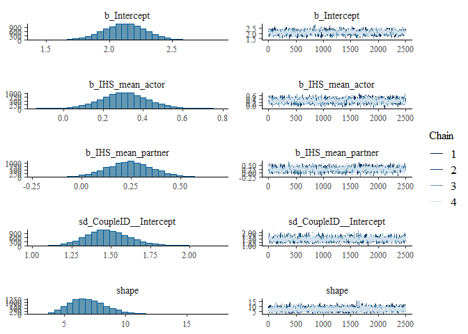

```r
plot(aim1_psych)
```

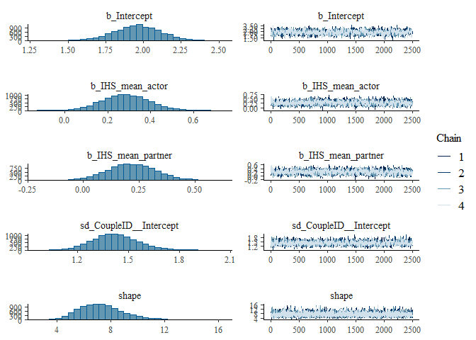

```r
plot(aim1_psych_min)
```

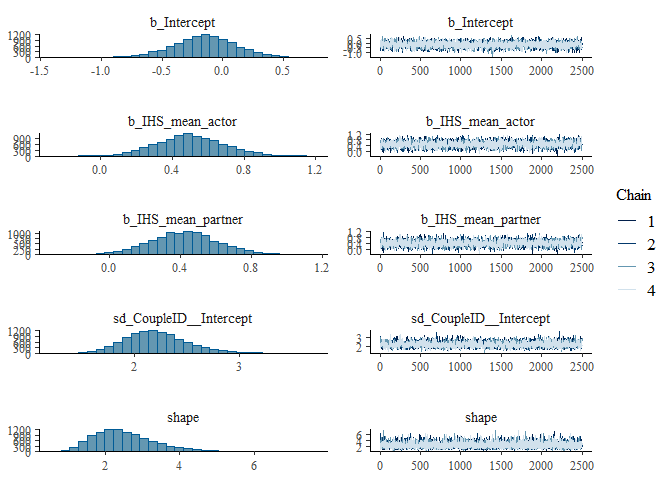

```r
plot(aim1_psych_sev)
```

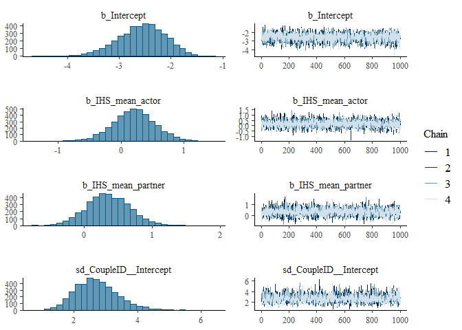

```r
plot(aim1_phys)
```

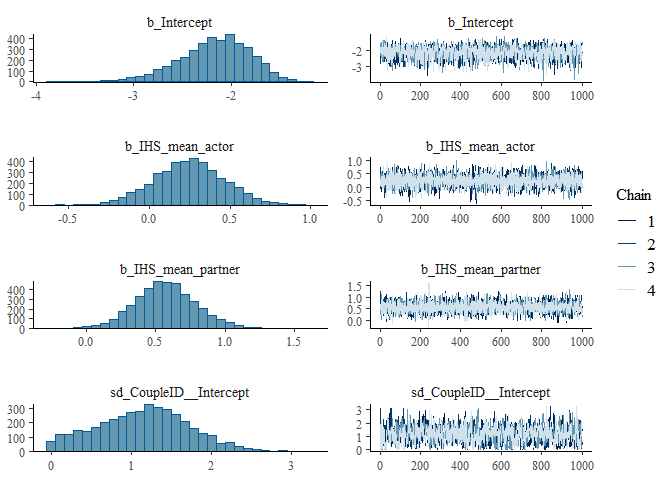

```r
plot(aim1_sgm)
```

Aim 1 with covariates:

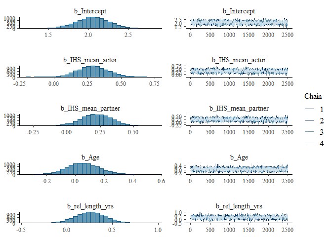

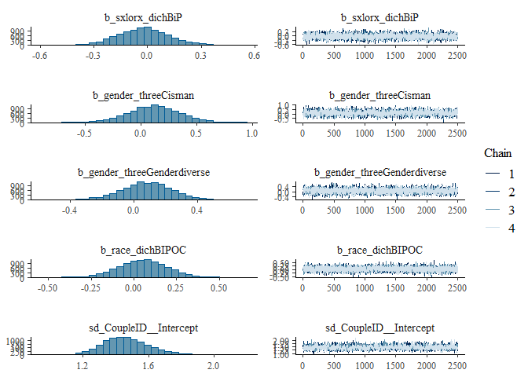

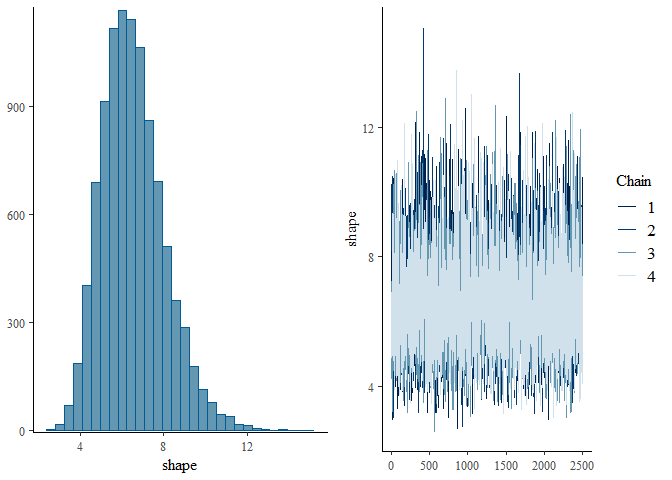

```r
plot(aim1_psych_cov)
```

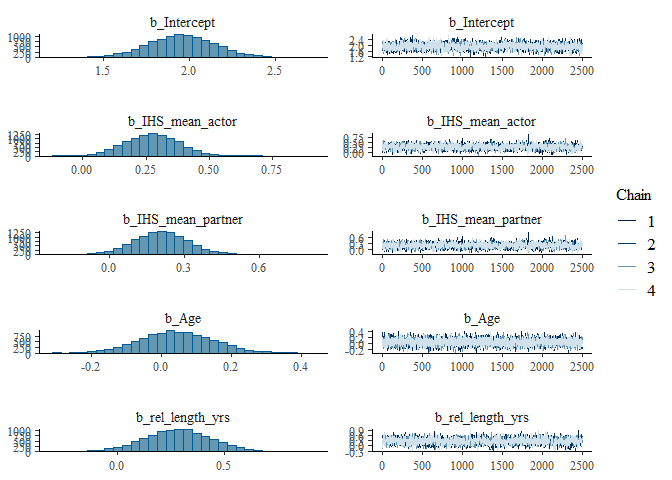

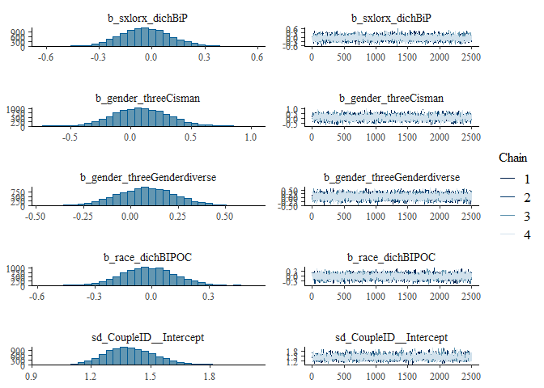

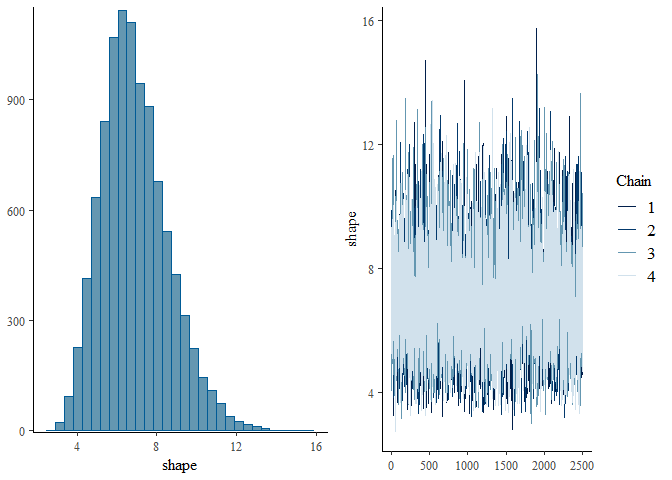

```r
plot(aim1_psych_cov_min)
```

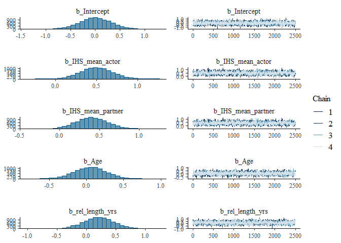

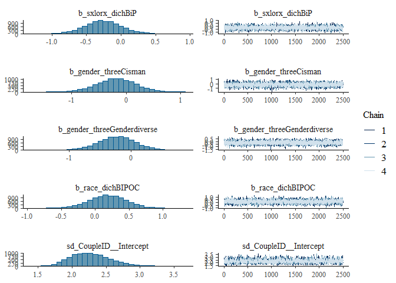

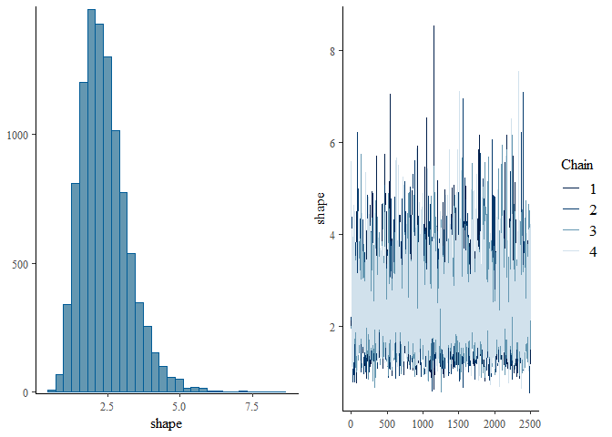

```r
plot(aim1_psych_cov_sev)
```

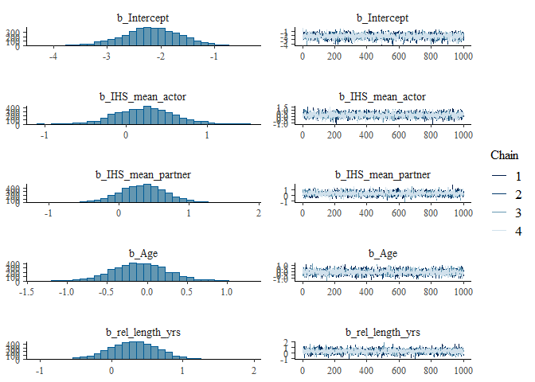

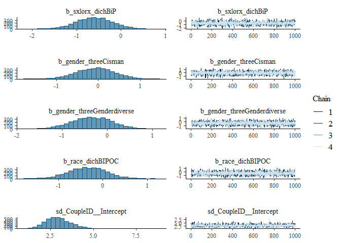

```r
plot(aim1_phys_cov)
```

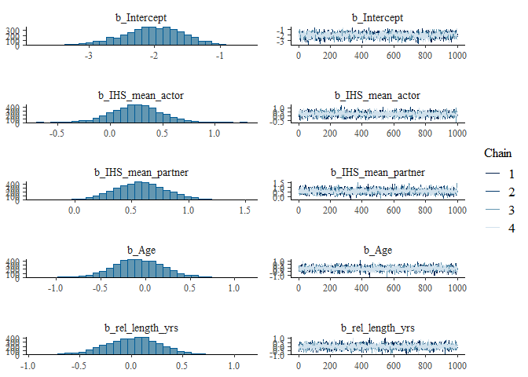

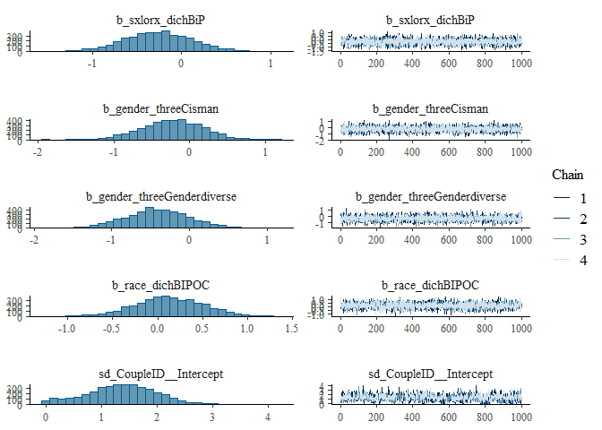

```r
plot(aim1_sgm_cov)
```

Aim 3 - unadjusted models:

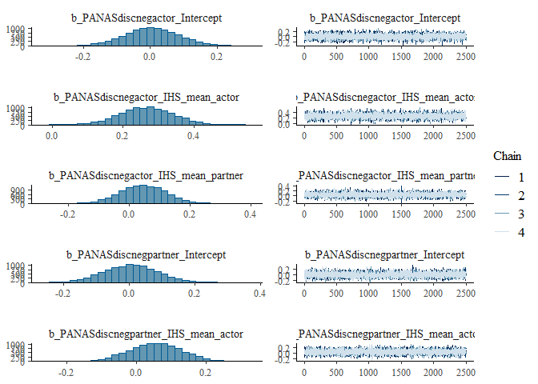

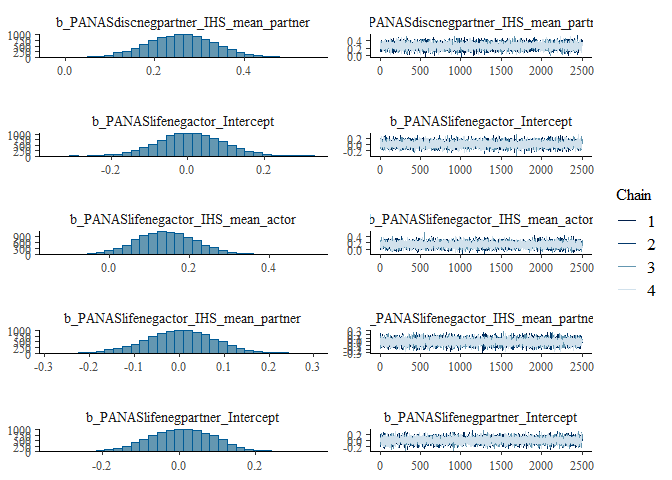

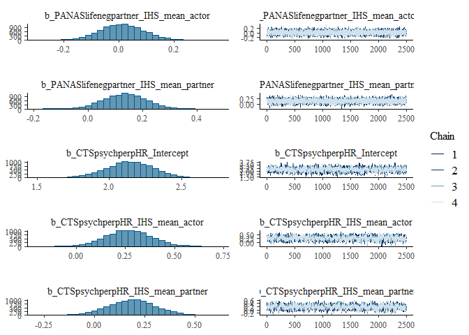

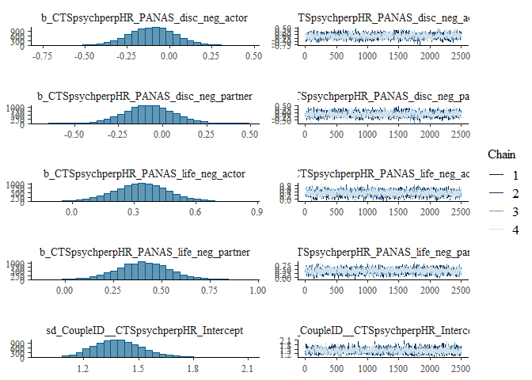

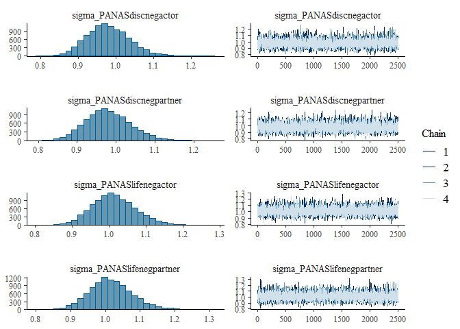

```r
plot(aim3_psych)
```